# 英语写作手册 ：中文版 (高等学校英语专业系列教材)

[3] Standing at both sides of the path are two small cone-shaped pavilions, each is supported by three red pillars. There stands a tablet recording the history of the temple in the pavilion on the left, while in the pavilion on the right, there is a chess table made of stone. Although it is worn by constant use, you can still discern the lines on the stone. It is said during the years when Lajiameshi meditated in the cave behind the temple, he sometimes played chess with the local people on this table when he was tired from sitting. Later after his departure, the cave collapsed and the chess table was removed into the temple.

[4] The path finally ends right in front of Falundian, the Hall of Dharma. It is a triangular prismshaped structure with a clay elephant on the ridge. Under the four overhanging eaves are four great pillars on which flying dragons are spiraling upward. The whole structure is about 11 meters in height and occupies a floor space of 300 square meters.

[5] Once you get into the hall, the first thing you see is the colored clay sculpture of Sakyamuni sitting cross-legged on the lotus-shaped stand. The Buddha has a calm smile on his face. The robe is tightly wrapped around his body as if he has just come out of water. On the right of Sakyamuni is the laughing Amitabha in his half-lying posture, while the Buddha of Infinite Life on the left has a serene look.

[6] At the back of the three buddhas is the standing statue of Lajiameshi, made of elm. It is the image of a thin man with long curly hair and bright eyes. His left leg is raised as if he were stepping swiftly into the gate of heaven. The long streaks engraved on the cassock give you the impression that he is riding on the wind. This was a most learned man who came to China as a religious preacher, and at the same time he introduced a totally different culture to the Chinese people. Largely owing to his efforts, the Chinese built the first and largest temple of the Yellow Sect of Lamaism of China—Taer Temple.

—Student

范文7

A Free Market

[1] With a shopping bag in my hand, I entered the gate of the free market near my home. Suddenly a terrible smell reached my nose and I could not help feeling nauseated. Looking around I found that the foul smell came from the poultry stalls on the left side of the street. There, every small cage was packed with four or five chickens. Occasionally, the chickens crowed sadly as if they knew they were going to be cooked. The feed stank under the hot summer sun. I put a handkerchief to my nose and hurried away.

[2] "Live fish! Fresh and cheap!" A husky voice of a man was heard. In front of his stall, there stood a big canvas bag. Inside, a lot of fish were struggling in the turbid water. They opened their mouths widely to have their last breath of air. Terrified at the price, I left for other stalls. Just then a young fellow stopped me and tried to persuade me to buy a chain of garlic in his hand. He was disappointed to see me shaking my head.

[3] Then I came to the vegetable and fruit stalls which made up the busiest section of the market. A good variety of vegetables and fruits could be found here at summertime. Red tomatoes, green cucumbers and peppers were put at the most conspicuous places. The sweet smell of the fruits—peaches, plums, muskmelons, and purple-colored grapes—had drawn many customers. The sellers were praising their produce in strong provincial accents and competing with each other by offering lower prices. Housewives would certainly drive a good bargain with the sellers before they really bought anything.

[4] At the far end of the market were the clothing stalls. Colorful clothes were hung up high to attract people's attention. There were quite a number of people but only few bought any clothes. A girl had stood at one of the stalls for a long time. Obviously she desired to have that fashionable skirt which was said to be made in Hong Kong. But finally she left, for she was unwilling to pay almost her monthly wage for it.

[5] After hours of shopping—choosing and bargaining, I left the noisy market, exhausted but quite satisfied, my bag full of vegetables and fruits.

—Student

作业3

1．描写一个地方，如：

1）一个景点、公园、花园、剧院、市场、购物中心、饭店大厅、展览馆、花展以及博物馆等等；

2）一个北京的四合院（siheyuan ，a traditional single-story house with rooms around the four sides of a courtyard）；

3）某人的书房、卧室、客厅、厨房等等。

2．描写一间四人宿舍来表现：学生甲爱好整洁，珍惜时间；学生乙待人热情，爱好运动；学生丙粗心大意、爱好音乐；学生丁对时装比对学习更感兴趣。

3）描写物品

描写某物时，必须提及其**形状、大小、颜色、质地、气味** 以及**味道** 等等，这就要依靠我们的感官。如果此物有实用价值，则须说明如何使用；如果它与某人有关，则须叙述它在此人生活中起何作用。不过，文章强调的应该是此物的某一方面，着重它最重要的特征。

范文8

The Earliest Coins in China

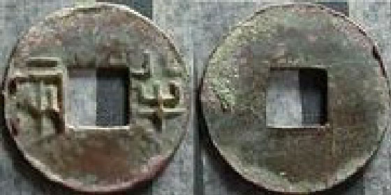

[1] Of the various currencies used in ancient China, the round bronze coin with a square hole in the center was by far the most common. The earliest coins in this form, known as Qin ban liang , were a product of China's first centralized kingdom, the Qin dynasty, established by Qin Shi Huang in 221 B.C. Before the Qin dynasty, Chinese currency had taken many forms. Coins shaped like various items of clothing, farm implements, or knives were in circulation, but they were costly and hard to produce, and difficult to carry and transport. The new coins were a great improvement—they were relatively simple to cast and could be strung together for ease of transportation. The new coins also had a particular philosophical significance to the ancient Chinese, who made the coins to symbolize their belief that heaven was round and the earth was square, and that heaven sheltered the earth and all things in the universe were united. This concept of unity was important to the Qin emperors, who ruled over a unified China and believed their power great enough to spread to the four corners of the earth.

[2] The coins also had great aesthetic appeal. They were thought to represent the relationship between man and nature. Commonly found in nature, the circle represents freedom, comfort, and ease; whereas the square is seen as something man-made, a symbol of law, order, and restraint.

[3] All these factors combined to keep the coins in circulation for more than 2,000 years; only in the twentieth century did they cease to be legal tender.

—Chen Xingde

【 **分析** 】

短文讲述中国货币发展过程中具有里程碑意义的“秦半两”。作者在描述其形状、制作材料时，强调“秦半两”的造型象征着古代天圆地方的宇宙观这一重要特色。

作业4 描写一件物品。

它可以是：

1）一幅画、一张相片、一件手工艺品（an article of handicraft art）、一块墓碑（tombstone）、一块匾（tablet）等等；

2）展览馆或博物馆的一件展品（exhibit），如一件出土文物（an unearthed artifact），一个新产品或家用小商品（household gadget）；

3）一项中国古代发明，如最早的指南针；

4）一座牌楼（pailou , a decorated archway）或其他典型的中国建筑物；

5）华表（cloud pillar）、石狮或其他带有中国文化特色的东西。

4）描写情景

情景有时是文章的主要部分，有时则仅仅是插入长篇记叙文中的一个片段。情景通常包括三个基本要素：**场景，人物** 和**行动** 。情景中描绘的也可能是某种自然现象。

在动笔描写情景前要事先考虑好描写的目的，即想要取得什么效果和希望给读者留下什么印象，否则无法决定细节的取舍。

范文9

A Typhoon

[1] The typhoon came out of the sea first as a deep hollow roar. Then it appeared as a monstrous black cloud. The cloud seemed a thing alive, shaping itself this way and that, torn by contending winds. However it might stretch to right or left, it continued to spread upward and reach toward east and west. The day darkened to twilight and the dreaded roar of sound came rushing toward me from out of the depths. I crouched behind my rock and waited.

[2] At first, I remember, there was no rain, only the wild winds and the tossing sea. An hour earlier, the sea had been calm and blue. Now it was black and streaked with crests of white foam. When the rain came it was all of a sudden, as though the clouds had opened and spilled. A curtain of rain fell between mountain and sea, a solid sheet of water three feet away from me. The grass and brush on the mountainside flattened under the wind and the rain. I was surrounded by the madness, the unreason, of uncontrolled, undisciplined energy...

[3] The storm spent itself at last. The winds dispersed, the rain slackened to a drizzle and mist, the cloud fell apart and the sun shone through. I came out from my shelter and surveyed the ruin left behind. Trees had fallen on the lower levels, gullies were dug into the earth between the rocks, the very grass and underbrush lay flat and exhausted.

—Pearl Buck

【 **分析** 】

赛珍珠在描绘台风这一自然现象时，生动地形容台风的声音、表象、行动，它对大海、草地、树木造成的影响。她使用deep hollow/dreaded roar, monstrous black cloud, wild winds, tossing sea, curtain of rain以及sheet of water等词语，旨在给读者留下台风是“疯狂的，具有不可控制的能量”的深刻印象。

范文10

Dragon Lantern Shows

[1] For city dwellers, dragon lanterns can be seen only on grand ceremonies on TV. In my hometown, however, putting on a dragon lantern show is a very popular performance. To celebrate the Spring Festival, many villages make preparations for the dragon lantern show. Usually a village organizes a team of its own, but sometimes it is also possible for people from several villages to form one team.

[2] Dragon lanterns are made in the shape of dragons which are believed to be existing in heaven. They are made of white gauze, with nine parts or even more. Candles are put into the bodies of the dragons so that in the evening they look even livelier than in the daytime. When people put on dragon lantern shows, they are said to be "imitating" the various postures and movements of a dragon. In the countryside, the performances are often given in the evening in the first month of the lunar calendar. During that period of time, my hometown is filled with joy and excitement. In the evening, people are immersed in great pleasure, watching various kinds of dragons changing their postures constantly. Look! A male dragon is circling the playground, while four or more female ones are dancing gracefully. Sometimes, two lions are running and jumping among the crowd of dragons. The whole playground is brightened with candlelight. The rhythmic sound of gongs and drums that accompany the show attract many people who shout and laugh while watching. Even the sky looks lively.

[3] Besides giving dragon lantern shows, the performers bring sincere good wishes to the people who watch. In China, the dragon has long been regarded as a symbol of happiness and auspiciousness. When a team comes to perform in a neighboring village, it also brings to the villagers the most sincere hope that good luck and happiness will accompany them in the coming new year.

[4] The fifteenth of the first month of the lunar calendar is called the Lantern Festival. It is the day when all dragons fly back to heaven from which they are believed to have come. That evening, dragon lanterns are played in as many different ways as the players can think of. Many people will come to enjoy this most magnificent moment in the Spring Festival. After that carnival, the gauze lanterns will disappear in a fire, symbolizing that the dragons are going back to heaven. With their departure, grownups go home thinking seriously about the work to be done in the new year, while children hope that more dragons will come next year.

—Student

作业5

1．描写一个情景，此情景可以是：

1）一场（生日）宴会、庆祝会、婚礼，一次游行或事故等等；

2）某人回家或离家的情景。

动笔前要考虑好希望取得的效果以便选取细节。

2．描写：

1）在你家乡人们如何庆祝中秋节（Mid-Autumn Festival）或春节（Spring Festival）；

2）汉族或中国某少数民族的一个风俗。

3．自选题目描写某人、某物、某地或某情景。

2．记叙文

记叙文讲述一件事或一系列事情或事件。从广义上讲，真实或虚构的故事、自传、历史、新闻以及叙事诗都属记叙文之列。

记叙往往和描写相结合。人们讲故事时，要描绘场景、环境和人物；而在描写某人或某一情景时，又常常有必要叙述活动。

在构思记叙文时，应考虑以下五个方面：目的、细节的选择、场合、组织结构、叙述角度。

1）目的

讲故事必定有其目的：或告诫、教训，或证明某一理论，或阐明某一概念，或赞美某种美德，或谴责某种罪恶等等。若要确保读者准确无误地领会叙述的意图，作者则必须认真挑选细节，并精心设计故事情节。

2）细节的选择

记叙文是由细节组成的。读者只有通过足够的细节才能知道发生了什么事情。但细节过多会使读者如坠烟海，兴趣顿消。只有选用与内容有关或能表现主要观点的细节，才能产生预期的效果。因此在选择细节时要牢记撰写记叙文的目的、意图。

3）场合

记叙文往往在一开头就提供有关背景环境的信息，清楚地交代文中所述的行动发生在**何时、何地** 和**与何人有关** 。这样做有助于读者理解通篇叙述。

4）组织结构

在记叙文中，事件通常是按其发生的先后次序来叙述的，这叫顺叙。但是故事有时也可以从中间甚至结局写起，从最重要、最能引人入胜的事件开始，然后回过头来追述故事的开端和经过，这叫倒叙。

记叙文一般有开头、中间和结尾。场景描写可以放在开头，中间部分讲述故事本身。故事讲明白了，叙述也就自然而然地结束了，无需增加一个多余的结尾段落。但有时可能需要增加一两段，谈谈故事的重大意义或后来又发生了什么事情。

5）叙述角度

故事可以用第一人称叙述，也可以用第三人称叙述，二者各有利弊。第一人称的叙述使读者感到所描绘的一切都是作者亲眼所见或亲身经历过的，因此读起来更真实生动。但是，这种叙述难以反映在同一时间内于不同地点发生的事情。第三人称叙述就没有这一局限性，同时还可能更加客观。不过，妥善地编排在不同地点、不同人物身上发生的事情也不是一件容易的事。

范文11

Salvation

[1] I was saved from sin when I was going on thirteen. But not really saved. It happened like this. There was a big revival at my Auntie Reed's church. Every night for weeks there had been much preaching, singing, praying, and shouting, and some very hardened sinners had been brought to Christ, and the membership of the church had grown by leaps and bounds. Then just before the revival ended, they held a special meeting for children, "to bring the young lambs to the fold." My aunt spoke of it for days ahead. That night I was escorted to the front row and placed in the mourners' bench with all the other young sinners, who had not yet been brought to Jesus.

[2] My aunt told me that when you were saved you saw a light, and something happened to you inside. And Jesus came into your life! And God was with you from then on. She said you could see and hear and feel Jesus in your soul. I believed her, I had heard a great many old people say the same thing and it seemed to me they ought to know. So I sat there calmly in the hot, crowded church, waiting for Jesus to come to me.

[3] The preacher preached a wonderful rhythmical sermon, all moans and shouts and lonely cries and dire pictures of hell, and then he sang a song about the ninety and nine safe in the fold, but one little lamb was left out in the cold. Then he said: "Won't you come? Won't you come to Jesus? Young lambs, won't you come?" And he held out his arms to all us young sinners there on the mourners' bench. And the little girls cried. And some of them jumped up and went to Jesus right away. But most of us just sat there.

[4] A great many old people came and knelt around us and prayed, old women with jet-black faces and braided hair, old men, with work-gnarled hands. And the church sang a song about the lower lights are burning, some poor sinners to be saved. And the whole building rocked with prayer and song.

[5] Still I kept waiting to see Jesus.

[6] Finally all the young people had gone to the altar and were saved, but one boy and me. He was a rounder's son named Westley. Westley and I were surrounded by sisters and deacons praying. It was very hot in the church, and getting late now. Finally Westley said to me in a whisper: "God damn! I'm tired o' sitting here. Let's get up and be saved." So he got up and was saved.

[7] Then I was left all alone on the mourners' bench. My aunt came and knelt at my knees and cried, while prayers and songs swirled all around me in the little church. The whole congregation prayed for me alone, in a mighty wail of moans and voices. And I kept waiting serenely for Jesus, waiting, waiting—but he didn't come. I wanted to see him, but nothing happened to me. Nothing! I wanted something to happen to me, but nothing happened.

[8] I heard the songs and the minister saying: "Why don't you come? My dear child, why don't you come to Jesus? Jesus is waiting for you. He wants you. Why don't you come? Sister Reed, what is this child's name?"

[9] "Langston," my aunt sobbed.

[10] "Langston, why don't you come? Why don't you come and be saved? Oh, Lamb of God! Why don't you come?"

[11] Now it was really getting late. I began to be ashamed of myself, holding everything up so long. I began to wonder what God thought about Westley, who certainly hadn't seen Jesus either, but who was now sitting proudly on the platform, swinging his knickerbockered legs and grinning down at me, surrounded by deacons and old women on their knees praying. God had not struck Westley dead for taking his name in vain or for lying in the temple. So I decided that maybe to save further trouble, I'd better lie, too, and say that Jesus had come, and get up and be saved.

[12] So I got up.

[13] Suddenly the whole room broke into a sea of shouting, as they saw me rise. Waves of rejoicing swept the place. Women leaped in the air. My aunt threw her arms around me. The minister took me by the hand and led me to the platform.

[14] When things quieted down, in a hushed silence, punctuated by a few ecstatic "amens," all the new young lambs were blessed in the name of God. Then joyous singing filled the room.

[15] That night, for the last time in my life but one—for I was a big boy twelve years old—I cried. I cried, in bed alone, and couldn't stop. I buried my head under the quilts, but my aunt heard me. She woke up and told my uncle I was crying because the Holy Ghost had come into my life, and because I had seen Jesus. But I was really crying because I couldn't bear to tell her that I had lied, that I had deceived everybody in the church, that I hadn't seen Jesus, and that now I didn't believe there was a Jesus any more, since he didn't come to help me.

—Langston Hughes

【 **分析** 】

这是一篇从一个12岁孩子的视角撰写的记叙文，其目的在于揭示耶稣并不存在。作者一开头就在第［1］段中把“何人”、“何地”、“何时”三点交代得一清二楚。休斯选择了许多细节说明上帝和耶稣在美国黑人、尤其是老年黑人的生活中所扮演的重要角色［第2～4段］。从第［5］到［10］段，读者得知12岁的主人公是个诚实的孩子，真心相信耶稣，并期待耶稣会来帮助自己。但是尽管他能肯定他的朋友Westley没有见到耶稣,却没有因在教堂撒谎而受到上帝的惩罚；于是，他的信念彻底崩溃了！［第11段］结尾的第［15］段颇具震撼力。读者看到可怜的孩子为在教堂对姑母撒谎并欺骗了所有的人而羞愧万分。从那晚开始，孩子不再幼稚天真。

范文12

The Most Important Day in My Life

[1] The most important day I remember in all my life is the one on which my teacher, Anne Mansfield Sullivan, came to me. I am filled with wonder when I consider the immeasurable contrasts between the two lives which it connects. It was the third of March, 1887, three months before I was seven years old.

[2] On the afternoon of that eventful day, I stood on the porch, dumb, expectant. I guessed vaguely from my mother's sighs and from the hurrying to and fro in the house that something unusual was about to happen, so I went to the door and waited on the steps. The afternoon sun penetrated the mass of honeysuckle that covered the porch, and fell on my upturned face. My fingers lingered almost unconsciously on the familiar leaves and blossoms which had just come forth to greet the sweet southern spring. I did not know what the future held of marvel or surprise for me. Anger and bitterness had preyed upon me continually for weeks and a deep languor had succeeded this passionate struggle.

[3] Have you ever been at sea in a dense fog, when it seemed as if a tangible white darkness shut you in, and the great ship, tense and anxious, groped her way toward the shore with plummet and sounding-line, and you waited with beating heart for something to happen? I was like that ship before my education began, only I was without compass or sounding-line, and had no way of knowing how near the harbor was. "Light! Give me light!" was the wordless cry of my soul, and the light of love shone on me in that very hour.

[4] I felt approaching footsteps. I stretched out my hand as I supposed to my mother. Someone took it, and I was caught up and held close in the arms of her who had come to reveal all things to me, and, more than all things else, to love me.

[5] The morning after my teacher came, she led me into her room and gave me a doll. The little blind children at the Perkins Institution had sent it and Laura Bridgman had dressed it; but I did not know this until afterward. When I had played with it a little while, Miss Sullivan slowly spelled into my hand the word "d-o-l-l." I was at once interested in this finger play and tried to imitate it. When I finally succeeded in making the letters correctly, I was flushed with childish pleasure and pride. Running downstairs to my mother, I held up my hand and made the letters for doll. I did not know that I was spelling a word or even that words existed; I was simply making my fingers go in monkey-like imitation. In the days that followed I learned to spell in this uncomprehending way a great many words, among them pin , hat , cup and a few verbs like sit , stand , and walk . But my teacher had been with me several weeks before I understood that everything has a name.

[6] One day, while I was playing with my new doll, Miss Sullivan put my big rag doll into my lap also, spelled "d-o-l-l" and tried to make me understand that "d-o-l-l" applied to both. Earlier in the day we had had a tussle over the words "m-u-g" and "w-a-t-e-r." Miss Sullivan had tried to impress it upon me that "m-u-g" is mug and that "w-a-t-e-r" is water , but I persisted in confounding the two. In despair she had dropped the subject for the time, only to renew it at the first opportunity. I became impatient at her repeated attempts and seizing the new doll, I dashed it upon the floor. I was keenly delighted when I felt the fragments of the broken doll at my feet. Neither sorrow nor regret followed my passionate outburst, I had not loved the doll. In the still, dark world in which I lived there was no strong sentiment of tenderness. I felt my teacher sweep the fragments to one side of the hearth, and I had a sense of satisfaction that the cause of my discomfort was removed. She brought me my hat, and I knew I was going out into the warm sunshine. This thought, if a wordless sensation may be called a thought, made me hop and skip with pleasure.

[7] We walked down the path to the well-house, attracted by the fragrance of honeysuckle with which it was covered. Someone was drawing water and my teacher placed my hand under the spout. As the cool stream gushed over one hand, she spelled into the other the word water , first slowly, then rapidly. I stood still, my whole attention fixed upon the motions of her fingers. Suddenly I felt a misty consciousness as if something forgotten—a thrill of returning thought; and somehow the mystery of language was revealed to me. I knew then that "w-a-t-e-r" meant the wonderful cool something that was flowing over my hand. That living word awakened my soul, gave it light, hope, joy, set it free! There were barriers still, it is true, but barriers that could in time be swept away.

[8] I left the well-house eager to learn. Everything had a name, and each name gave birth to a new thought. As we returned to the house, every object which I touched seemed to quiver with life. That was because I saw everything with the strange, new sight that had come to me. On entering the door I remembered the doll I had broken. I felt my way to the hearth and picked up the pieces. I tried vainly to put them together. Then my eyes filled with tears; for I realized what I had done, and for the first time I felt repentance and sorrow.

[9] I learned a great many new words that day. I do not remember what they all were; but I do know that mother , father , sister , teacher were among them—words that were to make the world blossom for me, "like Aaron's rod, with flowers." It would have been difficult to find a happier child than I was as I lay in my crib at the close of that eventful day and lived over the joys it had brought me, and for the first time longed for a new day to come.

—Helen Keller

课堂练习6

1．范文12的目的是什么？

2．文章是否清楚交代了事情发生的时间、地点和有关的人物？

3．列举作者为表达主要观点选取的细节。

范文13

The Stamp Incident

[1] I can never forget the stamp incident which happened when I was a primary school pupil.

[2] My best friend whose nickname was Apple was a stamp-collector. He tried every way to get stamps and spent every penny he had on them. Once he obtained a beautiful or precious stamp he would be more than happy. I was always his companion in his search for stamps.

[3] One day Apple whispered to me mysteriously that he had found a most wonderful stamp on a letter addressed to our young arithmetic teacher, who was a very pretty and kind-hearted girl. Apple wanted that stamp so badly that he said if he couldn't get it, he wouldn't be able to eat or sleep. Then the idea of stealing occurred to him, and he couldn't get rid of it. I was frightened and begged him not to do that. He showed signs of much hesitation, too. Without saying any more words, he left.

[4] That evening he hurried to my home and almost dragged me out of the house to the corner of a street and showed me a letter.

[5] It was in a man's handwriting. In the letter the man implored our teacher to forgive him and asked her to meet him at the gate of Shanlin Park at eight that evening. If not, he'd take it that she would never forgive him, and it meant the end of their relationship.

[6] "The teacher asked me if there was any letter for her this afternoon. You see, she knows I am a stamp-collector and always wander about the place where letters are delivered. When I said 'No', she looked rather sad," Apple told me after I had read the letter.

[7] We were completely at a loss. Too frightened to go to the teacher, we decided to go to the meeting place ourselves.

[8] When we arrived at the park, we found at the gate a tall young man with glasses, walking back and forth as if he was waiting anxiously for someone. He looked at his watch from time to time. I did not know how long we had been there. Finally the man left, looking very worried and disappointed.

[9] A few days later, our teacher asked Apple to go to her room and gave him many stamps. With a melancholy expression on her face, she told Apple that she once had a friend who was a stamp-collector too, but she had lost him forever, so the stamps she had collected for him were no longer useful.

[10] Apple ran to me with stamps in his hand and tears in his eyes. We both cried bitterly. From then on, Apple never collected any more stamps; neither did I.

—Student

课堂练习7 讨论文章的组织结构。

1．范文13是否对背景——事情发生的时间、地点和有关的人物——做了交代？

2．作者如何将各段落连成一个整体？

作业6

第一部分

将“Salvation”或“The Most Important Day in My Life”改写为第三人称记叙文。

第二部分

1．写一篇第一人称记叙文，描述：

1）你记忆中最快乐、最悲伤、最值得回忆或最重要的一天：如入学的第一天；面试或第一次拿到工资的那一天；某人（一个老师、朋友或同事）走进你的生活的那一天；发生某事从而改变了你的生活道路的那一天；

2）一件对你有教育意义的事；

3）一次难忘的经历。

2．选用以上任何题目写一篇第三人称记叙文。

3．写一篇记叙文，讲述：

1）端午节（the Dragon Boat Festival）吃粽子（zongzi ）的来历或中国其他的风俗习惯；

2）牛郎（the Cowherd）与织女（the Girl Weaver）的传说，梁山伯（Liang Shanbo）与祝英台（Zhu Yingtai）的故事或外国人可能感兴趣的中国传说故事。

4．自选题目写一篇记叙文。

一些描写情景的作文题目也可用来写记叙文，但二者重点不同。记叙文有情节，其中包括开头、中间和结尾；如果把情景比作画，则叙述可比作电影。写记叙文时要先考虑叙述目的，然后根据目的选择细节、设计情节。注意应在文章开头交代清楚事情发生的背景，同时要考虑文章的结构和叙述角度。

你也可以把写过的情景描写文改写成记叙文，这样有助于你了解二者之间的异同。

3．说明文

在描写文、记叙文、说明文和议论文四类文章中，学生、科技工作者和一般工作人员写得最多的还是说明文。英语exposition（说明）一词的意思就是阐述、解释。说明文解释或探讨各种问题，如机器的制造过程，自然或社会现象产生的原因，工程的规划或问题的解决方案等等。

前面讲过，描写文主要写的是外观和情感，记叙文写的是事件和经历。而说明文所涉及的主要是过程和关系。人们描述某物的外观时，要用描写文，但是要讲解此物是如何制作的，如何使用，可能如何变化时，就要用说明文了。记叙文谈论一个历史事件时，应叙述事件本身，事件发生的时间、地点以及与事件有关的人物。说明文讨论的则是事件发生的原因及后果，其性质和历史意义。

可以采用多种方式来说明事物——如举例，讲述其过程，用分解、分类法或类比、对比法，分析事物产生的原因及后果或给事物下定义。也就是说，可用来展开段落的各种方法都适用于说明文，只不过篇幅长短不同罢了。段落中往往只用几句话来说明一个问题，而在文章中要讲清一个问题，可能需要一两段文字。

说明文必须做到解说清楚明晰。撰写说明文时以下几点值得注意：

·题目不可太大，讨论的问题不要过多，因为一篇短文不可能讲清许多问题。

·准备足够的资料（实例和细节）。如果不用具体的实例说明，一般读者往往难以理解抽象的讨论。

·观点和实例应根据题目的性质，或按时间或按逻辑顺序排列。

·遣词造句要准确明晰，避免用华而不实的词藻或含混不清的语言。

·尽可能使讲解有趣感人，有经验的作者往往还能寓教于乐。

1）举例说明文

举例说明文使用例子阐明观点，这是最常见，往往也是最有效的阐释模式。不用例子确实难以写好任何文章。好的例子有助于作者清楚地表达思想，从而避免泛泛而谈。实例能使抽象的问题具体化，这样不但能引起读者的兴趣，还可以使文章具有说服力。

文章有时仅使用举例展开法，但通常是将举例展开法和其他展开法，如分解、分类法，类比、对比法和定义法等等结合使用。

一篇好的举例说明文应该做到：

·精心地挑选足够的具体、典型、有趣、与题目密切相关的例子，例子可以是作者的亲身经历，也可以来自可靠的第二手资料。

·妥帖地编排例子；类似的或相关的例子应归在一起，并按照逐步推向高潮的递进顺序排列。

范文14

Language and Culture

[1] Once a group of Chinese was visiting the home of a fairly well-to-do American. As they were shown around the house, they commented, "You have a very nice home. It's so beautiful." The hostess smiled with obvious pleasure and replied in good American fashion "Thank you”—which caused surprise among some of her Chinese guests. Later, while conversing at the dinner table, the host remarked to the Chinese interpreter, a young lady who had graduated not long ago from a Chinese university, "Your English is excellent. Really quite fluent." To this she demurred, “No, no. My English is quite poor"—an answer that he had not expected and found a bit puzzling.

[2] Was the American hostess' reply immodest, as it seemed to some of the Chinese?

[3] Was the young Chinese interpreter's remark insincere, as it sounded to the Americans?

[4] In both cases the answer is no . To English-speaking people, praise is to be accepted, generally with a remark like "Thank you." It is assumed that the compliment is sincere, that the praise is for some not unworthy achievement or thing. Therefore, there should be no show of false humility, no pretended modesty. To Chinese, however, the customary reply to a compliment would be to claim that one is not worthy of the praise, that what one has done is hardly enough, or that success was more a matter of luck or some other circumstances. Acceptance of a compliment would imply conceit or lack of manners. So, in the two cases above, the reason for such different reactions was differences in customs and habits. Each was interpreting what the other said according to his or her own culture.

[5] Events like these are fairly common when people of different languages and cultures communicate. Because of cultural differences, misunderstandings may arise, although the language used in communication may be faultless. The same words or expressions may not mean the same thing to different peoples. Because of cultural differences, a serious question may cause amusement or laughter; a harmless statement may cause displeasure or anger. Because of cultural differences, jokes by a foreign speaker may be received with blank faces and stony silence. Yet the same stories in the speaker's own country would leave audiences holding their sides with laughter.

—Deng Yanchang

【 **分析** 】

短文在第［1］段中用具体、典型、与题目密切相关的例子表明中国人和美国人在受到称赞时反应不同。第［2～4］段讨论由此产生的误解及其原因。第［5］段说明文章的意图在于强调不同民族之间的沟通不仅需要外语知识，了解文化差别也同样重要。

范文15

The Advantages of Temporary Jobs

[1] Years ago, people were often a little surprised when they heard that a college student was doing a part-time job. "Why? Maybe he is short of money," they thought. Nowadays, many college students are working as tutors. Some serve as tour guides or do whatever work they can find during vacations. In big cities, students often put up advertisements on bulletin boards or wire poles near bus stops. Are they all short of money? Perhaps not.

[2] "By doing part-time jobs, we have broadened our vision and gained some experience," those who do temporary jobs often say. Since most students enter college as soon as they finish middle school, they lack experience in the ways of society. When they graduate from college, they often find the outside world is not as simple as they thought and have difficulty in adjusting themselves to reality. Many students find doing temporary jobs is a good way to solve the problem. While working, they learn how to deal with different kinds of people and situations. Gradually, they increase their knowledge and deepen their understanding of society.

[3] One of my classmates taught English to senior middle school students in his hometown during the last summer vacation. The first difficulty he met with was to find a classroom. His request of using a classroom in a middle school was turned down. However, he did not lose heart and tried hard to find some other place. Later, with the help of a former teacher of his, he succeeded.

[4] Temporary jobs can also help students improve their academic studies. My own experience is an example. During the last winter vacation, a friend asked me to help him improve his ability to understand spoken English. When I saw the teaching material, I felt a little frightened. For it was something like TOEFL, and I had not had any practical experience with it. However, I accepted the job. Every time before teaching him, I would listen to the tape again and again in order to get everything clear. It was time-consuming and troublesome. But later I found my own listening comprehension improved too.

[5] If one works as a tutor, he ought to understand everything in the texts he is teaching, or he may not be able to answer the student's questions. If one serves as a tour guide, he should know something about places of historic interest and scenic beauty. Whatever job it may be, one has to learn in order to be qualified.

[6] Part-time jobs can also provide students with pocket money. Nowadays, the expenses of college students are high. Girl students like to have some fashionable clothes, while boy students want good sneakers and T-shirts. The pay for temporary jobs can help cover the expenses.

[7] Besides, doing temporary jobs makes students feel self-reliant. "I feel rather ashamed every time I receive money from home. I'm no longer a child, yet I still have to be supported by my parents" —such words are often heard on campus. Young people talk a lot about independence. They are aware if one is not economically independent, one cannot enjoy true independence.

[8] Recently, a report in China Youth said that about one fifth of the country's college students have done or are doing temporary jobs, and as the economic reform is going on, the number is increasing. Today, students doing temporary jobs are no longer thought to be short of money but are looked on with approval.

—Student

课堂练习8

1．如前所述，要写好记叙文，下笔前对写作目的应胸中有数。你认为上文的写作意图是什么？

2．精选的实例有助于作者阐明观点，既可避免内容抽象、空泛，又可使文章有趣、有说服力。指出上文中作者精选的此类实例。

作业7

第一部分

下面是选自《金融时报》的一篇文章，仔细阅读全文后，用你自己的话语写一篇短文。你可以利用文中实例，但不要照抄原文。

Survey Shows Chinese Teens Adhere to Traditional Values

（Adapted）

[1] According to a recent survey by McKinsey & Company, China's teenage consumers value name brands and trendy products but also display a strong adherence to traditional values that sets them apart from their peers in overseas markets.

[2] The survey, based on interviews with 800 consumers across China between the ages of 12 and 17, found that 96 percent of teen respondents in China said they expected to support their parents in their old age while only 79 percent of parents said they anticipated such support.

[3] The survey also indicated that though young Chinese felt a strong imperative to keep up with the latest fashions, more teens than adults believed that saving a significant amount of money was a "virtue."

[4] The study also revealed differences in the way Chinese teens spend their free time and pocket money. Though watching television still reigns as the most popular activity, as in most developed countries, Chinese teens spend a higher share of their free time reading books, magazines and newspapers than their Western counterparts. "Trendy"teens, which the report segmented as the wealthiest teen population, are the biggest buyer of books, spending an estimated RMB 6 billion on reading material per year. In addition to books and other reading material, CDs and digital audio products are also popular purchases, as older teens tend to prefer listening to music over watching television.

By Beina Xu, FT.com site, Jul 05, 2006

如果你选用其他题目，所选实例应能说明、证实你的议题。初稿完成后，参照第110-111页列举的修订初稿的五项内容逐条检查、修改、润色。

第二部分

1．任选下列一题撰写一篇举例说明文：

1）College Students' Everyday Expenses Are High

2）Changes in My Hometown or Beijing in the Last... Years or Since...

3）Life on Campus Is Interesting/ Monotonous

4）The Qualifications of a Good Teacher

5）We Need More People like…

6）Parents/Teachers/Friends…Have Great Influence on Us

7）Films Not Worth Seeing

8）Hobbies

9）Such Behaviors Should Be Praised/ Condemned

10）We Can Profit from Good Books

2．自选题目撰写一篇举例说明文。

记下你能想到的所有实例，删除与主题无关、无趣、不典型的实例后，重新组织归纳。先按照逐步推向高潮的递进顺序排列实例，拟好提纲，然后开始写初稿。

2）类比与对比说明文

**类比** 论述事物如何**相似，对比** 说明事物如何**不同** 。其实，人们每天都在进行类比和对比，只不过自己没有意识到这一点罢了。在学校，老师可能通过类比中国的人民代表大会来讲解英国国会，或用类比和对比说明英国与美国国会的异同。在商店，售货员可能对比两种商品以表明甲优于乙。在书店，学生可能比较两种词典的异同以决定购买哪本为好。

写类比与对比说明文时，作者的**目的** 不外乎以下三个：

·通过和熟悉的事物类比来**提供** 有关不熟悉事物的**信息** ；

·通过类比**表明** 甲**优于** 乙；

·向读者**表明** 两个事物的**异同** 以便于读者理解并对二者做出评价。说明文可以仅仅讨论两个事物如何相似（即类比）或如何不同（即对比），不过此类文章大多既有类比又有对比，只是侧重点有所不同罢了。

撰写类比与对比说明文时，应牢记以下原则：

（1）类比或对比**只能用于同类的（通常是两个）事物之间** 。

类比或对比一个动物与一种矿物是没有意义的。一般来说，类比说明文用于阐明两个看来颇为不同的事物，对比说明文则用于论述两个看来颇为相似的事物。好的类比与对比说明文探讨的不是事物显而易见的异同，而是那些可能被人们忽略的异同。

（2）类比与对比说明文有**两种模式：按照比较体（即比较对象）** 展开或**按照比较项目（即比较内容）** 展开。

按照比较对象展开时，作者先讨论甲的各个方面，然后再讨论乙的各个方面：

Thesis statement: X is a better school than Y.

Ⅰ．X

A．Student body

B．Teaching staff

C．Library and other facilities

D．Campus

Ⅱ．Y

A．Student body

B．Teaching staff

C．Library and other facilities

D．Campus

按照比较项目展开时，作者分项论述甲、乙：

Ⅰ．Student body

A．X

B．Y

Ⅱ．Teaching staff

A．X

B．Y

Ⅲ．Library and other facilities

A．X

B．Y

Ⅳ．Campus

A．X

B．Y

一般说来，文章短小，比较项目不多，或作者着重从整体上比较事物时，宜使用比较体展开法。如果论文较长，比较的方面又多，那么长篇大论地探讨某事物的各个方面只会增加读者的负担；读者看到后面时，往往已经忘记前面说了些什么。在这种情况下，使用比较项目展开法更好些。不过正如范文所示，在同一篇说明文中，可能两种模式兼而有之。

（3）类比、对比的事物各自所占的**篇幅** 应大致**相同** ，类比、对比的项目也应一致，同时着墨也相等。

使用按照比较体展开的模式时，在事物甲下讨论的各项，在讨论事物乙时也应一一提及。不仅提及的顺序应当相同，而且使用的段落数量最好也相等。这类文章常犯的错误是，论述甲的项目多于论述乙的项目（如：I A，B，C，D；II A，B）。因此，在动笔前最好准备一个提纲。

有时，按照比较体展开的一篇文章读上去颇像两篇独立的文章。为了避免出现这一问题，可使用like/unlike，as，instead (of)，compared with，in contrast（to/with）等词或短语。这些词和短语既能加强文章的一致性、整体感，又有助于读者重温类比及对比各项的内容。

用于比较体展开法的各条原则，大部分也适用于撰写按照比较项目展开的说明文。在比较和安排段落时，作者应该自始至终按照同一顺序。两种模式主要的差别在于以上提到的词和短语在按照比较对象展开的说明文中更加重要。

用于类比说明文的转换词有：both，each，at the same time，similarly，like，likewise，as，too，also，compared with等。

用于对比说明文的转换词有：on the other hand，on the contrary，in contrast (with/ to)，instead (of)，the opposite (of)，unlike，although，while，whereas，but，however，yet，nevertheless等。

（4）类比和对比必须**以有关的具体实例为依据** 。

泛泛而谈不能说服读者；含糊其词的文章只能给人以肤浅的印象。有了具体的例子，以及通过观察分析而来的独特细节，类比和对比才有说服力。

（5）类比、对比说明文通过指出两者的异同来**阐明具体问题** 。

作者类比或对比两事物时总有一定的目的，如表明甲优于乙，或并不优于乙；或甲和乙同样有用；或尽管甲与乙不同，两者都是有益、必要的等等；实际上这就是文章的论题。

比拟是一种特殊的比较方法。比拟指出的不是同类的而是不同类的两个事物的相似之处。如作者把人生比作旅程，是用比拟来阐明并加深读者对人生的理解。比拟与类比不同，并不使用相等的篇幅讨论甲和乙，而是用甲来阐明乙。

使用比拟展开法应注意以下指导原则：

·文章中的两个事物不属于同类。

·比拟说明文中的甲事物仅仅用于阐明乙事物。

·阐明乙事物的甲事物必须是读者熟悉的，这样才有助于读者理解乙事物。

·比拟只用来说明一个问题的某个方面。

·比拟只提出新的看法或观察问题的新角度，不能用来证明任何问题。

范文16

Education and Training

[1] To understand the nature of the liberal arts college and its function in our society, it is important to understand the difference between education and training .

[2] Training is intended primarily for the service of society; education is primarily for the individual. Society needs doctors, lawyers, engineers, teachers to perform specific tasks necessary to its operation, just as it needs carpenters and plumbers and stenographers. Training supplies the immediate and specific needs of society so that the work of the world may continue. And these needs, our training centers—the professional and trade schools—fill. But although education is for the improvement of the individual, it also serves society by providing a leavening of men of understanding, of perception, and wisdom. They are our intellectual leaders, the critics of our culture, the defenders of our free traditions, the instigators of our progress. They serve society by examining its function, appraising its needs, and criticizing its direction. They may be earning their livings by practicing one of the professions, or in pursuing a trade, or by engaging in business enterprise. They may be rich or poor. They may occupy positions of power and prestige, or they may be engaged in some humble employment. Without them, however, society either disintegrates or else becomes an anthill.

[3] The difference between the two types of study is like the difference between the discipline and exercise in a professional baseball training camp and that of a Y gym. In the one, the recruit is training to become a professional baseball player who will make a living and serve society by playing baseball; in the other, he is training only to improve his own body and musculature. The training at the baseball camp is all relevant. The recruit may spend hours practicing how to slide into second base, not because it is a particularly useful form of calisthenics but because it is relevant to the game. The exercise would stop if the rules were changed so that sliding to a base was made illegal. Similarly, the candidate for the pitching staff spends a lot of time throwing a baseball, not because it will improve his physique—it may have quite the opposite effect—but because pitching is to be his principal function on the team. At the Y gym, exercises have no such relevance. The intention is to strengthen the body in general, and when the members sit down on the floor with their legs outstretched and practice touching their fingers to their toes, it is not because they hope to become galley slaves, perhaps the only occupation where that particular exercise would be relevant.

[4] In general, relevancy is a facet of training rather than of education. What is taught at law school is the present law of the land, not the Napoleonic Code or even the archaic laws that have been scratched from the statute books. And at medical school, too, it is modern medical practice that is taught, that which is relevant to conditions today. And the plumber and the carpenter and the electrician and the mason learn only what is relevant to the practice of their respective trades in this day with the tools and materials that are presently available and that conform to the building code.

[5] In the liberal arts college, on the other hand, the student is encouraged to explore new fields and old fields, to wander down the bypaths of knowledge. There the teaching is concerned with major principles, and its purpose is to change the student, to make him something different from what he was before, just as the purpose of the Y gym is to make a fat man into a thin one, or a strong one out of a weak one.

[6] Clearly the two types of learning overlap. Just as the baseball recruit gets rid of excess weight and tightens his muscles at the baseball camp and thereby profits even if he does not make the team, so the law student sharpens his mind and broadens his understanding, even if he subsequently fails the bar exam and goes on to make his living in an entirely different kind of work. His study of law gives him an understanding of the rules under which our society functions and his practice in solving legal problems gives him an understanding of fine distinctions.

[7] On the other hand, the Y member, whose original reason for joining may have been solely to get himself in shape, may get caught up in the institution's baseball program and find that his skill has developed to the point where he can play the game professionally. Similarly, the student who undertakes a course of study merely because it interests him and he wants to know more about it may find that it has commercial value. He has studied a foreign language and literature in order to understand the society that produced it, and then he may find that his special knowledge enables him to get a job as a translator. Or he may find that while his knowledge of chemistry is not of professional caliber, it is still sufficient to give him preference in a particular job over someone who lacks even that modicum of knowledge of the subject. But these are accidental and incidental. In general, certain courses of study are for the service of society and other courses are for self-improvement. In the hierarchy of our educational system, the former are the function of our professional schools and the latter are the function of the college of liberal arts.

—Harry Kemelman

【 **分析** 】

作者的目的是要阐明文科大学的性质及其社会功能，他在第［1］段用对比来表明自己的观点。文章的第［2］、［3］两段用按照比较项目（即比较内容）模式展开，第［4～7］段则用按照比较体（即比较对象）模式展开。作者在第［3］、［6］、［7］三段用比拟展开法加深读者对education和training之间差异的认识。他举了人们熟悉的事例——在棒球培训基地训练和在体育馆健身之间是有差别的——不仅很好地论证了自己的观点，也打开了读者的思路。

范文17

Grant and Lee: A Study in Contrasts

[1] When Ulysses S. Grant and Robert E. Lee met in the parlor of a modest house at Appomattox Court House, Virginia, on April 9, 1865, to work out the terms for the surrender of Lee's Army of Northern Virginia, a great chapter in American life came to a close, and a great new chapter began.

[2] These men were bringing the Civil War to its virtual finish. To be sure, other armies had yet to surrender, and for a few days the fugitive Confederate government would struggle desperately and vainly, trying to find some way to go on living now that its chief support was gone. But in effect it was all over when Grant and Lee signed the papers. And the little room where they wrote out the terms was the scene of one of the poignant, dramatic contrasts in American history.

[3] They were two strong men, these oddly different generals, and they represented the strengths of two conflicting currents that, through them, had come into final collision.

[4] Back of Robert E. Lee was the notion that the old aristocratic concept might somehow survive and be dominant in American life.

[5] Lee was tidewater Virginia, and in his background were family, culture, and tradition...the age of chivalry transplanted to a New World which was making its own legends and its own myths. He embodied a way of life that had come down through the age of knighthood and the English country squire. America was a land that was beginning all over again, dedicated to nothing much more complicated than the rather hazy belief that all men had equal rights, and should have an equal chance in the world. In such a land Lee stood for the feeling that it was somehow of advantage to human society to have a pronounced inequality in the social structure. There should be a leisure class, backed by ownership of land; in turn, society itself should be keyed to the land as the chief source of wealth and influence. It would bring forth (according to this ideal) a class of men with a strong sense of obligation to the community; men who lived, not to gain advantage for themselves, but to meet the solemn obligations which had been laid on them by the very fact that they were privileged. From them the country would get its leadership; to them it could look for the higher values—of thought, of conduct, of personal deportment—to give it strength and virtue.

[6] Lee embodied the noblest elements of this aristocratic ideal. Through him, the landed nobility justified itself. For four years, the Southern states had fought a desperate war to uphold the ideals for which Lee stood. In the end, it almost seemed as if the Confederacy fought for Lee; as if he himself was the Confederacy...the best thing that the way of life for which the Confederacy stood could ever have to offer. He had passed into legend before Appomattox. Thousands of tired, underfed, poorly clothed Confederate soldiers, long since past the simple enthusiasm of the early days of the struggle, somehow considered Lee the symbol of everything for which they had been willing to die. But they could not quite put this feeling into words. If the Lost Cause, sanctified by so much heroism and so many deaths, had a living justification, its justification was General Lee.

[7] Grant, the son of a tanner on the Western frontier, was everything Lee was not. He had come up the hard way, and embodied nothing in particular except the eternal toughness and sinewy fiber of the men who grew up beyond the mountains. He was one of a body of men who owed reverence and obeisance to no one, who were self-reliant to a fault, who cared hardly anything for the past but who had a sharp eye for the future.

[8] These frontier men were the precise opposites of the tidewater aristocrats. Back of them, in the great surge that had taken people over the Alleghenies and into the opening Western country, there was a deep, implicit dissatisfaction with a past that had settled into grooves. They stood for democracy, not from any reasoned conclusion about the proper ordering of human society, but simply because they had grown up in the middle of democracy and knew how it worked. Their society might have privileges, but they would be privileges each man had won for himself. Forms and patterns meant nothing. No man was born to anything, except perhaps to a chance to show how far he could rise. Life was competition.

[9] Yet along with this feeling had come a deep sense of belonging to a national community. The Westerner who developed a farm, opened a shop or set up in business as a trader, could hope to prosper only as his own community prospered—and his community ran from the Atlantic to the Pacific and from Canada down to Mexico. If the land was settled, with towns and highways and accessible markets, he could better himself. He saw his fate in terms of the nation's own destiny. As its horizons expanded, so did his. He had, in other words, an acute dollars-and-cents stake in the continued growth and development of his country.

[10] And that, perhaps, is where the contrast between Grant and Lee becomes most striking. The Virginia aristocrat, inevitably, saw himself in relation to his own region. He lived in a static society which could endure almost anything except change. Instinctively, his first loyalty would go to the locality in which that society existed. He would fight to the limit of endurance to defend it, because in defending it he was defending everything that gave his own life its deepest meaning.

[11] The Westerner, on the other hand, would fight with an equal tenacity for the broader concept of society. He fought so because everything he lived by was tied to growth, expansion, and a constantly widening horizon. What he lived by would survive or fall with the nation itself. He could not possibly stand by unmoved in the face of an attempt to destroy the Union. He would combat it with everything he had, because he could only see it as an effort to cut the ground out from under his feet.

[12] So Grant and Lee were in complete contrast, representing two diametrically opposed elements in American life. Grant was the modern man emerging; beyond him, ready to come on the stage, was the great age of steel and machinery, of crowded cities and a restless, burgeoning vitality. Lee might have ridden down from the old age of chivalry, lance in hand, silken banner fluttering over his head. Each man was the perfect champion of his cause, drawing both his strengths and his weaknesses from the people he led.

[13] Yet it was not all contrast, after all. Different as they were—in background and personality, in underlying aspiration—these two great soldiers had much in common. Under everything else, they were marvelous fighters. Furthermore, their fighting qualities were really very much alike.

[14] Each man had, to begin with, the great virtue of utter tenacity and fidelity. Grant fought his way down the Mississippi Valley in spite of acute personal discouragement and profound military handicaps. Lee hung on in the trenches at Petersburg after hope itself had died. In each man there was an indomitable quality...the born fighter's refusal to give up as long as he can still remain on his feet and lift his two fists.

[15] Daring and resourcefulness they had, too; the ability to think faster and move faster than the enemy. These were the qualities which gave Lee the dazzling campaigns of Second Manassas and Chancellorsville and won Vicksburg for Grant.

[16] Lastly, and perhaps greatest of all, there was the ability, at the end, to turn quickly from war to peace once the fighting was over. Out of the way these two men behaved at Appomattox came the possibility of a peace of reconciliation. It was a possibility not wholly realized, in the years to come, but which did, in the end, help the two sections to become one nation again...after a war whose bitterness might have seemed to make such a reunion wholly impossible. No part of either man's life became him more than the part he played in their brief meeting in the McLean house at Appomattox. Their behavior there put all succeeding generations of Americans in their debt. Two great Americans, Grant and Lee— very different, yet under everything very much alike. Their encounter at Appomattox was one of the great moments of American history.

—Bruce Catton

课堂练习9

1．范文17中作者的写作意图是什么？他想表明什么观点？

2．讨论作者文中使用的模式。

3．对比／类比的篇幅安排是否平衡？对南北双方统帅着墨是否相等？

4．指出对比／类比中使用的过渡词语。

范文18

Eating and Reading

[1] As a creature, I eat; as a man, I read. Although one action is to meet the primary need of my body and the other is to satisfy the intellectual need of my mind, they are in a way quite similar.

[2] To keep ourselves alive, we need all kinds of nutrition. Eating is the most important way by which we can get starch, protein, vitamin, sugar, fat, and some trace elements. On the other hand, we eat not only because we have to do so, but also because we enjoy doing so. Having satisfied our hunger, eating can then be a kind of enjoyment. The color, the smell, and the taste of the food are considered as important as its nutritive value. Very often we eat some food not because it is nourishing but simply because we like it. This partiality for certain food will not affect our health, so long as we do not indulge heavily in it. There are many people, however, who do not eat the food they dislike and consequently suffer from malnutrition. So, for the sake of health, we have to eat some food even though we may not like it.

[3] Similarly, to enrich our minds, we need information and knowledge, which can be obtained through reading. Reading is one of the most important ways of learning. Without reading our minds will become empty like that of an animal. Sometimes, we take reading as a pastime, and we relax and learn at the same time. Since recreation is involved, we will naturally have a partiality for some particular kinds of books, just as we do for certain kind of food. It is all right if we read more books on history than books on literature. But suppose we focus on one subject only and pay no attention to anything else, we will face the problem of imbalance. Nutrition for our minds should be as comprehensive as the nutrition for our bodies. An educated person is a person who knows a lot of things about something and something about a lot of things. One's mind needs all kinds of nourishment, whether they are to one's liking or not.

[4] Besides, there are other similarities between eating and reading. We should not eat too much without digesting and assimilating, nor should we read too much without understanding and remembering. While we are eating, we should leave out the rotten part of the food which will do harm to our health; and while we are reading, we should be able to reject the poisonous content in a book, if any, for it will poison our minds.

[5] So, eat sensibly and read sensibly to give yourself a strong body and a healthy mind.

—Student

范文19

Beethoven and Lennon

[1] Ludwig van Beethoven was one of the greatest musicians in the 19th century. John Lennon was one of the greatest musicians in the 20th century. Although there is a period of more than 100 years between them, they are quite similar in certain ways.

[2] Both men expressed the spirit of their time in their music. Beethoven lived in the period of rising capitalism. At that time, people were trying to break the shackles of feudalism, and they were pursuing freedom, equality, and universal love. This social trend, especially the French revolution, greatly inspired Beethoven. His music was very active, passionate, and vigorous. Some of his works praised heroism, some conveyed the love for nature, and some extolled harmony among people. Similarly, Lennon's music revealed his time. In the 1960s and 1970s, the youth in America were deeply frustrated by the discrimination and injustice in the society and were longing to build a new one. Most of Lennon's songs expressed the ideas of the youth. In one of his songs entitled "Imagine", he sings,"Imagine all the people, living under peace", and "The world will together as one". These words show his anti-war attitude and his hope for peace, reflect the spirit of the 1960s and 1970s.

[3] Both men were social rebels to some extent. They refused to bow to social conventions and power. Beethoven was a devoted republican. When Napoleon I was in power, who claimed to be a defender of republicanism, Beethoven admired him so much that he dedicated his Symphony No. 5 , the theme of which is heroism, to him. But then Napoleon crowned himself and became an emperor. Beethoven was so angry that he openly declared he took back what he had said about Napoleon, regardless of possible persecution. Lennon was also considered a trouble-maker by the authorities because of his support for youth movements. For a time he was not even allowed to give public performances. But he ignored all this and stuck to his belief.

[4] As musicians, both men led to great leaps in the history of music. Beethoven's main contribution to music was his symphonies. It was he who clearly defined the form of symphony and fully developed it, which marked the end of the classical period and the beginning of the romantic period. His nine symphonies, especially No. 5, No. 6, and No. 9, are as highly regarded today as they were 100 years ago. Lennon's achievement was his rock-and-roll music. He and his band, the Beatles, successfully combined rhythm and blues with rock music, which laid the foundation for modern rockand-roll music.

[5] Although they had many things in common, Beethoven and Lennon belonged to different ages and thus were different in many ways. Beethoven's life was full of disaster and struggle. At the age of 29, when he was at the climax of his career, he lost his hearing, which was not very different from death penalty to a musician. But Beethoven managed to overcome this barrier, and miraculously he composed most of his masterpieces after he became deaf. What amazing willpower! Lennon's life was easier. He was able to live in comparative comfort, for he earned a lot from his discs and concerts. His way to success was not so hard as Beethoven's.

[6] Their endings were also very different. Beethoven died a natural death at the age of 57. But Lennon was shot in 1980 by one of his fans, which shocked the world.

[7] The names of both Beethoven and Lennon are inscribed on the monument to the history of music. They will always be remembered for their unique styles, great productivity, and indomitable personalities.

—Student

作业8

**第一部分**

下面是两篇“China Through My Eyes”栏目刊载的短文，该栏目由国家外国专家局和China Daily 联合举办。利用其中一篇中的实例写一篇短文；短文应使用你自己的语言，不要摘抄原文。

Chinese and Western Styles of Education

(Adapted)

[1] People often ask me whether I find students in China very different from those I have taught for the past 25 years in Australia and what the differences are. While there are exceptions to any generalization, I would say that on the whole, Western students aspire to excellence in individuality, whereas Chinese students aspire to excellence in conformity.

[2] While education in the West encourages learners from an early age to exercise critical and analytical skills, to show creativity and originality and to develop a spirit of enquiry, Chinese teaching appears to emphasize accuracy of factual recall, correctness of expression and respectful compliance with interpretations given by texts and teachers.

[3] Western students, therefore, are more at ease with debate and discussion, original experimentation and research than their Chinese counterparts, while Chinese students often show more excellence in pattern drill than their Western peers. Learners who are able to combine the strengths of both approaches are the ones who truly excel in either system.

[4] Social, historical and political factors combined have influenced the Chinese approach to foreign language learning, while a different combination of parallel factors has shaped Western scholarship. Now that a spirit of openness and co-operation prevails, we can hopefully all share our expertise as "citizens of the world," and benefit from each other's academic strengths.

—Josie Bishop

Laowai and Chinese Differ on Raising Their Children

(Adapted)

[1] The Chinese like children a lot, and I really appreciate that. I was curious how they express their love towards their own children. I guess this is a big cultural difference.

[2] Most Chinese children get whatever they want—ice cream, sweets, toys, and endless attention. Is that "love?" Maybe. I believe most Westerners think differently. We think love is to educate your child and teach him to live an independent life. That includes not getting something he or she really wants. As an adult he will not always get the fabulous car he longs for. She will not always get the beautiful dress she longs for. So we try to teach the children to cope with the frustration of not getting what they want.

[3] Here is an example which shows the difference in behaviour in the same situation. In front of the Qinghua kindergarten there is an old woman who sells ice cream. Naturally, whenever I pick up my four-year-old son Felix from kindergarten, he wants me to buy an ice cream. I think he can have one for special occasions, but not every day. One day, I picked up my xiaolaowai Felix and we had a fight about that ice cream.

[4] He wanted me to buy him an ice cream, I did not agree. He started to scream and cry as if he had been tortured. I told him that I was not going to buy him an ice cream, no matter how much he screamed. A woman heard Felix scream and asked me what the matter was. I told her and she just could not un derstand my being so incredibly cold and heartless. It resulted in her buying Felix an ice cream, even though I protested vehe mently. How do we express our love? How do we educate our chil dren? I believe there is a cultural difference, and I find this is really spoiling the children.

[5] On the other hand, I find the life of a Chinese child rather hard. Yes, the child is the adored and spoiled centre of the whole family. But they start to study very hard from a very early age and not always according to their own will. Children of my son's age take piano lessons, painting classes and even English classes. Just playing without learning anything is a waste of time. So in this aspect our children are spoiled, because they are allowed to just play.

[6] There are a lot of differences in child-raising. I just hope to make people think a little bit about these issues.

—Kathrin Bode

**参照下列五条修改初稿：**

1．对比/类比的两项所占篇幅是否大致相同？

2．段落安排是否连贯一致？

3．对比是否以相关的、具体的实例为依据？

4．短文是否表明了你的观点？

5．短文是否使用了承上启下的过渡词语？

第二部分

1．任选下列一题写一篇类比或对比说明文。

1）Life in Middle School and in College

2）Chinese and Foreign Teachers

3）Required and Elective Courses

4）E-mails and Traditional Letters

5）Chinese and Western Medicine or Food

6）Students/Schools of Liberal Arts and Those of Science and Engineering

7）Two Persons (such as writers, friends, figures in history, characters in a book or two books); Two Things (such as books, films, universities, radio/TV programs); or Two Places (such as stores, cities, places of historic interest or scenic beauty)

8）Values of Different Generations/Countries Concerning Family, Marriage, Divorce, or Education of Children

2．自选题目写一篇类比或对比说明文。

考虑好题目和写作意图后，列出类比或对比的项目，选择符合你的写作意图的展开模式，必要时两种模式可结合使用。注意类比或对比要以具体的、有关的实例为依据，且着墨应大致相等。切记使用得当的过渡词清晰地表达你的观点。

3）因果说明文

因果说明文旨在表明事物发生的原因及结果，也可能只阐明二者之一：或是原因，或是结果。此类说明文实际上是分析因果关系。

分析因果关系时，要回答两个问题：

·事情发生的原因是什么？

·如果发生了某事，其后果如何？

也就是说，追究原因要回答“为什么”的问题；探讨结果，则须回答“如果……，结果如何”的问题。回答第一个问题时，要从结果追溯到原因；回答第二个问题时，要从原因探索结果。

追究原因的说明文应在引论部分简短地交代结果，文章的主体部分则专门用来分析原因，通常每一个原因使用一个段落讨论。

议论结果的说明文程序恰恰相反：引论部分交代原因，其余部分论述结果。

有时，说明文可能既涉及原因，又涉及结果：比如在分析中国的独生子女政策时，作者一开头可能先谈原因，解释为什么要采取这一政策，然后再讨论这一政策带来的后果。

分析原因和结果是个复杂的过程。撰写因果说明文时应切记以下几点：

（1）分析原因时，**切不可过于简单化** 。

导致某一结果的原因，大都不止一个。例如学生考试不及格往往是多种原因造成的：比如对这门课不感兴趣并经常缺课；上课不专心听讲，很少记笔记又没有阅读老师指定的一些参考书；学习方法不对；考试头一天晚上赴宴返校很迟，因而睡眠不足等等。如果学生把考试不及格仅仅归咎于赴宴，就把原因过于简单化了。

（2）尤其注意**不要犯逻辑错误** 。

要记住，不能因为乙发生在甲之后，就断定甲必然是导致乙的原因。例如：一种传染病在某某出任卫生部长后爆发，就把传染病爆发说成是某某当了部长的缘故。

（3）**要区分直接原因与间接原因、直接结果与间接结果，以及主要原因与次要原因、主要结果与次要结果。**

某一结果可能是多种原因造成的，某一原因同样也可能导致多种后果，分析原因和结果的说明文不可不加区别地对所有的原因和结果一视同仁，而应使用更多的篇幅讨论主要的原因和结果。分析战争的起因时，历史学家常常提及引起战争的近因（或直接原因），但强调的却是作为根本原因的远因（或间接原因）。例如：1937年卢沟桥事变的导火索或直接原因是日军借口寻找演习失踪的士兵入侵宛平县城，但根本原因却是日军企图发动侵华战争，以摆脱国内经济危机。

在讨论某一行动或局面产生的结果时，也没有必要详尽论述直接结果和最终结果，而应把侧重点放在比较重要的结果上。

要仔细认真地考虑所有可能的、实际的原因和结果，但也要记住一旦分析的目的达到了，文章即可结束。

（4）**不要遗漏一系列原因和结果中的任何一个环节** 。

某一结果往往是由一系列原因造成的，这些原因一环套一环。必须讲清其中的每一个环节才能令读者信服。这如同医生只对病人家属说，病人是死于感冒，却没有讲清感冒导致肺炎，肺炎又对病人衰弱的心脏产生致命的影响。

（5）**言语要客观，分析要有根据，事实要确凿。**

中国有句古话：“仁者见仁，智者见智。”不同的人，由于看问题的角度不同，观点很可能也不同。认真、客观地审查和考虑他人得出的结论总是有益的，至少有助于我们避免片面性。

范文20

My Wood

[1] A few years ago I wrote a book which dealt in part with the difficulties of the English in India. Feeling that they would have had no difficulties in India themselves, the Americans read the book freely. The more they read it the better it made them feel, and a cheque to the author was the result. I bought a wood with the cheque. It is not a large wood—it contains scarcely any trees, and it is intersected, blast it, by a public footpath. Still, it is the first property that I have owned, so it is right that other people should participate in my shame, and should ask themselves, in accents that will vary in horror, this very important question: What is the effect of property upon the character? Don't let's touch economics; the effect of private ownership upon the community as a whole is another question—a more important question, perhaps, but another one. Let's keep to psychology. If you own things, what's their effect on you? What's the effect on me of my wood?

[2] In the first place, it makes me feel heavy. Property does have this effect. Property produces men of weight, and it was a man of weight who failed to get into the Kingdom of Heaven. He was not wicked, that unfortunate millionaire in the parable, he was only stout; he stuck out in front, not to mention behind, and as he wedged himself this way and that in the crystalline entrance and bruised his well-fed flanks, he saw beneath him a comparatively slim camel passing through the eye of a needle and being woven into the robe of God. The Gospels all through couple stoutness and slowness. They point out what is perfectly obvious, yet seldom realized: that if you have a lot of things you cannot move about a lot, that furniture requires dusting, dusters require servants, servants require insurance stamps, and the whole tangle of them makes you think twice before you accept an invitation to dinner or go for a bathe in the Jordan. Sometimes the Gospels proceed further and say with Tolstoy that property is sinful; they approach the difficult ground of asceticism here, where I cannot follow them. But as to the immediate effects of property on people, they just show straightforward logic. It produces men of weight. Men of weight cannot, by definition, move like the lightning from the East unto the West, and the ascent of a fourteen-stone bishop into a pulpit is thus the exact antithesis of the coming of the Son of Man. My wood makes me feel heavy.

[3] In the second place, it makes me feel it ought to be larger.

[4] The other day I heard a twig snap in it. I was annoyed at first, for I thought that someone was blackberrying, and depreciating the value of the undergrowth. On coming nearer, I saw it was not a man who had trodden on the twig and snapped it, but a bird, and I felt pleased. My bird. The bird was not equally pleased. Ignoring the relation between us, it took fright as soon as it saw the shape of my face, and flew straight over the boundary hedge into a field, the property of Mrs. Henessy, where it sat down with a loud squawk. It had become Mrs. Henessy's bird. Something seemed grossly amiss here, something that would not have occurred had the wood been larger. I could not afford to buy Mrs. Henessy out, I dared not murder her, and limitations of this sort beset me on every side. Ahab did not want that vineyard—he only needed it to round off his property, preparatory to plotting a new curve—and all the land around my wood has become necessary to me in order to round off the wood. A boundary protects. But—poor little thing—the boundary ought in its turn to be protected. Noises on the edge of it. Children throw stones. A little more, and then a little more, until we reach the sea. Happy Canute! Happier Alexander! And after all, why should even the world be the limit of possession? A rocket containing a Union Jack, will, it is hoped, be shortly fired at the moon. Mars. Sirius. Beyond which ... But these immensities ended by saddening me. I could not suppose that my wood was the destined nucleus of universal dominion—it is so very small and contains no mineral wealth beyond the blackberries. Nor was I comforted when Mrs. Henessy's bird took alarm for the second time and flew clean away from us all, under the belief that it belonged to itself.

[5] In the third place, property makes its owner feel that he ought to do something to it. Yet he isn't sure what. A restlessness comes over him, a vague sense that he has a personality to express—the same sense which, without any vagueness, leads the artist to an act of creation. Sometimes I think I will cut down such trees as remain in the wood, at other times I want to fill up the gaps between them with new trees. Both impulses are pretentious and empty. They are not honest movements towards moneymaking or beauty. They spring from a foolish desire to express myself and from an inability to enjoy what I have got. Creation, property, enjoyment form a sinister trinity in the human mind. Creation and enjoyment are both very, very good, yet they are often unattainable without a material basis, and at such moments property pushes itself in as a substitute, saying, "Accept me instead—I'm good enough for all three." It is not enough. It is, as Shakespeare said of lust, "The expense of spirit in a waste of shame”; it is "Before, a joy proposed; behind, a dream." Yet we don't know how to shun it. It is forced on us by our economic system as the alternative to starvation. It is also forced on us by an internal defect in the soul, by the feeling that in property may lie the germs of self-development and of exquisite or heroic deeds. Our life on earth is, and ought to be, material and carnal. But we have not yet learned to manage our materialism and carnality properly; they are still entangled with the desire for ownership, where (in the words of Dante) “Possession is one with loss."

[6] And this brings us to our fourth and final point: the blackberries.

[7] Blackberries are not plentiful in this meagre grove, but they are easily seen from the public footpath which traverses it, and all too easily gathered. Foxgloves, too—people will pull up the foxgloves, and ladies of an educational tendency even grub for toadstools to show them on the Monday in class. Other ladies, less educated, roll down the bracken in the arms of their gentlemen friends. There is paper, there are tins. Pray, does my wood belong to me or doesn't it? And, if it does, should I not own it best by allowing no one else to walk there? There is a wood near Lyme Regis, also cursed by a public footpath, where the owner has not hesitated on this point. He has built high stone walls each side of the path, and has spanned it by bridges, so that the public circulate like termites while he gorges on the blackberries unseen. He really does own his wood, this able chap. Dives in Hell did pretty well, but the gulf dividing him from Lazarus could be traversed by vision, and nothing traverses it here. And perhaps I shall come to this in time. I shall wall in and fence out until I really taste the sweets of property. Enormously stout, endlessly avaricious, pseudocreative, intensely selfish, I shall weave upon my forehead the quadruple crown of possession until those nasty Bolshies come and take it off again and thrust me aside into the outer darkness.

—E. M. Forster

【 **分析** 】

这是一篇用第一人称视角撰写的结果说明文，作者在第［1］段中表明其意图在于论述财产（他的树林）对他的影响。在后面的段落中，福斯特列举了拥有树林后的四个后果：使他感到沉重；使他感到树林应该更大［第3~4段］；使他感到作为树林的主人，他该有所行动［第5段］；最后,林中黑莓带来的问题［第6～7段］。福斯特用轻松、幽默的笔调讨论财产对人的品格的影响这一严肃的主题。尽管作者没有明说，但我们还是可以理解他的观点：首先，财产是祸不是福，有产者难以进天堂［第2段］；其次，财产使人贪心［第3～4段］；第三，财产令人心神不定，无法享受生活［第5段］；第四，财产使人自私、贪婪［第6～7段］。

范文21

Why I Want a Wife

[1] I belong to that classification of people known as wives. I am A Wife. And, not altogether incidentally, I am a mother.

[2] Not too long ago a male friend of mine appeared on the scene fresh from a recent divorce. He had one child, who is, of course, with his ex-wife. He is looking for another wife. As I thought about him while I was ironing one evening, it suddenly occurred to me that I, too, would like to have a wife. Why do I want a wife?

[3] I would like to go back to school so that I can become economically independent, support myself, and, if need be, support those dependent upon me. I want a wife who will work and send me to school. And while I am going to school I want a wife to take care of my children. I want a wife to keep track of the children's doctor and dentist appointments. And to keep track of mine, too. I want a wife to make sure my children eat properly and are kept clean. I want a wife who will wash the children's clothes and keep them mended. I want a wife who is a good nurturing attendant to my children, who arranges for their schooling, makes sure that they have an adequate social life with their peers, takes them to the park, the zoo, etc. I want a wife who takes care of the children when they are sick, a wife who arranges to be around when the children need special care, because, of course, I cannot miss classes at school. My wife must arrange to lose time at work and not lose the job. It may mean a small cut in my wife's income from time to time, but I guess I can tolerate that. Needless to say, my wife will arrange and pay for the care of the children while my wife is working.

[4] I want a wife who will take care of my physical needs. I want a wife who will keep my house clean. A wife who will pick up after my children, a wife who will pick up after me. I want a wife who will keep my clothes clean, ironed, mended, replaced when need be, and who will see to it that my personal things are kept in their proper place so that I can find what I need the minute I need it. I want a wife who cooks the meals, a wife who is a good cook. I want a wife who will plan the menus, do the necessary grocery shopping, prepare the meals, serve them pleasantly, and then do the cleaning up while I do my studying. I want a wife who will care for me when I am sick and sympathize with my pain and loss of time from school. I want a wife to go along when our family takes a vacation so that someone can continue to care for me and my children when I need a rest and change of scene.

[5] I want a wife who will not bother me with rambling complaints about a wife's duties. But I want a wife who will listen to me when I feel the need to explain a rather difficult point I have come across in my course of studies. And I want a wife who will type my papers for me when I have written them.

[6] I want a wife who will take care of the details of my social life. When my wife and I are invited out by my friends, I want a wife who will take care of the babysitting arrangements. When I meet people at school that I like and want to entertain, I want a wife who will have the house clean, will prepare a special meal, serve it to me and my friends, and not interrupt when I talk about things that interest me and my friends. I want a wife who will have arranged that the children are fed and ready for bed before my guests arrive so that the children do not bother us. I want a wife who takes care of the needs of my guests so that they feel comfortable, who makes sure that they have an ashtray, that they are passed the hors d'oeuvres, that they are offered a second helping of the food, that their wine glasses are replenished when necessary, that their coffee is served to them as they like it. And I want a wife who knows that sometimes I need a night out by myself.

[7] If, by chance, I find another person more suitable as a wife than the wife I already have, I want the liberty to replace my present wife with another one. Naturally, I will expect a fresh, new life; my wife will take the children and be solely responsible for them so that I am left free.

[8] When I am through with school and have a job, I want my wife to quit working and remain at home so that my wife can more fully and completely take care of a wife's duties.

[9] My God, who wouldn't want a wife?

—Judy Syfers

【 **分析** 】

这是一篇用第一人称视角撰写的原因说明文，从第［1］段我们得知作者为女性。为什么女性想要妻子？后面几段列举了原因，各段大多以“I want a wife who...”开始。文章用许多典型、具体的实例表明：是妻子外出工作支持丈夫上大学，并照顾丈夫和孩子们的各种需求以便丈夫能够既不用养家糊口又不必做家务琐事，一心一意地安心完成学业［第3～4段］；是妻子帮助丈夫打印作业；是妻子负责照料丈夫社交生活的所有事务［第5～6段］。更有甚者，如果丈夫找到了新的“更适合他的”妻子，他有自由娶她，而妻子理当作为“唯一对孩子负责”的家长，把孩子管起来［第7段］。此外，丈夫完成学业后，妻子应辞职以便“全心全意地做好尽职妻子的工作”［第8段］。文章的意图在于表明丈夫的种种有利条件以及男女不平等的现象。

范文22

Being Short

[1] Being short is something that cannot be helped. One cannot choose one's appearance; it is already decided at the time when one is born. And if it happens that one's parents are both short, it is inevitable that one will remain short all his life, whether he likes it or not.

[2] Being short is a lifelong pity. Almost everyone wants to look beautiful and to be moderately tall. For me, it has always been a bad time during medical examinations when I have to stand on that terrible scale and have my height measured and recorded. Year after year, the figure seems to remain the same. Although now I have more or less reconciled to this unchangeable fact, I just cannot help feeling regretful at times. How nice it would be if only I could be just an inch taller.

[3] Being short is a "handicap" and this is something that I hate most. During military training, I stood at the end of the line, because I was or was considered the shortest. And if they did not want too many students to march in a review, they always discarded the shortest, never the tallest. Though I do not really mind a great deal about joining in a review, I just do not feel good.

[4] I used to attend a volleyball training class, and every time we needed to separate into teams to play a match, the coach would say, "You twelve shorter ones go there, and you twelve taller ones come here, please." It sometimes makes me furious about being treated so unfairly. Short as I am, I am not a poor player and should be reckoned with.

[5] Being short is being inferior. Every day I live among people who are mostly taller than I am. Whether it is out of friendliness or whatever, very often, they pat me on the head, or throw one of their arms conveniently over my shoulder, and look down at me, while I have to look up at them. These gestures might not be ill intended, but I feel that these people are taking advantage of my shortness, and want to show they are superior to me.

[6] Being short is an impetus. When we, the short, have to live with these day-to-day disadvantages—the pity, the handicap, and the inferiority, we turn to other things to get self-confidence. We work industriously against prejudices to tell people that we are by no means inferior or handicapped.

—Student

课堂练习10

1．范文22是原因说明文？结果说明文？还是原因－结果说明文？

2．作者的分析是否以确凿的事实为依据？

3．短文的开篇是否引人入胜？结尾是否有力？条理是否清楚？

4．作者的写作意图是什么？

范文23

Effects of Selfishness

[1] Selfishness or egoism is by no means rare today. In work units, in public places, and in our university, we are sad to see some people who try to advance their own interests even at the cost of their honor and dignity.

[2] What are the effects of selfishness on a person? First, I think, selfishness makes him friendless. A selfish person does not understand that friendship is based on mutual respect and mutual help. It is something of "give-and-take." A selfish person never offers help to others, but he is brazen enough to ask others for help. He may want someone to explain something to him for an hour, but he will turn a deaf ear to this person's questions immediately after his own problem has been solved. He does not feel ashamed in doing so; instead, he feels justified because he makes good use of every minute of his time! A selfish person is also indifferent to other people's pains and sufferings and never stands out in an emergency. Therefore, when a room-mate of his falls seriously ill and is badly in need of his help, he dodges the responsibility by pretending not to know that. He hides himself in the library though he usually stays in the dormitory. A person like this can never expect to have true friends. He may take advantage of other people's kindness and benefit from it once or twice, but will lose their friendship forever.

[3] Secondly, a selfish person can never be really happy. Stingy with his time and energy, unwilling to help others, and eager to profit at other people's expense, a selfish person constantly finds himself despised and lonely. He can never share other people's pleasure or happiness, nor will others share his. He is so afraid of helping others that he keeps away from those who are doing something for other people. Generous people may help someone whose home has been damaged by a fire by offering money from their own pockets, but a selfish person will never do anything like that. Therefore, when people enjoy happiness in the happiness of the person they have helped, the selfish person can never have this happiness. Unable to get anyone's help in time of difficulty or share anyone's pleasure, how can a selfish person ever be happy?

[4] Thirdly, selfishness may very well lead a person to destruction. A selfish person's desire for good things is insatiable. He will shamelessly steal a book from the library and keep it for his own use even though he knows hundreds of his fellow students are badly in need of it. Once he succeeds in stealing something petty, his selfish desire will drive him on to "new adventures." Today it may be a book, tomorrow it will be a watch, a bicycle, a camera and so on until he ends up in prison.

[5] Selfishness poisons people's minds and runs counter to the basic values of a socialist society. It should have no place in our country today!

—Student

作业9

**第一部分**

下面是一位澳大利亚人写的短文，分析“关系”在中国产生的原因及其影响。和你的同学、朋友讨论作者的观点并写一篇因果说明文表明你对此问题的看法。

"Guanxi" Hampers a Clean, Fair System

(Adapted)

[1] A woman ready to return from the city to her hometown sees the long queues at the railway booking office and wonders whether she will reach the counter in time to purchase one of the limited tickets for that day's train. Then she remembers someone from her hometown, her mother's cousin's former classmate's husband, works in this station. A slight detour, a brief call, a "backdoor" opens, the fare is paid and the coveted ticket is hers. There has been no cheating or illegality, the ticket is bought and paid for; the acquaintance is happy to have been of service.

[2] It is natural for people to ex change favours with those they know or with whom they have some connection. Here such connections form an essen tial part of the social network, and the interplay of mutual obligations is a strong cohesive force in the society.

[3] This positive sense of co-operation and interdependence, though, has its negative side. The stranger or foreigner may easily feel disadvantaged and harbour a sense of injustice at the partiality of bureaucratic, administrative and commercial activity. Ugly words like "corruption," "bribery" and "nepotism" are used to describe the favours of individuals who mix personal and family obligations with public duties. What is the line that distinguishes consideration from corruption? How can justice and social order best be maintained?

[4] In feudal times, each family had to pit its resources against an arbitrary and exploitative system in the struggle for survival. Power, money and influence were valuable assets. In such circumstances, the tradition of "guanxi" is not hard to understand.

[5] The system has changed, but people's thoughts and practices have not. Now, the sheer size of China's population means there is still constant competition for limited goods, services and positions. What is more, in a market economy, any person who has sufficient money can readily buy available commodities. Why then, should the wealthy not also seek to buy opportunities or favours? It is easy to condemn corruption in principle, but far more difficult to abstain from its practice.

[6] Only 36 percent of examinees in the recent college entrance examinations will find places in the nation's universities. One cannot buy wisdom or learning, but perhaps power, influence and money can ensure a child's place in a good school.

[7] In a just system, of course all places will be allocated on merit, and teachers and educational administrators will be pillars of virtue, honesty and integrity. But teachers, too, are only human. They strive for excellence but may sometimes feel constrained by social pressures and their own unliberated thinking to accord unmerited favours.

[8] Family solidarity and loyalty, mutual co-operation and interdependence, these are some of the fine characteristics of traditional Chinese society. Greed, self-interest, manipulation, aggression and dishonesty are to be condemned in any society. As the New China traces out [勾绘] its path of progress, reform and modernization, it will build on the strong foundation of the best of its ancient traditions and values and discard the corruption of the past.

[9] It is not "who you know" or even "what you know" that will enable you as an individual to get ahead and contribute to a strong and noble modern China. It is who you are and what values you practise. In the exercise of public responsibility, perhaps the most appropriate response to personal requests or favours is mei guanxi or no connection.

Josie Bishop

**参照下列八条修改初稿：**

1．你是否清楚地说明了主要原因和/或主要结果？

2．你分析原因和/或结果时是否考虑到问题的各个方面？分析原因时有无过于简单化的倾向？

3．你是否区分了直接原因/后果和间接原因/后果？

4．你的分析是否以确凿的事实为依据？

5．你的文章有无逻辑错误？

6．你是否遗漏了一系列因果关系中的某些环节？

7．你的开篇是否引人入胜？结尾是否有力？

8．文章是否条理清楚、层次分明？

第二部分

1．阅读下面两短文后写一篇题为“China's Single-Child Policy”的因果说明文。动笔前应查阅我国有关计划生育的政策，只有全面了解独生子女政策才能看出下文中对此政策的误解以及不符合事实之处。

记住：要学会用分析批判的眼光审读所有的书面材料，这是学校教育的一个重要组成部分。

A Rash of "Little Emperors"

[1] ... When Peking launched its one-child campaign in 1979, officials had a single goal in mind: to contain China's population at 1.2 billion by the year 2000. Today nearly 80 percent of all young couples are complying with the one-child edict, and officials say that the program has dramatically defused the population explosion. But by doing away with large families, the state has also effectively eliminated China's traditional crop of obedient children. Today's tots are largely an overindulged lot that could rival America's Me Generation.

[2] ... And the party faithful worry that these kinds might never make obedient cadres."Children in the socialist society are not the private property of this or that family," warns Kang Keqing of the All-China Women's Federation. “[They are] the successors of the revolution.”

[3] ... Officials have begun to distribute articles that instruct parents on a range of child related problems. Elementary schools are introducing "moral education" classes that stress manners and humility. And in Liaoning Province, more than 10,000 parents now attend healthcare and child-psychology classes.

[4] Ironically, even as Chinese officials try to tame the little emperors, they fuel indulgent attitudes by granting special status to only-children. By law, such children are entitled to monthly health-care allowances and preferential treatment in admission to schools. They are also promised future housing and job assignments.

[5] Given such conflicting signals, it is hard to predict how the toddler brigade will shape up. Optimists say that today's tots will pioneer the way toward a more creative society. More cautious observers wonder what Chinese society will look like when today's spoiled children are grown-up wage earners. By then, the 4-2-1 syndrome is likely to mean four helpless grandparents, two demanding parents and one frustrated young adult who is expected to provide food and shelter for his elders. It is an open question whether today's pampered youngsters will be ready to handle such a responsibility.

From Newsweek , 18 March 1985

Being the Only Child

[1] Being the only child in my family has had some negative effects on me and on my parents as well.

[2] First, I became a very shy kid. As the only child in the family, I have been overprotected by my parents. When I was a little boy, I was not even allowed to play with other children outdoors, though I had no one to play with at home. Gradually and inevitably, I became a self-centered and extremely introverted child. Even today, I still lack the ability to interact with other people.

[3] Secondly, being the only child, I have been constantly under great pressure. My parents have placed all their hopes on me and sacrificed a lot to make sure that their only son will have a bright future. In return, I have to work very hard, and sometimes I even suffer from this pressure. For instance, when I was five years old, my parents told me to practice Chinese calligraphy. They devoted a lot of time and spent a lot of money on this. In order not to disappoint them, I pushed myself very hard, although I knew quite well that I did not have the talent for calligraphy.

[4] Having only one child also has had some negative effects on my parents. My mother felt extremely lonely and had a very miserable time after I left for college. She told me that at that time she did not even know how to manage without having me around. Oh, if only I had a brother or sister!

[5] Though having one child has given my parents certain advantages, I myself want to have more than one child.

—Student

2．任选下列一题写一篇因果说明文。

1）Why People Want to Learn a Foreign Language

2）Why Some Young Men Do Not Want to Marry a Capable Young Woman

3）Competition

4）What Education Can Do for Us

5）Juvenile Delinquency

6）Peasants Leaving the Countryside to Work in the Cities

7）Divorce in Present-Day China

8）Corruption

9）The Causes and/or Effects of China's Reform and Opening-Up Policy

题目选好后，先列出你想到的所有原因和结果，然后根据手头素材决定写**原因** 说明文、**结果** 说明文或是**原因－结果** 说明文。保留典型、具体、有趣、与主题有关的实例，拟好提纲后写初稿，然后用第一部分中的八条修改初稿。

3．自选题目写一篇因果说明文。

4）分解与分类说明文

分解与分类是两种不同的展开模式。**分解用于单一事物** ，目的在于**将此事物分解成若干部分** 。如一副眼镜可分解成眼镜架和眼镜片；一篇作文可分解成引论、本论和结论。**分类** 则用于若干**具有某些特性的事物** ，目的在于将这些事物**按照一定的标准组合** 。如大学的课程可分成“选修”课和“必修”课，或是“用汉语讲授”和“用外语讲授”的课程。同一组事物可按不同原则分类。

分解与分类展开法都是有用的写作手法。**分解展开法着重于事物的区别、差异；分类展开法则强调事物的相似、雷同** 。说明文固然可以单独使用其中一种展开法，但大多是两种方法同时使用。分解用于整体，分类用于部分。但整体和部分密切相关：整体由部分组成，部分组合而成整体。

在撰写分解与分类说明文时，应注意以下几点：

**（1）选择符合写作意图的分解与分类原则** 。

作者应按照一定的目的与着眼点对事物进行分解或分类。一群学生可划分为男生和女生，或学自然科学的和学社会科学的等等。如果作者的目的是想表明中国学生发音上的困难，按照学生所说的方言分类要比按照生源分类更加科学，因为说同一方言的学生往往在发音上有类似的弱点。

所选的分解与分类原则要有意义，并能引起读者的兴趣。比如，在划分人群时，把体重作为分类原则会显得十分荒谬可笑——除非作者旨在探讨体重不同的人对相同剂量的某种药物的反应，或者为了达到讽刺、幽默的目的。

**（2）使用原则要贯彻始终，同时要避免重叠现象。**

一群人可按照性别、种族、民族、职业、兴趣爱好、宗教信仰、家庭出身、社会经济地位、对工作或婚姻的态度等标准区分。但在划分时，只能取其中一项作为分类原则。如不能把与会代表分成欧洲人、非洲人、加拿大人、索马里人、中国人和黑人。因为头两类是按照地理或地区划分的，最后一类是按照种族划分的，而中间三类则是按照国家划分的。不仅如此，上述分类还犯有重叠的错误，因为索马里人既是非洲人又是黑人。**切记每一项只能划分到一类中去** ，不能同时归属两类。下面的提法也是错误的——“参加会议的代表来自世界各大洲——亚洲、欧洲、非洲、北美洲、南美洲”，因为其中遗漏了大洋洲（南极洲没有人居住，此处可以忽略）。分类时很难，甚至不可能，往往也不必做到一一列举、毫无遗漏。这时可以用“和其他……”或“等等”这一类词来表明以上的罗列并不完全。

范文24

Practical and Poetic People

[1] A simple experiment will distinguish two types of human nature. Gather a throng of people and pour them into a ferry-boat. By the time the boat has swung into the river you will find that a certain proportion have taken the trouble to climb upstairs, in order to be out on deck and see what is to be seen as they cross over. The rest have settled indoors, to think what they will do upon reaching the other side, or perhaps lose themselves in apathy or tobacco smoke. But leaving out those apathetic, or addicted to a single enjoyment, we may divide all the alert passengers on the boat into two classes—those who are interested in crossing the river, and those who are merely interested in getting across. And we may divide all the people on the earth, or all the moods of people, in the same way. Some of them are chiefly occupied with attaining ends, and some with receiving experiences. The distinction of the two will be more marked when we name the first kind practical, and the second poetic, for common knowledge recognizes that a person poetic or in a poetic mood is impractical, and a practical person is intolerant of poetry.

[2] We can see the force of this intolerance too, and how deeply it is justified, if we make clear to our minds just what it means to be practical, and what a great thing it is. It means to be controlled in your doings by the consideration of ends yet unattained. The practical man is never distracted by things, or aspects of things, which have no bearing on his purpose, but, ever seizing the significant he moves with a single mind and a single emotion toward the goal. And even when the goal is achieved you will hardly see him pause to rejoice in it; he is already on his way to another achievement. For that is the irony of his nature. His joy is not in any conquest or destination, but his joy is in going toward it. To which joy he adds the pleasure of being praised as a practical man, and a man who will arrive.

[3] In a more usual sense, perhaps, a practical man is a man occupied with attaining certain ends that people consider important. He must stick pretty close to the business of feeding and preserving life. Nourishment and shelter, money-making, maintaining respectability, and if possible a family—these are the things that give its common meaning to the word "practical." An acute regard for such features of the scenery, and the universe, as contribute or can be made to contribute to these ends, and a systematic neglect of all other features, are the traits of mind which this word popularly suggests. And it is because of the vital importance of these things to almost all people that the word "practical" is a eulogy, and is able to be so scornful of the word "poetic."

[4] “It is an earnest thing to be alive in this world. With competition, with war, with disease and poverty and oppression, misfortune and death oncoming, who but fools will give serious attention to what is not significant to the business?

[5] "Yes—but what is the use of being alive in the world, if life is so oppressive in its moral character that we must always be busy getting somewhere, and never simply realizing where we are? What were the value of your eternal achieving, if we were not here on our holiday to appreciate, among other things, some of the things you have achieved?"

[6] Thus, if we could discover a purely poetic and a purely practical person, might they reason together. But we can discover nothing so satisfactory to our definitions, and therefore let us conclude the discussion of the difference between them. It has led us to our own end—a clearer understanding of the nature of poetic people, and of all people when they are in a poetic mood. They are lovers of the qualities of things. They are not engaged, as the learned say that all life is, in becoming adjusted to an environment, but they are engaged in becoming acquainted with it. They are possessed by the impulse to realize, an impulse as deep, and arbitrary, and unexplained as that "will to live" which lies at the bottom of all the explanations. It seems but the manifestation, indeed, of that will itself in a concrete and positive form. It is a wish to experience life and the world. That is the essence of the poetic temper.

—Max Eastman

【 **分析** 】

此文用分解展开法将人们分成两大类型：practical和poetic，前者看重终极目的，后者侧重感受经历［第1段］。作者在第［2］、［3］段中解释practical的意思：一个practical（讲求实际）的人一心一意朝着目标前进，目标达到后并不止步庆祝，而是奋起追求新的目标［第2段］。第［3］段继续探讨practical的人。因为他们旨在追求人们认为重大的目标，所以practical不同于poetic，是个褒义词。在起过渡作用的第4段，作者提及being alive in this world的问题，并在第［5］段予以重复,从而使两段紧密相连。作者在第［5］段探讨the use of being alive in the world，他提出两个发人深省的问题。第［6］段为富有诗意（poetic）的人辩护，他们是lovers of the qualities of things；作者对他们感受生活、感受世界的愿望（wish to experience life and the world）予以肯定。

范文25

Colorful, Colored, and Colorless Words

[1] The writer builds with words, and no builder uses a raw material more slippery and elusive and treacherous. A writer's work is a constant struggle to get the right word in the right place, to find that particular word that will convey his meaning exactly, that will persuade the reader or soothe him or startle or amuse him. He never succeeds altogether—sometimes he feels that he scarcely succeeds at all—but such successes as he has are what make the thing worth doing.

[2] There is no book of rules for this game. One progresses through everlasting experiment on the basis of ever-widening experience. There are few useful generalizations that one can make about words as words, but there are perhaps a few.

[3] Some words are what we call "colorful." By this we mean that they are calculated to produce a picture or induce an emotion. They are dressy instead of plain, specific instead of general, loud instead of soft. Thus, in place of "Her heart beat," we may write "Her heart pounded , throbbed , fluttered , danced ." Instead of "He sat in his chair," we may say, "He lounged , sprawled , coiled ." Instead of "It was hot," we may say, "It was blistering , sultry , muggy , suffocating , steaming , wilting ."

[4] However, it should not be supposed that the fancy word is always better. Often it is as well to write. "Her heart beat" or "It was hot" if that is all it did or all it was. Ages differ in how they like their prose. The nineteenth century liked it rich and smoky. The twentieth has usually preferred it lean and cool. The twentieth century writer, like all writers, is forever seeking the exact word, but he is wary of sounding feverish. He tends to pitch it low, to understate it, to throw it away. He knows that if he gets too colorful, the audience is likely to giggle.

[5] See how this strikes you: "As the rich, golden glow of the sunset died away along the eternal western hills, Angela's limpid blue eyes looked softly and trustingly into Montague's flashing brown ones, and her heart pounded like a drum in time with the joyous song surging in her soul." Some people like that sort of thing, but most modern readers would say, "Good grief," and turn on the television.

[6] Some words we would call not so much colorful as colored—that is, loaded with associations, good or bad. All words—except perhaps structure words—have associations of some sort. We have said that the meaning of a word is the sum of the contexts in which it occurs. When we hear a word, we hear with it an echo of all the situations in which we have heard it before.

[7] In some words, these echoes are obvious and discussable. The word mother , for example, has, for most people, agreeable associations. When you hear mother you probably think of home, safety, love, food, and various other pleasant things. If one writes, "She was like a mother to me," he gets an effect which he would not get in "She was like an aunt to me." The advertiser makes use of the associations of mother by working it in when he talks about his product. The politician works it in when he talks about himself.

[8] So also with such words as home, liberty, fireside, contentment, patriot, tenderness, sacrifice, childlike, manly, bluff, limpid . All of these words are loaded with favorable associations that would be rather hard to indicate in a straightforward definition. There is more than a literal difference between"They sat around the fireside" and "They sat around the stove." They might have been equally warm and happy around the stove, but fireside suggests leisure, grace, quiet tradition, congenial company, and stove does not.

[9] Conversely, some words have bad associations. Mother suggests pleasant things, but motherin-law does not. Many mothers-in-law are heroically lovable and some mothers drink gin all day and beat their children insensible, but these facts of life are beside the point. The thing is that mother sounds good and mother-in-law does not.

[10] Or consider the word intellectual . This would seem to be a complimentary term, but in point of fact it is not, for it has picked up associations of impracticality and ineffectuality and general dopiness. So also with such words as liberal, reactionary, Communist, socialist, capitalist, radical, schoolteacher, truck driver, undertaker, operator, salesman, huckster, speculator . These convey meanings on the literal level, but beyond that—sometimes, in some places—they convey contempt on the part of the speaker.

[11] The question of whether to use loaded words or not depends on what is being written. The scientist, the scholar, try to avoid them; for the poet, the advertising writer, the public speaker, they are standard equipment. But every writer should take care that they do not substitute for thought. If you write, "Anyone who thinks that is nothing but a Socialist (or Communist or capitalist)" you have said nothing except that you don't like people who think that, and such remarks are effective only with the most naive readers. It is always a bad mistake to think your readers are more naive than they really are.

[12] But probably most student writers come to grief not with words that are colorful or those that are colored but with those that have no color at all. A pet example is nice , a word we would find it hard to dispense with in casual conversation but which is no longer capable of adding much to a description. Colorless words are those of such general meaning that in a particular sentence they mean nothing. Slang adjectives, like cool ("That's real cool"), tend to explode all over the language. They are applied to everything, lose their original force, and quickly die.

[13] Beware also of nouns of very general meaning, like circumstances, cases, instances, aspects, factors, relationships, attitudes, eventualities , etc. In most circumstances you will find that those cases of writing which contain too many instances of words like these will in this and other aspects have factors leading to unsatisfactory relationships with the reader resulting in unfavorable attitudes on his part and perhaps other eventualities, like a grade of "D." Notice also what "etc." means. It means "I'd like to make this list longer, but I can't think of any more examples."

—Paul Roberts

【 **分析** 】

作者将词汇分成colorful，colored，colorless三大类。他先在第［3］、［6］、［12］段分别给三类词下定义，随后在第［3］、［5］、［7］、［8］、［9］、［10］、［12］、［13］段中举例说明。作者的目的在于强调写作就是to get the right word in the right place［第1段］，要想写得好，只要通过实践（experiment）［第2段］。第［4］和［11］段与第［1］段相呼应，作者指出right word才是better word。用colorful还是colored词不仅取决于所写内容（what is being written）而且取决于写作的时间（when）、年代（the age）。作者在最后的第［13］段列举了一些colorless词，告诫读者切忌用概括性强的词（nouns of very general meaning），并写了一个用colorless词组成的长句来证实他的论点。不过，我们为某些目的撰写某些题目时，作者提及的此类colorless词可能很有用、不可或缺。重要的是记住把恰当的词用在恰当的地方，而一个词在某处是否恰当取决于多种因素。

范文26

What We Want from Sports

[1] Students in our school have one thing in common—an interest in sports. According to their different intentions in taking part in sports, they fall into three groups.

[2] Many students go to the playground when they feel tired after a few hours of study. These students put much more stress on their study efficiency than the fun of sports. They just want to go back to their classrooms from the playground with a clearer and quicker mind. Thus they don't actually care whether they can enjoy themselves on the playground. Most of them choose long-distance running, the kind of exercise which few real sports enthusiasts like. So this group of students can be well labeled as study-oriented sports participants.

[3] Students that make up the second group are real sports lovers. Sometimes they even put aside their studies for a match. They take part in the sport that interests them most, not caring whether it is most beneficial to their health. They may be called fun-oriented sports participants.

[4] The third group wants beauty from sports. Boys want to become strong; girls want to be slim and graceful. Those who consider sports the only way of reducing weight also belong to this group. They are very careful in choosing the kind of exercise they do, and are afraid that certain sports may ruin their figures. Horizontal bars and parallel bars are the boys' choice, and the hula hoop is now the girls'favorite. The appropriate name for this group may be beauty-oriented sports participants.

[5] No matter which group we belong to, we all benefit from sports. If you look around the campus, you will find that bookworms have disappeared, and, instead, there are healthy, strong, clever, modernized students everywhere.

—Student

课堂练习11

1．讨论范文26使用的展开法。作者的分解/分类原则是什么？

2．开篇写得如何？结尾是否有力？文章是否条理清楚、层次分明？作者使用了哪些词语将文章各段连接成一个有机的整体？

3．作者的写作意图是什么？

作业10

第一部分

1．参考下文写一篇类似的分解/分类说明文。

Three Types of Parents

[1] It is universally true that all parents in the world love their children. However, as parents' views of life vary, they show their love in different ways. Generally speaking, parents can be classified into three types—the monarch type, the servant type, and the friend type—according to their different ways of showing their love.

[2] The monarch type of parents are intolerant, autocratic, and self-centered. They lay down regulations in the family for children to obey. They enjoy making decisions and arrangements for the "ignorant" children, believing that the young ones will never grow up. Furthermore, they insist that their children should accept all these without question. When their authority is challenged, they become infuriated. With firm conviction in their own philosophy of life, they have little respect for other's opinions, least of all, their children's. Their most frequent words to their children are, ”You should do this.”

[3] Contrary to the monarch-type parents, the servant-type parents revolve around their children all the time. They are soft, good-natured, and easy-going. They never deny their children any wish, and will cheerfully run to buy anything their children ask for. They are happy so long as their children are content. With the sincere belief that love means sacrifice, they are ready to give up everything for their children's sake. With their children at the center of their lives, they always ask, "What else can we do for you?"

[4] The friend-type parents, as the term implies, treat their children as friends. They are generous and wise. Like good friends, they discuss with their children the latest news, share their children's many interests, and listen attentively to their children's expression of emotion, whether it is anger, fear, joy or sorrow. They have an intimate relationship with their children while adhering to their principled stand. They discuss problems with their children rather than provide ready solutions. They respect their children as their equals. The words they often say are, "Let's put our heads together and see what we can do."

[5] There is no doubt that children welcome the third type of parents, for a free, friendly, and sympathetic atmosphere at home is best for the development of youngsters sound both in body and in mind. All parents should re-examine and change some of their ways of showing their love if they want their children to grow up happy and healthy.

—Student

2．培根认为“读书足以怡情，足以傅彩，足以长才”，“书有可浅尝者，有可吞食者，少数则须咀嚼消化”。你同意他的观点吗？以“Studies”或“Books”为题写一篇分解/分类说明文。

Of Studies

[1] Studies serve for delight, for ornament, and for ability. Their chief use for delight is in privateness and retiring; for ornament, is in discourse; and for ability, is in the judgment and disposition of business. For expert men can execute, and perhaps judge of particulars, one by one; but the general counsels, and the plots and marshalling of affairs, come best from those that are learned. To spend too much time in studies is sloth; to use them too much for ornament is affectation; to make judgment wholly by their rules is the humor of a scholar. They perfect nature, and are perfected by experience; for natural abilities are like natural plants, that need pruning by study; and studies themselves do give forth directions too much at large, except they be bounded in by experience. Crafty men contemn studies, simple men admire them, and wise men use them; for they teach not their own use; but that is a wisdom without them, and above them, won by observation. Read not to contradict and confute; nor to believe and take for granted; nor to find talk and discourse, but to weigh and consider. Some books are to be tasted, others to be swallowed, and some few to be chewed and digested; that is, some books are to be read only in parts; others to be read, but not curiously; and some few to be read wholly, and with diligence and attention. Some books also may be read by deputy, and extracts made of them by others; but that would be only in the less important arguments, and the meaner sort of books; else distilled books are like common distilled waters, flashy things.

[2] Reading maketh a full man; conference a ready man; and writing an exact man. And therefore, if a man write little, he had need have a great memory; if he confer little, he had need have a present wit; and if he read little, he had need have much cunning, to seem to know that he doth not. Histories make men wise; poets, witty; the mathematics, subtle; natural philosophy, deep, moral, grave; logic and rhetoric, able to contend. Abeunt studia in mores . Nay, there is no stond or impediment in the wit, but may be wrought out by fit studies; like as diseases of the body may have appropriate exercises. Bowling is good for the stone and reins; shooting for the lungs and breast; gentle walking for the stomach; riding for the head; and the like. So if a man's wit be wandering, let him study the mathematics; for in demonstrations, if his wit be called away never so little, he must begin again. If his wit be not apt to distinguish or find differences, let him study the schoolmen, for they are Cymini sectores . If he be not apt to beat over matters and to call up one thing to prove and illustrate another, let him study the lawyers' cases. So every defect of the mind, may have a special receipt.

—Francis Bacon

论读书

读书足以怡情，足以傅彩，足以长才。其怡情也，最见于独处幽居之时；其傅彩也，最见于高谈阔论之中；其长才也，最见于处世判事之际。练达之士虽能分别处理细事或一一判别枝节，然纵观统筹、全局策划，则舍好学深思者莫属。读书费时过多易惰，文采藻饰太盛则矫，全凭条文断事乃学究故态。读书补天然之不足，经验又补读书之不足，盖天生才干犹如自然花草，读书然后知如何修剪移接；而书中所示，如不以经验范之，则又大而无当。有一技之长者鄙读书，无知者羡读书，唯明智之士用读书，然书并不以用处告人，用书之智不在书中，而在书外，全凭观察得之。读书时不可存心诘难作者，不可尽信书上所言，亦不可只为寻章摘句，而应推敲细思。书有可浅尝者，有可吞食者，少数则须咀嚼消化。换言之，有只须读其部分者，有只须大体涉猎者，少数则须全读，读时须全神贯注，孜孜不倦。书亦可请人代读，取其所作摘要，但只限题材较次或价值不高者，否则书经提炼犹如水经蒸馏，淡而无味矣。

读书使人充实，讨论使人机智，笔记使人准确。因此不常作笔记者须记忆特强，不常讨论者须天生聪颖，不常读书者须欺世有术，始能无知而显有知。读史使人明智，读诗使人灵秀，数学使人周密，科学使人深刻，伦理学使人庄重，逻辑修辞之学使人善辩：凡有所学，皆成性格。人之才智但有滞碍，无不可读适当之书使之顺畅，一如身体百病，皆可借相宜之运动除之。滚球利睾肾，射箭利胸肺，慢步利肠胃，骑术利头脑，诸如此类。如智力不集中，可令读数学，盖演题须全神贯注，稍有分散即须重演；如不能辨异，可令读经院哲学，盖是辈皆吹毛求疵之人；如不善求同，不善以一物阐证另一物，可令读律师之案卷。如此头脑中凡有缺陷，皆有特药可医。

——培根（文），王佐良（译）

第二部分

讨论如何对下列各项进行分解或分类；选择一个符合你写作意图的分解/分类原则写一篇短文。你的分解或分类原则应该有趣、有意义并且贯彻始终；选择能够说明你的观点的实例，同时注意避免重叠现象。

1．Teachers can be classified as: Chinese and foreign; male and female; old, middleaged and young; those who love their students and those who do not; those who take teaching as a livelihood and those who take teaching as a career...

2．Doctors can be classified as: surgeons and physicians; doctors of Western medicine and doctors of traditional Chinese medicine; those who take an interest in the patient, those who take an interest in the disease, and those who are mainly interested in whatever material gains they can get from the patient...

3．Courses at school can be classified as required/obligatory courses and elective/ optional courses...

4．Students/officials/men/women/young people today can be classified as...

5．Schools/hospitals/stores...can be classified as...

6．Books/magazines/TV programs...can be classified as...

7．Jobs/part-time jobs...can be classified as...

8．Animals/plants can be classified as...

9．Sports/music can be classified as...

10．Friends can be classified as...

第三部分

1．任选第二部分中的一题**或** 下列题目撰写一篇分解／分类说明文。

Different Attitudes Toward Work/Love/Friendship/Wealth/Illness/Life/Death

你的分解或分类原则应该有趣、有意义并且贯彻始终；选择能够说明你的观点的实例，同时注意避免重叠现象。

2．自选题目用分解或分类展开法写一篇说明文。

5）定义说明文

使用有多种意义、含义的词或术语时，有必要对其下定义。读者产生误解，往往是由于误释说明文中的某个词或术语，尤其是抽象、含混或有争议的词或术语，因此有必要明确这些词或术语的意义，即给它们下定义。

定义主要分两种——逻辑或正规的定义以及扩展或非正规的定义。

逻辑或正规的定义指词典上的定义。这种具有严格、固定形式的定义常用来阐明具体的或没有争议的词或术语。下定义时有可能提供一个同义词，比如，电脑：电子计算机。但多数情况下，此类定义都包括词或术语、类别和差异三个部分。下定义时，首先要界定说明对象的类别，然后指出它与同类的区别。例如：“牙医是给人补牙、拔牙、镶牙、洗牙和治疗牙病的医生”。

逻辑定义的使用范围有限。讨论思想、概念或情感时，只有用扩展或非正规的定义才能作出令人满意的解释。扩展或非正规的定义也利用类别和差异来说明，但与逻辑定义不同的是，此类定义没有严格、固定的形式，而是扩展的。

定义说明文中使用的大多是扩展或非正规的定义。写这种说明文时，应牢记以下几点：

·**定义说明文讨论抽象词语** ，如自由、平等、美、爱情、社会主义等，不同的人往往对这些抽象词语的意义，尤其对它们的含义，有不同的认识。

·**定义说明文详尽地、往往是含蓄地回答“……是什么”的问题。** 定义说明文指出定义对象的实质和特有属性，阐明它与其他同类如何不同，往往还附加说明为什么有必要了解定义对象。定义说明文通常都表明一定的观点和态度，正因为如此，文章才生动活泼，读起来比词典更有趣，更能发人深省。

·定义说明文**没有固定的模式** 。有的使用描写文或其他说明文的模式，不过大多数是结合使用几种说明文模式。

定义说明文可以讨论一个词的词源，说明其本来的意思，往往还从历史上追溯词义在多年间的变化。讨论“勇气”一词的定义说明文可举例阐明其意义；把勇气分为体力上的，精神上的和道德上的；将它与“鲁莽盲动”和“肆无忌惮”做类比或对比；也可探讨其原因和结果。下定义时，还可使用否定法，即指出所定义的词没有或不是某个意思。

·定义说明文可用**演绎法或归纳法** 展开。使用演绎法的文章以定义开篇，后面选用其他说明文模式；使用归纳法的文章先运用其他展开法，最后才给出定义。文章的结尾部分往往用总结或强调基本要点的办法重新陈述定义。

范文27

Civilization

[1] There are few words which are used more loosely than the word "Civilization." What does it mean? It means a society based upon the opinion of civilians. It means that violence, the rule of warriors and despotic chiefs, the conditions of camps and warfare, of riot and tyranny, give place to parliaments where laws are made, and independent courts of justice in which over long periods those laws are maintained. That is Civilization—and in its soil grow continually freedom, comfort and culture. When Civilization reigns in any country, a wider and less harassed life is afforded to the masses of the people. The traditions of the past are cherished, and the inheritance bequeathed to us by former wise or valiant men becomes a rich estate to be enjoyed and used by all.

[2] The central principle of Civilization is the subordination of the ruling authority to the settled customs of the people and to their will as expressed through the Constitution. In this Island we have today achieved in a high degree the blessings of Civilization. There is freedom; there is law; there is love of country; there is a great measure of good will between classes; there is a widening prosperity. There are unmeasured opportunities of correcting abuses and making further progress.

—Winston S. Churchill

【 **分析** 】

丘吉尔论述“文明”这一抽象词的短文以一个问题（“What does it mean?”）开始［第1段］。他利用描写和比较的手法，使用扩展/非正规的定义来讲解“文明”。丘吉尔在回答问题时陈述“文明”的实质和特有属性，表明文明国家与其他国家的不同之处——人民享受a wider and less harassed life，珍惜过去的传统［第1段］，自由、法制、爱国，各阶级间友好相处，以及具有纠正滥用职权和不断进步的种种机会［第2段］。短文显然表明丘吉尔的观点、态度；他颂扬英国是一个高度文明的国家。

范文28

Civilization

[1] I have not yet defined civilization; but perhaps I have made definition superfluous. Any one, I fancy, who has done me the honour of reading so far will by now understand pretty well what I mean. Civilization is a characteristic of societies. In its crudest form it is the characteristic which differentiates what anthropologists call "advanced" from what they call "low ”or “backward" societies. So soon as savages begin to apply reason to instinct, so soon as they acquire a rudimentary sense of values—so soon, that is, as they begin to distinguish between ends and means, or between direct means to good and remote—they have taken the first step upward. The first step towards civilization is the correcting of instinct by reason: the second, the deliberate rejection of immediate satisfactions with a view to obtaining subtler. The hungry savage, when he catches a rabbit, eats it there and then, or instinctively takes it home, as a fox might, to be eaten raw by his cubs; the first who, all hungry though he was, took it home and cooked it was on the road to Athens. He was a pioneer, who with equal justice may be described as the first decadent. The fact is significant. Civilization is something artificial and unnatural. Progress and Decadence are interchangeable terms. All who have added to human knowledge and sensibility, and most of those even who have merely increased material comfort, have been hailed by contemporaries capable of profiting by their discoveries as benefactors, and denounced by all whom age, stupidity, or jealousy rendered incapable, as degenerates. It is silly to quarrel about words: let us agree that the habit of cooking one's victuals may with equal propriety be considered a step towards civilization or a falling away from the primitive perfection of the upstanding ape.

[2] From these primary qualities, Reasonableness and a Sense of Values, may spring a host of secondaries: a taste for truth and beauty, tolerance, intellectual honesty, fastidiousness, a sense of humour, good manners, curiosity, a dislike of vulgarity, brutality, and overemphasis, freedom from superstition and prudery, a fearless acceptance of the good things of life, a desire for complete selfexpression and for a liberal education, a contempt for utilitarianism and philistinism; in two words—sweetness and light. Not all societies that struggle out of barbarism grasp all or even most of these, and fewer still grasp any of them firmly. That is why we find a considerable number of civilized societies and very few highly civilized, for only by grasping a good handful of civilized qualities and holding them tight does a society become that.

—Clive Bell

【 **分析** 】

此文利用举例、分类和区分的手法，使用扩展/非正规的定义来讲解“文明”。作者首先将文明简洁地定义为“社会特色”（a characteristic of societies）。他解释说，社会分成文明/先进的和低等/落后的两类，其区别在于“文明”这一特色。他认为reason和a rudimentary sense of values是文明的首要特质。他以野蛮人为例表明走向文明的步骤［第1段］。作者用重复文明首要特质（Reasonableness and a Sense of Values）的手法将［1］、［2］两段连接起来。他在第［2］段列举了文明的次要特质。比较范文27和范文28，从贝尔和丘吉尔给“文明”下的不同定义，我们可以看出艺术评论家的态度和观点与政治家不同。

范文29

Knowledge and Wisdom

[1] Most people would agree that, although our age far surpasses all previous ages in knowledge, there has been no correlative increase in wisdom. But agreement ceases as soon as we attempt to define "wisdom" and consider means of promoting it. I want to ask first what wisdom is, and then what can be done to teach it.

[2] There are, I think, several factors that contribute to wisdom. Of these I should put first a sense of proportion: the capacity to take account of all the important factors in a problem and to attach to each its due weight. This has become more difficult than it used to be owing to the extent and complexity of the specialized knowledge required of various kinds of technicians. Suppose, for example, that you are engaged in research in scientific medicine. The work is difficult and is likely to absorb the whole of your intellectual energy. You have not time to consider the effect which your discoveries or inventions may have outside the field of medicine. You succeed (let us say), as modern medicine has succeeded, in enormously lowering the infant death rate, not only in Europe and America, but also in Asia and Africa. This has the entirely unintended result of making the food supply inadequate and lowering the standard of life in the most populous parts of the world. To take an even more spectacular example, which is in everybody's mind at the present time: You study the composition of the atom from a disinterested desire for knowledge, and incidentally place in the hands of powerful lunatics the means of destroying the human race. In such ways the pursuit of knowledge may become harmful unless it is combined with wisdom; and wisdom in the sense of comprehensive vision is not necessarily present in specialists in the pursuit of knowledge.

[3] Comprehensiveness alone, however, is not enough to constitute wisdom. There must be, also, a certain awareness of the ends of human life. This may be illustrated by the study of history. Many eminent historians have done more harm than good because they viewed facts through the distorting medium of their own passions. Hegel had a philosophy of history which did not suffer from any lack of comprehensiveness, since it started from the earliest times and continued into an indefinite future. But the chief lesson of history which he sought to inculcate was that from the year A.D. 400 down to his own time Germany had been the most important nation and the standard-bearer of progress in the world. Perhaps one could stretch the comprehensiveness that constitutes wisdom to include not only intellect but also feeling. It is by no means uncommon to find men whose knowledge is wide but whose feelings are narrow. Such men lack what I am calling wisdom.

[4] It is not only in public ways, but in private life equally, that wisdom is needed. It is needed in the choice of ends to be pursued and in emancipation from personal prejudice. Even an end which it would be noble to pursue if it were attainable may be pursued unwisely if it is inherently impossible of achievement. Many men in past ages devoted their lives to a search for the philosopher's stone and the elixir of life. No doubt, if they could have found them, they would have conferred great benefits upon mankind, but as it was their lives were wasted. To descend to less heroic matters, consider the case of two men, Mr. A and Mr. B, who hate each other and, through mutual hatred, bring each other to destruction. Suppose you go to Mr. A and say, "Why do you hate Mr. B?" He will no doubt give you an appalling list of Mr. B's vices, partly true, partly false. And now suppose you go to Mr. B. He will give you an exactly similar list of Mr. A's vices with an equal admixture of truth and falsehood. Suppose you now come back to Mr. A and say, "You will be surprised to learn that Mr. B says the same things about you as you say about him", and you go to Mr. B and make a similar speech. The first effect, no doubt, will be to increase their mutual hatred, since each will be so horrified by the other's injustice. But perhaps, if you have sufficient patience and sufficient persuasiveness, you may succeed in convincing each that the other has only the normal share of human wickedness, and that their enmity is harmful to both. If you can do this, you will have instilled some fragment of wisdom.

[5] I think the essence of wisdom is emancipation, as far as possible, from the tyranny of the here and the now. We cannot help the egoism of our senses. Sight and sound and touch are bound up with our own bodies and cannot be made impersonal. Our emotions start similarly from ourselves. An infant feels hunger or discomfort, and is unaffected except by his own physical condition. Gradually with the years, his horizon widens, and, in proportion as his thoughts and feelings become less personal and less concerned with his own physical states, he achieves growing wisdom. This is of course a matter of degree. No one can view the world with complete impartiality; and if anyone could, he would hardly be able to remain alive. But it is possible to make a continual approach towards impartiality, on the one hand, by knowing things somewhat remote in time or space, and, on the other hand, by giving to such things their due weight in our feelings. It is this approach towards impartiality that constitutes growth in wisdom.

[6] Can wisdom in this sense be taught? And, if it can, should the teaching of it be one of the aims of education? I should answer both these questions in the affirmative. We are told on Sundays that we should love our neighbour as ourselves. On the other six days of the week, we are exhorted to hate him. You may say that this is nonsense, since it is not our neighbour whom we are exhorted to hate. But you will remember that the precept was exemplified by saying that the Samaritan was our neighbour. We no longer have any wish to hate Samaritans and so we are apt to miss the point of the parable. If you want to get its point, you should substitute Communist or anti-Communist, as the case may be, for Samaritan. It might be objected that it is right to hate those who do harm. I do not think so. If you hate them, it is only too likely that you will become equally harmful; and it is very unlikely that you will induce them to abandon their evil ways. Hatred of evil is itself a kind of bondage to evil. The way out is through understanding, not through hate. I am not advocating non-resistance. But I am saying that resistance, if it is to be effective in preventing the spread of evil, should be combined with the greatest degree of understanding and the smallest degree of force that is compatible with the survival of the good things that we wish to preserve.

[7] It is commonly urged that a point of view such as I have been advocating is incompatible with vigour in action. I do not think history bears out this view. Queen Elizabeth I in England and Henry IV in France lived in a world where almost everybody was fanatical, either on the Protestant or on the Catholic side. Both remained free from the errors of their time and both, by remaining free, were beneficent and certainly not ineffective. Abraham Lincoln conducted a great war without ever departing from what I have been calling wisdom.

[8] I have said that in some degree wisdom can be taught. I think that this teaching should have a larger intellectual element than has been customary in what has been thought of as moral instruction. I think that the disastrous results of hatred and narrow-mindedness to those who feel them can be pointed out incidentally in the course of giving knowledge. I do not think that knowledge and morals ought to be too much separated. It is true that the kind of specialized knowledge which is required for various kinds of skill has very little to do with wisdom. But it should be supplemented in education by wider surveys calculated to put it in its place in the total of human activities. Even the best technicians should also be good citizens; and when I say "citizens", I mean citizens of the world and not of this or that sect or nation. With every increase of knowledge and skill, wisdom becomes more necessary, for every such increase augments our capacity of realizing our purposes, and therefore augments our capacity for evil, if our purposes are unwise. The world needs wisdom as it has never needed it before; and if knowledge continues to increase, the world will need wisdom in the future even more than it does now.

—Bertrand Russell

课堂练习12

1．范文29中罗素使用什么模式来给wisdom下定义？

2．文章开篇是否引人注目？结尾是否发人深省？条理是否清楚？作者使用了哪些词语把各段连接成一个有机整体？

3．罗素的写作意图是什么？

范文30

What Is Poverty?

[1] You ask me what is poverty? Listen to me. Here I am, dirty, smelly, and with no "proper"underwear on and with the stench of my rotting teeth near you. I will tell you. Listen to me. Listen without pity. I cannot use your pity. Listen with understanding. Put yourself in my dirty, worn out, ill-fitting shoes, and hear me.

[2] Poverty is getting up every morning from a dirt- and illness-stained mattress. The sheets have long since been used for diapers. Poverty is living in a smell that never leaves. This is a smell of urine, sour milk, and spoiling food sometimes joined with the strong smell of long-cooked onions. Onions are cheap. If you have smelled this smell, you did not know how it came. It is the smell of the outdoor privy. It is the smell of young children who cannot walk the long dark way in the night. It is the smell of the mattresses where years of "accidents" have happened. It is the smell of the milk which has gone sour because the refrigerator long has not worked, and it costs money to get it fixed. It is the smell of rotting garbage. I could bury it, but where is the shovel? Shovels cost money.

[3] Poverty is being tired. I have always been tired. They told me at the hospital when the last baby came that I had chronic anemia caused from poor diet, a bad case of worms, and that I needed a corrective operation. I listened politely—the poor are always polite. The poor always listen. They don't say that there is no money for iron pills, or better food, or worm medicine. The idea of an operation is frightening and costs so much that, if I had dared, I would have laughed. Who takes care of my children? Recovery from an operation takes a long time. I have three children. When I left them with "Granny" the last time I had a job, I came home to find the baby covered with fly specks, and a diaper that had not been changed since I left. When the dried diaper came off, bits of my baby's flesh came with it. My other child was playing with a sharp bit of broken glass, and my oldest was playing alone at the edge of a lake. I made twenty-two dollars a week, and a good nursery school costs twenty dollars a week for three children. I quit my job.

[4] Poverty is dirt. You can say in your clean clothes coming from your clean house, "Anybody can be clean." Let me explain about housekeeping with no money. For breakfast I give my children grits with no oleo or cornbread without eggs and oleo. This does not use up many dishes. What dishes there are, I wash in cold water and with no soap. Even the cheapest soap has to be saved for the baby's diapers. Look at my hands, so cracked and red. Once I saved for two months to buy a jar of Vaseline for my hands and the baby's diaper rash. When I had saved enough, I went to buy it and the price had gone up two cents. The baby and I suffered on. I have to decide every day if I can bear to put my cracked sore hands into the cold water and strong soap. But you ask, why not hot water? Fuel costs money. If you have a wood fire it costs money. If you burn electricity, it costs money. Hot water is a luxury. I do not have luxuries. I know you will be surprised when I tell you how young I am. I look so much older. My back has been bent over the wash tubs every day for so long, I cannot remember when I ever did anything else. Every night I wash every stitch my school age child has on and just hope her clothes will be dry by morning.

[5] Poverty is staying up all night on cold nights to watch the fire knowing one spark on the newspaper covering the walls means your sleeping child dies in flames. In summer poverty is watching gnats and flies devour your baby's tears when he cries. The screens are torn and you pay so little rent you know they will never be fixed. Poverty means insects in your food, in your nose, in your eyes, and crawling over you when you sleep. Poverty is hoping it never rains because diapers won't dry when it rains and soon you are using newspapers. Poverty is seeing your children forever with runny noses. Paper handkerchiefs cost money and all your rags you need for other things. Even more costly are antihistamines. Poverty is cooking without food and cleaning without soap.

[6] Poverty is asking for help. Have you ever had to ask for help, knowing your children will suffer unless you get it? Think about asking for a loan from a relative, if this is the only way you can imagine asking for help. I will tell you how it feels. You find out where the office is that you are supposed to visit. You circle that block four or five times. Thinking of your children, you go in. Everyone is very busy. Finally, someone comes out and you tell her that you need help. That never is the person you need to see. You go see another person, and after spilling the whole shame of your poverty all over the desk between you, you find that this isn't the right office after all—you must repeat the whole process, and it never is any easier at the next place.

[7] You have asked for help, and after all it has a cost. You are again told to wait. You are told why, but you don't really hear because of the red cloud of shame and the rising cloud of despair.

[8] Poverty is remembering. It is remembering quitting school in junior high because "nice"children had been so cruel about my clothes and my smell. The attendance officer came. My mother told him I was pregnant. I wasn't, but she thought that I could get a job and help out. I had jobs off and on, but never long enough to learn anything. Mostly I remember being married. I was so young then. I am still young. For a time, we had all the things you have. There was a little house in another town, with hot water and everything. Then my husband lost his job. There was unemployment insurance for a while and what few jobs I could get. Soon, all our nice things were repossessed and we moved back here. I was pregnant then. This house didn't look so bad when we first moved in. Every week it gets worse. Nothing is ever fixed. We now had no money. There were a few odd jobs for my husband, but everything went for food then, as it does now. I don't know how we lived through three years and three babies, but we did. I'll tell you something, after the last baby I destroyed my marriage. It had been a good one, but could you keep on bringing children in this dirt? Did you ever think how much it costs for any kind of birth control? I knew my husband was leaving the day he left, but there were no goodbyes between us. I hope he has been able to climb out of this mess somewhere. He never could hope with us to drag him down.

[9] That's when I asked for help. When I got it, you know how much it was? It was, and is, seventyeight dollars a month for the four of us; that is all I ever can get. Now you know why there is no soap, no needles and thread, no hot water, no aspirin, no worm medicine, no hand cream, no shampoo. None of these things forever and ever and ever. So that you can see clearly, I pay twenty dollars a month rent, and most of the rest goes for food. For grits and cornmeal, and rice and milk and beans. I try my best to use only the minimum electricity. If I use more, there is that much less for food.

[10] Poverty is looking into a black future. Your children won't play with my boys. They will turn to other boys who steal to get what they want. I can already see them behind the bars of their prison instead of behind the bars of my poverty. Or they will turn to the freedom of alcohol or drugs, and find themselves enslaved. And my daughter? At best, there is for her a life like mine.

[11] But you say to me, there are schools. Yes, there are schools. My children have no extra books, no magazines, no extra pencils, or crayons, or paper and most important of all, they do not have health. They have worms, they have infections, they have pink-eye all summer. They do not sleep well on the floor, or with me in my one bed. They do not suffer from hunger, my seventy-eight dollars keeps us alive, but they do suffer from malnutrition. Oh yes, I do remember what I was taught about health in school. It doesn't do much good. In some places there is a surplus commodities program. Not here. The country said it cost too much. There is a school lunch program. But I have two children who will already be damaged by the time they get to school.

[12] But, you say to me, there are health clinics. Yes, there are health clinics and they are in the towns. I live out here eight miles from town. I can walk that far (even if it is sixteen miles both ways), but can my little children? My neighbor will take me when he goes; but he expects to get paid, one way or another . I bet you know my neighbor. He is that large man who spends his time at the gas station, the barbershop, and the corner store complaining about the government spending money on the immoral mothers of illegitimate children.

[13] Poverty is an acid that drips on pride until all pride is worn away. Poverty is a chisel that chips on honor until honor is worn away. Some of you say that you would do something in my situation, and maybe you would, for the first week or the first month, but for year after year after year?

[14] Even the poor can dream. A dream of a time when there is money. Money for the right kinds of food, for worm medicine, for iron pills, for toothbrushes, for hand cream, for a hammer and nails and a bit of screening, for a shovel, for a bit of paint, for some sheeting, for needles and thread. Money to pay in money for a trip to town. And, oh, money for hot water and money for soap. A dream of when asking for help does not eat away the last bit of pride. When the office you visit is as nice as the offices of other governmental agencies, when there are enough workers to help you quickly, when workers do not quit in defeat and despair. When you have to tell your story to only one person, and that person can send you for other help and you don't have to prove your poverty over and over and over again.

[15] I have come out of my despair to tell you this. Remember I did not come from another place or another time. Others like me are all around you. Look at us with an angry heart, anger that will help you help me. Anger that will let you tell of me. The poor are always silent. Can you be silent too?

—Jo Goodwin Parker

【 **分析** 】

此文利用记叙、描写和举例的手法，使用扩展/非正规的定义来解释“贫困”，列举的实例充分显示穷人的苦难。作者开门见山用what is poverty这一问题点明文章的议题［第1段］，之后在后面的各段予以答复。后面的14段中有8段以Poverty is...开始，重复手法保证了文章的连贯性。提问是作者使用的另一手法，她在回答中描述了穷人的种种悲惨、恶劣的生活状况。使用第一人称叙述有助于作者充分揭示自己的思想、感情、经历以引起读者的共鸣和同情。她直呼读者为you，并用but you ask，you say to me，yes以及oh, yes等词语给人以作者和读者直接交流、对话的印象。这一手法不仅拉近了双方的距离，而且给人以穷人实际上就居住在读者周围的感觉。这一点作者在第［15］段中明确指出。全文用一个有分量的问题Can you be silent too?结束。作者的意图不单是揭示穷人的苦难和悲惨、恶劣的生活状况以引起人们的注意，更重要的是敦促人们采取行动。

范文31

Homesickness

[1] Only a person far away from home knows what homesickness is.

[2] It is the welling-up tears in your eyes, the lump in your throat, the waving hands when the train is drawing out of the station and taking you away from home. It is the strength with which you walk the three miles to your home with heavy bags in your hands after a long tiring trip, and the halt, excitement, and hesitation at the doorstep.

[3] It is the impatience, anxiety, misery, fear, and wild guesses when you are waiting for a letter from home. It is the never fading joy of reading it again and again in bed.

[4] It is the unusual patience and indomitable willpower with which you go to the ticket office at midnight and stand in a long line before the small window, and the ecstasy when you at last get a ticket at ten o'clock the next morning.

[5] It is the sudden delight of closeness that strikes you when you meet a person from the same town, or even a stranger who has just been there. It is the eagerness to ask about everything, the trees, the hills, and your dear old folks. It is the sparkling eyes when you come upon a few words about your hometown in one corner of a newspaper.

[6] It is the fear to sing "Home, Sweet Home" in case of a burst of tears. It is the murmur of "Mummy"in dreams. It is the mere thought of the homemade cake making your mouth water. And it is the small grocery next door and the shop owner's friendly smile that keeps on appearing in your dreams.

[7] It is the sensitiveness you begin to develop. You cannot help daydreaming at the whistle of a train, and your eyes moisten at the sight of a house or even a tree that looks like the one in your hometown. It is the unspeakable sadness that creeps over you when you stand alone in the darkening dusk and see birds flying back to their nests and everybody hurrying home.

[8] It is the silent sigh and faint pain in your heart when you begin reading the story, "That spring forty years ago, I waved farewell to my village and my dear mother..."

[9] So warm a word is home, and such a sweet sadness is homesickness.

作业11

—Student

第一部分

阅读下文，写一篇类似的定义说明文。

The Red, Yellow, and White Roads

[1] On reading the title, you may feel quite puzzled. "What does it mean?" you may ask. To be frank with you, when a friend used this phrase, I was also at a loss what to make of it until she explained it to me.

[2] "The red, yellow, and white roads" is a popular phrase among senior students in Chinese colleges. In their last year in college, students begin to consider their future jobs. It is time for them to decide whether they will be officials, businessmen, or intellectuals. Of course, different people make different choices. These choices, by and large, are generalized as the"red", "yellow”, and “white" roads.

[3] The red road is considered to be the most promising one. In China, red is the color which has some connection with communism. The one who chooses to follow this road will, first of all, join the Communist Party. A diploma and a Party membership will make it much easier for him than those without the two things to be promoted and to be in a better position to bring about positive changes in China. The red road seems to provide a good chance for one to achieve his political goal.

[4] The second one is the yellow road. Yellow may remind us of gold. To be well-to-do is the goal. How does one achieve it? Positions in joint ventures run by China and some foreign countries are the most desirable for people who have chosen this road. Though they may have to work hard, they get good pay. Aside from that, those graduates who know foreign languages may have more opportunities to go abroad than people working elsewhere. On the whole, this is a profitable road.

[5] Lastly comes the white road. The color is not so delightful as the first two. People who choose this road will work very hard so as to become graduate students, and to be successful in the world of knowledge. It is an arduous road without much concrete and immediate benefit.

[6] The three roads reflect some characteristics of our society and show, in a way, what young people are thinking and dreaming of. It is good to know that young people are very practical now. But it is also rather disappointing to find that knowledge which is vital to our modernization is placed last. People are so obsessed by power and money that knowledge is devaluated.

—Student

第二部分

1．任选下列一题写一篇定义说明文：

1）Idealism

2）Materialism

3）Individualism

4）Happiness

5）Freedom

6）Courage

7）Values

8）"One Country, Two Systems"

9）Project Hope

2．自选题目写一篇定义说明文。

注意文章必须回答“……是什么”这一问题，同时应表达一定的观点或态度。选择符合你的意图的展开模式；可以试用不同的展开方法撰写同一题目以考察不同方法的不同效果。

4．议论文

说明文的目的是“告知”，议论文的**目的** 是“**说服** ”。说明文告诉人们某事并对其加以解说，以便于读者了解；议论文则力图使读者同意并支持其观点，劝说读者改变主意、言行，或赞同文中提出的政策或行动纲领。有关方针、政策的报告演说，报刊社论，涉及政治或理论问题的文章以及各种提案、建议大都属议论文。

议论文常常利用其他三类文章——描写文，记叙文，尤其是说明文，因为议论文和说明文密切相关——**议论文实际上就是带有“说服”这一附加目的的说明文** 。

尽管议论文的形式多种多样，但都具有某些基本特点。一篇好的议论文必须具备以下几个条件：

1）有一个有争议的观点

议论文一定要有一个有争议的观点。也就是说，所提的观点能够从多方面探讨，并引起争论。一般说来以下做法不可取：

（1）**仅仅陈述事实**

“中国医生在做某些手术时使用针刺麻醉”——这是事实，无需争论。但是如果提出“做所有手术时都应使用针刺麻醉取代传统麻醉方法”，这一观点就值得商榷，人们必有一番争论。

（2）**讨论纯属个人好恶的问题**

“巴金是我最喜爱的作家”——这是个人的偏爱问题，没有什么可争论的。但是如果说“巴金是20世纪中国最伟大的作家”，就会引起争论。议论文必须提出足够的证据来说服读者。

（3）**提出人们普遍接受且容易证明的观点**

大家都知道“噪音污染对人类健康有害”，但是一般人并不一定认为“环境污染中以噪音污染对人类危害最大”。第一个观点可以证明，第二个观点却必然引起争论。

2）有充足的证据

既然议论文的论题不是陈述事实，也不是个人偏爱或人们普遍接受的观点，要说服读者，就必须提供足够的证据。证据包括**一般常识、具体事例、统计数字以及权威的意见** 等等；要列举**确凿的证据或事实** 而不仅仅是摆观点。当然，专家具有权威性的观点除外。总之，所有的证据都必须与论题直接有关。否则，证据再多也是无效的。

3）逻辑性强

显然，逻辑性对议论文来说要比对其他类文章更加重要。作为论据的诸多事例和理由之间以及它们和结论之间都必须有内在的联系。文章中出现任何逻辑问题，或是推理步骤有误，都会使读者对整个理论产生怀疑。

一般说来，有两种推理方法：

（1）归纳推理法

归纳推理法是比较常用的方法。使用归纳法时，从个别实例出发，最后得出一般性的结论，也就是说，归纳法是从个别（特殊）到一般的推理方法。

（2）演绎推理法

其过程与归纳推理法恰恰相反。演绎法从一般陈述开始，最后得出具体、特殊的结论，是一种从一般到个别（特殊）的推理方法。演绎论证使用三段论法，它包括大前提、小前提和结论三部分。

下面是三段论的一个例子：

A．所有的人都会犯错误。

B．X是人。

C．所以，X会犯错误。

从上述例子可以看出，大前提必须是一个人们普遍接受的概括性的结论，小前提是符合这一概括性的结论的一个实例。如果A和B都是真实、正确的，则C必定也是真实、正确的。

对前提，尤其是大前提，必须采取非常慎重的态度。像“所有的学生都爱学习”和“女性比男性更富有想象力”这一类提法并不是人们普遍接受的，因此不能用来做大前提。

4）条理清楚

典型的议论文包括三部分：引论、本论和结论。引论提出讨论的问题并阐明讨论此问题的重要性，本论摆出证据，结论重申可能在文章开头已提出的见解或主张。

本论的头一两段最好先考查、研究对立面的观点，然后再提出并详细阐述自己的观点。后面的各段里应对论点做新的、重要的补充。文章提供的证据应按照以下顺序排列：

·从最次要的到最重要的；

·从最熟悉的到最不熟悉的；

·从最容易让人理解、接受的到最难让人理解、接受的——这样的顺序符合人们认识事物的规律。

5）较好地利用其他三类文章，即描写文，记叙文，尤其是各种说明文

6）态度要友好，要实事求是

辩论不是争吵，不能借助于谩骂、污蔑、讽刺、夸大其词或是攻击对方取胜。确凿的证据、合乎逻辑的推理以及周密的分析才能使辩论具有说服力。盛气凌人、充满敌意的口吻只能使人们对作者的诚意以及论点的可靠性产生怀疑。友好、实事求是的态度有助于赢得读者的信任。

注意不要有意夸大、言过其实，也不要有意少说、轻描淡写。不要过多使用“或许”、“可能”、“有时”、“大多数情况下”、“几乎总是”、“我认为”及“依我看来”等词语，以免削弱文章的说服力。

范文32

The Control of Death

[1] It is harder morally to justify letting somebody die a slow and ugly death, dehumanized, than it is to justify helping him to escape from such misery. This is the case at least in any code of ethics that is humanistic or personalistic, i.e., in any code of ethics that puts humanness and personal integrity above biological life and function.

[2] What follows is a moral defense of euthanasia. Primarily, I mean active or positive euthanasia, which helps the patient to die; not merely the passive or negative form of euthanasia, which "lets the patient go" by simply withholding life-preserving treatments. The plain fact is that negative euthanasia is already a fait accompli <sup>2</sup> in modern medicine. Every day in a hundred hospitals across the land decisions are made clinically that the line has been crossed from prolonging genuinely human life to prolonging only subhuman dying. When that judgment is made, respirators are turned off, life-perpetuating intravenous infusions stopped, proposed surgery canceled and drugs countermanded. "Code 90”stickers are put on many record jackets, indicating “Give no intensive care or resuscitation." Arguing pro and con about negative euthanasia is therefore irrelevant. Ethically, the issue of whether to let the patient go is already settled.

[3] Given modern medicine's capabilities, always to do what is technically possible to prolong life would be morally indefensible on any ground other than vitalistic outlook; that is, that biological survival is the first-order value and that all other considerations, such as personality, dignity, well-being and selfpossession, necessarily take second place. Vestigial last-ditch pro-vitalists still mumble threateningly about "what the Nazis did," but, in fact, the Nazis never engaged in euthanasia or mercy killing; what they did was merciless killing, either genocidal or for ruthless experimental purposes.

[4] The traditional ethics based on the sanctity of life—which was the classic doctrine of medical idealism in its prescientific phases—must give way to a code of ethics based on the quality of life. This new ethics comes about for humane reasons. It is a result of modern medicine's successes, not failures. New occasions teach new duties; time makes ancient good uncouth, as Whittier said.

[5] Many of us look upon living and dying as we do upon health and medical care—as person centered. This is not solely or basically a biological understanding of what it means to be "alive" and to be "dead." It asserts that a so-called vegetable, a brain-damaged victim of an auto accident or a microcephalic <sup>3</sup> newborn or a case of massive neurologic deficit and lost cerebral capacity, is no longer a human being, no longer a person, no longer really alive. It is personal function that counts, not biological function. Humanness is understood as primarily rational, not physiological. This doctrine of man puts man and reason before life. It holds that being human is more "valuable" than being alive.

[6] Most of our major moral problems are posed by scientific discoveries and by the subsequent technical know-how we gain in the control of health, life and death. Ethical questions jump out at us from every laboratory and clinic. Every advance in medical capabilities is an increase in our moral responsibility, a widening of the range of our decision-making obligations.

[7] Genetics, molecular biology, fetology and obstetrics have developed to a point where we now have effective control over the start of human life's continuum. What has taken place in birth control is equally imperative in death control. The whole armory of resuscitation and prolongation of life forces us to be responsible decision makers about death as well as about birth; there must be as much quality control in the terminating of life as in its initiating. It is ridiculous to give ethical approval to the positive ending of subhuman life in utero, <sup>4</sup> as we do in therapeutic abortions for reasons of mercy and compassion, but to refuse approval of positively ending a subhuman life in extremis .

[8] A careful typology of elective death will distinguish at least four forms—ways of dying that are not willy-nilly matters of blind chance but of choice, purpose and responsible freedom.

[9] (1) Euthanasia, or a "good death," can be voluntary and direct , i.e., chosen and carried out by the patient. The most familiar way is the overdose left near at hand for the patient. It is a simple matter of request and of personal liberty. To hold that euthanasia in this category is justifiable entails a rejection of the simplistic canard that all suicide victims are mentally disordered.

[10] Voluntary euthanasia is, of course, a form of suicide. Presumably a related issue arises around the conventional notion of consent in medical ethics. The codes (American Medical Association, Helsinki, World Medical Association, Nuremberg) all contend that valid consent to surgery or any kind of medical treatment requires a reasonable prospect of benefit to the patient. What, then, is benefit? Could death in some situations be a benefit? My own answer is in the affirmative.

[11] (2) Euthanasia can be voluntary but indirect . The choice might be made either in situ or long in advance of a terminal illness, e.g., by exacting a promise that if and when the "bare bodkin" <sup>5</sup> or potion cannot be self-administered, somebody will do it for the patient. In this case, the patient gives to others—physicians, lawyers, family, friends—the discretion to end it all as and when the situation requires, if the patient becomes comatose or too dysfunctional to make the decision.

[12] (3) Euthanasia may be direct but involuntary . This is the form in which a simple mercy killing is done on a patient's behalf without his present or past request. Instances would be giving an idiot a fatal dose; speeding up the death of a child in the worst stages of Tay-Sachs disease <sup>6</sup> ; shooting a man trapped inextricably in a blazing fire to end his suffering; or ordering a "shutdown" on a patient deep in an irreversible mindless condition, perhaps due to an injury or an infection or some biological breakdown. It is in this form, direct but involuntary, that the problem has reached the courts in legal charges and indictments.

[13] To my knowledge, Uruguay is the only country that allows this type of euthanasia. Article 37 of the Codiga Penal specifically states that although it is a "crime," the courts are authorized to forgo any penalty. In time the world will follow suit. Laws in Colombia and in the Soviet Union are similar to those of Uruguay, but in their codes freedom from punishment is the exception rather than the norm. In Italy, Germany and Switzerland the law provides for a reduction of penalties when euthanasia is done upon the patient's request.

[14] (4) Finally, euthanasia might be both indirect and involuntary . This is the "letting-the-patient-go"tactic that is taking place every day in our hospitals. Nothing is done positively for the patient to release him from his tragic condition (other than "trying to make him comfortable"), and what is done negatively is decided for him rather than in response to his request.

[15] But ethically regarded, this indirect and involuntary form of euthanasia is manifestly superficial, morally timid and evasive of the real issue. I repeat it: it is harder morally to justify letting somebody die a slow and ugly death, dehumanized, than it is to justify helping him to avoid it.

[16] What, then, is the real issue? Briefly, it is whether we can morally justify taking it into our own hands to hasten death for ourselves (suicide) or for others (mercy killing) out of reasons of compassion. The answer to this in my view is clearly yes on both sides of it. Indeed, to justify either one, suicide or mercy killing, is to justify the other.

[17] The heart of the matter analytically is the question of whether the end justifies the means. If the end sought is the patient's death as a release from pointless misery and dehumanization, then the requisite or appropriate means is justified. Immanuel Kant said that if we will the end we will the means. The old maxim of some moral theologians was finis sanctificat media <sup>7</sup> . The point is that no act is anything but random and meaningless unless it is purposefully related to some end or object. To be moral, an act must be seeking an end.

[18] The really searching question of conscience is, therefore, whether we are right in believing that the well-being of persons is the highest good. If so, then it follows that either suicide or mercy killing could be the right thing to do in some exigent and tragic circumstances.

[19] Another way of putting this is to say that the crucial question is not whether the end justifies the means (what else could?) but what justifies the end? And my answer is, plainly and confidently, that human happiness and well-being are the highest good, and, therefore, any ends or purposes validated by that standard or ideal are just, right, good. This reasoning is what humanistic medicine is all about; it is what the concepts of loving concern and social justice are built upon.

[20] The plain hard logic of it is that the end, or purpose, of both negative and positive euthanasia is exactly the same: to bring about the patient's death. Acts of deliberate omission are morally not different from acts of commission.

[21] Careful study of the basic texts of the Hippocratic Oath shows that it says nothing at all about preserving life as such. It says that "so far as power and discernment shall be mine, I will carry out regimens for the benefit of the sick and will keep them from harm and wrong." The case for euthanasia depends upon how we understand "benefit of the sick" and "harm" and "wrong." If we regard preserving dehumanized and merely biological life as sometimes being really harmful and not beneficial, to refuse to welcome or even introduce death would be quite wrong morally.

[22] In most states in this country people can and do carry cards, legally established by the Anatomical Gift Acts, explaining that when the carrier dies he wishes his organs and tissue to be used for transplant when needed by the living. The day will come when people will also be able to carry a card, notarized and legally executed, explaining that they do not want to be kept alive beyond the humanum point and authorizing the ending of their biological processes by any method of euthanasia that seems appropriate. Suicide may or may not be the ultimate problem of philosophy, as Albert Camus thought, but in any case it is the ultimate problem of medical ethics.

—Joseph Fletcher

【 **分析** 】

这篇长文讨论极具争议的主动或积极的安乐死问题。作者使用记叙、说明（尤其是分解/分类说明）［第8－14段］，举例说明［第2、12、13段］，以及类比/对比说明［第3、7、20段］等手法。

此议论文条理清楚，段落之间的联系符合逻辑。作者在第［1］、［2］段开宗明义点明他在道义上支持主动、积极的安乐死。作者的辩护从反对“生理生存最有价值”（biological survival is the first-order value）这一观点出发［第3段］，强调“生命的质量”（the quality of life）比仅仅维持生存更重要［第4段］，指出单纯的“活着”不能体现“作为人”的价值（being human is more "valuable" than being alive）［第5段］。在他看来，赞同节制生育（birth control）却反对节制死亡（death control）是荒谬的［第7段］。接着在第［8–14］段中他区分四种安乐死形式——自愿、直接的（voluntary and direct ），自愿、间接的（voluntary but indirect ），非自愿、直接的（direct but involuntary ），和非自愿、间接的（both indirect and involuntary ）安乐死，并在第［12］段列举了一些非自愿、直接安乐死的事例。作者在第［15］段用几乎完全相同的词语（it is harder morally to justify letting somebody die a slow and ugly death, dehumanized, than it is to justify helping him to avoid it）重申他在文章开头提出的观点。重复不仅起到强调的作用，而且保证了文章的连贯性。第［16］段对“出于同情而亲手加速我们自己或他人的死亡是否合乎道德？”，即whether we can morally justify taking it into our own hands to hasten death for ourselves (suicide) or for others (mercy killing) out of reasons of compassion？这一问题作出肯定答复。作者在第［17］、［18］、［19］三段又提出三个问题——能否用目的来为采取的手段辩护、证明其合理性（whether the end justifies the means）？认为“人的安乐（well-being）是最重要的”这一观点是否正确（whether we are right in believing that the well-being of persons is the highest good）？什么可以证明目的的合理性（what justifies the end）？第［20］段指出积极和消极的安乐死（negative and positive euthanasia）的目的实际上是完全一样的，都在于结束患者的生命。作者在第［21］段引用所有医生都熟悉的保证遵守医德的希波克拉底誓言，他指出此誓言并没有提到非人性地单纯维持生命存活，强调这样做可能有害无益。在结尾的第［22］段作者希望看到有一天人们都能以随身携带卡片的办法，以合法的形式特许在必要时可以用适宜的办法对自己施以结束生物生命的安乐死。

作者提供了足够的证据来说服读者，如一般常识［第2段］，具体实例［第12、13段］，引用惠蒂埃、康德的名言，尤其是希波克拉底的誓言。

缜密的逻辑、词语的重复、重复使用moral，ethics，euthanasia，life，death，biological survival，modern medicine等属于同一语义范畴的词，这些手段将文章各段紧密地连成一个有机的整体。

范文33

Killing for Sport

[1] It wouldn't be quite true to say that "some of my best friends are hunters." Still, I do number among my respected acquaintances some who not only kill for the sake of killing but count it among their keenest pleasures. And I can think of no better illustration of the fact that men may be separated at some point by a fathomless abyss yet share elsewhere much common ground. To me, it is inconceivable that anyone can think of an animal more interesting dead than alive. I can also easily prove, to my own satisfaction, that killing "for sport" is the perfect type of that pure evil for which metaphysicians have sometimes sought.

[2] Most wicked deeds are done because the doer proposes some good for himself. The liar lies to gain some end; the swindler and the thief want things which, if honestly got, might be good in themselves. Even the murderer is usually removing some impediment to normal desires. Though all of these are selfish or unscrupulous, their deeds are not gratuitously evil. But the killer for sport seems to have no such excusable motive. He seems merely to prefer death to life, darkness to light. He seems to get nothing other than the satisfaction of saying: "Something which wanted to live is dead. Because I can bring terror and agony, I assure myself that I have power. Because of me there is that much less vitality, consciousness and perhaps joy in the universe. I am the spirit that denies." When a man wantonly destroys one of the works of man, we call him "Vandal." When he wantonly destroys one of the works of God, we call him "Sportsman."

[3] The hunter-for-food may be as wicked and as misguided as vegetarians sometimes say, but he does not kill for the sake of killing. The ranchers and the farmers who exterminate all living things not immediately profitable to them may sometimes be working against their own best interests; but whether they are or are not, they hope to achieve some supposed good by the exterminations. If to do evil, not in the hope of gain but for evil's sake, involves the deepest guilt by which man can be stained, then killing for killing's sake is a terrifying phenomenon and as strong a proof as we could have of that "reality of evil" with which present-day theologians are again concerned.

— Joseph Wood Krutch

课堂练习13

1．范文33的论点是什么？此论点是否有争议性？

2．作者在议论文中使用了哪几类说明文来论证自己的观点？

3．作者是否有足够的证据说服读者？说理是否合乎逻辑，议论有无说服力？

范文34

The Three Gorges Project Is Beneficial

[1] The Three Gorges lie in the middle reaches of the Yangtze River. After years of investigation and research, many scientists and engineers have suggested that to control the floods brought by the Yangtze River to its lower reaches, a large dam should be built there. But many other scientists and engineers disagree. Thus a heated debate has begun as to whether the project is beneficial. I am in favor of the project and believe that it will have more advantages than disadvantages.

[2] Those who are against the project argue that the project will bring about serious consequences. The Three Gorges are among the most beautiful and famous scenic places in China. Here the tourists see not only the natural scenery, but also a lot of ancient cultural relics, which are of great historical value. Many of those places of interest will be submerged when the dam retains water at the normal level (175m). The project will affect the ecological environment of the Yangtze River. Some rare species of aquatic animals are faced with the danger of extinction. Moreover, the river-bed will be worsened. More seriously, when the dam begins to retain water, there may be earthquakes and landslips in the Three Gorges area. The Persian Gulf War gave rise to another doubt: if there should be a war and the Three Gorges Dam destroyed, the consequence would be ghastly. In short, the risks of the project may be too great for it to be beneficial.

[3] Their worries and warnings are well justified. But we should not give up eating for fear of choking. First of all, the feasibility of the project has been thoroughly examined. A new feasibility report by hundreds of experts has been submitted to the government. In the report, all the harmful effects have been taken into consideration and appropriate measures suggested. For example, to solve the problem of earthquakes and landslips that may be caused by the project, monitoring and forecasting will have to be stressed. The success of the Gezhou Dam which has stood the tests of many great floods proves that our technology of water conservancy is up to the mark and able to withstand the stiffest test of natural disasters.

[4] It is estimated that once the Three Gorges Project is completed, the loss in agriculture caused by floods will be reduced by six to eight hundred million yuan each year; if there is a catastrophic flood, the loss will be reduced by twenty billion yuan . More importantly, the project will protect the lives of three hundred and fifty million people living in the plain east of the dam. The hydropower station on the dam will have a generating capacity ranking first in the world, five times that of Gezhou Dam. That means each year fifty million tons of coal will be saved. The electric power it will produce will greatly push the development of industry in our country.

[5] The project will improve the transportation of the Yangtze River. Those dangerous shoals and rapids in the gorges today will disappear. The river in the dam area will be broadened. As a result, giant vessels will be able to sail straight from Shanghai to Chongqing. This is of vital importance to the economic development of Sichuan Province.

[6] It is clear that the Three Gorges Project will be beneficial to the country. Everything has its advantages and disadvantages. Since the project will bring more benefits than losses, it is worthwhile to take some risks.

—Student

范文35

Life Can Be Happy and Meaningful

[1] Not long ago, a poll was conducted among students in a middle school. They were asked to make a choice between these two sentences—"No one can be happy", and "One can be happy."Shockingly enough, about 20 percent of the students agreed to the first statement. When I asked some of my friends for their opinions, most of them thought the former statement was true. When asked for explanations, they said, "Frankly speaking, life is bitter and meaningless. But to live on, we'd better say to ourselves that there is happiness in life."

[2] I have been thinking of this question ever since. The more I think, the more I am convinced that if we have a right attitude towards life, our lives can surely be happy and meaningful.

[3] It is true that all people have some bitter experiences. But it is through overcoming hardships that our happiness emerges. Many people admire Madam Curie, and say with a sigh, "If I could live like her, I would be the happiest person in the world." But if we take a close look at her life, we will find her happiness is closely connected with her misfortunes. First of all, she did not have a happy childhood. When she was in France, she studies twice as hard as others but lived a poor and simple life. In her research work, she had to sit up late night after night. She experienced many losses, too—she lost her beloved father, her dear husband, and later her eyesight. But she never complained and never stopped working for the benefit of mankind. That is why her life was happy and meaningful. She fought against life's bitterness and difficulties and conquered them all.

[4] Some people complain that their work is insignificant and thus their lives are meaningless. But what kind of work is significant? Workers, peasants, teachers, and scientists, they are all working for the welfare of mankind, themselves included. That is where the meaning of life lies. But some people seem to think little of such a life. Once a friend of mine told me he felt very wretched for having to work as a teacher. "Our lives can be compared to candles. While giving light to others, we ourselves are burning out. Our students may become famous one day, but what will become of us? We shall only remain what we are—fameless and wealthless." Paradoxically, I would rather think he was giving a vivid description of the nobleness of a teacher. If I can live the life of a teacher, to contribute the only thing I own—my knowledge—to the upbringing of young people, I will be very happy, because I am useful to others.

[5] Different people may think of life differently. But of one thing I am certain: happiness never favors those who merely care about themselves, and the meaning of life cannot be understood by those who refuse to sacrifice anything for others.

—Student

作业12

第一部分

参考范文32或范文34以“Euthanasia”或“The Three Gorges Project”为题撰写一篇议论文。

第二部分

1．参考下文以“Children Should/Should Not Be Left Fortunes”为题撰写一篇议论文。

该不该给孩子留下财富？

现年54岁的演员兼剧作家斯蒂芬·兰回忆起自己小时候的一件事：在他七八岁的时候，他要求父亲给他买一把玩具冲锋枪。

这个要求并不过分。他的父亲尤金·兰创建了自己的专利公司雷法克技术发展公司，正成为一名拥有数百万家财的富翁。但斯蒂芬提出这个要求后，他的父亲并没有给他买玩具，而是建议把买玩具要花的这笔钱捐给慈善机构。后来这笔钱捐给了昆斯的一个小男孩。

斯蒂芬回忆道：“一开始我非常沮丧。”但这件事给他留下了深刻的印象，直到今天依然如此。所以当87岁的老父打算把自己的大多数财产捐给慈善机构时，斯蒂芬并不怎么在意。

今年6月底，美国投资家沃伦·巴菲特宣布将310亿美元捐给比尔·盖茨及其妻子建立的“比尔与梅琳达·盖茨基金会”。此举再度燃起富豪们对财产继承问题的激烈辩论：我们该把财富留给子孙后代，为他们打下创业的基础，还是别给他们留太多钱，以免惯坏了他们？现年75岁的巴菲特常常说，富裕的父母应该给孩子留下足够多的钱，让他们做自己想做的事；但这笔钱也不能太多，否则他们的孩子将注定一事无成。

尤金·兰的想法和巴菲特一样。自创立“我有一个梦想”基金会以来，他已经无偿奉献了1.5亿美元捐款，占个人净资产的一半以上，剩下的大部分财产也已经指定用于慈善事业。尤金说，三个孩子大学毕业后，他希望他们能自力更生。

尤金说：“接受良好的教育是为了学会如何自力更生，这样他们才能自己创业，自己挣钱。我从来不赞成奢侈的生活，即使在今天，我仍然会捡起掉在马路上的一分钱。”

演员琼·克劳福德和马龙·白兰度毫不心疼地挥霍他们的钱财，仿佛这些财富是来自地狱的不祥之物，没给他们的一些子女留下任何东西。兰和巴菲特则选择另一条路：为孩子的将来留下一小部分财产——相对于他们的财富来说根本微不足道。巴菲特说，富人的财产继承人是“幸运的家伙”，继承财富就像从奥运会选手的孩子中挑选奥运会团队一样，对孩子、对整个社会都不公平。

美国的大多数富人都靠自己艰苦创业才积累起大量财富。很多人说，他们怕留给孩子太多财富会剥夺他们自我创业、享受成功的乐趣。

通用汽车公司首席执行官里克·瓦戈纳开玩笑说，他的大部分财产都在通用汽车公司的股票上，现在公司的股价还不到四年前的一半，所以就算他出了车祸，他的三个儿子也拿不到多少钱。虽然他去年一年的薪水是260万美元，但他的300万股票期权仍然不值多少钱——除非通用汽车公司的股价上涨。53岁的瓦戈纳说，如果公司股价真的上涨了，那么他或许得重新考虑一下财产继承问题。他说：“从某种程度上说，我赞成这样的观点：留给子女大量财富并不是在帮助他们，除非你留给他们的是家族企业。”

——蕾切尔·布赖特曼代利·琼斯

（《参考消息》2006-8-2转载《今日美国报》7月26日文章《是否应该给孩子留下财富？》）

2．任选下列一题写一篇议论文：

1）Everyone Should Be Given an Opportunity to Study in College

2）Books, Plays, and Films Should Be Censored

3）Wealth or Power Is a Sign of Success

4）Olympic Champions Make More Contributions to the Motherland than Scientists

5）College Students Should or Should Not Learn How to Play Golf

6）People's Worth Is Shown in the Reward They Earn

7）Foreign Languages Should Be Taught in Nurseries or Kindergartens

8）Opportunity, Diligence, Perseverance or Resolution Is the Key to Success

9）Yuanming Yuan (the Round Bright Garden) Should or Should Not Be Restored

10）Clothes Make a Man or Cosmetics Make a Woman

3．自选题目写一篇议论文。

注意首先要选择一个有争议的论题，否则写不成议论文。其次，要提供足够的证据。证据要安排得当，说理要心平气和。

你必须有充足的证据，所提供的实例、理由之间的联系要符合逻辑，并在最后得出符合逻辑的结论。

参考答案

课堂练习1

1．II中**A** . Social factors和**B** . The influence of people不属同一范畴，不可相提并论。

2．II. A中**d** 和**a** ，**b** ，**c** 不同，women和development，growth以及trend不能相提并论，可将**d** 改成“The trend of women seeking jobs”。

3．在II. B中，**c** 与标题“The influence of people”无关，而且与**a** 、**b** 的结构不同：**a** 和**b** 同为名词短语，**c** 却是过去分词短语。

4．在III中**C** 与**A** ，**B** 结构不同。

5．在III. **B** 中出现结构不一致的错误：**a** 是现在分词短语，而**b** 以及提纲的其他大小标题皆为名词短语。

课堂练习2

**Struggles in the Sea—The Rise of Carrie and the Fall of Hurstwood**

Ⅰ．An introduction to the book Sister Carrie

Ⅱ．Causes for the rise of Carrie

A．External causes—social factors

1．The development of industry and growth of cities

2．The trend of migration from the country to the cities

3．The trend of women seeking jobs

B．Internal causes

1．Her looks

2．Her age

3．Her guiding principle of life

4．Her ability to learn from others

a．The influence of Drouet

b．The influence of Mrs. Vance

c．The influence of Ames

Ⅲ．Causes for the fall of Hurstwood

A．External causes

1．His calculating wife

2．His chance to steal the money

3．His moving from Chicago to New York

B．Internal causes

1．His infatuation for Carrie

2．His age

3．His lack of inner strength

Ⅳ．Conclusion

课堂练习3

题目：Say "Yes" to Plastic Surgery

主题：Plastic surgery is an effective way to change one's life and destiny.

提纲：

Ⅰ．Love of beauty is human nature.

Ⅱ．A beautiful appearance can improve one's chances in the job market and later help one's career.

A．Some positions related to public relations, mass communication and foreign affairs require pleasant appearances.

B．Somebody was turned down by employers due to his/her homely appearance.

C．Somebody managed to get a good job after plastic surgery.

Ⅲ．With the development of technology, the risks and costs of plastic surgery can be minimized.

Ⅳ．Plastic surgery is a personal choice which everyone is entitled to make.

Ⅴ．Having plastic surgery does not necessarily mean neglecting inner beauty.

题目：Say "No" to Plastic Surgery

主题：Plastic surgery should not be encouraged because it is harmful to one's body and mind.

提纲：

Ⅰ．Plastic surgery is harmful to one's body.

A．Statistics show that the failure rate in cosmetic surgery is high.

B．The foreign matter implanted into our body may not be safe.

C．There are examples of people who had several plastic surgeries because of changes in the standards of beauty and have thus ruined not only their appearance but also their health.

Ⅱ．Plastic surgery is harmful to one's mind.

A．Real beauty is a combination of external and internal beauty.

B．One's choice of plastic surgeries shows one's preference for external beauty over internal beauty as well as lack of confidence in one's character and ability.

C．Obsession with external beauty may be an obstacle for people to seek inner beauty.

Ⅲ．It is capability not beauty that determines one's destiny.

A．External beauty is transient while internal beauty remains.

B．Our mind and energies should be concentrated on cultivation of ability and perfection of character.

课堂练习4

1．基辛格在第［1］段中描绘周恩来的脸、双眼、服装、微笑以及举止；所有这些细节都表现了周恩来的性格特征，给基辛格留下了深刻的印象，基辛格在第［5］段中将这些印象做了归纳总结。

2．周恩来探望生病的美方年轻官员；他坚持会议地点轮流设在基辛格下榻的国宾馆和人民大会堂；他还建议不要过河拆桥，而是保留并间或利用巴基斯坦联络渠道［第3段］。

课堂练习5

开场白：I can still remember vividly my first meeting with Chou En-lai.

结束语：Chou En-lai was indeed a figure out of history.

课堂练习6

1．文章旨在表现沙利文（Anne Mansfield Sullivan）对海伦·凯勒（Helen Keller）一生的影响；从沙利文担任海伦的老师的那一天开始，凯勒的生活改变了。

2．文章清楚地交代了事情发生的时间、地点和有关的人物：

人物：Anne Mansfield Sullivan和作者Helen Keller

地点：海伦的家

时间：1887年3月3日，海伦过7岁生日前三个月的那一天以及以后的日子

3．凯勒在第［3］段中描写自己在接受沙利文老师教育以前的精神状态。她把自己比作一条“没有指南针或探深绳”（without compass or sounding-line）的大船，在浓雾中摸索，试图靠岸。第［5］、［6］、［7］三段讲述耐心的沙利文老师想方设法让海伦明白万物皆有名字（everything has a name）；海伦终于学会了water一词以及许多新词，那一天她非常高兴［第8、9段］。

课堂练习7

1．文章在第［1］、［2］两段交代了背景。人物：第一人称叙述者“I”，叙述者的好友——外号叫Apple的同学和他们年轻的数学老师

时间：童年读小学时的一天

地点：学校、作者的家和山林公园（Shanlin Park）

2．记叙文按照时间顺序展开。第［1］、［2］段交代背景，第［4～8］段讲述事情经过，第［9］、［10］两段谈论此事带来的令人伤心的后果，因此Apple和“我”从此不再集邮。

课堂练习8

1．短文旨在说明大学生课外兼职并不仅仅因为缺钱花，他们还可以借此扩大眼界、增长见识、提高外语水平、成为自立的人。

2．作者在第［3］段例举一同学的经历说明课外兼职有助于学生扩大眼界、增长见识；他在第［4］段以自己的经历为例说明课外兼职有助于学生提高外语水平。作者没有举例说明课外兼职如何使学生成为自立的人，如果能够提供数字表明课外兼职收入占学生每月开销的百分比或靠课外兼职贴补零花钱的大学生比例这样一些数字，文章会更有说服力。

课堂练习9

1．文章旨在表明两位将军的相似和不同之处以便读者了解、评价。作者指出尽管格兰特和李有很多不同，但归根结底他们很相似：两个都是了不起的美国人，各自代表最终发生冲突的两大势力、潮流；他们能够在战斗结束后立即将战争引向和平，使美国百姓受益匪浅，所有的美国人因此感谢他们。

2．文章两种模式都使用了：第［4～11］段按照比较体（比较对象）展开，第［12］、［14］和［15］段使用比较项目（比较内容）展开。

3．类比/对比对象——格兰特和李——所占篇幅相等，都是四个段落：第［4］、［5］、［6］、［10］四段讲述李将军，第［7］、［8］、［9］、［11］段讲述格兰特将军。

4．Back of...Lee was...the old **aristocrat** concept...［第4段］. →［Lee］**embodied** a way of life...［第5段］. →Lee **embodied** the noblest elements of this **aristocratic** ideal...［第6段］. →Grant...was everything Lee was not. He...**embodied** ...［第7段］. →These frontier men were the precise **opposite** of the tidewater **aristocrats** ...the opening **Western** country...［第8段］. →**Yet** ...The **Westerner** ...［第9段］.→And that...is where the **contrast** between Grant and Lee becomes most striking. The Virginia **aristocrat** ...［第10段］. →The **Westerner, on the other hand** ...［第11段］. →So **Grant and Lee** were in complete **contrast** ...Grant...Lee...［第12段］. →**Yet** it was not all **contrast** , after all. **Different** as they were...these two great soldiers had much **in common...Furthermore** ...really very much **alike** .［第13段］ →Each man had...Grant...Lee...In each man...［第14段］. →Daring and resourcefulness they had, too; ...Lee...Grant［第15段］. →Lastly, ...Grant and Lee—very different, yet...very much alike...［第16段］.

课堂练习10

1．这是一篇结果说明文，列举身材矮小的不利之处。

2．作者的分析有确凿的事实依据，尤其在第［3］、［4］、［5］段有实例说明。

3．短文的开篇和结尾俱佳。第［1］段以主题句Being short is something that cannot be helped开始，除了第［4］段外，其余各段第一句都重复Being short is...三个词；第［2］、［3］、［4］、［5］段各提及一点身材矮小的不利之处。文章结尾有力，发人深省，总结了第［2］、［3］、［4］、［5］段所说的不利之处，不仅与文章开场白相呼应，而且表达了作者的观点：尽管身材矮小是天生、无法改变的不利条件，此缺憾却可以激励人以奋发图强来树立自信心。

4．作者表达了可以把坏事变为好事的观点；人的积极态度是最重要的。

课堂练习11

1．范文26使用分解展开法区分喜爱体育运动的三类学生；作者以参加体育活动的目的作为分解原则。

2．文章的开篇写得很好，清楚地点明作者选择学生参加体育活动的目的作为分解原则[第1段]。后面的第［2］、［3］、［4］段为文章的主干，每段各论及一类参加体育活动的学生，并在结尾分别将三类学生命名为studyoriented，fun-oriented和beauty-oriented。最后的结尾段落是总结，与开篇相呼应；两段都涉及学生相似之处，开篇指出所有学生的共同点是爱好运动，结尾指出参加体育活动的学生的共同点是均从体育锻炼中受益。作者用in common，according to和fall into...groups等词语表达分解/分类，重复使用-oriented sports participants几个字将三段紧密地连接在一起，使全文成为一个有机的整体。

3．短文的意图不在于区分三类学生的差别而是强调体育锻炼的好处：使学生成为healthy, strong, clever and modernized的人。

课堂练习12

1．罗素主要使用举例的手法，全文从第［2~7］段列举了许多实例。

2．文章的开篇写得好。罗素在第［1］段清楚表明他的意图是给wisdom下定义，并探讨促进wisdom的方法。他在第［2］段中指出促成wisdom的第一因素。第［2］段末尾的comprehensive起承上启下的作用，和第［3］段第一个词comprehensiveness相呼应。作者使用重复关键词或重要词语的手法将段落紧密地连接起来，如第［3］、［4］段的ends，第［4］、［5］段的emancipation，第［6］、［8］段的wisdom can be taught。文章所探讨的wisdom一词则在每一段都出现，尤其是在各个段落的结尾：罗素在最后一句话中简洁明确地表达了他的观点。作者在文章的开头声称，智慧并不随着知识的增长而增长，在文章的结尾他强调，随着知识的增长，世人在未来比现在更需要增长智慧。

3．文章的意图是强调智慧的重要性。罗素断言，智慧并不随着知识的增长而增长，如果知识不与智慧相结合，单纯地追求知识可能有害无益［第2段］。他相信智慧是可以教授的，教授智慧应该是教育的目的之一，知识和道德不该分家。

课堂练习13

1．范文33的论点在第［1］段结尾点明：即killing "for sport" is pure evil。此论点有争议性。

2．作者使用举例说明文来论证自己的观点，如他在第［2］段以说谎者、骗子、小偷甚至杀人犯为例说明，大多数作恶者之所以作恶是因为这样做对自己有好处；接着他用类比/对比法表明上述几类人和以打猎取乐的杀手不同，前者做坏事并非毫无理由；作者在第［3］段进一步指出为获取食物打猎也和为取乐打猎不同。

3．作者没有提供多少证据来说服读者。他主要用推理法强调为杀生而杀生是邪恶的。他得出的“为取乐打猎比凶杀更恶劣”的结论，即便是杀人的动机情有可原，对大多数人也缺乏说服力。

注释

1 Chou En-lai:中国前总理周恩来。这里采用的是威妥玛拼音，1979年之前曾被普遍用来拼写中国的人名、地名等。现在一般用汉语拼音（Zhou Enlai）。

2 An accomplished, apparently irreversible fact.

3 Having an abnormally small brain, a condition with extremely severe mental retardation.

4 In the womb.

5 Dagger. The allusion is to Hamlet , Act Ⅲ, Scene 1, Line 76.

6 A congenital disease of the central nervous system, resulting in blindness, paralysis, and death.

7 The end sanctifies the means.

第六章 摘要和读书报告

I．摘要

把一篇较长文章的要点摘录出来，独立成一篇短文，叫做**摘要** 。顾名思义，摘要必须简明扼要，用词精确，同时要求对原文内容不加任何解释和评论，**忠实地写出原文作者的中心意思** 。

1．摘要的用途

1）写摘要有利于提高读书效率和加强理解能力。有的学生读书粗心大意，不求甚解，读完了一本书，往往还说不大清楚它的中心意思。如果读完书要写摘要，就必须要集中精神，开动脑筋。只有理解书中内容的中心意思并抓住主线，才有可能写出一篇合格的摘要来。

2）写摘要有助于提高写作能力，能训练学生清楚、准确、简要、有效地表达思想，纠正写作中思想模糊混乱以及表达重复啰唆的毛病。摘要有字数限制，为了言简意赅、条理清晰地表达所摘原文的中心意思，就要学会恰当地遣词造句，并注重思维的逻辑性。

3）学会写摘要有不少实际用途。对于政府工作人员、律师、科学工作者和商界人士来说，能够快速、准确地抓住一篇文章的中心思想，并简明扼要地写出摘要，这不但对工作有益，而且也是必备的本领。

2．写作程序

1）阅读

（1）拿到一篇文章，要仔细地**阅读** ，力求抓住其大意。如果读完一遍仍有不清楚的地方，要再读一遍。读的次数越多，对文章的内容就会越熟悉，也会越明白其中心思想。

（2）先为摘要拟定一个**题目** 。最好用一个词、短语或句子点出原文的中心思想，有时可以利用在原文开头或末尾的主题句。找出恰当的题目有助于明确原文的论题。

（3）在原文中找出与中心思想**关系最密切** 的部分，并把它作为写摘要的材料；关系不大的其他部分可以略去。

（4）阅读中还需要对原文**要点** 做一些简单的笔记，把有用的词汇、重要的内容和数据抄在一张纸上备用。

2）写作

（1）一篇摘要的长度一般为原文的**四分之一到三分之一** 。在写摘要前要定出字数限制，定稿后的摘要可以少于，但不能超过限定的字数。

（2）要用**自己的话语** 来写摘要。摘要应是文字上的再创造，而不应是原文词语的简单堆砌和重新编排。这一点很重要。虽然开始做起来有一定的难度，但可以通过不断的练习达到这个目标。

（3）使摘要条理清楚的最好办法是**按原文的顺序** 去写。如果不是特殊情况（如倒叙），不要随便打乱原文内容的顺序。

（4）一篇摘要应做到**内容完整** 、表达清晰，并且没有重大遗漏。要使读摘要的人无需再查看原文，便可获得关于原文主要内容的信息。

（5）写摘要也是一项**压缩文字** 的练习。在写摘要时，需要学会做以下几项工作：

**——删除细节。** 摘要只取要点，解释要点的细节一律删去。

**——削减范文** 。原文中如有五六个范文，在摘要中可以只留用一两个，其余的省去不提。

**——简化描述** 。原文中如有十个句子用于描述一个人或物，在摘要中保留一两句就可以了。

**——避免重复。** 在不少文章里，重复是一种表示强调的手法；而在摘要里，重复是不必要的，同时也要避免用不同的词语重复表达同一个意思。

**——缩长为短。** 把冗长的句子压缩为短句，把句子简化为短语，短语简化为单词。

**——以泛代实。** 用泛指的词汇代替具体的词汇。

**——以简代繁。** 使用最简短的连接词，如but，then，thus，yet，for等等，来取代较长的连接语，如at the same time，on the other hand等等。通常还可以用一个分号（；）来替代连接词及短语。

**——以“间接”代“直接”。** 把对话中的要点以间接引语的形式表达，因为间接引语可以很简约，而对话不易压缩。

课堂练习1 把短语改成单词，压缩繁冗的句子。

1．His courage in battle might without exaggeration be called lionlike.

2．The account the witness gave of the incident made everyone that heard it laugh.

3．They acted in a manner that rendered them liable to prosecution.

4．John fell into the river and, before help could reach him, he sank.

5．He was hard up for money and was being pressed by his creditor.

课堂练习2 改写以下段落，注意只保留关键词。

Beautiful mountains like Mount Tai, Lushan Mountain, and Yellow Mountain were visited by only a few people in the past. Today, better wages, holidays with pay, new hotels on those mountains, and better train and bus services have brought them within reach of many who never thought of visiting them ten years ago.

课堂练习3 用一句话概括以下的一组句子。

She brought home several Chinese and English novels, a few copies of Time and Newsweek , and some textbooks. She intended to read all of them during the winter vacation.

课堂练习4 改写以下段落，注意把对话中的要点改为间接引语。

Kate looked at Paul disapprovingly: "You use much too much salt on your food, Paul—it's not at all good for you!" Paul put down his knife and frowned:"Why on earth not! If you didn't have salt on your food it would taste awful...like eating cardboard or sand...just imagine bread without salt in it, or potatoes or pasta cooked without salt!" Kate was patient. She didn't want to quarrel with Paul. She wanted to persuade him. She said firmly: "But too much salt is bad for you. It causes high blood pressure and later on, heart-attacks. It also disguises the tastes of food, the real tastes, which are much more subtle than salt, and which we have lost the sensitivity to appreciate any more."

3）修改

写完摘要初稿后要仔细对照原文修改。首先要检查是否漏掉重要的内容；其次，如摘要的长度超出字数限制，应加以压缩；最后，认真检查标点、拼写、语法、习语等，保证文字准确、简单明了。

范文1

原文：

A third kind of thinking is stimulated when anyone questions our beliefs and opinions. We sometimes find ourselves changing our minds without any resistance or heavy emotion, but if we are told that we are wrong we resent the imputation and harden our hearts. We are incredibly heedless in the formation of our beliefs, but find ourselves filled with an illicit passion for them when anyone proposes to rob us of their companionship. It is obviously not the ideas themselves that are dear to us, but our self-esteem, which is threatened. We are by nature stubbornly pledged to defend our own from attack, whether it be our person, our family, our property, or our opinion. We may surrender, but rarely confess ourselves vanquished. In the intellectual world at least, peace is without victory.

Few of us take the pains to study the origin of our cherished convictions; indeed, we have a natural repugnance to so doing. We like to continue to believe what we have been accustomed to accept as true, and the resentment aroused when doubt is cast upon any of our assumptions leads us to seek every manner of excuse for clinging to them. The result is that most of our so-called reasoning consists in finding arguments for going on believing as we already do.

（229个单词）

—James Harvey Robinson

【摘要 】

A third kind of thinking occurs when we are told that our beliefs and opinions are wrong. We may have been heedless in their formation, but our self-esteem will not permit us to change. We may have to give up, but we are not convinced. We do not study the origin of our beliefs; we believe as we have been accustomed to believe, and we seek arguments for continuing to believe as we already do.

（75个单词）

课堂练习5 为以下短文写摘要。

[1] Xiao Liu is a sanitation worker in a restaurant, a much honored one. She has been awarded for her "excellent work and satisfactory service" by the National Tourism Administration four times since she took the job six years ago.

[2] Her job seems simple. Every morning, she is required to clean two washrooms, two bathrooms, two locker rooms, the balcony and the corridor. But it is hard and demanding work, especially for a girl who suffers from heart disease."I usually have to come at 8:30—half an hour before the working time begins, and start to bustle in and out without a break," says Liu. At 11 o'clock—the opening time of the restaurant, everything is washed up. So is she. Then she stands in front of the washrooms to greet every guest with a smile, help them and do the cleaning whenever it is necessary.

[3] "It is unusual work for such a young woman," says the manager of the restaurant. "It is not only the hard work but also the psychological pressure that she has to stand."

[4] "I felt very ashamed and humble when I stood in front of the washroom on my first working day," recalls Liu. Then only 17 years old she blushed whenever a guest came. Her colleagues poked fun at her and her friends called her a fool.

[5] "Because of my work, they think I am inferior and can only work in the washrooms. But I am not," she says. And the young woman, who had been eager to do everything well since she was a child, vowed to prove it.

[6] Four years ago, she was honored as Excellent Sanitation Worker by the National Tourism Administration. It was the happiest day of her life. "Standing on the stage, I cried, because it is not only a prize, but a kind of understanding and recognition," Liu says.

[7] In spite of the heavy work during the daytime, Liu spends every night learning from her sister's textbooks. "Sometimes I read till 3 o'clock in the morning and get up at 6 to go to work," she says. Two years ago, she passed the entrance examination for the "Worker College", and this year, she obtained a diploma in finance. Her thesis was selected for excellence and was honored at the commencement.

（380个单词）

—Zhang Xiaohong

4）小说摘要

为**小说** 或**剧本** 写**摘要** ，就是写故事梗概。摘要长度可能只是原文的百分之一，甚至千分之一。故事梗概通常使用**现在时态** 。

下面是法国作家小仲马的名著《茶花女》的故事梗概：

范文2

Mr. Armand Duval is struck one day by the sight of a tall, slender black-haired woman stepping from her carriage into a shop, attired in white and carrying a bouquet of her favorite camellias. She is Miss Marguerite Gauthier, a notorious courtesan in Paris. The young handsome Frenchman sees her for but an instant, but her beauty burns itself on his brain forever and he makes every effort toward gaining her acquaintance. Finally he catches sight of her in a theater box one evening and is able to secure an introduction. Armand's passion does not abate. He follows and worships from a distance this beautiful creature; when Marguerite is ill—she is dangerously consumptive—he inquires daily for her at her home. One day, a friend of Armand's takes him to see Marguerite. During the gaiety and wine that follows she suffers again from one of her consumptive attacks. The rest of the company ignores the episode but Armand begs the frail woman to take better care of herself. Strangely moved by his sincerity, Marguerite responds to his love by agreeing to be his mistress. But the elder Duval learns of his son's liaison; he commands him to break it off but Armand refuses. The father then pleads to Marguerite to leave his son so as not to ruin his future. She loves him so much that she finally agrees. Her departure without an explanation infuriates Armand who then leaves the country. It is at Alexandria that he learns that Marguerite is ill and that her dying thoughts are of him. He starts at once for Paris but it is already too late. She leaves a diary for Armand in which she explains the truth. She dies in a church, comforted by her penitence and the memory of having truly loved.

—After Roland A. Goodman

II．读书报告

教师布置学生写读书报告，通常是为了检查学生是否完成了阅读作业，是否真正读懂了指定阅读材料。即使教师没有要求，学生最好也能自觉地写几篇读书报告，特别是在读了自己所喜爱的、并深受启迪的好书之后。写读书报告能帮助提高阅读理解能力以及分析和欣赏作品的能力。同时，这也是一项很好的写作练习。

1．读书报告的三个主要部分

一般来说，读书报告包括三个部分：

·**作者生平** 和**时代** 简介

·故事**梗概**

·**评论**

要结合作者所处的时代特点来写他的生平，还要写出促使作者创作本作品的历史事件以及与书中内容有关的历史和社会背景。要做到这几点，需要**查找** 有关的**参考资料** ，如**作者的传记** 和**有关书中反映的时代的历史书籍** 等等。

2．撰写读书报告

1）故事梗概应该做到内容完整，条理清晰，浅显易懂。特别要注意做到客观、忠实原著。

2）**评论** 和**批评** 应放在读书报告的**第三部分** 。不宜夹叙夹议。

3）小说或剧本的故事梗概通常使用一般现在时。但在为**非小说类作品** 写梗概时，则需使用**原著的时态** 。例如，一般**历史书** 的梗概使用**过去时** ，**科技书** 的梗概使用现在时。

4）读书报告的第三部分，也是最核心的部分，是对作品的**评论** 与**评价** 。在这一部分里，应提出个人观点，评论作品的**优缺点** ，讨论它**对现在的影响** 等等。评论应围绕作品的**内容** ，如果作者的风格和表现手法独特有趣，也可提及。

范文3

**The Broken Wings**

A novel by Kahlil Gibran, published in New York by Citadel Press in 1957.

[1] The story is set in the 20th century in Lebanon, particularly Beirut and vicinity. Kahlil Gibran writes this novel in the first person. In fact, Gibran himself is the major character of the novel and tells the story.

[2] It is a sad story of the broken love affair of Gibran and Selma Karamy. Gibran meets his father's old friend, Farris Effandi Karamy, who treats him as a son, and through Farris meets his daughter, the beautiful and intelligent Selma. Gibran and Selma fall in love at first sight, but their life together is destroyed when Farris agrees, because of the Bishop's power, on a marriage between Selma and the Bishop's nephew, the wicked and corrupt Monsour Bey Galib, who has his mind fixed on Selma's money. A dutiful daughter, Selma obeys. But after her marriage, she leads an unhappy and unfulfilled life. She continues to meet Gibran secretly in a nearby temple. Later she bears Monsour's child, but it dies soon after birth. Broken-hearted, Selma dies shortly afterwards. Gibran is left behind, suffering and mourning.

[3] The basic conflict of the novel arises out of an arranged marriage between Selma and the Bishop's nephew, which separates Selma and Gibran from the love and life they might have had together. The novelist has created a beautiful but sad story of live and lost love in an atmosphere of sorrow and despair. The reader easily understands the plight of Selma and Gibran; as a result, it is almost natural for the reader to dislike the Bishop and his nephew and side with Selma and Gibran, and at the same time, to hate the arranged marriage based on power and money, which is also an important theme of the story.

—After Victor C. Pellegrino

范文4

**Around the World in Eighty Days**

by Jules Verne

[1] Jules Verne (1828-1905), the author of Around the World in Eighty Days , was born in Nantes, France. He had an innate love for the sea and for travel and adventure when he was a child. Later, he devoted himself to literature and wrote several scientific romances, which gained him the name—Father of Modern Science Fiction.

[2] Verne's novels are usually full of scientific facts and details and they pleased the public fascinated by all the scientific developments of the nineteenth century. They foretell with uncanny accuracy the inventions and advanced technology of the twentieth century, and have become the literary stepping-stone for generations of science fiction writers. Verne's story Five Weeks in a Balloon (1863) brought him his first success. The following year, he published Journey to the Center of the Earth , which also made a great hit. After that, A trip to the Moon (1865), 20,000 Leagues Under the Sea (1870), and The Mysterious Island (1875), were turned out one after another and they brought Verne worldwide popularity.

[3] Verne's heroes are always those who risk their lives for scientific research and progress, and they have a great influence on the readers. For the first time, people began to believe that journeys into space or under the sea might really be possible. Many even tried to bring that day nearer by their own efforts. Jules Verne inspired a whole generation of scientists and he probably traveled more widely in his imagination than any other writer. This we can see quite clearly in Around the World in Eighty Days (1873).

[4] This is a book of science fiction which tells us an exciting story about an English gentleman, Mr. Phileas Fogg, who makes a bet with his club-mates and manages to travel around the world in eighty days. It gives us a vivid description of the many difficulties and incidents which happen on his journey. Mr. Fogg and his servant Passepartout start their journey from London and travel eastward. Mr. Fox, a detective, who is investigating a bank robbery case, suspects Mr. Fogg of being the robber and follows him all through the journey in an attempt to arrest him as soon as he gets the warrant. So Mr. Fogg, a man with courage and intelligence, tries to deal with all the troubles caused by Mr. Fox, and in the meantime, manages to overcome the difficulties on his way, such as missing a train or a steamboat, being caught in a storm on the sea, attacks by the Indians, etc. With the help of his servant, Mr. Fogg saves an Indian woman Aouda, who would otherwise become a victim of the "Suttee". The story ends happily with Mr. Fogg winning the bet and his marriage with Aouda.

[5] From this story, we can see the author's deep love for the sea, travel and adventure, which played an important role in his life. We are also astonished and convinced by his fertile imagination and scientific and geographical knowledge.

[6] The story is so well-knit and fascinating that the reader cannot put down the book before he finishes reading it. Though the book is full of scientific facts and details, the reader does not feel bored or confused at all, for in it profound truths are explained in simple language with accuracy and clarity. By reading his novels, the reader can both enjoy himself and obtain knowledge. And that is why, perhaps, that Verne's novels have won great popularity all over the world ever since they were published.

—Student

作业

1．仔细阅读下列文章，并为每篇写一摘要。

1)

[1] Some 300 kilometers to the east lies Jiayuguan, now a city of 120,000 people, 37,000 of whom work in the massive Jiuquan Iron and Steel Complex. Until some 30 or so years ago there was nothing here but the Gobi desert.

[2] When prospectors came looking for mineral resources under the surface of the desert, conditions were so atrocious that 11 lost their lives. A memorial to them now stands in the middle of the city that has been built beside the massive works, which were founded there after the discovery of rich deposits of ore and coal.

[3] That plant was named after what was then the nearest town, Jiuquan, some 25 kilometers to the east.

[4] It is not quite true to say that there was nothing here; since the 14th century, in Ming times, there has been a great fort, set midway between the snow-topped Qilian Mountains to the south and the Black Hills to the north, guarding the 15-kilometre-wide Jiayuguan Pass and putting a full stop to the Great Wall.

[5] This was an eight-year posting for the ancient soldiers, a point poignantly made by a large sounding stone in one corner of the fort. Striking it with a little stone produces a noise like the chirping of a swallow. Depending upon the note, the soldiers believed they could tell if all was well at home. I could not help reflecting on the feelings of the man whose stone struck the wrong note.

[6] It is the best-preserved of all the Great Wall forts and was built on the site of much earlier fortifications because it was the gateway into China from the west. The wall runs north and south of the fort, anchored by a guard tower in the foothills of the Qilians to the south and the Black Hills to the north. The climb to the northern tower is rewarded with a spectacular view of the stony desert that seems to stretch away forever—except where the new city and its steel works stand.

2)

[1] Charles Dickens was born at Portsea on 7 February 1812 and christened Charles John Huffham. When he was eleven, his father was imprisoned for debt. As there was nowhere else for them to go, his mother and seven brothers and sisters joined their father in prison. Charles was lucky. A kindly relative found him work labeling bottles in a factory.

[2] It is hard for us to imagine how the young boy must have felt about these events. It is perhaps difficult to understand the social significance attached to such things in those days. For Charles, it was total shame, and there was his lowly menial job to add to this. The experience of these months must have haunted him all his life. John Forster, his closest friend and biographer, tells us that he never told anyone else about it, except his wife.

[3] This experience might help to explain the nagging emotional insecurity and restlessness which friends perceived behind the magnetizing eyes, the vivacious personality and, later, the extremely successful author. It might also go some way to explaining Dickens'burning sympathy for the poor and socially oppressed, which is one of the hallmarks of his work.

[4] When he was fifteen, Charles began work in a lawyer's office in London. He must have found the nature of the work slow and tedious for, only eighteen months later, he became a freelance reporter of parliamentary debates. His first publication, Sketches by Boz , began to appear in magazines when he was still only twenty-one.

[5] "The rest", as they say, "is history". The Pickwick Papers was published in serial form, like all of his novels, over 1836 and 1837. Oliver Twist also appeared in 1837. These were followed by Nicholas Nickleby in the next two years and The Old Curiosity Shop in the two years after that. All were enormous successes.

[6] He wrote another ten novels over the following twenty-four years, the most famous of which are A Christmas Carol (1843), David Copperfield (1849-1850), and Great Expectations (1860-1861). In addition to this he continued to be active in journalism. During the 1850s he contributed regular weekly articles to various publications and was involved with the setting up and editing of a number of his own.

[7] What is most impressive about Dickens is his astonishing, apparently limitless energy. When he was not writing he was either traveling (in the early 1840s he went to America, Italy, Switzerland and France), taking part in amateur theatricals both as actor and producer, or, from 1858, giving series after series of readings from his own works. In addition to this he became the father of ten children from his marriage to Catherine Hogarth in 1836.

[8] He must have been a tiring, if entertaining, companion. Lionel Trilling wrote that "the mere record of his conviviality is exhausting." His biographers suggest he was dedicated to games, fun and almost any kind of celebration with an almost childish intensity. One of his favorite pastimes was taking a very long walk at high speed. He is said to have covered, on foot, every street in every corner of London.

[9] In 1866 he traveled to America for the second time for a series of public performances. It is not surprising that by this time his health was beginning to fail. Friends tried to persuade him to slow down, but, perhaps out of a feeling of duty to his public, perhaps simply because of his temperament, he refused to do this. On 8 June 1870 he suffered a stroke after a full day's work and died the following day. So popular had he become that in at least one foreign country, Italy, his death made front-page headlines.

—James O'Driscoll

3)

...

[1] If these aspects of life in cities are the answer to why so much more violence exists there than elsewhere, the situation might seem to be hopeless, for they are aspects of life which are absolutely basic to cities as we know them. Wherever there is urban life, there will be violence. Moving people out of old cities and putting them in new ones does nothing to change the situation. The new town of Milton Keynes, about fifty miles north of London, is an example. It was built more or less as a unity, but great care was taken to make sure that the buildings blended with the natural scenery, that all the facilities which people could want were close at hand, and to save the people the danger and unpleasantness of traffic outside their front doors. And yet Milton Keynes has one of the highest incidences of assault and vandalism in Britain.

[2] Why this should be so is not hard to understand. The planners did nothing to disturb the urban pattern of specialization and impersonality leading to frustration which has been identified. Indeed, the feeling of lack of control is probably greater in Milton Keynes than elsewhere precisely because it was planned in such detail, by faceless architects and bureaucrats, and on a very large scale.

[3] The only way we can escape from this vicious circle is if we can create circumstances where people feel more in control of their destinies and freer to organize their lives and surroundings. The appearance of communes is an attempt to create these circumstances. So far, of course, they have had no effect on the amount of violence in cities. There are very few of them and understandably they are based in the country.

[4] They are, however, a step in the right direction in two important ways. First, they are organized on a small scale, and secondly they are organized by individuals rather than an official organization. Both of these features are vital if we want to avoid slipping back into the negative aspects of city life discussed above.

[5] All that can be done by governments is to nudge people gently in the right direction by taking every opportunity to foster a sense of community. If not many opportunities exist, it is all the more important that those that do exist are taken. One of those is to ensure that all public services are organized on the smallest scale possible. Another is to ensure that those guilty of violent behavior are not further alienated by harsh punishments but encouraged to see themselves as part of the community. Wherever planning of any kind is really necessary, architecture is all-important in determining whether a community spirit will exist. Evidence that improvements are possible comes from the establishment of a number of neighborhood councils in inner city areas and from their successful achievements.

[6] The significant point about these councils is that they were set up by voluntary action. It should be obvious from the preceding argument that direct action by the state can do little to turn the tide of violence, and indeed sometimes makes it worse. The problem of violence can only be solved by us. It is worth commenting that our immediate assumption that a community problem is something that has to be solved by a government, rather than by the members of the community themselves, is responsible for the feelings of alienation that lead to violence in the first place.

[7] The suggestions made above for solving the problem of urban violence are obviously not very spectacular. By their nature they cannot be implemented overnight, since they imply voluntary action on the part of individuals. Nor, when and if these improvements are effected, can a dramatic decrease in the amount of violence be expected. This is because, as was suggested by the comparison of London and Athens, urban violence results from a mental attitude gradually induced by circumstances, and not directly from the circumstances. It follows that, if the circumstances are changed, the mental attitude of violence will only gradually disappear.

—James O'Driscoll

2．为几本你认为有趣的、有启迪的好书写读书报告。

参考答案

课堂练习1

1．He was very brave in battle.

2．The account of the witness made people laugh.

3．They acted illegally.

4．John was drowned in the river.

5．He was in financial difficulties.

课堂练习2

Beautiful mountains like Mount Tai, once visited by only a few people, are today accessible to many, thanks to better wages, paid holidays, new hotels and better communication.

课堂练习3

She brought home a lot of books and magazines to read during the vacation.

课堂练习4

Kate suggested to Paul that he should eat less salt. She thought that eating too much salt would do harm to Paul's health and that it could reduce the real tastes of food. But Paul disagreed. He said that food without salt would be tasteless.

课堂练习5

Xiao Liu is a model worker doing clean-up work in a restaurant. Her daily chores include cleaning the washrooms and bathrooms. When she first started at the age of 17, she felt ashamed of it, and people laughed at her. But the young woman has overcome all difficulties and excelled in her work. For this, she won an award. She also studied hard at night, sometimes well into the small hours. In the end she graduated from the "Worker College" with good results.

（83个单词）

作业

1．1）Near the City of Jiayuguan where Jiuquan Iron and Steel Complex is situated, is the Jiayuguan Pass. It is the best preserved of all the Great Wall forts. In ancient times, it was guarded by soldiers who had to endure years of hard and lonely life.

（45个单词）

3）Milton Keynes was a new town designed and built by planners with specific intentions to make it safer for its residents. But it turned out to be even more dangerous to live in than other towns, due to a poignant lack of personal control felt by its residents of their surroundings and lives. To reduce urban violence, communes organized in small scale and by individuals, or neighborhood councils set up by voluntary citizens can be a better solution. These organizations prove to be more effective in building a sense of community for the residents and making them feel less alienated by the surroundings. They cannot, however, work miracle overnight, since the mental attitude of violence can only be gradually reduced if the environment is improved.

（125个单词）

第七章 正式和非正式文体

I．文体的涵义

各种各样的文章和作品，诸如故事、法律文件以及私人信件，有许多共同点。它们都使用许多人们常用的普通词汇，遵守同样的基本词法和句法规则，并按照常规使用标点符号。换句话说，如果不使用英语的共核，任何人都写不出英语文章，甚至说不出能让人理解的英语。

但不同类型的文章还是有差别的。例如，私人信件总是用简短、甚至不完整的句子，所用的词汇大多数是日常谈话中用的浅易词汇，其中可能还有俚语。而法律文件就不同了：大多数句子长而复杂，多数词属多音节的大词，其中还夹杂着一般人难以理解的一些专门术语。

语言的这种特殊现象就是**文体** 特征。“文体”（style）这个词有几层意思：它可以指一个作家习惯的或特有的使用语言的方式，也可指某一时期语言的最普遍的特点，还可指某一类文章的语言特色。style这个词还表示文雅的风格，例如人们有时说He has no style，就是说文章写得不好。

II．正式和非正式文体

本节将只讨论文体的一个基本方面——正式和非正式文体的差别；其目的在于帮助学生区别这两种文体，在需要用非正式文体的地方不至于使用正式文体，或在需要用正式文体的地方错误地使用非正式文体。

请阅读下面的文章，并找出其中的文体特点：

Future shock—the disease of change—can be prevented. But it will take drastic social, even political action. No matter how individuals try to pace their lives, no matter what psychic crutches we offer them, no matter how we alter education, the society as a whole will still be caught on a runaway treadmill until we capture control of the accelerative thrust itself.

The high velocity of change can be traced to many factors. Population growth, urbanization, the shifting proportions of young and old—all play their part. Yet technological advance is clearly a critical node in the network of causes; indeed, it may be the node that activates the entire net. One powerful strategy in the battle to prevent mass future shock, therefore, involves the conscious regulation of technological advance.

—Alvin Toffler

或许你已注意到这里有一些长句，最长的一句（即第一段第三句）甚至有40多个词；有平行结构（三个用no matter...开始的从句和三个作为play their part的主语的名词短语）；有插入语（the disease of change）；还有几个从句。七句中有三个用被动语态的句子。

许多词有抽象的意思，在日常谈话中并不常用，如drastic，individuals，psychic，alter，accelerative，velocity，urbanization，proportions，technological及activates等。它们可以算是“大”词或学术性词汇。还有短语如pace their lives，capture control of，the network of causes和conscious regulation，在谈话中也不常用。

还有些比喻的说法，如psychic crutches，caught on a runaway treadmill和a critical node等。

这些语言现象表明这两段文字在文体上是相当正式的。这种文体很符合内容的需要，因为这两段文字讨论的是一个理论问题。

现在再读下一篇，看看它和上一篇在文体上有什么不同：

It was six o'clock when I left the schoolhouse. I had six miles to walk home. It would be after seven when I got home. I had all my work to do when I got home. It took Pa and me both to do the work. Seven cows to milk. Nineteen head of cattle to feed, four mules, twenty-five hogs, firewood and stovewood to cut, and water to draw from the well. He would be doing it when I got home. He would be mad and wondering what was keeping me!

I hurried home. I would run under the dark, leafless trees. I would walk fast uphill. I would run down the hill. The ground was freezing. I had to hurry. I had to run. I reached the long ridge that led to our cow pasture. I ran along this ridge. The wind dried the sweat on my face. I ran across the pasture to the house.

—Jesse Stuart

这两段描写一个十几岁的学生如何在晚上匆忙回家去帮助他当农民的父亲做家务事。所有的句子都很短，并且大多数是简单句。文中只有少数几个从句，它们也很简短。文章用了几个不完整句（Seven cows to milk以及Nineteen head of cattle to feed...）。所有的谓语动词都用主动语态。

所有的词都是日常用语。没有“大”词或意思抽象的词，没有难懂的短语，也没有用明喻或隐喻等修辞手法。

总之，本篇的文体是非正式的。因为本篇写的是一个农民的孩子怎样步行回家以及途中想些什么，这种文体很适宜。如果用了长而复杂的句子和“大”而难懂的词汇，文章就不自然、不合乎实际了。

下面这一段比上面一节在文体上更加不正式：

Squawks Magrew was managin' the boys at the time, and he was darn near crazy. They called him "Squawks" 'cause when things was goin' bad he lost his voice, or perty near lost it, and squealed at you like a little girl you stepped on her doll or somethin'. He yelled at everybody and wouldn't listen to nobody, without maybe it was me. I'd been trainin' the boys for ten year, and he'd take more lip from me than from anybody else. He knowed I was smarter'n him, anyways, like you're goin' to hear.

—James Thurber

作者用的是不规范英语，因为故事的叙述者是一个没有受过多少学校教育的棒球手。这一段中有不合语法规则的句子、拼法不正确的词和俚语说法，在有些词中还略去字母以反映讲故事人的发音。这样的文体对于这个故事来说是适当的，因为它增强了故事的真实感。不过，学英语的外国学生极少需要写这种文体的英文。

有各种各样的文体（或风格）：个人口气和非个人口气的，简洁和繁丰的，直接和间接的，以及具体和抽象的等等。对文体研究有兴趣的人可以进一步阅读有关文体学的著作，但每一个学用英语写作的学生至少应对正式与非正式英语的特点有所了解。

下面列举这两种文体中的一些具体差别。

1．语法方面的差别

1）缩约词，如don't，mustn't，he's，I've等等，一般用于非正式文体。在正式文体中则把词的字母写全：do not，must not，he is (has)及I have等。

2）泛指的不定代词you常用于非正式文体中，在正式文体中则用one：

You never know what new measures the President will take.（非正式）

One never knows what new measures the President will take.（正式）

3）在非正式文体中，who可以代替whom在疑问句中用作宾语，宾格代词可以充当被省略的动词的主语：

Who did you see in that room?（非正式）

Whom did you see in that room?（正式）

Wang can speak French more fluently than me .（非正式）

Wang can speak French more fluently than I .（正式）

4）在非正式文体中，介词可放在定语从句、wh-疑问句或感叹句的句末：

I know the girl who the secretary is talking with .

Which hotel is he staying at ?

What a difficult situation he's in !

5）在非正式文体中宾语从句前的that常省去，尤其在表示“说”和“想”的动词后面：

She said (that ) she would come.

He told me (that ) he liked the house.

I think (that ) it's a good idea.

6）在非正式文体中，they可以指代everyone，everybody，someone，somebody，anyone，anybody，no one，nobody。例如：

Has everyone finished doing their exercises?（非正式）

Has everyone finished doing his or her exercises?（正式）

Anyone can take a brochure if they want it.（非正式）

Anyone can take a brochure if he or she wants it.（正式）

若代词所指的性别不明确，以前在正式文体中常用he，后来出现了比较麻烦的用法he or she。这两种用法都可以方便地用they取代。例如：Everyone should take their seat.这个句子虽然不符合传统语法的一致性原则，但已得到了美国英语教师协会（TESOL）的官方认可。

Everyone thinks that he has the answer.

Has anybody brought his or her camera?

7）在非正式文体中，虚拟语气的句子主语如是I，he，she或it等词，可用was代替were：

The old lady treated him as if he was her own son.

I wish he was here with us.

8）在非正式文体中常用省略疑问句和缩略分句：

What for?

Want a drink? (= Do you…?)

She came yesterday? (= Did she…?)

9）分词短语和无动词分句一般用于正式文体：

Having been warned of the impending storm, the captain decided to put off the voyage.

When the captain heard a storm was coming, he decided to put off the voyage.（次正式）

She decided to go home at once, knowing that her mother was anxiously waiting for her.

She decided to go home at once. She knew her mother was anxiously waiting for her.（次正式）

Anxious for a quick decision, the chairman called for a vote.

10）独立主格结构一般用于正式文体：

The weather being fine, a large number of people went to climb the Western Hills.

As the weather was fine, a large number of people went to climb the Western Hills.（次正式）

Africa is the second largest continent, its size being about three times that of China.

Africa is the second largest continent. It is about three times as large as China.（次正式）

11）作定语或状语的短语，如放在主语前可使句子显得正式：

A famous professor of biology, Dr. Jones was the new president of the university.

Eager to finish the work, he continued to do it until midnight.

12）插入语常使句子显得正式：

This village has built, in less than ten years, several small factories that bring in more income than the farm produce every year.

He shaved very slowly and carefully, as was his custom, in front of the mirror above the sink.

All the people present—Chairman Smith, Professors Brown, James and Williams, and the secretary—supported the motion.

13）一系列的名词、动词或形容词可使句子显得正式：

His anger prevented him from doing, saying, and listening to anything.

She has experienced love and hate, grief and happiness.

14）在第三章已经提到，下列句型常用于正式文体：

·长句

·并列复合句

·带有平行结构的句子

·对偶句

·圆周句

2．词汇方面的差别

1）日常用语大多来自盎格鲁－撒克逊语，正式的或学术性的词汇则大多来自希腊文、拉丁文和法文（尤其是多音节词）（参看第二章所给的例词和说明）。在学习一个正式词时，同时记住一个与之意思相同或相似的非正式词，是个学习的好办法，例如：

| 正式词 | 非正式词 |
| --- | --- |
| commence | begin |
| profound | deep |
| fortunate | lucky |
| terminate | end |
| proceed | begin, continue |
| elevate | raise |
| gratuitous | unnecessary |
| explicit | clear |
| identical | same |
| erudite | learned |
| endeavor | try |
| eccentric | queer, strange |

2）短语动词偏口语化，因而常用于谈话体中：

| 短语动词 | 动词单词 |
| --- | --- |
| go on | continue (vi.) |
| carry on | continue (vt.) |
| look into | investigate |
| come across | meet |
| put up with | bear, endure |
| get away | leave, escape |
| turn out | produce |

有些短语动词可能不止有一个意思，也可能既有及物又有不及物的用法。

3）缩写词，如photo，ad，bike，gym，prep，pop，vet等，一般在日常谈话中使用，在正式文体中并不多见。

4）俚语的说法极为随便，因而很少见于正式文体中。很多俚语词汇流行了几年就消失了；有的可能会变成口语词汇。下面是些例子：

| 俚语 | 一般词汇 |
| --- | --- |
| lousy | bad, terrible |
| swell | good, excellent |
| mighty | very, extremely |
| neat, cool | fine, pleasant |
| in hot water | in trouble |
| make a hit | succeed in doing something |
| make a big deal about something | exaggerate the seriousness of something |
| shoot the breeze | spend time chatting |
| talk someone's head off | talk too much |

知道这些俚语的意思是很有用的，因为人们在谈话中时常会用到它们。但外国学生在口头或笔头使用这些词时一定要慎重。

上面所列举的是正式和非正式英语之间常见的差别。不过，语言的使用习惯是有弹性的，并且随时代而变化，绝不是一成不变的。假如我们比较一下当代的散文和19世纪的散文，就会发现今天的散文一般说来更为简单浅易和生动活泼。口语化似乎是发展趋势。所以我们在研究各种文体之间差别的同时，还必须注意散文风格的新倾向。

课堂练习 阅读以下各篇文章，并讨论各篇的文体特点。

1． As America enters the last decade of this century, issues that developed as an outgrowth of World War II continue to dominate our national agenda. In foreign policy we need to work out stable relationships with other superpowers as well as to cooperate effectively with developing nations. The world cannot afford a nuclear war. Yet as the capacity to make nuclear weapons proliferates, it becomes more and more difficult to prevent that possibility from becoming a reality.

Within our own society, major problems continue in the areas of race and sex discrimination, economic productivity, and maldistribution of wealth and resources. It is difficult for the United States to be a place of equal opportunity unless people from different races and backgrounds begin from relatively the same place. Yet that cannot happen as long as the top 5 percent of the population controls nearly 53 percent of the wealth, and the bottom 20 percent of the population has less than half of 1 percent of the wealth.

—William H. Chafe and Harvard Sitkoff

2． Despite the discouragement I had received, I continued to study. I kept pursuing my interest in science partly to prove that I could do it and partly because I enjoyed it. However, that enjoyment had decreased very much during my college years. The constant discouragement and pressures that I received as a woman had their result. I became less interested and my work suffered. All the energy that I had put into fighting these pressures distracted me from my work. Eventually I believed the belittling, and the quality of my work was lowered. However I managed to finish school and then attempted to apply my skills.

—Diane Narek

3． At the lake shore there was another rowboat drawn up. The two Indians stood waiting.

Nick and his father got in the stern of the boat and the Indians shoved it off and one of them got in to row. Uncle George sat in the stern of the camp rowboat. The young Indian shoved the camp boat off and got in to row Uncle George.

The two boats started off in the dark. Nick heard the oarlocks of the other boat quite a way ahead of them in the mist. The Indians rowed with quick choppy strokes. Nick lay back with his father's arm around him. It was cold on the water. The Indian who was rowing them was working very hard, but the other boat moved further ahead in the mist all the time.

—Ernest Hemingway

4． In the afternoon when we went to biology Pa was in the class. He was sitting on one of the high stools beside the microscope. We went ahead with our work just as if Pa wasn't in the class. I saw Pa take his knife and scrape tartar from one of his teeth. Professor Herbert put it on the lens and adjusted the microscope for Pa. He adjusted it and worked a while. Then he says, "Now Luster, look! Put your eye right down to the light. Squint the other eye!"

Pa put his head down and did as Professor Herbert said. "I see im," says Pa."Who'd a ever thought that? Right on a body's teeth! Right in a body's mouth. You're right certain they ain't no fake to this, Professor Herbert?"

"No, Luster," says Professor Herbert. "It's there. That's the germ. Germs live in a world we cannot see with the naked eye. We must use the microscope. There are millions of them in our bodies. Some are harmful. Others are helpful."

—Jesse Stuart

参考答案

1．这篇短文通篇使用了大量来源于希腊语、法语和拉丁语的词汇，如decade，century，issues，developed，continue，dominate，agenda，foreign，cooperate，effectively，capacity，possibility，society，discrimination，economic，opportunity，maldistribution，population等等。短文一共只有7个句子，却有28个多音节词，多音节词占全篇166个单词的17%。除了第一段的第三句，每个句子的长度都超过了20个单词。该短文属于正式文体。

2．和第一篇相比，这篇短文用的大多是普通词汇和一般句子结构。全文106个单词只有7个是来源于希腊语、法语和拉丁语的多音节词：discouragement（出现两次），continue，enjoyment，eventually，energy和quality。句子的平均长度为13.25个单词。作者用极富个性化的口吻描述了自身的感受。该短文的语言既不属正式也不是非正式文体，而是介于二者之间的规范文体。

3．海明威没有使用多音节词而是选用了短小的简单词。这篇135个单词的短文由11个句子组成，平均每个句子有12个单词。文中使用了一些动词短语，如draw up，get in，shove off和start off。该短文的语言规范，但与第二篇短文相比则更接近于非正式文体。

4．这篇短文出现了两个人物。通过作者对二人语言的描述我们可以知道赫伯特教授有学问，而叙述者的爸爸则没受过什么教育。爸爸说的都是不规范的英语，如Who'd a ever thought that（意思是who had ever thought that谁能想到），ain't no fake（双重否定），im表示him（吞掉h的发音是未受过教育的下层人的讲话特点），body表示一个人，也是不规范用法。而赫伯特教授的语言则是规范的。

第八章 论文

I．目的

论文通常是指一篇正式的学术性文章，有一定长度并附有详细参考文献，探讨、研究或分析某一事实性或理论性的问题。论文可指学士、硕士或博士的学位论文，也可指一般的学术论文或科研报告。论文的主要特点是论点明确、条理清楚、论述透彻。

开设论文写作课程的目的就是要对学生进行基本的学术训练。准备和写作论文的过程可以：

·为学生提供一个用批判性眼光阅读文献、研究资料的机会，这种实践不仅对学生在校内完成学业，而且对他们在校外以及离校后都有实用价值，是极其宝贵的经验；

·让学生有机会学习如何使用图书馆；

·让学生学习使用文献，并熟悉论文写作的步骤与技巧；

·让学生有机会撰写长篇论文或科研报告，而这也许正是学生今后要做的工作，至少是将来工作的一部分；

·论文写作的过程也是学生学习和掌握新知识的过程。学生在探讨、研究某一命题时，需要仔细地筛选论据，组织各类材料，既要用文字向他人阐明自己的论点，又要据理为自己辩护。随着论文写作的进展，学生对某一命题的了解逐渐增多，研究也更加深入。这样，学生便从不知到知，从知之甚少到知之较多，最后到知之甚多，甚至可能成为某一方面的专家。这一过程对任何学生或学者来说都是极其宝贵的，也是极其令人兴奋的。

II．步骤

论文写作的过程一般可分为五个步骤或五个阶段：

·选题；

·收集资料；

·分析资料，构思、制定提纲；

·撰写初稿；

·修改和定稿。

1．选题

任何写作都是从选题入手。选题是论文写作的第一步，而且是很重要的一步。选题不恰当可能导致整个研究项目的失败，至少会造成时间和精力的浪费。因此，选题应该慎重，可依照由笼统到具体的程序来进行。

1）选择一个笼统的题目

这个题目应该是一个你既感兴趣又对其有一定了解的题目。最好是你对这个题目已有一些想法，认为这些想法值得你去进一步探讨、研究，进而能将其扩展为一篇论文。

2）阅读与思考

要尽量多读书，以求得到自己所需要的资料。在阅读的过程中还要不断地给自己提出问题：你头脑中的那个题目是否已有人做过较为深入的探讨？你是否能从新的角度、新的侧面来进一步拓展此题目，提出**有创见性的** 论点？如果你的回答是肯定的，你就可以迈出下一步。否则，你就应该及时地放弃这个题目。

3）将题目的范围缩小到某一个或某几个方面，使其有可能成为一篇论文的题目

譬如说，你对国际关系，尤其是对中美关系感兴趣。但对一篇论文来说，把中美关系作为题目就太大了。你必须进一步缩小范围。经过一段时间的阅读之后，你可能会发现20世纪50年代的中美关系值得探讨。你最后决定的论文题目也许就是“SinoAmerican Relations: 1949－1956”。

4）确定最后的题目

最后选定的题目应符合以下几项要求：

（1）选定的题目本身应该是**有意义** 而**严肃** 的。换言之，你不应该选择那种乍一看似乎有趣实际上却没有意义的题目。你所做的是学术探讨或科学研究。因此，你的分析必须有见地、有深度。一篇科研论文应该能引起人们思考，并让人们读后有所收获。

（2）选定的题目应该是你**力所能及** 的。譬如说，作为英语专业的学生，你对天文学、核物理或宇宙飞行极有兴趣，但如果缺乏这些方面的专业知识和必要的专业训练，你就不可能写出有分量的论文。

（3）选定的题目应该有**足够的资料供参阅** 。论文中所表述的观点或看法应该建立在对各种资料的分析的基础之上。如果你只能找到一两本或一两篇与你的论文题目有关的书籍或文章，如果你只是从这一点资料中就得出结论，那么你所做出的结论很可能依据不足。

（4）选定的题目应该是**可供客观研究** 的。大多数的题目可供客观研究，但也有一些题目可能掺杂着个人的好恶。类似“李白与杜甫：谁是更伟大的诗人？”这样的题目就不宜用作论文题目，原因在于你的结论很可能带有主观性。如果你把这个题目改为“李白与杜甫诗作中的主题之比较研究”，你就可以比较客观地进行探讨了。

（5）选题**不应该是当前最热门却又无法下定论** 的题目。譬如说，要写出一篇有关中东冲突的带结论性的论文就相当困难。

如果你选定的题目符合以上几项要求，你就可以进入下一步。如果你选定的题目太大，无法写深写透，你就应该设法缩小它的范围，为论文找到一个恰当的焦点。选题的过程是一个从大题目中发现小题目的过程。这一点在下面的两个范文中可见一斑。

范文1

General topic: The American Civil War

Restricted: Causes of the Victory of the North

More restricted: The Support Given to the Union Army by the People

Topic chosen: Black Soldiers in the Union Army

范文2

General topic: Elizabethan Drama

Restricted: Shakespeare's Tragedies

More restricted: Hamlet

Topic chosen: On Hamlet's Insanity

关于选题还有最后一点忠告：不要急于确定某一个题目。如果你头脑中有两三个可供选择的题目，那是再好不过的了。也许你根本找不到与你的第一选题有关的资料，或者资料甚少。此时你头脑中的第二或第三个题目总会令你感到欣慰。

课堂练习1 仔细研究下面两个题目，设法缩小其范围，使其成为两个较为适用的论文题目。

1．General topic: 20th Century American Novelists

Restricted:

More restricted:

Topic chosen:

2．General topic: The Lost Generation Writers

Restricted:

More restricted:

Topic chosen:

课堂练习2 仔细阅读下面的6个题目，看它们作为论文题目是否合适。如果你觉得某个题目不适合用作论文题目，请指出其问题所在，并提出修改建议。

1．The Younger Generation in China

2．A Sound Decision—Huckleberry Finn's Journey to Maturity

3．Sino–US Relations

4．Pollution

5．The Positive and Negative Effects of the Only-Child Policy

6．A Possible Solution to the Conflict in the Middle East

作业1 按照所学论文选题的四个步骤，为你的论文设想一个题目。

2．收集资料

论文题目确定之后，紧接着的一步便是收集资料。你所掌握的资料的质量和数量显示出你研究的深度。收集资料应当贯穿整个论文写作过程的始终，即从你头脑中有了一个笼统的题目开始到论文脱稿之时为止。

在收集资料阶段，学生应该学会使用图书馆，学会如何读书和如何做笔记。

1）使用图书馆

图书馆是文献信息的中心，学生在图书馆可以从图书、杂志、报纸、电子图书及各类数据库中获取自己从事研究所需要的信息。

（1）图书目录

图书馆内藏书数以万计，并按一定的系统排列存放。图书馆的目录大厅内一般有三种图书目录卡片：一是以作者姓名排列的**作者卡** ，找到作者即可找到作者的作品；二是以作品书名排列的**书名卡** ，这对只知作品书名而不知其作者的学生尤为有用；三是以内容类别排列的**主题卡** 。换句话说，图书馆内的每一本图书至少都有三张卡片：一张作者卡，一张书名卡，一张或几张主题卡。作者卡按作者姓氏的第一个字母排列，书名卡按书名第一个词的第一个字母排列。若书名第一个词为定冠词或不定冠词（The, A, An），则按冠词后第一个词的第一个字母排列。这两种目录卡均按英文字母顺序排列，极易查找。现在，大多数图书馆都实行了计算机自动化管理，但图书的目录不变，读者可使用馆内的检索机查阅自己所需的文献资料。如果你对某一主题感兴趣，但又不知道与这一主题有关的书名或作者，你也可以根据关键词找到相关文献信息。

譬如说，你对美国作家索尔·贝洛（Saul Bellow）和他的小说The Adventures of Augie March （《奥基·马区历险记》）感兴趣，你可以在**作者** 目录卡中查找**Bellow** ，**Saul** 或在**书名** 目录卡中查找 **Adventures of Augie March** 。在两种目录中，你查找到的将是一样的信息。你当然也可以在图书馆内的检索机上输入**Bellow** ，**Saul** 或 **Adventures of Augie March** 或像 **Augie March** 这样的关键词来查找自己所需的文献信息。

范文3

在**书名目录卡** 中的 **Adventures of Augie March** 条目下面，你可以查到有关这本书的一张或几张卡片，为你提供这本书在不同时间由不同出版社出版的信息：

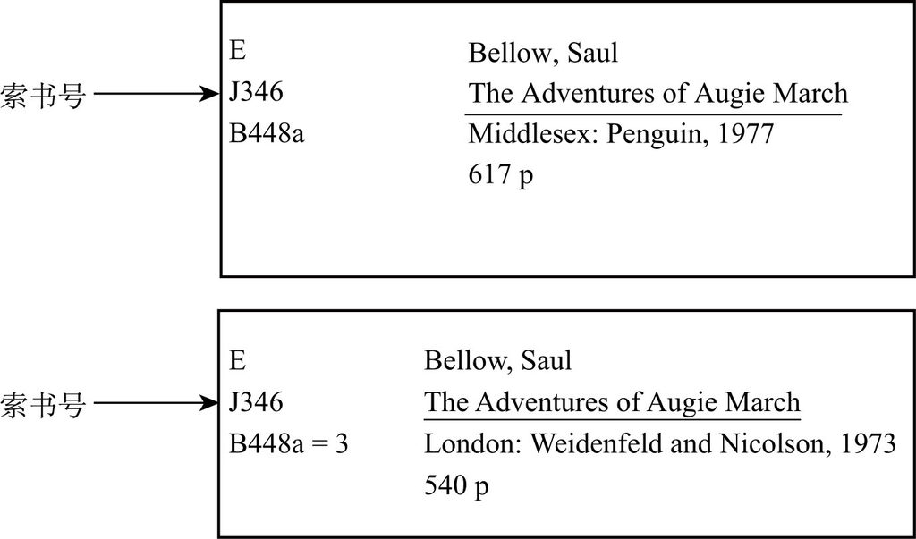

范文4

在**作者目录卡** 中的**Bellow** ，**Saul** 条目下面，你不但可以查到一张或几张关于The Adventures of Augie March 的卡片，你还可以查到索尔·贝洛写的其他图书的卡片。

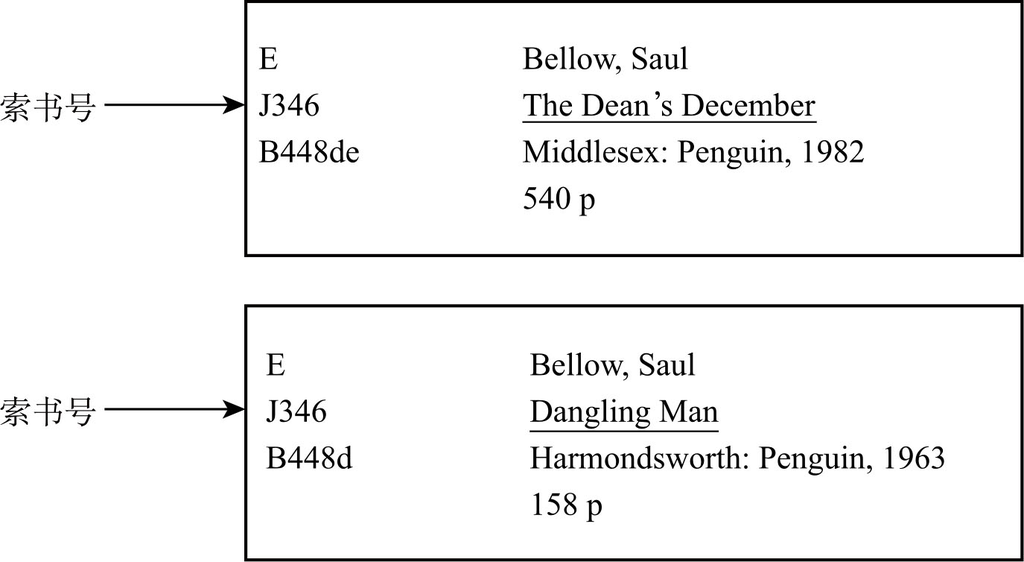

学生也应查阅**主题卡** 。这样可以找到对自己所选题目有用的文献，至少可以发现一些与自己所选题目相关的书目。

在我国，很多图书馆的主题卡分为二十几个大类，如哲学、经济学、法学、艺术、文学、语言、历史、地理等等。每一大类用一个字母来表示。以中国人民大学图书馆分类法（简称“人大法”）为范例，字母“J”代表文学，字母“I”代表语言学，字母“K”代表历史，字母“L”则代表地理。而根据中国国家图书馆的分类法（简称“中图法”），字母“I”代表文学，字母“H”代表语言学，字母“K”则代表历史和地理。

显而易见，这些分类都是比较笼统的，主要对图书馆的图书收藏与管理有用。要找到自己研究所需要的文献信息，还有必要到一些主题分类比较专业的图书馆去查阅。

下面这张卡片在美国图书馆的电脑上通常可以见到：

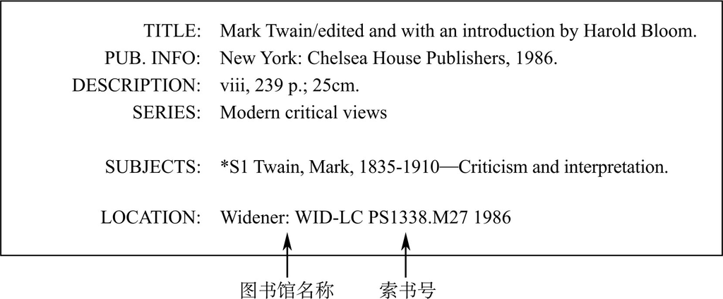

如今，你也可以在互联网上查阅自己所需要的文献信息：先登录某个图书馆的网站，输入自己想要查阅的书名、作者名或所需信息的一个或几个关键词，你将会查阅到大量的文献信息。

诸如Encyclopaedia Britannica 和Encyclopedia Americana 这样的百科全书也非常有用。学生应该阅读书中所有与自己所选题目相关的条目，还要特别留意每一条目后面所列的参考书目。读者往往可以从这些书目中收集到一些极其有用的书目。

对于英语专业的学生，下列参考书也很有用：

World Bibliography of Bibliographies

Bibliographical Index

A Guide to English and American Literature

The New Cambridge Bibliography of English Literature

Oxford Companion to English Literature

Oxford Companion to American Literature

当然，如果你对收集资料毫无经验，不知从何做起，你总是可以找图书馆资料人员寻求帮助。

找到自己所需的资料卡片或书名后，应将这些书名全都抄录下来，最好抄在自备的卡片上。事实上，这样做就是为自己的论文准备参考书目。随着阅读量的不断增大，新的书名会不断出现，参考书目也就会随之不断地得到扩充。

课堂练习3 到图书馆查找下列问题的答案。

1．图书馆的图书是如何排列的？

2．你只知道下面两本书的书名，如何查找这两本书？

1）A Doll's House

2）The Color Purple

3．有人告诉你，E. M. Forster可能对你的研究有用，而你除了这个名字外对E. M. Forster一无所知，你如何查找所需要的相关信息？

（2）书目卡片

做参考书目时，最有效的办法是为每一本可能对你有用的书做一张书名卡片。与你的选题有关的书籍可能有几十甚至几百本，你显然不可能用到所有卡片上的书籍。然而，开始阅读之前为每一本可能对你有用的书做一张书名卡可以节省你的时间。卡片便于整理，你还可以随时增添新的内容或除去那些实践证明对你无用的资料。卡片应按英文字母顺序排列。这样，最后整理参考书目时可以节省时间，因为参考书目必须按英文字母顺序排列。

做参考书目时，要确保每张书目卡片均包含下列各项内容，并确保格式正确：

a．书的完整的索书号：你如果不能正确地抄下完整的索书号，你就不能找到所需要的书籍；

b．作者姓名（姓在前，名在后，姓与名之间使用逗号）：姓名之后使用句号（.）；

c．书名：书名应使用斜体或在其下方划一条直线（下划线），书名后使用句号（.）；

d．如果是一部选集中的一篇文章、一首诗、一个短篇故事或一个剧本，则要写出文章、诗、短篇小说或剧本的篇名，篇名后使用句号（.），篇名前后使用引号（""）；

e．出版社所在的城市：城市之后使用冒号（:）；

f．出版社：出版社之后使用逗号（,）；

g．出版日期：日期之后使用句号（.）。

有些书目卡片需要包括更多的内容。如果是选编本或译本，卡片上还必须有**编者** 或**译者** 的姓名。如果一本书有数个版本或是修订本，这些信息也应在卡片上标明。如果一部书有数卷，你还需要标明这部书的总卷数及你所需要的卷号。

范文5

[figure not shown]

有关书目的格式请参看本章“**III．格式** ”的“**4．参考书目** ”一节。

2）阅读

书籍、杂志、报纸和互联网是获取信息及原始资料最主要的来源，阅读是收集资料的主要手段。

阅读时，要尽可能在最短的时间内找到并评估有用的资料。要学会**快速并用批判性的眼光阅读** 参考书。在大多数情况下，没有必要从头至尾阅读一篇文章或一本书。拿到一本书后要首先翻阅书前目录或书后索引，从中找到对你可能有用的章节。浏览与你的题目关系不大的部分，然后重点阅读你所需要的内容。有时，你花费很多时间读一整本书，却没有得到可以用在论文中的任何资料，不免会产生“时间白费，一无所获”的感觉。其实，你大可不必过分失望。你至少知道了这本书对自己目前的研究题目没有参考价值，这本身就是一种收获。况且，你现在知道了这本书的内容，以后也许会派上用场。

在某一本书中找到有用的资料后，你还须考虑资料的**可靠性** 。如果资料来源不可靠，就不会有什么价值。因此，有必要查阅评论家们对此书及其作者的有关评论。要尽可能找到此书**最新的版本** 。还要将不同书中对同一论题的观点进行**比较研究** 。应该确保你所得到的资料**没有过时** ，**不带偏见** 。

课堂练习4 回答下面两个问题。

1．什么是正确的阅读方法？

2．如何确保自己所获取的文献信息不过时，不带偏见？

3）做笔记

很少有人能够对自己读过的所有东西做到过目不忘；也很少有人能够不做笔记却写出好的论文来。

（1）做笔记的要求

a．笔记要**做在卡片** 或**活页纸上** ，而不要做在笔记本上。原因很简单：卡片便于随时调整顺序，重新排列；而笔记本上的页码却是不能随意变动的，除非你把它们撕下来，变成卡片。

b．**一张卡片上只做一条笔记** 。一条笔记只记录一件**事** 、一个**想法** 或一个**观点** 。如果你将两个事实、想法或观点放在同一张卡片上，其中之一就有可能在你不断积累起来的笔记中被埋没或丢失。除此之外，在你一次次整理笔记时，你会发现你不得不重新抄写第二个事实、想法或观点，或者得把卡片一分为二。因为在按照一定的系统将卡片归类时，卡片上的两条笔记很可能并非属于同类。

c．**要有选择性** 。对于那些你和你的读者已经熟知的事实或观点不必浪费时间和精力去做笔记。譬如说，乔治·华盛顿是第一任美国总统，这是人们熟知的一个事实，没有必要做卡片。

（2）笔记的内容

笔记的内容应该是**那些一般不为人所知却又与你的题目紧密相关的** 事实、想法或观点。你所做的笔记肯定会大大超过你的论文所需要的数量。但是，你若想进行高质量的学术研究，就应该对你的题目做尽量广泛、深入的调查研究，你实际并不需要的笔记待以后剔除不迟。其实，多做几条“多余”的笔记要比开始撰写论文后却发现自己的论据还不够充分，从而不得不到图书馆重读某本书或某篇文章要容易得多。

然而，你也不应该随意地做笔记，应该做到有的放矢。你开始研究时已经有了题目，或者至少对你要论述或证明什么有了一个大概的想法。你的想法越早成形，你的笔记就越有针对性，做笔记所用的时间也越少。如果发现自己在阅读的初期做了太多的笔记也不必忧虑。你的选题对你来说毕竟是一个相当新的领域，你读到的东西看起来都是很重要的，因此做很多笔记也是很自然的。随着阅读量的增加，你很快就会从资料中找到重点，做笔记也就会随之而更具有针对性和选择性。

尽早地缩小自己所选题目的范围，你就可以走好做笔记这一步。

（3）笔记的出处标示

每一条笔记都应包含**两项内容** ：一是**事实** 、**想法** 或**观点** ；二是这些事实、想法、观点的**确切出处** 。你的书目卡上会有资料出处的全面而详细的内容，因此你只需在笔记卡片上简要标明资料的出处，以便于你找到书目卡上的记载。通常，标明该资料所属作品的**作者的姓** 及笔记内容**所在页码** 就够了。有时，你会读到同一作者的两部作品。在这种情况下，你就需要标明作者的姓及作品的缩写书名以示区别。如果作者姓名不详，则要标明书名或文章题目的缩写。

如果笔记内容出自某一杂志，仅标明杂志名称是不够的。譬如说，你有可能使用Time （《时代》）杂志上的数篇文章，而这些文章又不是刊登在同一期上。如果你在笔记卡片上只标明Time 杂志，你就不可能很容易地找到书目卡上相应资料的出处。书目卡上对你所使用的杂志上的每篇文章都应有单独的出处资料，包括作者姓名、文章题目、杂志名称、期号、页码等等。因此，你的笔记卡片上至少应该标明杂志名称、期号及页码。

（4）笔记的种类

笔记的种类大致有三种**：直接引语、转述、摘要** 。所谓直接引语是指一字不差地抄录某人对某一论题的精辟论述。转述是指用自己的话语解释某人对某一论题的论述。而摘要则是指用自己的话语将大量的信息资料加以概括和提炼。无论采用那种方式做笔记，都必须注明资料的出处。

范文6 直接引语

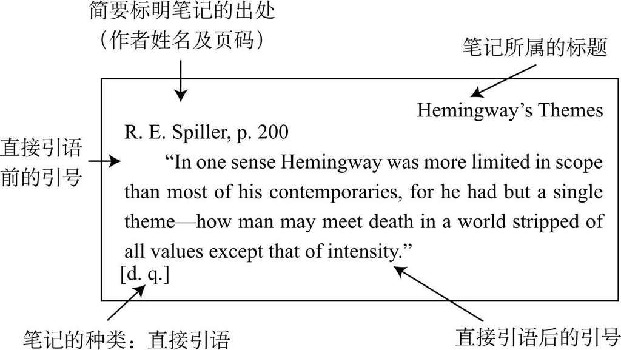

范文7 转述/意译

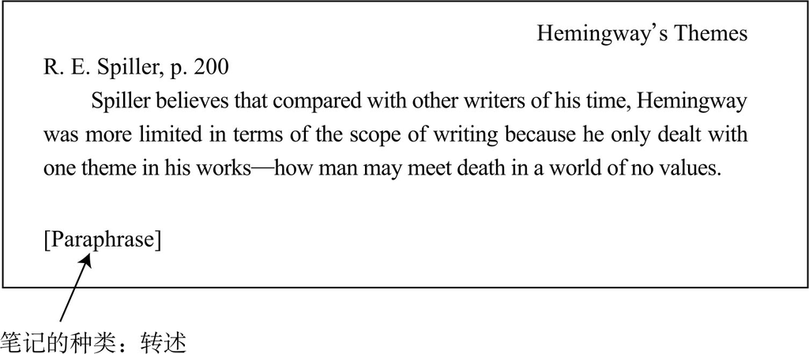

范文8 摘要

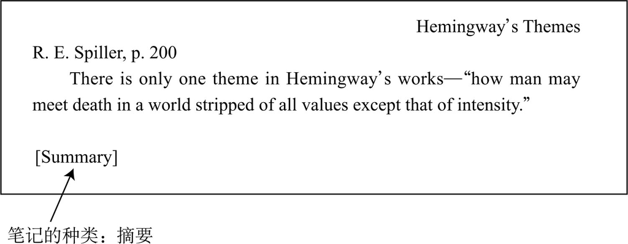

（5）直接引语的抄录

直接引语必须加引号。你写论文时参考的笔记可能是一个月或更早以前做的，直接引语不加引号就有可能导致你混淆自己和原作者的话语。

抄录直接引语时还应牢记：要一字不差地抄录原文。如果原文有明显的错误，应照抄错误，并在后面加［sic］标记。sic是拉丁文，意思是“原文如此”。如果笔记是用打字机或手写的，就需要在sic一词下面划一条直线；排印时，sic一词则应使用斜体字（非英语的词通常都用斜体字或字下线）。

如果你只想抄录某一页上的一部分文字，也就是抄一个段落，然后跳过一两段，再抄录下面的一段，此时你应该在整段省略处做出标记，从卡片的左边到卡片的右边连续使用圆点，点一整行。我们可以把这种标记称为“省略号”，但这种省略号不是英语中所使用的三点（...）省略号，而是一整行圆点。

如果你省略的只是一两句话或一句话中的几个词，你只需在省略处使用“...”即可。如果你省略的是一个句子的开头部分，引号须放在省略号之前；如果你省略的是一个句子的结尾部分，引号须放在省略号和句尾标点（句号、问号或感叹号）之后。

使用省略号时须注意两点：第一，**使用省略号时须确保原文的意思不变** ，譬如原文是This was not the most important cause of the war，如果使用省略号省去not这个词，那就是不忠实于原文了。第二，**使用省略号之后须保证句子的完整性** ，句子中的重要成分如主语和动词不能省略。

抄录直接引语时，有时因为你所抄录的原文脱离了上下文，有必要对某个词或某个日期加以说明。譬如说，代词就需要加以说明。在有上下文时，He suffered extreme hardships中的He这个代词的所指是非常清楚的。而当把这个句子抄录在卡片上，脱离了上下文的He的指代就须加以说明。如果你需要在直接引语中插入一个词、短语或数字，应将它放在方括号内，不要放在圆括号内：如He suffered extreme hardships.这一句在笔记卡片上就应是He [Marx] suffered extreme hardships.原文In that year, Karl Marx and Friedrich Engels published the Communist Manifesto .中的In that year脱离了上下文时，所指的年份不清楚，因此也需要对此加以说明如下：In that year [1848], Karl Marx and Friedrich Engels published the Communist Manifesto .

**直接引语** 的使用**不宜过多** 。笔记的大部分应该是转述或摘要。为了避免无意的抄袭嫌疑，应在每张笔记卡片上标明笔记内容是转述还是摘要。当然，如果当时由于时间有限而来不及细想如何转述为好，你也可以先把原文抄录下来，做好直接引语标记，过后再设法用自己的话语转述原文。

做笔记还有一点需要注意：不要想当然地以为印在书上或杂志上的东西就一定是真实的。要仔细**分辨哪些是作者所陈述的事实，哪些是作者的看法** 。Henrik Ibsen was a Norwegian dramatist和Henrik Ibsen was the greatest dramatist that ever lived是截然不同的两句话：前者陈述事实，而后者却是作者对易卜生的评价。有时，数位作者对同一事实都有不同的陈述。在这种情况下，你就应该先做一番快速调研。查阅一本公认权威的参考书或百科全书或许是解决此类分歧的好办法。但是如果你没有足够的依据来决定哪一种观点正确，此时最明智的做法是坦诚地承认分歧，并将不同的观点如实地陈述出来。

（6）笔记的整理

当你觉得你已收集到了足够的资料，可以开始构思论文，或认为其他的资料只是重复你已经收集到的信息时，你就可以暂停阅读，开始整理笔记。

首先要把自己做的笔记重读一遍以加深印象；同时按照不同的标题将笔记归类。不必为每张卡片都设计一个新颖别致的标题，应将**数张卡片归于同一个标题之下** 。譬如说，你做的笔记与美国著名作家海明威有关。你设计的标题可以是“海明威和迷惘的一代”、“海明威的生活经历”、“海明威的作品”、“海明威对美国文学的贡献”等。有些标题还可以进一步分为若干个分标题，如“海明威的作品”这个标题可以进一步分为“海明威作品中的主题”、“海明威的创作风格和技巧”和“海明威论创作”等。

你对每一张卡片的归类也许会有所改变，因此最好先用铅笔在卡片上标明其所属的标题，以便你随后变更卡片上的标题，直到你最后决定如何使用每张卡片时为止。最终确定每张卡片的用途后，应**在每张卡片的右上角** 用钢笔或圆珠笔**简要** 地写上其所属的**标题** ，以便于进一步整理笔记，以及撰写论文时参考。

重读、归类笔记可以帮助你分析和评估已有的资料。此时你会发现有些笔记对你的论题毫无用处，应该丢弃；还有一些笔记则需用其他资料进一步充实。你也可能会发现一张卡片上的观点和另一张卡片上的观点相左。学者们对某一问题持有不同的看法是很常见也很正常的事。你可以进一步阅读有关书籍，分析资料，最后确定哪一种观点是正确的。

此时，你对自己打算论述的问题已经有了相当深入的了解。你应该再回到图书馆去，更有针对性地查阅资料。凡是与自己的论题有关的资料应尽量收集齐全。

课堂练习5 下面一段直接引语出自Elisabeth B. Booz所著A Brief Introduction to American Literature 一书，请再为这段话做两张卡片，一张是转述，另一张是摘要。

直接引语

F．Scott Fitzgerald's Themes

Elisabeth B. Booz, p. 66

"Fitzgerald dealt most astutely with the double theme of love and money. He understood the corrupting relationship between the two better than any other American novelist."

[d. q.]

作业2 去图书馆找到至少五本与你的研究题目有关的图书，做五张笔记卡片，其中两张是直接引语，两张是转述，一张是摘要。

3．分析资料，构思、制定提纲

确定了论文的题目并收集到足够的资料以后，下一步要做的就是要分析资料，对论文进行整体构思，拟定论文主题，并制定出论文的提纲。

1)主题

主题是论文的中心思想。论文没有主题就好似一个人没有心脏。论文的主题通常是**一句话** ，阐明论文作者对自己的研究课题所持的**主要观点** 。在某种意义上来说，论文的主题是论文作者对自己在论文中所提出的中心问题的回答。拟定主题的过程也是论文作者为自己的研究课题进一步定位定向的过程，从而确保自己在论文提纲的制定和论文的撰写过程中不偏离主题。换言之，主题是论文的指南。你的论文应以此为中心，你要为主题提供依据，证明主题的正确性，反驳与其相对立的论点并指出其错误所在。

在写作过程中，你原来的设想通常都会有所改变，此时你应该立即修改你的主题。

陈述论点时，论文作者**只应陈述论文的中心思想** 。诸如“论文作者意在……/ I intend to...”，“论文的目的是……/ The purpose of this paper is to...”，“本人的研究方法是……/ The method of research I am going to adopt is...”等表述不应在主题陈述中出现。

范文9

**题目:** Confucius' Main Teaching Methods and Their Applicability to China's Education Today

**主题:**

Confucius' elicitation method of teaching and that of teaching students in accordance with their aptitude are still applicable to China's education today.

课堂练习6 仔细研究下面的论文题目及论点，提出你的看法。如果你认为论点不妥，请修改。

**题目：** Santiago and Hemingway's Code Hero

**主题：**

The author of this paper has made a careful study of Hemingway's famous novel The Old Man and the Sea and intends to prove that the protagonist of the novel Santiago is Hemingway's typical code hero who best demonstrates the code of "grace under pressure".

2）制定提纲

提出主题之后，紧接着要做的就是制定论文提纲。提纲是一篇论文的框架，提纲可以帮助你整理自己的观点，编排好收集到的资料。然而，你也不要让提纲束缚自己的思想。在撰写论文的过程中，头脑中常会有新的想法出现，这些新的想法也许会使你的思维转向。出现此种情况时，要毫不犹豫地修订已拟定的提纲。在论文完成一半甚至全部完成之后修改论文提纲也是常有的事，有时甚至还会修改论文的主题或题目。

如果你的每张笔记卡片上都有简要的标题，制定提纲就不是一件难事。这些标题只需稍加整理和排列就会变成你的论文提纲。

论文提纲主要有两种形式。一种是**题目式提纲** ——提纲中的大小标题都用短语来表述；第二种是**句子式提纲** ——提纲中的大小标题都用完整的句子来表述。论文作者可选择其中的任何一种形式，但不可混用两种形式。

论文提纲中的各个部分通常是依照下面的顺序标示制定的：

Ⅰ．

A．

1.

a．

(1)

(a)

Ⅱ．

A．

1.

a．

(1)

(a)

Ⅲ．

…

制定论文提纲时，须严格按照有关的规定和要求去做。在制定提纲之前，可以先参阅本书第五章中的“**提纲类型** ”一节。

下面所展示的是一个句子式提纲。

范文10 句子式提纲

The Independence of Jane Eyre

**Thesis statement:**

Jane Eyre tried to preserve her self-respect, independence and self-sufficiency at every stage of her life, both in struggling with social pressure and in resisting the temptation of passion.

**Outline:**

Ⅰ．At Gateshead, Jane began to realize the importance of independence.

A．Jane, a poor orphan of ten, did not evoke sympathy from other people, because she was not pretty.

B．Jane learned from John Reed that dependence and incompetence invited nothing but scorn.

C．Jane began to realize in the "red room" that she needed to be saved from her blind fear of authority and be self-reliant.

Ⅱ．At Lowood Institution, Jane gained strength from her teacher and fellow students to achieve her independence.

A．Jane learned from Maria Temple the value of independence.

B．Jane learned from Helen the importance of duty and self-control.

Ⅲ．At Thornfield Hall, Jane showed her independence fully.

A．Jane worked as a governess to support herself.

B．Jane tried to regain control over her passion when she felt her loss of independence after she accepted Rochester's love.

1．She wanted to be his friend and companion, but not someone in his possession.

2．She told him she preferred his rude openness to his flattery.

3．She remained economically independent by maintaining her job as Adele's governess.

4．She refused to have sexual relationship with Rochester because she feared that she would lose her independence because of passion.

5．She left Rochester because she did not want to lose her integrity and become his mistress.

Ⅳ．At Moor House, Jane learned the pleasure of self-sufficiency.

A．Jane became spiritually stronger and more confident through her friendship with the two sisters, Diana and Mary Rivers.

B．Jane gained social respect by teaching in the village school.

C．Jane rejected St. John's offer of marriage because she did not want to live as a tool to serve God.

V．At Ferdean, Jane married Rochester as his equal after his wife's death and his loss of all his property in a big fire.

以上提纲中所有标题都是用完整的句子表达的。如果你想选用题目式提纲，可参阅本章最后一部分“论文范文”中的提纲。论文的提纲还有其他种类，这里所介绍的是最常见的两种。

**在撰写本科毕业学位论文或硕士学位论文时，建议把“提纲”（Outline）改为“目录”（Table of Contents）。** 请参阅本章第IV部分——范文。

课堂练习7 修改下面的提纲，并注意两点。

·提纲中同一层级的标题要用平行结构表述；

·同一层级的小标题应该具有同等重要性。

有关孔子教学方法的论文提纲

Confucius' Main Teaching Methods and Their Applicability to China's Education Today

Ⅰ．A brief introduction to Confucius

A．A great philosopher and statesman

B．A great educator

Ⅱ．Confucius' two main teaching methods

A．The elicitation method

a．Foster the student's ability to learn by himself

b．Emphasizing the teacher's role in giving the student guidance

B．The method of "teaching students in accordance with their aptitude"

Ⅲ．Causes of the discontinuance of Confucius' teaching methods in modern China

A．The May 4th era

B．The "Cultural Revolution" period

Ⅳ．The Applicability of Confucius' teaching methods to China's education today

A．Problems in education today

a．Students are fed with knowledge

b．Students are taught in the same way without discrimination

c．The root of problems

B．The applicability of Confucius' teaching methods

a．Help students cultivate the habit of learning in an active way

b．Give students opportunities to practice what they have learned

c．Improve the ways of teaching so as to arouse students' interest

d．Increase elective courses to meet students' different interests

e．Set up more technical and vocational schools for students with different capacities

V．Conclusion

作业 分析你搜集到的资料，并对你的论文进行整体构思，找出焦点，提出主题，然后制定出论文的提纲。

题目：

主题：

提纲：

4．撰写初稿

提出论文的主题并制定好提纲之后，你就可以开始撰写论文初稿了。撰写论文初稿就是按照你制定的提纲，把你的论点变成一篇论点明确、结构严谨、条理清楚、论述透彻的学术论文。在论文定稿之前，你也许还需要写第二稿，甚至第三稿。

你应把所学到的有关写作的知识和要求应用到自己的论文写作中。在撰写论文的过程中，有几点需要特别注意。

1）用自己的话语

第一点要求就是写论文时要用自己的话语。在写作论文初稿的过程中，你肯定会使用笔记卡片上的资料。要认真地研究笔记的内容，确定如何使用这些笔记。如果你只是简单地将你的笔记内容“串”起来或拼凑起来，那你就不是在写论文，而是在抄笔记!论文必须是你自己的东西——自己的观点，自己的篇章结构，论文中的文字绝大部分也应该是你自己的话语。你的笔记可以用来支持你的观点，但笔记的出处必须注明。否则，你就不是一个诚实的学者，你的论文也就不是一篇真正的研究论文。

用自己的话语写论文说时容易做时难。你总想借用别人的话来为自己服务。别人的话好像有无比的说服力，其诱惑有时很难抗拒。

下面的几段内容是从一篇学生的论文中节选出来的。他所做的仅仅是把笔记或从别人那里借来的资料“串”了起来。

范文11

W．E. B. Du Bois believed that "the problem of the twentieth century is the problem of the color line." (Du Bois xiv)

Du Bois became aware of racial differences at an early age. He related this experience vividly:

The exchange [of children's calling cards] was merry, till one girl, a tall newcomer, refused my card—refused it peremptorily, with a glance. Then it dawned on me with a certain suddenness that I was different from the others; or like, mayhap, in heart and life and longing, but shut out from this world by a vast veil. (Du Bois 16)

Du Bois felt that dreams of opportunities and fulfillment were reserved solely for whites.

The shades of the prison-house closed round about us all: walls strait [sic] and stubborn to the whitest, but relentlessly narrow, tall, and unscalable to sons of night who must plod darkly on in resignation, or beat unavailing palms against the stone, or steadily, half hopelessly, watch the streak of blue above. (Du Bois 16)

When his infant son died, Du Bois was depressed, but yet he rejoiced because his son would not have to endure life behind "the veil." (Du Bois 155)

All that day and all that night there sat an awful gladness in my heart—nay, blame me not if I see the world thus darkly through the Veil, and my soul whispers ever to me, saying, "Not dead, not dead, but escaped, not bound, but free." No bitter meanness now shall sicken his baby heart till it dies a living death, no taunt shall madden his happy boyhood. Fool that I was to think or wish that little soul should grow choked and deformed within the Veil! ... Well sped, my boy, before the world had dubbed your ambition insolence, had held your ideals unattainable, and taught you to cringe and bow. Better far this nameless void that stops my life than a sea of sorrow for you. (Du Bois 155-156)

这位学生只是把自己的笔记抄到了论文中。既然这篇论文的目的并不是要向人们展示或分析杜·波伊斯（W. E. B. Du Bois，1868－1963，美国第一个黑人社会学家、20世纪上半叶最有影响的黑人领袖）的写作风格，而是要将他和华盛顿（Booker T. Washington, 1856－1915，著名黑人教育家、改革家）就黑人问题所持的不同观点进行比较研究。那么，从杜·波伊斯的自传上抄录大段引文无助于这位同学阐明自己的观点，只不过占用了论文相当的篇幅罢了。如果这位学生主要用自己的话语，论文的论点就可能被表述得更清楚些。请看：

范文12

W．E. B. Du Bois, who believed that "the problem of the twentieth century is the problem of the color line," (Du Bois xiv) learned as a child that he could be rejected simply because of the color of his skin. Later, he came to believe that dreams of opportunities and fulfillment were reserved solely for whites, and he compared the life of blacks in America with that of prison inmates. Indeed, he grew so bitter about the plight of blacks that he rejoiced when his infant son died because the child would never have to experience the prejudice that he had felt. (Du Bois 16, 155–156)

【 **分析** 】

在修改后的这段文字中，作者没有使用过多的直接引语，而是将原来的几段文字压缩为一段，把杜·波伊斯的观点阐述得清楚明了。修改后的这段文字同时避免了过多的注释，文中注释从原来的五条减为两条。修改后的这段文字和原先的几段文字相比，显示出了作者对资料更高的驾驭能力。一般说来，除非论文旨在研究作家的创作风格，论文中的直接引语**不应超过论文总体的10%** 。

2）使用恰当的时态

论文中时态的使用对很多学生来说是个难题，而时态的使用不当会使论文读者感到迷惑，甚至造成误解。现提出几点以供参考。

（1）如果你所讲述的是**过去的一件事或一个概念** ，论文中的基本时态就应该是**过** **去时** 。

请看下面一段：

范文13

After slavery, the trials of emancipation **had** a disruptive effect on the black family as a unit because blacks **were** suddenly **expected** to change many of the social values taken on when they **were** slaves. One of these **was** the idea that the male should be the family head and chief provider. But, as with all new social values in any culture, this idea **was** slow in gaining acceptance by blacks; thus matriarchy is still an essential feature of today's black family.

（2）**人物传记、生平细节** 通常也应使用**过去时** 。以下面一段记叙孔子的文字为例：

范文14

Confucius (551 BC–479 BC) **devoted** nearly fifty years to teaching and formulated a comprehensive and profound theory on education. He **was** the first great Chinese public teacher, who **made** teaching a profession, and thus **popularized** education. He **was** the first in China who openly **stated** that in education there should be no class distinction, and thus **opened** the door of education to all...

（3）**按时间顺序讲述一个故事时** ，应使用**一般现在时** 。但如果故事中某一情节发生在已提到的某个情节之前，则需要使用一般过去时或现在完成时。请看《牛津英国文学指南》中关于 **Jane Eyre** 的词条：

范文15

The heroine, a penniless orphan, **has been left** to the care of her aunt, Mrs. Reed. Harsh and unsympathetic treatment **rouses** the spirit of the child, and a passionate outbreak **leads** to her consignment to Lowood Asylum, a charitable institution, where after some miserable years she **becomes** a teacher.Thence she **passes** to be a governess at Thornfield Hall to a little girl, the natural daughter of Mr. Rochester, a man of grim aspect and sardonic temper. In spite of Jane Eyre's plainness, Rochester **is fascinated** by her elfish wit and courageous spirit, and **falls** in love with her, and she with him. Their marriage **is prevented** at the last moment by the revelation that he **has** a wife living, a raving lunatic, kept in seclusion at Thornfield Hall. Jane **flees** from the Hall, and after nearly perishing on the moors **is taken** in and cared for by the Rev. St. John Rivers and his sisters. Under the influence of the strong personality of Rivers, she nearly **consents** (in spite of her undiminished love for Rochester) to marry him and accompany him to India. She **is prevented** by a telepathic appeal from Rochester, and **sets** out for Thornfield Hall, to learn that the place **has been burnt** down, and that Rochester, in vainly trying to save his wife from the flames, **has been blinded and maimed** . She **finds** him in utter dejection, **becomes** his wife, and **restores** him to happiness.

（4）**评论** 某本书的内容或是某位作家的语言及其风格时，应使用**一般现在时** 。

范文16

Saul Bellow **is** **regarded** by many as "probably the most important living American novelist." **Seize the Day** **is considered** to be Bellow's greatest achievement, and one of the great short novels written by an American.

（5）**引用** 某位**权威人士** 的话语时，**转述动词** （reporting verb）应使用**一般现在时** 。

范文17

Sinclair Lewis (1885–1951), the first American Nobel Prize winner for literature, says that"Dreiser...more than any other man, marching alone, usually unappreciated, often hated, has cleared the trail from Victorian and Howellsian timidity and gentility in the American fiction to honesty, boldness and passion of life."

3）事实和观点要相辅相成

论文中的事实和观点就如同人们身上的肉和骨头一样同等重要，事实与观点的完美结合是所有优秀论文的共同特点。

如果一篇论文只罗列事实而不加分析，没有观点可言，那么这篇文章就会显得苍白无力。即使这些事实件件生动有趣，读者也不会明白作者罗列事实的意图何在。

如果一篇论文表述很多观点，甚至是有独到之处的观点，然而没有相应的事实来证实这些观点，这篇文章同样会显得苍白无力。读者也许会被文中那些新颖的观点吸引一时，但他们很快就会产生疑问，怀疑这些观点是否可靠、是否经得起推敲。他们甚至会觉得论文作者撰写这样一篇论文是不够严肃、不够诚实的。

一篇论文必须**将事实和分析完美结合** ，既有真实可信、有据可查的事实，又有以事实为依据而得出的令人信服的**观点** 。

4）注意论文的逻辑性与篇章结构

论文中的事实和观点安排得当才具有说服力。应围绕主题，一环扣一环、符合逻辑地表述事实和观点。如有可能，一个段落应从一个主题句（a topic sentence）开始，然后再进一步阐述主题句中所表述的观点。进而言之，一篇论文应有一个简要地阐明论文要点的开篇段落，然后在主干部分的各段中将这些要点逐一阐述。有纲有目，条理清楚的内容安排有助于读者领悟全文。

5）语气要客观，避免主观色彩

论文的目的在于对某些客观事实或问题进行研究，其结论只能在分析相关资料的基础上得出，而不是依据作者个人的好恶信口而来。论点有充分的事实根据，表述冷静、客观，对读者才有说服力。因此，在论文中无需像在讲述个人经历的文章中那样频繁地使用“我”或“我们”这样的代词。

6）选择恰当的文体

对文体的选择没有严格的限制，主要根据作者的喜好，因人而异。但对于学习写论文的同学来说，最好**选用** 本书第七章中介绍的那种**正式／书面文体** 。论文中不要使用缩略词，要避免诸如Well，now I'd like to discuss...一类的句子。

论文的语言要清楚、易懂、流畅。论文的文字不应华丽，不应令人费解。华丽的辞藻和不必要的复杂句式只能分散读者对主题的注意力，通常也枯燥乏味、令人生厌。要**设法把引语自然地融入到自己的论点表述中去** ，以保证论文语言流畅，文风始终如一。

作业4 遵循论文写作的相关要求，撰写论文初稿。

5．修改、定稿

完成论文初稿只走完了整个论文写作过程的一半，也许需几易其稿才能确保论文前后连贯、清楚明了。修改论文初稿和本书第五章中提到的修改作文一样，应**首先从内容着手** 。要保证论文中论点前后一致，观点展开合乎逻辑。事实和观点要安排得合理有序，令人信服地证明你的论点是正确的，你的结论是合理的。删去那些与论题和论点不相关、无关紧要或前后重复的事实和观点。你可能需要加一些过渡词语或过渡段落来理顺句与句之间、段与段之间的关系，使论文更连贯、更流畅。如果发现有些地方的表述逻辑性不强，甚至令人费解，就有必要对某些短语、从句、整句或段落进行重新组合或安排。

你还应该注意论文语言是否简洁，句子的种类是否多样等等。

此外，你还应该确保改正论文初稿中所有的标点、语法、拼写、文中注释和参考书目的格式等技术性错误。最后将修改好的论文打印出来，仔细校对一遍。

完成以上各项任务后，你的论文就大功告成了。

作业5 对照下列七条，仔细修改自己的论文。

1．你论文中的观点前后一致吗？

2．你论文中论点的推论符合逻辑吗？

3．你论文中的事实和观点安排得合理有序吗？

4．你的论文前后连贯、过渡自然吗？

5．你论文的语言正确、流畅吗？

6．你的论文中的注解和参考文献的格式是否正确？

7．你的论文仔细校对过吗？技术性的错误都改正了吗？

III．格式

1．论文的结构

一般说来，一篇论文由**五个部分** 组成：**主题和提纲** ；**引言** ；**主体（带文中注释）** ；**结论** ；**参考书目** 。

1）主题和提纲

**主题** 是论文的中心或焦点，明确地陈述论文要证明或坚持的主要观点。它通常用**一句话** 表达。这句话应该是具有**论证性质** 的，而不是描述性的；诸如This paper intends to...一类的话只应放在引言中，而不应在主题中出现。

陈述主题后，紧接着是论文的提纲。主题和提纲可以保证作者在论文写作过程中不偏离主题，也可以使读者对论文的主要观点和结构一目了然。

2）引言

作者通常在引言中说明自己撰写论文的**动机、意图或目的** ，以及论文所涉及的**范围** 及其**焦点** 。引言部分的一项重要内容是**文献综述** ，向读者提供必要的背景知识，介绍与自己的研究课题相关的文献，尤其要说清楚哪些方面的研究已做得相当深入，哪些方面的研究还有待进一步探讨。换言之，引言应该让读者明白作者为什么要写这样一个题目，打算涉及的范围有多大。作者在引言中可以将论文即将回答的问题或准备阐述的观点先提出来，也可在引言中说明自己拟用的研究方法或理论。

总的说来，引言应该粗略地说明论文的主要观点，以引起读者的兴趣。引言不必很长，一段或两段即可。

3)主体

作者在论文的主体部分详细阐述自己的论点，这部分最重要，所占篇幅也最大。最好将论文的主体部分再分为几个部分，可加也可不加小标题；语言学论文通常加小标题。应该避免使用太多的小标题或各种类型的数码标示，因为它们有时反而会帮倒忙使读者感到迷惑不解。

4)结论

论文的结论应和引言相呼应，总结或复述引言中提出的论点或回答引言中提出的问题。

5)文中注释和参考书目

文中注释也可以叫做插入性注释，即在某一文献在论文中出现的地方添加一个圆括号，在圆括号中注明该文献的出处。

参考书目置于论文的正文后，单独成页。

2．引文的使用

引文分直接引文和间接引文两种。直接引文就是使用原文。在论文中使用直接引文时，要做到准确无误，和原文丝毫不差（包括标点在内），而且必须使用引号。间接引文是作者用自己的话语对原文的阐释、意译或总结。

实践证明，恰当地使用引文对学生是一个比较大的挑战，尤其是使用直接引文时，问题较多。

下面各点供读者参考。

1）使用引文的规则

（1）尽量少用，论文中的直接引文**不应超过论文总体的10%** ，研究作家创作风格的论文除外；

（2）要**将引文自然地融入论文** 之中；

（3）要**注明出处** 。

2）需要使用直接引文的几种情况

不使用任何直接引文也可以写出论文。然而在有些情况下，直接引文则非用不可：

（1）如果你写的是一篇文学论文，你可能想评介某位作家的创作风格，这就需要分析作品的某些章节。在这种情况下，你当然必须引用你准备分析讨论的那些章节的原文。

下面的几段文字取自一篇论文。论文的作者认为美国著名作家赫尔曼·梅尔维尔（Herman Melville）在创作他的代表作《白鲸》（Moby-Dick ）时受到了英国著名作家塞缪尔·泰勒·柯尔律治（Samuel Taylor Coleridge）的名作《古舟子咏》（"The Rime of the Ancient Mariner"）的影响。

范文18

One other image in Chapters 51 and 52 of Moby-Dick illustrates a slightly different aspect of the process of adapting Coleridge's images. In this image, Melville incorporates both the image and the mood of the source in Coleridge's work. It occurs while the Pequod is still at the Cape of Good Hope:

Few or no words were spoken, and the silent ship, as if manned by painted sailors in wax, day after day tore on through the swift madness and gladness of the demoniac waves.

Except that the ship is given motion, it is surely the Ancient Mariner's ship on which

Day after day, day after day

We stuck, nor breath nor motion;

As idle as a painted ship

Upon a painted ocean.

很显然，在这篇论文中，作者必须使用直接引文来说明柯尔律治对梅尔维尔的影响。

（2）如果原文写得很精彩，而其价值又在于作者的遣词造句，你也许有意引用其中的某一部分。英国哲学家及作家弗朗西斯·培根关于如何读书的著名论述也许是一个极好的范例：

范文19

Some books are to be tasted, others to be swallowed, and some few to be chewed and digested; that is, some books are to be read only in parts; others to be read but not curiously; and some few to be read wholly, and with diligence and attention.

（3）如果你引用的原著中的观点极易引起争议，甚至令人不能容忍时，读者也许会怀疑你是否歪曲了作者的原意。这种情况下，你就需使用直接引文。

3）如何恰当地使用直接引文

（1）需在论文中使用直接引文时，要尽力**将直接引文和自己的论点融为一体** 。当然，应该让读者明白你是在使用直接引文；但不应该因为使用直接引文而导致论文行文不流畅。请看下面一段文字：

范文20

Forster points directly to the need for myth: "Why has not England a great mythology?" he asks, and suggests that England's mythology "has not advanced beyond daintiness" because, unlike Greek mythology, it has not derived from the earth.

在上面这段中，作者把直接引文自然地融进了自己的句子之中。因此，除引号外，作者不需要给直接引文添加其他标点。如果在论文中使用的直接引文较长，标点的使用则取决于引文前面的引导词语。

（2）如果引文前的引导词语本身就是一个完整的句子，则应使用冒号：

范文21

In The Declaration of Independence Thomas Jefferson put down these well-known words:

We hold these truths to be self-evident: that all men are created equal; that they are endowed by their Creator with certain inalienable rights; that among these are life, liberty, and the pursuit of happiness; that to secure these rights, governments are instituted among men, deriving their just powers from the consent of the governed; that whenever any form of government becomes destructive of these ends, it is the right of the people to alter or to abolish it, and to institute new government, laying its foundation on such principles, and organizing its powers in such form, as to them shall seem most likely to effect their safety and happiness.

（3）如果引文前的引导词语不是一个完整的句子，应该把直接引文作为这个句子的其余部分处理，并使用恰当的标点：

范文22

According to Forster, "London was but a foretaste of this nomadic civilization which is altering human nature so profoundly, and throws upon personal relations a stress greater than they have ever borne before..."

范文23

It was written in The Declaration of Independence ,

that all men are created equal; that they are endowed by their Creator with certain inalienable rights; that among these are life, liberty, and the pursuit of happiness; that to secure these rights, governments are instituted among men, deriving their just powers from the consent of the governed; that whenever any form of government becomes destructive of these ends, it is the right of the people to alter or to abolish it, and to institute new government, laying its foundation on such principles, and organizing its powers in such form, as to them shall seem most likely to effect their safety and happiness.

从以上几个范文中可以看出，如果你使用的直接引文不长（范文20，22），你可以直接将引文插入你自己的句子或段落中去，但切记要使用引号将直接引文标出。如果你使用的直接引文较长（一般说来，一段**超过四行** 的引文就算较长的引文，范文21，23），你就需要将直接引文和自己的文字**分开** ，使其**独立成段** 。大段的直接引文的行距和论文其他部分的行距相同，**不需使用引号** 。独立成段就表明这是一段较长的直接引文。

大段的直接引文独立成段时，其左侧应比论文的其他部分向右多缩进四个字母，其上下应各空一行。

课堂练习8 把下面的三段话作为直接引文放置在恰当的上下文中。

1．I have a dream that my four little children will one day live in a nation where they will not be judged by the color of their skin but by the content of their character.

From "I Have a Dream...", a speech by Martin Luther King, Jr.

2．Five Principles of Peaceful Coexistence: mutual respect for territorial integrity and sovereignty, mutual non-aggression, non-interference in each other's internal affairs, equality and mutual benefit, and peaceful coexistence.

3．There are two Americas. One is the America of Lincoln; the other is the America of Teddy Roosevelt and the modern superpatriots. One is generous and humane, the other narrowly egotistical; one is self-critical, the other self-righteous; one is sensible, the other romantic; one is good-humored, the other solemn; one is inquiring, the other pontificating; one is moderate, the other filled with passionate intensity; one is judicious and the other arrogant in the use of great power.

—J. William Fulbright

作业6 写四段文字，其中两段要用直接引文（一长一短），其余两段用间接引文。

3．注释的使用

在论文中使用某原著中的观点或事实时，必须在文中注释中注明资料的来源。这一点使学生感到害怕，至少是感到不安，以为论文中几乎每句话都需加注。其实不然。

首先要**注明论文中所有直接引文的出处** 。同时也要注明那些**来自某些原著的非常** **识性的观点或事实的出处** ，即使你是使用自己的话语陈述这些观点或事实的 。

此时，你也许会由于使用引文和为引文加注这些“小事”所造成的麻烦而隐约地感到有些不快。然而，只有这样你的读者才能够分清论文中哪些东西是你自己的、哪些东西是引用别人的。如果在引文的使用和注释方面不够仔细认真，就有可能被认为有抄袭之嫌。

1）避免抄袭

抄袭是指使用别人作品中的事实、观点和文字时不注明出处。明目张胆的抄袭纯粹是偷窃或欺骗：让别人为自己代写论文，从某杂志上抄来一篇文章或从某书中抄来某一部分，而谎称文章为自己所作。大多数人知道这样做不对，不会如此行事。更常见的是“零星”的抄袭：这儿抄一句，那儿抄一段。然而，小的偷窃行为也是偷窃，零星的抄袭行为仍属抄袭。二者性质相同，只是程度不同而已。为了保险和自尊起见，应该牢记以下几条**规定** ：

（1）论文中的话语**要么是你自己的，要么是** 引自他人作品的**直接引文** ，没有中间路线可走。

（2）改变原作者作品中的几个词或几个短语不足以变他人的作品为自己的创作。

（3）**注释** 表明论文中事实或观点来自他人的作品。如果论文中的文字是来自另一位作者，除注释外，还须使用**引号** 。

请看下面的范文：

范文24

原文：

In 1925 Dreiser produced his masterpiece, the massively impressive An American Tragedy . By this time—thanks largely to the tireless propagandizing on his behalf by the influential maverick critic H. L. Mencken and by others concerned with a realistic approach to the problems of American life—Dreiser's fame had become secure. He was seen as the most powerful and effective destroyer of the genteel tradition that had dominated popular American fiction in the postCivil War period, spreading its soft blanket of provincial, sentimental romance over the often ugly realities of life in modern, industrialized, urban America. Certainly there was nothing genteel about Dreiser, either as man or novelist. He was the supreme poet of the squalid, a man who felt the terror, the pity, and the beauty underlying the American dream. With an eye at once ruthless and compassionate, he saw the tragedy inherent in the American success ethic; the soft underbelly, as it were, of the Horatio Alger rags-to-riches myth so appealing to the optimistic American imagination.

Richard Freedman, The Novel (New York: Newsweek Books, 1975) 104-105.

**学生的论文**

There was nothing genteel about Dreiser, either as man or novelist. He was the supreme poet of the squalid, a man who felt the terror, the pity, and the beauty underlying the American dream.

**评析**

**明显的抄袭。** 一字不差地抄用原文且**不加注释** 。

There was nothing genteel about Dreiser, either as man or novelist. He was the supreme poet of the squalid, a man who felt the terror, the pity, and the beauty underlying the American dream. (Freedman 104)

**评析**

**还是抄袭。** 只有文中注释是不够的 。文字是原作者的，只有在这段文字的前后使用**引号再对其加注** 才是正确的。

Nothing was genteel about Dreiser as a man or a novelist. He was the poet of the squalid and felt that terror, pity and beauty lurked under the American dream.

**评析**

**还是抄袭。** 改动或删去几个词并不能算是作者使用了自己的话语。

"Nothing was genteel about Dreiser as a man or as a novelist. He was the poet of the squalid and felt that terror, pity, and beauty lurked under the American dream."

**评析**

**不完全是抄袭，但是引文不正确或不准确。** 引号内的东西应与原文丝毫不差。然而，论文的作者却对原文做了一些改动，因此不应该使用引号。

By 1925 Dreiser's reputation was firmly established. The reading public viewed Dreiser as one of the main contributors to the downfall of the "genteel tradition" in American literature. Dreiser, "the supreme poet of the squalid," looked beneath the bright surface of American life and values and described the frightening and tragic elements, the "ugly realities," so often overlooked by other writers. (Freedman 104-105)

**评析**

**正确。** 论文的作者用自己的话语总结了原文的内容。脚注表明此处的观点来自他人的作品，同时，从原文中引用了几个短语也放在了引号之中。

2）文中注释的格式

传统的注释形式有两种：脚注和尾注。脚注置于相关文献出现页的底部，尾注则集中放在论文的正文之后，单独成页。现在最常用的注释形式是**文中注释（in-text notes）或** 叫做**插入性注释（parenthetical reference）** ，这种形式更方便，更实用。要标明自己在论文中使用了别人作品中的**事实、观点** 或是**引用** 了别人作品中的**文字** ，论文作者只需在某一事实、观点或引文在自己论文中出现的地方添加一个圆括号，在圆括号中注明出处即可。

范文25

Mark Twain is praised by William Dean Howells as "the Lincoln of our literature" (Unger 192).

文中注释“（Unger 192）”表示引号中直接引文出自Unger写或编的某本书的第192页。根据文中注释中提供的作者姓氏（Unger）信息，读者可以非常容易地在论文正文之后以英文字母顺序排列的“**参考书目** ”（Works Cited）中找到该文献的完整的出版信息。

Unger, Leonard, ed. American Writers . Vol. IV. New York: Charles Scriber's Sons, 1974.

做文中注释时，要确保论文中圆括号中的文献出版信息和论文正文后面的“参考书目”中的文献出版信息完全一致，以便读者能很快地找到相关文献的完整的出版信息。

论文作者需特别注意以下几点：

（1）参考书目中的条目以作者（编者、译者）的姓氏排列，文中注释也必须使用同一姓氏。

（2）参考书目中只列了某作者的一部著作，在文中注释中只需标明**作者的姓氏** 即可，当然还需标明**相关的页码：（Robbins 381）** 。

（3）参考书目中含有**两个或两个以上的同一姓氏作者** ，在文中注释中需在作者姓氏的前面**加上** 该作者**名字的第一个字母：(K. Robbins 381)，(F. Robbins 148-151)** 。

（4）如果两个同姓作者的名字的第一个字母也相同，在文中注释中则需要给出这两位作者名字的全称。

（5）一部作品有**两位以上作者** ，在文中注释中可以只给出第一位作者的姓氏，并在此姓氏后用斜体et al .，中间无需加任何标点，也可以把所有作者的姓氏都标示出来：**（Baym et al . 1319-1323）** 或**（Baym, Murphy, and Gottsman 1319-1323）** 。

（6）参考书目中列的作者是一个组织或集体，可以使用这个组织或集体的全称，也可以使用其缩写，后面直接标明页码：**（United Nations, Economic Commission for Africa 85-88）** 。

（7）参考书目中含有**同一作者的两部或两部以上的作品** ，需在作者的姓氏之后给出作品的书名，书名不长可给出书的全名，也可用其简称/简略书名，然后标明页码：**(Twain, Huckleberry Finn 321)** 。注意：作者姓氏与书名之间需用逗号，书名需用斜体。

（8）参考书目中的条目如以书名开始，在文中注释中也需使用该书名，全名或简称/简略书名均可。如果使用简称/简略书名，需确保使用书名中的第一个实词，也就是该书名在参考书目中的第一个词。譬如，不可以把The Norton Anthology of American Literature 缩写为American Literature ，因为这个简称/简略书名会引导读者在参考书目中查找“A”而不是“N”。如果你引用的文献是多卷本，还需标明卷号及页码：（ **The Norton Anthology of American Literature, Vol. 2 711** ）。

（9）引用互联网上的文献信息时，应先给出文献作者的姓氏或文献的书名或篇名，然后给出获取该文献信息的网址：（**Barsky <http://mitpress.mit.edu/e-book/ Chomsky>** ）。

3）补充信息的注释

在撰写论文的过程中，你也许会发现除了你所做的文中注释外，还有一些其他需要解释或说明的事项。在这种情况下，你可以补充信息做注释。在论文中恰当的位置上（通常是需说明出处的右上方）标上一个阿拉伯数字，然后在相关页的底部标上同样的阿拉伯数字做一个脚注，或在论文的正文之后标上同样的阿拉伯数字做一个尾注：

<sup>1</sup> The original statement is in Chinese and the translation is done by the author of this paper.

4．参考书目

参考书目有两种：一种是预备参考书目，一种是最终参考书目。预备参考书目是指作者在论文写作过程中收集到的对自己的论文写作可能有用的一套资料目录卡片。作者无法事先知道哪些书籍或文章对自己的论文写作有用，因此就需要为每一本可能有用的书或每一篇可能有用的文章做一张卡片。在阅读过程中，论文的作者可以不断地去掉那些最终被证明对自己的论文写作无用的卡片。书目卡片的格式请参看本章“**收集资料** ”中的“**使用图书馆** ”一节。

最终参考书目是指论文作者在论文写作过程中确实参考或使用过的资料目录，也可以包括在论文写作过程中论文作者确实得到过一些重要启示的资料。最终参考书目在作者完成论文写作之后成型，置于论文正文之后，单独成页。

1）国际上一些常见的不同类型的文献资料的参考书目格式：

**一本书，一位作者：**

Robbins, Keith. The Eclipse of a Great Power—Modern Britain: 1870-1992 . London: Macmillan, 1994.

**一本书，两位作者：**

Greenfield, Stanley B., and Daniel G. Calder. A New Critical History of Old English Literature . New York: New York UP, 1986.

只有第一位作者的名和姓的位置需要颠倒，即姓在前，名在后，中间使用逗号。另一作者的姓名同在书名页上的排列，顺序不变。

**一本书，三位或多位作者：**

Henderson, Gloria Mason, and others. Literature and Ourselves: A Thematic Introduction for Readers and Writers , 2nd ed. New York: Addison Wesley Longman, Inc., 1997.

书目中只需给出第一位作者的姓名即可，后面跟**and others** 或 **et al** .（et al. 为拉丁文，与and others同义）。给出的姓名同书名页上的第一个作者的姓名。

**一位作者，两部或数部作品：**

Frye, Northrop. Anatomy of Criticism: Four Essays . Princeton: Princeton UP, 1957.

---. The Double Vision: Language and Meaning in Religion . Toronto: U of Toronto P, 1962.

---, ed. Sound and Poetry . New York: Columbia UP, 1957.

引用同一作者的两部或数部作品，只需在第一个条目中给出作者的姓名，此后的条目中只需用**三个连字符** （---）来代替和上一条目完全相同的作者的姓名，连字符后加句号（.），后面的内容不变。

如果列出的是编者、译者或汇编者的姓名，则需在三个连字符后面加逗号，然后再用缩写（ed., trans.或comp.）标明作品主人的具体身份，后面的内容不变。同一作者的数部作品在参考书目中也需按照**作品书名中的第一个实词的英文字母顺序排列** 。

**一本书，一位编者：**

Bloom, Harold, ed. Nathaniel Hawthorne . Cambridge: Cambridge UP, 1990.

编者收集到一些有关美国著名小说家纳撒尼尔·霍桑的评论文章，这些文章的作者姓名不必给出，只把编者的姓名列在书名之前即可。

**某作者的作品选集或选编：**

Hemingway, Ernest. Ernest Hemingway: Selected Letters , 1899-1961 . Ed. Carlos Baker. New York: Charles Scriber's Sons, 1981.

如果论文中讨论的是编者的选择和安排，而不是原作者的文本，则应把编者的姓名放在前面，然后使用一个逗号，再标明“ed.”或“eds.”（编者），如下例：

Baker, Carlos, ed. Ernest Hemingway: Selected Letters , 1899-1961 . New York: Charles Scriber's Sons, 1981.

**非首版书：**

Gable, John B., and Charles B. Wheeler. The Bible as Literature: An Introduction . 2nd ed. New York: Oxford UP, Inc., 1990.

如果是修订版，而不是重印的第x版，则应在书名后加修订版的标记“Rev. ed.”。

**汇集或选集：**

Sullivan, Victoria, and James Hatch, eds. Plays By and About Women: An Anthology . New York: Vintage Books, 1974.

**文集中的一篇文章：**

More, Hannah. "The Black Slave Trade: A Poem. " British Women Poets of the Romantic Era . Ed. Paula R. Feldman. Baltimore: John Hopkins UP, 1997. 472-482.

**译著：**

Todorov, Tzvetan. The Poetics of Prose . **Trans** . Richard Howard. Ithaca: Cornell UP, 1977.

如果论文中讨论的是译者的译著，而不是原作者的文本，则应把译者的姓名放在前面，后面是书名，书名后是**By** 加作者名。

Howard, Richard, **trans.** The Poetics of Prose . **By** Tzvetan Todorov. Ithaca: Cornell UP, 1977.

**多卷本：**

Lauter, Paul, et al ., eds. The Heath Anthology of American Literature . 2nd ed. **2 vols** . Lexington: Heath, 1994.

如果你只引用多卷本中的某一卷，应单独给出该卷的卷号及其出版信息；在文中注释中，只需给出页码即可。

Parker, Hershel. Melville: A Bibliography. **Vol. 1.** Baltimore: John Hopkins UP, 1996.

**系列丛书中的某一种书：**

如果你引用的是系列丛书中的某一种，给出丛书名称及其丛书编号，既不需用斜体，也不必使用引号，然后使用一个句号，再给出出版信息。

Neruda, Pablo. Canto General . Trans. Jack Schmitt. Latin American Literature and Culture 7. Berkeley: U of California P, 1991.

**再版书：**

如果引用的是一本再版书，譬如说该书原来是一本精装本，现在引用的则是其平装本，需给出精装本第一版的出版时间，后面用一个句号，然后给出现在使用的这本书的出版信息。

Doctorow, E. L. Welcome to Hard Times . **1960.** New York: Vintage-Random, 1988.

**数位作者合作的一本书中的一篇文章：**

Young, Philip. "The Hero and the Code." Critical Approaches to American Literature , II. Ed. Ray Browne & Martin Light. New York: Thomas Y. Crowell Company, 1965.

**一本小册子：**

参考书目中一本小册子的条目和一本书的条目相同。如果作者的姓名无从知道，则应将编辑小册子的委员会或组织作为作者对待。

**Modern Language Association of America.** A Guide for Job Candidates and Department Chairman in English and Foreign Languages. Rev. ed. New York: MLA, 1975.

**无作者姓名的作品：**

如果作品的作者姓名无从知道，则应以作品名称的第一个词的第一个字母为序，将作品排列于书目之中。如果书名的第一个词是定冠词或不定冠词，则按其后第一个实词的第一个字母排列：

New York Public Library American History Desk Reference. New York: Macmillan, 1997.

**集体创作的作品：**

**Editorial Board of Encyclopedia of New China** . Encyclopedia of New China. Beijing： Foreign Languages P, 1987.

**一本书，数家出版商：**

如果一本书由两家以上出版商出版，而不是由一家出版商的数家分支出版机构出版，你应将所有这些出版商的名字按书上的顺序列出，在各出版商的名字之间使用分号，条目最后用句号。

Duff, J. Wight. A Literary History of Rome: From the Origins to the Close of the Golden Age . Ed. A.M. Duff. 3rd ed.1953. **London: Benn; New York: Barnes** , 1967.

**1900年以前出版的书籍：**

如果你引用的是一本1900年以前出版的书，你可以略去该出版商的名字，在出版地的后面用一个逗号，而不用通常使用的冒号。

Dewey, John. The School and Society . **Chicago,** 1899.

**百科全书中的条目：**

Brome, Vincent. "Freud, Sigmund." Encyclopaedia Britannica . 1977.

百科全书中署名的条目应以上面的范例为准。在许多百科全书中，条目作者的姓名是以姓名词首字母形式出现的，放在条目的正文之后。论文的作者应从卷首的缩略表中查出相关条目作者的姓名。

参考书目内百科全书中条目的标准格式应该同上面的范例，包括条目作者姓名，姓在前，名在后，中间用逗号隔开，名后使用句号；条目名称与其后面的句号均置于引号之中；百科全书的名称应用斜体或下划线，然后使用句号；出版日期后使用句号。

引用百科全书中没有署名的条目，在参考书目中应首先给出条目的标题。如果百科全书中的条目是按英文字母顺序排列的，则不必给出百科全书的卷号及页码：

"Mandarin." Encyclopedia Americana . 1994 ed.

**报纸上的文章：**

引用英文报纸上的文章，应给出文章作者的姓名，后跟句号；文章的标题，后跟句号，置于引号之中；报纸的名称**省略前面的冠词** （如：New York Times 而不是The New York Times ）；如果某地方出版的报纸未在其名称中标明出版城市，你应在报纸名称的后面加一个方括号，**在括号中标明城市的名字** （如：Star-Ledger [Newark ]）；全国性的报纸（如：USA Today, Wall Street Journal ）不必给出出版城市的名字；**出版日期——日、月、年** ，除May，June和July外，其余月份均用缩写形式；还要标明报纸的版本（如：natl ed. ，late ed. ），因为同一期而不同版本的报纸上的内容会有不同。应在版本后使用冒号，如果报纸未标明版本，则应在日期后使用冒号并给出页码。

Lohr, Steve. "Now Playing: Babes in Cyberspace." New York Times 3 Apr. 1998, late ed.: C1+.

Alaton, Salem. "So Did They Live Happily Ever After?" Globe and Mail **[Toronto]** 27 Dec. 1997: D1+.

**杂志或期刊上的文章：**

Malzahn, Manfred. "The Strange Demise of Edna Pontellier." Southern Literary Journal 23 , no. 2 (spring 1991): 31-39.

Mehta, Pratap. "Exploiting Myths." New Republic 6 June 1998: 17-19.

Bender, William H. "How Much Food Will We Need in the Twenty-First Century?" Environment Mar. 1998: 146-150.

如果杂志或期刊是月刊或双月刊，还需给出月份和年份。

有时，杂志上的一篇文章被分割开来刊于杂志的不同页面，前一部分与后一部分之间又有另外的文章。譬如，文章的第一部分在37-39页上，而最后一部分则在89-92页上。这种情况下，参考书目中只需标明文章首页的页码即可。

**书评：**

如果书评有题目，则可依照杂志文章的书目格式去做。如果书评没有题目，则依照下面的方法去做：

Adams, Phoebe-Lou. Rev. of Black Sun , by Geoffrey Wolff. Atlantic Sept. 1976: 99.

**出版的研讨会汇编中的发言：**

Mann, Jill. "Chaucer and the 'Woman Question.' " This Noble Craft: Proceedings of the Tenth Research Symposium of the Dutch and Belgian University Teachers of Old and Middle English and Historical Linguistics, Utrecht 19-20 January 1989 . Ed. Eric Kooper. Amsterdam: Rodopi, 1991. 173-188.

**未出版的博士学位论文：**

引用未出版的博士学位论文，应将论文的题目置于引号中，并标明**Diss** .,然后给出学位授予学校的名称，后跟逗号和年份。

Xue, Xiaohui. "Challenging Traditional Values and Assumptions: A Study of Edith Wharton's Six Major Novels." **Diss** . Beijing Foreign Studies U, 2006.

**没有出版信息或页码的书籍：**

如果引用的书籍上没有出版商、出版地或出版时间，或没有页码，要尽可能多地补足出版信息，并将其置于方括号中，表明信息从其他渠道获得。

New York: U of Gotham P, [1999].

如果对于所提供的出版信息的准确性没有把握，可以加一个问号：[1999?]。

使用下列缩写来标示你无法提供的信息，并放置在缺失的出版信息的位置上：

N.p.

无出版地

**N.p** .: U of Gotham P, 1999.

n.p.

无出版商

New York: **n.p.** , 1999.

n.d.

无出版日期

New York: U of Gotham P, **n.d.**

n.pag.

无页码

New York: U of Gotham P, 1999. **n.pag.**

**《圣经》：**

The Bible. New International Version.

《圣经》有不同的版本。人们通常使用钦定本英文《圣经》（King James Version）。使用其他版本的《圣经》时应注明。

**华文作家的作品：**

Sheng, Ning盛宁. Ershi Shiji Meiguo Wenlun二十世纪美国文论（Twentieth Century American Literary Theory ）. Beijing: Peking UP, 1994.

在参考书目中，华文**作家的姓名** 应使用**汉语拼音** ，先姓后名，姓与名之间用逗号，拼音**之后给出中文姓名** ，姓名之后使用句号。**作品的名称** 也应**使用汉语拼音** ，拼音之后是**中文书名** ，书名的**英文译文** 放在中文书名**之后的圆括号** 中，括号外使用句号。书的出版地点及出版商只用汉语拼音，不必给出中文。

**互联网上的书籍：**

Barsky, Robert F. Noam Chomsky: A Life of Dissent. Cambridge: MIT P, 1997. 8 May 1998 <http://mitpress.mit.edu/e-book/chomsky>.

条目中的**第二个日期** “8 May 1998”是论文作者在**互联网上获取信息的日期** ，后跟网址，条目的最后用句号。

**互联网上的书中的部分内容：**

引用互联网上的书中的部分内容，应将引用部分的标题置于作者的姓名之后，书名之前；如果引用部分是一首诗或是一篇文章，应将篇名置于引号之中；如果引用部分是该书的规范组成部分，如引言或序言，则不必将其标题置于引号之中，也不必加下划线。

Emerson, Ralph Waldo. "Self-Reliance." Essays: First Series . 1841. 12 Feb. 1997<ftp://ftp.books.com/ebooks/NonFiction/Philosophy/Emerson/history.txt>.

Barsky, Robert F. **Introduction** . Noam Chomsky: A Life of Dissent . By Barsky. Cambridge: MIT P, 1997. 8 May 1998 <http://mitpress.mit.edu/e-book/Chomsky/ intro.html>.

**互联网上的杂志中的文章：**

Kinsley, Michael. “ Now Is the Summer of Too Much Content.” Slate 20 June 1998. 26 June 1998 <http://www.slate.com/98-06-20/Readme.asp>.

2）最终书目

最终参考书目列出论文作者在论文中提及的资料。最终参考书目也包括那些论文作者在论文中没有机会提及但对论文作者扩大视野、深化认识方面确实有价值的资料。这些资料有时作为Supplementary Bibliography（辅助参考书目）单独列出。最终参考书目中不应包括那些论文作者查阅过但事实上对论文没有任何价值或价值甚微的资料。

最终参考书目中的所有资料应按作者姓氏的**英文字母顺序** 排列。如果书目中有数本书为同一作者所著，作者的第一本书应按一般规定格式在参考书目中出现。同一作者的作品在参考书目中第二次出现时，不必重复作者的姓名，只需使用三个连字符（---）即可。

Elliott, Emory. Revolutionary Writers: Literature and Authority in New Republic. New York: Oxford, 1982.

---. Columbia Literary History of the United States. New York: Columbia UP, 1988.

参考书目中每个条目的**第一行均应与正文左侧对齐** ，不必缩进。如果一个条目需排一行以上，第二行及第三行需向右**缩进五个字母** 。

论文全文均应使用**2倍行距** ，参考书目中一个条目内的各行之间及各条目之间也应使用2倍行距排列。

社会和自然科学论文的参考书目的格式与本章介绍的格式不同，请看下面的范例：

Clark, H. H., and Clark, E. V. (1977), Psychology and Language , New York, Harcout Brace Jovanovich.

Fowler, R. (1977), Linguistics and the Novel , London, Methuen.

Halliday, M. A. K. (1971), 'Linguistic function and literary style: an inquiry into William Golding's The Inheritors ', in Chatman, S. (1971), 330-365.

不难看出，以上参考书目的格式和前面所讲的参考书目的格式有以下几点不同：

·作者的姓名之后是出版日期，置于圆括号之中，后面跟逗号；

·文章的题目放在单引号中，只有题目的第一个词的第一个字母需要大写（见上面第三条目）；

·第三条目中有两个“（1971）”，第二个“（1971）”是Chatman，S.的书的出版日期；

·第三条目中“330-365”是Halliday的文章在Chatman书中的确切页码。

作业7 做10张书目卡片，用这10张卡片试做最终参考书目。

IV．范文

下面这篇范文是北京外国语大学英语学院2003级本科生李琛同学的毕业论文的一部分，其中的一些改动已经论文作者同意。

这篇范文主要供中国大学中英语专业的学生参考使用，范文共有10个部分：

1．论文封面（中文）；

2．扉页；

3．致谢；

4．目录；

5．论文中文摘要；

6．论文英文摘要；

7．论文正文（含小标题、文中注释及补充信息注释）；

8．参考书目；

9．文献综述（中文）；

10．文献综述的参考书目。

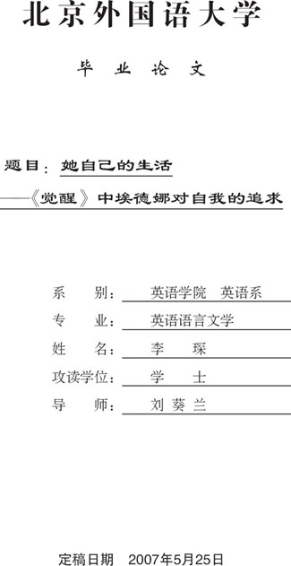

A Life of Her Own  
—Edna's Struggles for Self-autonomy in The Awakening

**By Li Chen**

A Thesis Submitted to

the School of English and International Studies

Beijing Foreign Studies University

in Partial Fulfillment of the Requirements

for the Degree of Bachelor of Arts

Supervised by

**Liu Kuilan**

May 2007

Acknowledgements

I would like to thank the following persons for their help and support during my research and writing of this thesis.

First of all, I want to thank Professor Liu Kuilan, my thesis advisor. She has talked with me several times during the whole thesis-writing process, discussing my research ideas and approaches and giving me advice on how to conduct the research and present it on paper...

Secondly, I want to thank...

Finally, I would like to thank my parents for their consistent support and help for my studies.

Responsibility for any remaining errors is mine alone.

Table of Contents

Ⅰ．A brief introduction to the novel and its reception

Ⅱ．Women's position in the Creole society

Ⅲ．Edna's awakening

A．Edna's life before her awakening

B．The nature of Edna's awakening: both spiritual and physical

C．The causes of her awakening

1．Leonce's possessiveness

2．Adele's femininity, open manner and sympathy

3．Madmoiselle Reisz's passionate music

4．Robert's devotion

Ⅳ．Edna's choices

A．Adele—a typical "angel in the house"

B．Madmoiselle Reisz—the isolated spinster artist

C．Edna—the third way: a life of her own

Ⅴ. Edna's struggles

A．Financial struggles

B．Emotional struggles

C．Final assertion—suicide

Ⅵ．Conclusion

摘要

肖邦的代表作《觉醒》一书描绘了主人公埃德娜·庞蒂利埃由一个中产阶级家庭妇女到一个追求独立自我的新女性的转变过程。

在肖邦的时代，美国社会基本上仍是一个男权社会，在美国的南方尤为如此。妇女一生都局限在家庭中，只能扮演贤妻良母的角色。在觉醒之前，埃德娜·庞蒂利埃像同时代的其他妇女一样，过着循规蹈矩的生活。她从小家教严格，之后结婚生子并忠实地尽一个妻子和母亲的义务。但是，真正的埃德娜是一个充满激情的、叛逆的女性。在格兰德岛上，埃德娜开始了一段深刻并且痛苦的觉醒过程。她的觉醒最初始于对婚姻的不满，并在阿黛尔、赖斯小姐以及罗伯特的影响下进一步深化。埃德娜的丈夫莱昂斯的自私和过度的占有欲使埃德娜逐渐意识到自己婚姻的压迫本质。阿黛尔这一格兰德岛上典型的贤妻良母促使埃德娜开始认识自我，探索自我。同时，赖斯小姐用她那富于感染力的音乐触动了埃德娜心底的激情。而罗伯特则直接激发了埃德娜肉体的觉醒。在发现自我之后，埃德娜先后放弃了两种模式的生活。她既不愿意像阿黛尔那样泯灭自我，也不愿像赖斯小姐那样与世隔绝。埃德娜选择走一条自己的路，为实现自我而展开斗争。首先，她拒绝依靠丈夫生活并试图实现经济独立。从格兰德岛回来之后，埃德娜拒绝履行家庭义务并以绘画谋求经济上的自主。她甚至用自己的钱搬出了丈夫的房子并举办了盛大的晚宴宣告自己的独立。更反叛的是，埃德娜试图控制自己的身体。她和纨绔子弟阿罗宾交往并发生了关系，在整个过程中，埃德娜始终掌握着主动权。随着认识的深入，埃德娜最终放弃了对罗伯特的浪漫幻想。她最终意识到罗伯特和莱昂斯、阿罗宾一样，都把自己当作物而不是平等的人对待。最终，在母性和自我之间，埃德娜毅然选择了后者。既然无法实现自己的生活，不接受妥协的埃德娜选择了走向大海。她虽然失去了生命，但却维护了自我的完整。

关键词：埃德娜 觉醒 自我

Abstract

The Awakening depicts the process of Edna Pontellier's awakening from a middle class housewife to a new woman of her age who struggles for self-autonomy.

In Chopin's age, the American society, southern society in particular, was basically a patriarchal one in which women were constrained in the households all their life time and the only roles they could play were obedient daughters, submissive wives and loving mothers. Before her awakening, Edna Pontellier led a conventional life as other women of her age did. She grew up with strict upbringing, later got married and had children. However, deep inside, she was passionate and rebellious. On the Grand Isle, Edna underwent a profound and painful process of awakening which was both spiritual and physical. Her awakening began with her growing dissatisfaction of her marriage and was furthered by the influence of Adele, Mademoiselle Reisz and Robert. After her awakening to her self, Edna chose neither to be a "mother woman" like Adele nor an isolated artist like Mlle Reisz. Rather, she struggled to live a life of her own. In the first place, she rejected the comfortable life her husband offered and sought to gain economic independence. She refused to carry out the household duties and tried to earn her own money by painting. Later she even moved out of her husband's house and declared her independence with a fancy dinner party. Secondly, she tried to take control of her body which she regarded as an integral part of her identity. She had an affair with Arobin, satisfying her physical needs but retained her freedom from male domination. Lastly, with her newly gained insights, Edna abandoned her fantasies about romantic love. She finally understood that Robert was no different from her husband or Arobin who regarded her as an object rather than an independent person. In the end, between motherhood and her self, Edna chose the latter. Accepting no compromises rather than a life of her own, Edna chose to embrace the sea and died a whole person.

Key words: Edna awakening self-autonomy

A Life of Her Own  
—Edna's Struggles for Self-autonomy in The Awakening

Ⅰ．A brief introduction to the novel and its reception

For ages and ages since the publication of The Awakening , there have been ceaseless debates concerning the novel and its protagonist. Readers often wonder why Edna Pontellier, wife of a devoted husband and mother of two children, abandoned her family and her former rich and easy life. In addition, starting from the early reviewers, there is a tendency of overemphasizing the sensual nature of Edna's awakening. Quite often reviewers reduce her awakening as simply a sexual one, equating her struggles as merely an attempt to gain sexual fulfillment while ignoring the fact that it is only part of a more profound spiritual awakening. For example, Kenneth Eble claimed that "quite frankly, the book is about sex" and defined Edna's problem as "the struggles with Eros itself" (Bloom 12). Larzer Ziff called The Awakening "the most important piece of fiction about the sexual life of a woman written to date in America" and mentioned nothing about Edna's awakening to a spiritual independence(Culley 174). This paper will argue that instead of being a selfish, foolish woman, Edna Pontellier is a new woman of her age who awakens to her sense of self as an independent individual and struggles financially, sexually and emotionally for self-autonomy. Ultimately, accepting no compromises rather than a life of her own, Edna chooses to embrace the sea and dies a whole person.

Published in 1899, The Awakening was first received with harsh criticism. The Public Opinion even exclaimed that "we are well satisfied when Mrs. Pontellier deliberately swims out in her death" (Culley 151). What the critics found most uncomfortable were Chopin's evident sympathetic attitudes towards Edna Pontellier, an "immoral" woman who should be condemned. Daniels Rankin, Chopin's first biographer, thought highly of Chopin as a local color writer. Nevertheless, he described The Awakening as "exotic in setting, morbid in theme and erotic in motivation" and doubted whether it was worthwhile to depict such an unconventional protagonist (Culley 163). Willa Cather, a famous woman writer of Chopin's age, compared the book to "A Creole Bovary”. While impressed by the novel's “exquisite and sensitive, well-governed" style, she denounced the theme as "trite and sordid" (Culley 153). The penalty for its creator was disastrous, even fatal. The book was banned for almost 50 years and it marked a de facto end of Chopin's writing career.

Ignored for nearly half a century, the book regained attention from the critics in the 1950s. Kenneth Eble rediscovered the artistic value of the book and called on people to restore it to its due place with his famous essay "A Forgotten Novel”, arguing that "it anticipates in many respects the modern novel" (Culley 165-170). From then on, the complexity and richness of the book were much discussed. Fascinated with the imageries, symbols and characterization, critics employed various approaches to analyze this novel. More importantly, the theme, once regarded as the largest blot of the book, began to be regarded as "modern"and highly interested the feminist critics. Per Seyersted，editor of The Complete Works of Kate Chopin commented that "Kate Chopin is a rare, transitional figure in modern literature. In her illustrations of the female condition she forms a link between George Sand and Simone de Behavior. In her descriptions of the power of sexuality she reflects the ideas of such a work as Hippolytus and foreshadows the forceful 20th century treatment of Eros" (Seyersted 194). During the process, Kate Chopin was elevated from the status of a minor local color writer and short fiction writer to that of a “pioneer", and was recognized as one of the most influential authors in the canon of American literature.

Ⅱ．Women's position in the Creole society

In his Walden ; or , Life in the Woods , Thoreau declared that "I went to the woods because I wished to live deliberately, to front only the essential facts of life...and see if I could not learn what it had to teach, and not, when I came to die, discover that I had not lived...”(Baym, Norton 915). While men enjoyed the freedom of living the way they like, going to the woods and searching for the meaning of life and doing whatsoever, women were much less fortunate. Even 45 years after the publication of the above essay, most women of Chopin's age were still constrained in the households all their lifetime and the only roles they could play were obedient daughters, submissive wives and loving mothers. Despite the fact that woman's movement was starting to gather momentum in the 1890s in the United States, women, southern women in particular, still enjoyed little political, economical, and legal rights. According to Margaret Culley, most married women in New Orleans were indeed the property of their husbands at the time when the book was written (Culley 117). In addition, the law clearly stated that “All of a wife's'accumulations' after marriage were the property of her husband, including money she might earn and the clothes she wore." Women were seen as "absolutely incapable" of testifying in court and they had no rights to vote until the 20th century. In the case of a divorce, women were often robbed of the custody of their children. "Despite social and political advances, women in the 1890s still encountered disadvantages in almost every aspect of their lives, and a majority of the populace still believed that a woman's most sacred duty was to be 'the angel in the house'" (Culley 119). In this respect, the Creole women of New Orleans are indisputably honored as the model women of that age, famous for their chastity and virtues. Although the Creole society seems to be quite open, it is a deceptive openness which bases on their women's unquestionable virtues and their confidence of its Patriarchy (Dyer 11).

...

Ⅲ．Edna's awakening

Edna Pontellier, the protagonist, grows up in a Presbyterian family in Kentucky with strict up-bringing. Her mother died when she was quite young and after that her sister managed the family. Her father is a rigid colonel, who believes that for women, "coercion is what is needed" and "put your foot down good and hard" is "the only way to manage a wife"(Chopin 102). Ironically, it is him who drove his wife into the grave. Not surprisingly, Edna grows up to be self-contained and reserved, keeping her private thoughts totally to her self. Moreover, she has been trained to obey and to do what is expected of her.

Brought up in a cold, loveless home, Edna Pontellier has been living a dual life split between "an outward existence which conforms" and "an inward life which questions" since her childhood (Chopin 25). Most of the time, the conflict of the two is resolved in her habitual conformity and obedience. However, deep down, she is rebellious and passionate. Before her marriage, she was in love with a cavalry officer, then a man visiting a neighboring plantation and later a tragedian, but she never expressed her feelings. While religion was taken as a serious matter, Edna never had any genuine interest in it. At one time she plunged into a sea of grass, running away from her father's gloomy Presbyterian service. Later, she got married with Leonce Pontellier "accidentally”, a man twelve years her senior. What's important is that Leonce is a catholic. Edna marries him so as to rebel against the will of her rigid father and sisters and to start a new life with a man “who will not make too many domestic, emotional, or sexual demands on her" (Showalter 76). However, in contrast to her fancy that "there was a sympathy of thought and taste between them" (ibid), the reality is the other way round. Though Leonce provides her with a comfortable material life, he never truly cares about her emotional life, for his chief concern in life is to make money. Edna is satisfied that "no trace of passion or excessive and fictitious warmth colored her affection, thereby threatening its dissolution" (ibid). In other words, Edna doesn't love her husband from the beginning. She is only content that she can keep to her self and go on enjoying her privacy until she discovers that the price of that little space of her own is her freedom.

...

On the Grand Isle, however, Edna's buried self began to undergo a profound and painful process of awakening. The Grand Isle is a "female colony”. It is run by a woman (Madame Lebrun) and is dominated by women since men go there only on weekends. It is situated“outside patriarchal cultures, beyond the limits and limitations of the city where men make history, on a shore that marks the margin where nature intersects with culture" (Bloom 94). It is at this particular place that Edna starts the journey of self-discovery. "In short, Mrs. Pontellier was beginning to realize her position in the universe as a human being, and to recognize her relations as an individual to the world within and about her" (Chopin 24). She started to question and tried to understand the world on the basis of HER relation to the world.

As to the nature and cause of Edna's awakening, critics have different ideas. Some tend to reduce it to a sexual one and attribute its cause to Robert alone. For example, Kenneth Eble remarked "quite frankly, the book is about sex" and defined Edna's problem as "the struggles with Eros itself " (Bloom 12). But the fact is that it is not merely about sex. Edna awakens to her self—the "essential" of her being which allows no interference from others and along with that, her sexuality. What she struggles to gain is not simply sexual fulfillment but autonomy over every aspect of her life. In addition, she is not awakened by her lover Robert alone; it is actually a result of both internal and external factors. More directly, four people: Leonce, Adele, Mademoiselle Reisz and Robert, intentionally or not, all influence the progress of Edna's awakening. Leonce's possessiveness forces Edna to realize the oppressive nature of her marriage; Adele, the "mother woman", being a sympathetic listener, induces Edna to begin her self-discovery; Mademoiselle Reisz incites the passion inside her with her powerful music; and Robert, Edna's "beloved one", excites her sensual nature.

...

Ⅳ．Edna's choices

After her awakening to her self, Edna decides neither to be a "mother woman" like Adele nor an isolated artist like Madmoiselle Reisz.

Adele is a typical "angel in the house”, beautiful, sympathetic, a selfless wife and mother. Above all, she has internalized the notion of Creole womanhood so well that she is not even aware of her pathetic situation... With her newly gained insight, Edna could now perceive the true nature of her friend's life. Responding to the “happy" scenes in the Ratignolle, Edna pitied Adele's "colorless existence which never uplifted its possessor beyond the region of blind contentment, in which no moment of anguish ever visited her soul, in which she would never have the taste of life's delirium." All she saw in it was an "appalling and hopeless ennui" which further strengthened her will to rebel (Chopin 82). If she follows Adele's example, it means returning to her husband and removing the newly found self in her, which would be the last thing Edna would like to do.

Madmoiselle Reisz represents another extreme for Edna. ... However, cutting herself out of human connections, Madmoiselle Reisz sacrifices almost everything for her music to the extent that she is somewhat dehumanized. Although she does enjoy thorough autonomy over her life, she is loveless, loving nobody and loved by none. She is just as pathetic as Adele who bases her whole existence on her role of a "mother-woman”. Madmoiselle Reisz also only has an incomplete life, which is not Edna wants. “More honest in her self-awareness than Adele, more dependent upon human relationships than Mlle Reisz, Edna will not settle for being as less than a complete person" (Skaggs 96). Therefore, to fully realize herself, Edna has to find a way of her own.

V．Edna's struggles

In order to achieve autonomy, a woman must rely on herself. Most importantly, she must support herself financially. To become independent, Edna needs to reject the golden cage offered by her husband in the first place.

...

Comparing Edna with Ibsen's unconventional women characters, Dorothy H. Jacobs argued that "Edna moves much further than Hedda Gabler <sup>1</sup> , who retires to an adjacent room for a noisy suicide, than Mrs. Alving <sup>2</sup> , who remains among the ashes of her pains, than Nora <sup>3</sup> , who closes the door on the doll's house. Edna selects and establishes a home for herself" (Boren and Davis 84). A major difference between Edna and Ibsen's characters is that Edna is aware of the importance of financial independence and tries to earn her own money which enables her to make the first major step in obtaining her independence...

However, Edna moves even further apart from striving for economic independence. She also seeks to take control of her sexual life, which is more daring and controversial.

...

Now that Edna has achieved great progress in controlling her financial, sexual and emotional life, she is faced with another obstacle on her way towards thorough autonomy, that is, the biological bond between her and her children.... In the end, Edna went to the sea, took off her clothes and "felt like some new-born creature, opening its eyes in a familiar world that it had never known" (ibid). At the cost of her life, Edna finally preserved her integrity.

VI．Conclusion

However, whatever approaches people employ in reading the novel, we must bear in mind that Edna is a woman living in an exclusive male society where women were judged by the rules made by men and therefore whatever happened to Edna would never happen to a man. In that regard, Edna's courage and determination deserve our respect. And in her defiant embrace of death, Edna does manage to preserve what she holds most essential—her selfhood and autonomy with the utmost dignity. Her struggles for self-autonomy, at least two decades ahead of her time, paved way for the development of women's movement, as Joyce Dyen commented: "Published in 1899, significantly, it (The Awakening ) recorded with bold truth what one woman's attempt to join the 20th century would entail. And it anticipated the journeys of the millions of other women, real or fictional, who would follow her" (Dyer 13).

Works Cited

Baym, Nina, ed. The Awakening and Selected Stories by Kate Chopin , vii-xi. New York:

Modern Library, 1981.

Baym, Nina, and others, eds. The Norton Anthology of American Literature . Shorter 5th edition. New York: Norton, 1999.

Bloom, Harold, ed. Kate Chopin . New York: Chelsa House Publisher, 1987.

Boren, Lynda S. and Sara de Saussure Davis, eds. Kate Chopin Reconsidered: Beyond the Bayou . Baton Rouge: Louisiana State UP, 1992.

Chopin, Kate. The Awakening . New York: Cambridge University Press, 1996.

Culley, Margaret, ed. The Awakening: An Authoritative Text, Contexts, Criticism . New York:

Norton, 1976.

Dyer, Joyce. The Awakening: A Novel of Beginning. Twayne's Masterwork Studies . New York:

Twayne, 1993.

Leary, Lewis, ed. The Awakening and Other Stories . New York: Holt, Rinehart & Winston, Inc.,1970.

Malzahn, Manfred. "The Strange Demise of Edna Pontellier." Southern Literary Journal 23 , no. 2 (spring 1991): 31-39.

Nelles, William. "Edna Pontellier's Revolt against Nature." American Literature Realism 32 , no. 1 (fall 1999): 43-50.

Seyersted, Per, ed. The Complete Works of Kate Chopin . 2 vols. Baton Rouge: Louisiana State UP, 1969.

Showalter, Elaine. “The Awakening: Tradition and the American Female Talent.” Sister's

Choice: Tradition and Change in American Women's Writing . New York: Oxford UP, 1991. 33-55.

Skaggs, Peggy. Kate Chopin . Boston: Twayne Publishers, 1985.

Taylor, Walter and Jo Ann B. Fineman. "Kate Chopin: Pre-Freudian Freudian." Southern Literary Journal 29, no.1 (fall 1996): 35-45.

Woolf, Virginia. Professions for Women . New York: Norton, 1996.

文献综述

肖邦的代表作《觉醒》出版于1899年4月。小说描写了中产阶级女性埃德娜自我意识的觉醒以及她为挣脱19世纪男权社会的枷锁，追求独立的经济、性以及情感生活而做出的挣扎与努力。

《觉醒》是一部超越时代的小说。从当时道德伦理的角度来看，埃德娜企图脱离家庭、大胆追求自我解放的行为是大逆不道的。正因如此，肖邦的同代读者以及早期评论家对这部作品基本持否定态度。更令评论家愤怒的是，小说的作者不仅不对其主人公进行谴责，反而在字里行间流露出明显的支持与同情。《公共舆论报》甚至宣称“我们十分满意庞蒂利埃夫人最终选择在大海中游向死亡”（Culley 151）。评论家们一方面承认肖邦的写作技巧，另一方面对其主题和主人公嗤之以鼻。肖邦同时期的女作家薇拉·凯瑟将《觉醒》与福楼拜的《包法利夫人》相比较，称赞它“风格精巧细腻，组织严密”，但却认为小说的主题“既陈腐又卑劣”（Culley 153）。凯瑟认为“埃德娜与埃玛·包法利属同一种女性类型。两人都来自一个阶级，总是幻想着得到多于上帝所给予我们的浪漫。她们都是将爱情过度浪漫化的受害者”（Culley 154）。肖邦的首部传记作者丹尼尔·S.兰金在《凯特·肖邦和她的克里奥尔故事》中评论道：“《觉醒》的背景充满了异国情调，其主题是病态的，动机是色情的”（Culley 163）。《觉醒》被肖邦的家乡密苏里州圣路易斯图书馆列为禁书。肖邦本人从此一蹶不振，除了几部短篇小说问世之外，基本上终止了文学创作。

半个世纪之后，随着社会的发展以及文学评论的成熟，人们开始重新关注这部作品。1956年，肯尼思·艾伯尔在“凯特·肖邦的《觉醒》：一部被人遗忘的小说”中首次对它进行深入的分析并号召人们给予这部小说应得的地位。他认为“《觉醒》在很多方面开现代小说之先河”（Culley 165）。然而，艾伯尔认为：“很明显，这部小说是关于性的”（Culley 166）。在他看来，埃德娜的问题在于和“爱神自身的斗争”（Culley 170），而忽视了小说所反映的女性意识的觉醒和女性对自我的追求。1969年，挪威评论家帕·西耶斯迪德出版了他所编辑的两卷本肖邦作品集，并在其中评论道：“凯特·肖邦是现代文学的一个罕见的过渡性人物。她对女性处境的描绘承接了乔治·桑和西蒙·德波娃。她对性的描写预示了20世纪作家们对爱神的处理”（Seyersted 194）。

随着女权主义运动的发展，女权主义评论家们开始重新发掘那些长期以来被边缘化的女性作家的作品。《觉醒》以其对女性自我意识的细腻刻画，当之无愧地被评论家们奉为女权主义经典之作。不仅如此，人们开始对从不同角度分析小说的意象、象征、人物塑造并对结尾的深刻意义进行探讨。桑德拉·吉尔伯特从小说的神话模式角度分析，以晚宴一章为切入点，认为埃德娜是爱神维纳斯的象征。埃德娜最终走向大海，不是自杀而是回归她的出生之地（Bloom 89-113）。肖沃尔特从女性作家的写作传统分析了《觉醒》一书的特点，认为这部小说既继承了女性的写作传统，又有所偏离（Showalter 33-55）。玛格丽特·卡利则认为《觉醒》是一部存在主义作品，反映了人类共同的孤独处境（Culley 117-119）。在此过程中，肖邦由一个鲜为人知的地方作家及短篇小说家提升到一位先驱者的地位，无可非议地跻身于美国重要作家之列。

从早期的评论开始，人们有一种过度强调埃德娜觉醒性的层面的趋向。笔者认为，埃德娜的觉醒不仅是肉体的觉醒，更是女性自我意识的觉醒。埃德娜的觉醒始于对婚姻压迫本质的认识和不满，并在内外因的作用下逐渐深化。在格兰德岛上，埃德娜逐渐意识到自己是一个独立的不依附他人而存在的个体，而身体是她自我的一部分。在发现自我后，埃德娜试图过上自己的生活，而性是她实现自我的重要手段。尽管如此，即便在她和阿罗宾的交往中，她也始终掌握着主动权，决不依附于任何人。

对于小说的结尾，评论家们也有着不同的诠释。有的认为埃德娜因爱人罗伯特的背叛而选择自杀（Culley 160-162）；有的认为埃德娜的确精神不大正常（Malzahn 31-39）；有的甚至提出埃德娜因怀孕而自杀的设想（Nelles 43-50）。但是，无论人们从哪个角度阅读这部作品，我们都必须考虑到当时的社会背景。毕竟，埃德娜所处的环境是一个男性主导的社会。男性可以像梭罗那样进入林子，探寻生命的意义；而作为女性就只能在家庭中扮演贤妻良母的角色。埃德娜所面对的问题是女性的问题，她的困境是一个19世纪女性的普遍处境。因此，埃德娜的勇气和不妥协的斗争精神值得我们钦佩。她为实现自我而进行的斗争超越了她的时代，为后世千千万万的妇女挣脱家庭枷锁、追求个人自由树立了榜样。

参考文献

Bloom, Harold, ed. Kate Chopin . New York: Chelsa House Publisher, 1987.

Culley, Margaret, ed. The Awakening: An Authoritative Text, Contexts, Criticism. New York: Norton, 1976.

Malzahn, Manfred. "The Strange Demise of Edna Pontellier." Southern Literary Journal 23 , no. 2 (spring 1991): 31-39.

Nelles, William. "Edna Pontellier's Revolt against Nature." American Literature Realism 32 , no. 1 (fall 1999): 43-50.

Seyersted, Per, ed. The Complete Works of Kate Chopin . 2 vols. Baton Rouge: Louisiana State UP, 1969.

Showalter, Elaine. “The Awakening : Tradition and the American Female Talent.” Sister's Choice: Tradition and Change in American Women's Writing . New York: Oxford UP, 1991. 33-55.

参考答案

课堂练习1

1．

| General topic: | 20th Century American Novelists |
| --- | --- |
| Restricted: | Hemingway and His Works |
| More restricted: | Hemingway and His Short Stories |
| Topic chosen: | Old People in Hemingway's Short Stories |

2．

| General: | The Lost Generation Writers |
| --- | --- |
| Restricted: | F．Scott Fitzgerald's Novels |
| More restricted: | Fitzgerald and His The Great Gatsby |
| Topic chosen: | Gatsby's Death and the Disillusionment of the American Dream |

课堂练习2

1．题目太宽泛。

建议：The Concept of Success of the Young People in China in the New Century

2．可行。

3．题目太宽泛。

建议：Sino–US Relations in the 1970s

4．题目太宽泛。

建议：The Causes of Air Pollution in Beijing and Some Possible Solutions

5．可行。

6．当前无法下结论。

课堂练习3

1．图书馆中的图书根据**作者** 、**书名** 和**主题** ，依照英文字母顺序排列。

2．忽略书名中的**A** 和**The** ，在**书名目录卡** 中查找 **Doll's House** 和 **Color Purple** 即可。

3．在**作者目录卡** 中查找**Forster, E. M.** 即可。

课堂练习4

1．拿到一本书后，要首先快速翻阅书前目录或书后索引，从中找到对自己可能有用的章节。

2．要尽可能找到此书最新的版本，并比较不同书中涉及同一题目的信息,以确保所得到的资料第一没有过时，第二不带偏见。

课堂练习5

转述/意译

F．Scott Fitzgerald's Themes

Elisabeth B. Booz, p. 66

Elisabeth B. Booz believes that F. Scott Fitzgerald dealt with the theme of love and money in a most clever way for he understood the relationship between the two better than any other American writer.

[Paraphrase]

摘要

F．Scott Fitzgerald's Themes

Elisabeth B. Booz, p. 66

Of all American writers, F. Scott Fitzgerald was the one who could deal with the theme of love and money most cleverly.

[Summary]

课堂练习6

**评论：**

论点不精炼。诸如The author of this paper has made a careful study...and intends to prove...等词语不应在主题陈述中出现；论文作者已经做了什么、还打算做什么一类的话可放在论文的引言中。

**修改后的主题陈述：**

Santiago, the protagonist in The Old Man and the Sea , is Hemingway's typical code hero who best demonstrates the code of "grace under pressure."

课堂练习7

**Confucius' Main Teaching Methods and Their Applicability to China's Education Today**

Ⅰ．A brief introduction to Confucius

A．A great philosopher and statesman

B．A great educator

Ⅱ．Confucius' two main teaching methods

A．The method of elicitation

1．Fostering students' ability to learn by themselves

2．Emphasizing the teacher's role in giving guidance

B．The method of "teaching students in accordance with their aptitude"

Ⅲ．Causes of the discontinuance of Confucius' teaching methods in modern

China

A．The May 4th Movement era

B．The "Cultural Revolution" period

Ⅳ．The Applicability of Confucius' teaching methods to China's education today

A．Problems in education today

1．Feeding students with knowledge

2．Teaching all students in the same way without discrimination

3．Analyzing the root of problems

B．Inspiration derived from Confucius' teaching methods

1．Helping students cultivate the habit of learning in an active way

2．Giving students opportunities to practice what they have learned

3．Improving the ways of teaching so as to arouse students' interest

4．Increasing elective courses to meet students' different interests

5．Setting up more technical and vocational schools for students with different capacities

Ⅴ. Conclusion

课堂练习8

1．In his famous speech "I Have a Dream...", Martin Luther King said, "I have a dream that my four little children will one day live in a nation where they will not be judged by the color of their skin but by the content of their character."

Or: Martin Luther King's words— "I have a dream that my four little children will one day live in a nation where they will not be judged by the color of their skin but by the content of their character" —are widely known in China.

Or: Martin Luther King was speaking not only for African-Americans but also for all ethnic minorities in America when he said, "I have a dream that my four little children will one day live in a nation where they will not be judged by the color of their skin but by the content of their character."

2．The Five Principles of Peaceful Coexistence, namely, "mutual respect for territorial integrity and sovereignty, mutual non-aggression, non-interference in each other's internal affairs, equality and mutual benefit, and peaceful coexistence," were written into the Constitution of the People's Republic of China in 1982.

Or: The Five Principles of Peaceful Coexistence, namely, "mutual respect for territorial integrity and sovereignty, mutual non-aggression, non-interference in each other's internal affairs, equality and mutual benefit, and peaceful coexistence," are fundamental principles for China in developing friendly relations with all countries in the world.

Or: The Five Principles of Peaceful Coexistence, namely, "mutual respect for territorial integrity and sovereignty, mutual non-aggression, non-interference in each other's internal affairs, equality and mutual benefit, and peaceful coexistence," were first put forward by the late Chinese Premier Zhou Enlai when he met with an Indian delegation in 1953.

3．According to J. William Fulbright,

There are two Americas. One is the America of Lincoln; the other is the America of Teddy Roosevelt and the modern superpatriots. One is generous and humane, the other narrowly egotistical; one is self-critical, the other self-righteous; one is sensible, the other romantic; one is goodhumored, the other solemn; one is inquiring, the other pontificating; one is moderate, the other filled with passionate intensity; one is judicious and the other arrogant in the use of great power.

Or: J. William Fulbright believes that there are two Americas:

... One is the America of Lincoln; the other is the America of Teddy Roosevelt and the modern superpatriots. One is generous and humane, the other narrowly egotistical; one is self-critical, the other self-righteous; one is sensible, the other romantic; one is good-humored, the other solemn; one is inquiring, the other pontificating; one is moderate, the other filled with passionate intensity; one is judicious and the other arrogant in the use of great power.

注释

1 Hedda Gabler, the heroine of Ibsen's Hedda Gabler. Having a profound craving for independence, Hedda is frustrated by the fact that she cannot participate in the world outside her household. She destroys what she cannot accept and finally commits suicide.

2 Mrs. Alving, the heroine of Ibsen's Ghosts . In spite of her husband's philandering, Mrs. Alving continues her marriage because of the constraints of 19th-century morality. She tries hard to protect her husband's reputation after her husband's death.

3 Nora, the heroine of Ibsen's A Doll's House. Nora leaves her husband who has always treated her like a doll rather than a human being in order to establish a life of her own. At the end of the play, she walks out slamming the door behind.

第九章 应用文

I．布告、通知

布告或通知一般公布即将发生的事，有时也公布已经发生的事。如宣布召开会议、举办宴会或晚会、放映电影或录像、举行各种比赛等等。此类布告、通知一般至少包括以下三部分内容：

·时间：×月×日，星期×，×时×分

·地点

·活动内容

范文1

Deparment Meeting

Wednesday Oct. 5

3 p.m.

Rm. 405

范文2

Movie—Hamlet

in the Auditorium

Saturday

Apr. 5

4:00—6:00

Admission Free

范文3

Basketball Match

on Playing Court #1

English Dept. vs. French Dept.

Mon. October 10

5:00 PM

课堂练习1 用范文1、3的内容撰写两个中文布告。

课堂练习2 比较中、英文布告的相同与不同之处。

课堂练习3 写出周一至周日的英语词及其缩写式。

课堂练习4 写出一月至十二月的英语词及其缩写式。注意其中有一个月的英语词不可缩写。

如果是讲座或报告，其通知还应包括报告人简介。

范文4

Women's Lib Movement on U.S. Campus

Speaker: Professor Betty Powell

Professor of Sociology, Smith College

Author of The Other Half of the Sky

Date: Friday, 8 May

Time: 10 a.m.

Place: Rm. 101

All Welcome!

课堂练习5 以上讲座通知还包括哪些细节？

如果是有关失物招领、旅游等的通知，则应包括其他细节，如通知对象，有关人员，以及发布、张贴布告者或单位。

范文5

Notice

Those who have signed up for "Western Civilization" please come to the Department Office to get their handouts on Wednesday, Sept. 15 between 2:00 and 4:00 p.m.

History Teaching & Research Section

范文6

Notice

The gentleman/lady who bought two ivory figurines and a lacquerware coffee set from the Chinese Arts and Crafts Store on the morning of May 2nd has been overcharged through an accounting error. Will he/she please contact the Manager's Office to be refunded.

Manager's Office

范文7

Found

A brown leather wallet, in the dining hall on the morning of Sept. 29th.

Owner please claim at the Lost and Found Office (Lost Property Office), Rm. 320 on the 3rd floor of the Office Building.

Lost and Found Office

(Lost Property Office)

课堂练习6 范文5、6、7包括哪些细节？

范文8

SUNRISE TOUR GROUP

Schedule for Tuesday, August 10

8:50 a.m.

Meet in hotel lobby to board bus for the Summer Palace

Lunch at the Summer Palace

Quick stop at the Friendship Store for last-minute purchases

4:30 p.m.

Return to hotel

Liu Xinhua,

Tour Guide

Monday, August 9

范文9

BUS TOUR

We are arranging for a bus tour to the Summer Palace on this SATURDAY, 24th September.

The bus will depart from the Beijing Hotel shortly after 8:30 a.m. and will return around 6 p.m., in time for dinner at the Hotel.

Lunch will be served at Listening to the Orioles Singing Restaurant in the Summer Palace.

There will be quick stops at the Haidian Free Market and Beijing Zoo on our way back.

If you would like to join us, please place your name on the sheet on the Notice Board, or tell Mr. Wang Huaide or Xiao Liu at the front desk, and meet in the lobby at 8:30 a.m., SATURDAY, 24th September.

Cordially yours,

（签名）

Hu Wendi,

Tour Guide

作业1

第一部分

1．拟一份6月2日（周五）下午5时在305教室开班会的通知。

2．拟一份影讯布告。片名：《长征》；时间：7月1日（周五）下午2－4时；地点：大礼堂；票价：3元。

3．通知已交款购买（pay for）《世界史》一书的学生于3月7日（星期四）下午3－5时到系办公室领书。

4．通知欲观看6月7日（星期六）京剧（Beijing opera）《美猴王》（The Monkey King ）的游客到导游张先生处登记。

第二部分

写布告：

1．通知开会、聚会、电影、篮球赛、演讲比赛、讲座、英语晚会或其他活动；

2．通知乘大轿车去某名胜古迹或某城市游览，或去夏季度假村等地的有关事宜；

3．通知青年旅游团（Youth Tour Group）成员观光本市或你熟悉的城市的4日游日程安排。

II．致意，问候，祝愿，祝贺，吊唁

以下词语通常写在卡片上，用于不同的场合，传达不同的信息。这类词语一般包括三方面内容：

·收信人

**To** Mr. & Mrs. Smith/Dr. Brown/Professor Stone:

**To** Dick/Annette,

·信息

·发信人

**from** Li Lihua

**公事信函** 的收信人后用**冒号（：）** ，**私人信函的** 收信人后用**逗号（，）** 。Professor，Dean，Senator，Governor，Captain一类称呼通常用全拼词而不是缩写式。

范文10

To Dr. Brown,

A Merry Christmas and

A Happy New Year!

from Li Lihua

1．致意、问候

相关表达法

**祝贺新年、圣诞节：**

* A Merry Christmas and a Happy New Year!

* Best wishes for a Merry Christmas and a Happy New Year!

* Best Wishes for Peace and Joy in this Holiday Season and a New Year of Health, Happiness and Prosperity!

* Joyous greetings and best wishes for the New Year!

* Warm regards and the season's greetings!

* With the season's greetings and best wishes for the New Year!

* With best wishes for a Happy and Prosperous New Year!

* With warm wishes for a bright and wonderful holiday season!

* Wishing you a very Merry Christmas and a Happy New Year!

* Wishing you special joy during this special season!

* Remembering you with a warm wish for a Merry Christmas and a Happy New Year.

* Remembering you warmly and wishing you all the joys of the season.

* Thinking of you warmly at this season and sending you wishes for a beautiful Christmas and a new year filled with happiness.

* May the Joy and Peace of Christmas be with you throughout the year!

* May this Christmas bring us closer to the spirit of human understanding, closer to the blessings of peace!

* May every joy of the holiday season be yours, and may the new year bring you happiness!

* May you and yours have a truly joyous Christmas and a very happy New Year!

* May the new year bring happiness and abundant good fortune to you and yours!

* Hope your Christmas is merry, your spirits are bright, your whole season happy and filled with delight!

* As another year draws to a close, we thank you for your friendship and goodwill and sincerely wish you all the happiness that a prosperous and successful New Year can bring.

**祝贺生日：**

* Happy Birthday (to a special friend)!

* Many Happy Returns of the Day!

* With warmest wishes for a happy birthday!

* With loving thoughts on your birthday!

2．祝愿、祝贺

相关表达法

* Best wishes for a speedy recovery.

* Get Well Soon!

* Warmest Get-Well Wishes.

* Good luck in your examination!

* Good Luck in your interview!

* Congratulations (and Best Wishes)!

* Hearty congratulations on your success!

* Hearty congratulations on your marriage and best wishes to you both!

* Best wishes for a long and happy married life to you both.

* May this be the beginning of a lifetime of love and happiness!

* May your life together be filled with love and happiness!

* Happy Anniversary!

* Many Happy Returns of Your Wedding Anniversary!

* A Baby Boy/Girl! How wonderful!

* Have a nice journey home!

* I wish you a pleasant trip.

3．吊唁

相关表达法

* Heartfelt/Sincere condolences in your great loss.

* We were/I was shocked and deeply sorry to learn the passing away of Mr. A.

* Please accept our very sincere condolences in your great loss.

作业2

第一部分

1．给你单位的专家Nick Shaw先生和夫人写一张圣诞贺卡，感谢一年来他们对你的帮助。

2．给已回国的好友John或Mary写一张贺卡，表达你对他/她的思念。

3．以大家的名义给生病住院的外国同事/老师/朋友写一张慰问卡，祝他/她早日康复。

第二部分

1．给一外国朋友、老师或同事写一张卡祝贺圣诞节和新年。

2．给一生病的外国朋友、老师或同事写一张卡表示问候。

III．正式邀请

除邀请人姓名外，正式邀请还包括以下内容：

·活动，事由；

·被邀请人姓名；注意在范文13、14中用“你”代之；

·（请柬的左或右下角）来自法语表示“请答复”的R. S. V. P.四个大写字母；

·请被邀请人答复的电话号码；（**regrets only** ）表示**仅** 要求**在不能赴约时** 打电话。

范文11

**On the occasion of the 30th anniversary**

**of the founding of Mianyang Teachers' College**

**The President, Mr. Yuan Sijia,**

**would like to invite** Professor **and** Mrs . Alan Moss

**to a Reception on Monday, September 1, 2009**

**from 11:30 to 13:30 at the Guest House**

R. S. V. P.

Tel. 227x839

（regrets only）

请柬也可以这样写：

范文12

**Mr. and Mrs. Wang Shuocheng**

**request the pleasure of the company of**

Mr. and Mrs. Donald Caslin

**to say farewell to Mr. and Mrs. Frank Johnson and**

**to welcome Dr. and Mrs. Nathan Langfeld**

**at Zijin Hall, Grand Hotel,**

**on Friday, 23rd May at 6:30.**

R．S. V. P.

6459x241

范文13

**In celebration of the 50th anniversary**

**of the founding of**

**the People's Republic of China**

**the Bureau of Foreign Affairs**

**cordially invites you to**

**a reception**

**on Thursday, September 30 at 5:30 p.m.**

**at Banquet Hall of the Guest House**

范文14

**Mr. and Mrs. Wang Lixun**

**request the pleasure of your company**

**at a dinner at Purple Garden**

**on Saturday, 2nd May, 2009 at 6 p.m.**

作业3 为你的系主任、部门经理或上级给一个外国朋友、老师、同事或业务合作伙伴写一份邀请赴宴的正式请柬。

IV．便条

便条是为不同目的而写的简短信函。它的形式比一般书信简单。便条多使用非正式语体或口语体。写便条时，可以省略以下几项：

·收信人和发信人的地址

·书信开头称呼语中的Dear一词

·书信结尾处发信人的结尾套语

·日期中的年份

注意便条日期中的月、日必须写清楚。虽然月、日可以全部用数字表示，但是最好不要完全使用数字，以免引起误会与混乱。如10/1/2008（或10/1/08）对美国人来说是2008年10月1日，而对英国人和大多数欧洲人来说，却是2008年1月10日。2008年10月1日也可以写成1(st) October(,) 2008或缩略成1 Oct. '08。如果把日写在月之前，月和年之间可以不用逗号。除了5月只能写成May以外，其他1月、2月、3月、4月、8月、9月、11月、12月均可用缩写式Jan.，Feb.，Mar.，Apr.，Aug.，Sept.，Nov.和Dec.表达。6月和7月可以写成Jun.和Jul.，但还是全拼出来，写成June和July为好。

1．留言

范文15

Dear Mr. Ali,

Here is a ticket for the exhibition tomorrow. The car will come around at 9:00 tomorrow morning.

Hong

范文16

Dear Mr. Hussain,

A Mr. Ali who recently arrived from Egypt wishes to see you. **You are requested to** ring him up any time this evening from 8:00 to 10:00 at 500-5566, Ext. 2106.

Liu

2．约定

范文17

Feb. 1

Helen,

**Could we** see each other for about an hour on Friday afternoon at 3 o'clock?

Xiaohong

范文18

July 15

Larry,

I have to meet my wife at the airport at 3 p.m. today. **Shall we** discuss the matter at 10 tomorrow morning?

If not, please ring me to make another time. Many thanks.

Liu

范文19

Mar. 8

Mr. Magee,

**Would you please arrange for** Mr. Tan Yiguo **to** be met at the...airport. He arrives at 18:40 hours on Flight BE 421 from London. Many thanks.

Su Heping

相关表达法

* Could/Shall we meet/go/discuss...

* Would you please meet (sb.) /pick (sb.) up...

* The flight/train arrives/leaves/departs... Would/Could you please pick me up/ arrange for (sb.) to (do)...

课堂练习7 比较范文17、18、19，哪一个范文用语最正式、规范，哪一个最客气？哪一个范文是写给熟人的，用语不讲究客套？我们可以写得既不讲究客套又不失礼吗？

课堂练习8 留条给Robert Stein，告诉他已安排好小周送他去机场，请他11点在宾馆大厅等候。

范文20

王老师：

我想和你谈谈我的毕业论文提纲，不知你何时有空？请留条在系办公室林老师处。多谢！

学生

王洪

2月7日

范文21

Tues. May 9

Professor Lowell,

I'd like to discuss with you the outline of my BA thesis. **Could you please appoint a time** and leave a message for me with Ms. Lin in the department office? Thank you.

Wang Hong

通过比较范文20和范文21,我们可以看出中英文便条有以下不同：

1．中文便条中“王老师”后用冒号（：），而英文便条中Professor Lowell后用**逗号（,）** 。

2．英文便条中**先** 在便条**右上角** 写日期，而在中文便条中，**最后** 在便条**右下角** 、留条人的名字下面写日期。

3．学生留中文便条时，常在自己名字前写“（你/您的）学生”，而在留英文便条时不这样写。

4．给老师留英文便条时，用Mr., Mrs., Miss, Ms.或Professor称呼对方，不可把“X老师”写成Teacher X。在汉语中，“老师”可以和“先生”、“太太”、“女士”、“小姐”一样作称呼语，而在英语中teacher用来表示职业，不能用作称呼语。

3．请求

范文22

1st August

Dear Judy,

Congratulations on your very good paper at the conference. **Could I have** a copy of it sent to the following address...? Thank you.

Jiaxin

范文23

Dan,

**Please let me know** as soon as possible what arrangements you have made. Thank you.

Tong

范文24

Dear Mr. White,

**Would you please let us have** the information about your flights to Sydney by next week. Thanks.

Zhang Qingyuan

相关表达法

* Could I/Would you please let us have... ?

* I would like to receive this publication regularly.

* I would be grateful if you could let me have full details of the symposium.

* We would appreciate having the addresses and telephone numbers of your branches in Tokyo, London, and San Francisco.

* Would you mind lending ... /my borrowing... ?

* Would you be so kind as to do... ?

* Would it be possible for you/me to do... ?

* I wonder if you could/would...(or if I could...)

* I would appreciate it if you could...

* Please let me know...

* Please inform us/me on your lowest possible price.

课堂练习9 留便条给Linda，要Henry的电话号码。

课堂练习10 留便条给Gates教授，要求借他写的《非裔美国小说史》，并请他将书放到你的68号信箱。

课堂练习11 写便条给外国教师Dorothy Evans，告诉她周老师让你把她要的书留在系办公室张老师处，请她拿到书后给周老师18号信箱留条。

4．道歉

范文25

Tues. Oct. 20

Dear Professor Richards,

**I'm sorry** I couldn't make our 4 o'clock appointment. Professor Sterne's lecture lasted a lot longer than I expected. I could meet you in the Department Office tomorrow at 3, if that is convenient for you. If not, please leave a note in my mailbox, #529, tomorrow morning. Thank you.

Zhang Hongyi

范文26

Sat. Oct. 31

Dear Mr. Clark,

**I would like to express my apologies for not being** able to keep our 9 o'clock appointment. I had a small accident on my way to school. I will come over to your apartment the day after tomorrow—Monday, November 2, at 9 a.m. if that is convenient for you. I will check my mailbox (#245) tomorrow to see if you have left a note for me. Otherwise, I will see you at nine, Monday morning.

**With many apologies,**

Li Xiaomei

范文27

Dec. 10

Dear Mr. Liang,

**I am so sorry** I have been unable to get you the address of Mr. John Eastman yet. I have tried very hard but have had no success. I shall keep on trying.

Yours sincerely,

Sandra Bunyan

范文28

Dec.12

Dear Ms. Bunyan,

**I am sorry** I have given you so much trouble over finding Mr. John Eastman's address. I am very grateful to you for all you have done. Please do not worry about the matter any further.

Sincerely,

Liang Xinyu

范文29

Oct.4

Susan,

**I am sorry to** have to tell you that I shall not be able to come to the party, because I have a bad cold. I do hope you will have a good time.

Feihong

范文30

2nd Nov.

Henry,

**I am sorry** I shall be out of town on business on Nov. 8, so **I am afraid** I'll have to postpone our meeting to Thursday, Nov. 12 at the same hour. I do hope you can still come, and **very much regret** any inconvenience the postponement may cause you.

Shihui

范文31

3rd July

George,

**I am terribly sorry** I failed to meet you at the school gate yesterday afternoon. I had one of the bike tires punctured on my way, and by the time I had the puncture mended and got to school, you must have given up hope and left. **Do please forgive me.**

Jianhua

相关表达法

* (I am) (very/terribly) sorry that...

* (I'm) sorry about/for (doing/not doing) sth.

* I am afraid...I am sorry...

* I (must/do) apologize for...

* I would like to express my apologies for...

* Please accept my (sincere/earnest/deepest/belated) apologies for...

* I/We very much regret any inconvenience it may cause you...

课堂练习12 写便条给外国教师David King，因没有能够在校图书馆为他借到他要的书向他致歉，并告诉他将设法去其他图书馆试试能否找到。

课堂练习13 重写下面的便条：把Annette和Professor Brown的名字互换，注意调整用语——给前者的便条用语无需讲究客套，给后者的便条用语应正式、规范、客气。

Nov. 14

Annette,

I'm sorry that I shall not be able to come to the meeting because I'm running a fever and have to stay in bed.

Xiaowen

Wed. Mar. 12

Dear Professor Brown,

I would like to express my apologies for not being able to keep our 10 o'clock appointment for Mar. 16, for I have some urgent business to deal with out of town and won't be back until Mar. 17. I will ring you up as soon as I come back to arrange for another appointment.

With many apologies,

Zhang Xiaowen

5．致谢

范文32

Larry,

**Thank you very much for** the invitation. I would be delighted to come.

Huiling

范文33

Dick,

**I can't thank you enough for** the disk you sent me. I've been hunting for it for weeks without success.

Xiaodong

范文34

Cathy,

**It was sweet of you to** send me the book of new critical essays on Maxine Hong Kingston. **How thoughtful you are!** It is just what I need for writing my MA thesis. **You could not have chosen a better gift.**

Meizhen

范文35

Dear Teresa,

**Many thanks for** your kind invitation to dinner on September 23rd. Weizhou and I accept with pleasure.

Hongfei

范文36

Dear Mr. Singh,

**I am writing to tell you how grateful I am for** your warm hospitality during my stay in New Delhi. I enjoyed it greatly.

Fang Tongbao

相关表达法

* Many thanks/Thank you very much for the lovely dinner yesterday. We enjoyed the evening a lot.

* Thank you so much for your assistance/for the information you gave us. I should be happy to reciprocate your kindness at any time.

* Thanks ever so much for your help. I really appreciate it.

* I can't thank you enough for...

* I am writing to thank you/to tell you how grateful I am for the wonderful time we had at your party last night.

* I want to thank all of you from the bottom of my heart for the best reception anyone could ask for.

* I am very grateful for your valuable advice/sharing your expertise and helping us to.../your thoughtfulness and time in (doing)...

* It was most kind of you to give us the benefit of your experience. Please accept our warmest thanks.

* I am writing to express my appreciation for all that you did for me during my visit to...

* Please accept my (sincere) appreciation for...

* Words can't express my (deep) appreciation for your kindness.

课堂练习14 留条给Linda，感谢她为你找到Henry的电话号码。

课堂练习15 留条给Gates教授,感谢他借给你《非裔美国小说史》，并告诉他你将尽快奉还。

6．非正式邀请

范文37

July 1

George,

**Would you like to** come swimming with me next Monday afternoon? We could meet at the school gate at about 1:30 p.m. and then go together.

Jianhua

范文38

Cathy,

We are having tea and moon cakes in my flat (#392) tomorrow night (Thursday) about 8 p.m. **Do come if you are free.**

Huiling

范文39

Dear Professor Leavis,

There will be a meeting of our drama group on Saturday afternoon, April 5, at 5 in our classroom, #410, in this building to discuss which play to put on for English Evening. **We would like to** hear your suggestions **and hope you will come.**

Song Liping

范文40

Dear Ms. Gates,

We are having a party in our classroom, #402, to celebrate... **Would it be possible for you to join us** on Friday, December 29, at 8 p.m.? **We would be very happy if you could be with us.**

Students of Class 5

Grade 2008

范文41

Mr. & Mrs. Johnson,

**We should be very glad if you could come to dinner** with us at our apartment at about 7 p.m. on Wednesday, Sept. 21st. **We look forward to seeing you.**

Liling & Dahua

相关表达法

* How about going (shopping/skating...)

* Would you like to.../I'd like you to...

* I would like to ask/invite you to...

* Would it be possible for you to join us...

* We would be very happy if you could be with us/come.

* We look forward to seeing you.

* We hope you will come/join us.

课堂练习16 留条给Nancy告诉她你买了两张周六音乐会的票，约她一同前往。

作业4

1．写便条给一个外国老师、专家

1）约定时间和他/她讨论论文提纲

2）请他/她为你写一封推荐信

3）为未能按时交论文或作业表示歉意

4）对他/她借给你参考书表示感谢

5）邀请他/她参加中秋节聚会

2．写便条给一个外国朋友

1）邀请他/她观看京剧演出

2）向他/她借自行车

3）对未能赴约表示歉意

4）对他/她送给你小礼品表示感谢

5）邀请他/她参加生日聚会

注意：1中要求写的便条与2中要求写的便条用语应该有所不同，前者应使用较正式的文体，后者则可使用非正式文体。

V．电子邮件

电子邮件E-mail是electronic mail的缩写,这种通过电脑发送、接收的邮件通常包括五个组成部分：

**·From：发信人**

**·Date：日期**

**·To：收信人**

**·Subject：事由**

**·The message：信文**

如果想将电子邮件同时发送给收信人以外的人，还可以包括：

**·Cc:** carbon copy二字的缩写，表示“抄送”

**·Bcc:** blind carbon copy三字的缩写，表示“暗送”

电子邮件和便条、书信一样，用语可以正式、规范，如范文42、43所示，也可以不讲究客套，如范文44、45所示。

范文42

**From:** Wang Chongliang

**Date:** 2008-4-8 5:19:58

**To:** Professor Anne Ellison

**Subject:** Seeking Advice

Dear Professor Ellison,

I will be participating in next month's Asian American literature conference and am writing in advance to seek your advice as well as introduce myself. I'm planning to do some research on Asian American literary studies in Britain while I'm in Leeds and wanted to ask for your advice as to identifying relevant sources (libraries, related institutes, scholars, graduate students). Are there specific articles/monographs you would recommend in advance? I will be staying in Leeds for two weeks after the conference. I wonder whether you would be willing to meet after the hecticness of the conference.

As a quick note of introduction, my own work is on Asian American/Canadian literature with a special interest in Chinese transnational cultures. I've done some work on the Eaton sisters and other Chinese American writers. I'm currently a postdoctoral fellow at the University of British Columbia.

Sincerely,

Wang, Chongliang

Postdoctoral Fellow, Asian American Studies

University of British Columbia

（地址）

wangcl@yahoo.com

在正式的电子邮件中，发信人可以将其**职务、职称、地址、电话、传真、电子邮件地址** 和**网址** 附在最后：

Feng, Zhigang

Manager, Dept. of Sales

Beijing Publishing House Group

6 Beisanhuan Zhonglu

Beijing 100011, China

Email: fengzhg@bph.com.cn

Web:http://...

Tel: (+86)(10) 585x1234

Fax: (+86)(10) 585x3579

范文43

Dear Sir or Madam:

Unfortunately, a family situation has come up, and I will not be able to attend the conference in Leeds. I'm sorry to have to cancel at this time, as I was very much looking forward to participating in the conference. If you could please refund the$200 registration charge (minus the $25 administration fee) to my credit card, I would appreciate it.

Thank you for your assistance, and apologies for the trouble.

Yours,

Liu, Shuyong

范文44

Dear Bess,

Thank you for the lovely lunch last Saturday. I enjoyed it so much.

It's hard to believe that almost thirteen years have gone by since I came to teach at SUNY in Spring 1995, isn't it? The pleasure of my association with SUNY continues, in no small part because of your gracious hospitality each time I return.

Best,

Meizhen

范文45

Dear Susan, Linda, Dick, and William,

Lijuan and I would like to invite all of you to visit us at our apartment close to Beida and then to dine at a restaurant within walking distance afterwards. I hope everyone is available on Tuesday, Nov 27. If not, we can also change to Nov 29 (Thursday).

Maybe the four of you could come together in a cab. We'll expect you between 4:30 and 5. Below is our address:

...

Lao Yang

朋友、同事之间的电子邮件往往不讲究客套，词汇、句法常使用非正式文体。

范文46

Hi Larry,

I'm coming to San Francisco on my way to New York a week from today Nov. 17. I'll stay at a hotel named... It is near the...Park. I'd love to see you for a chat.

Xiaokang

有时电子邮件的信文可以省略前面的（收信人）称呼语以及最后的发信人名字，因为这两项已经在前面的From:和To:中清楚地表明了。

范文47

**From:** Chen Liangong

**Date:** 2008-4-8 5:19:58

**To:** Joe Lawson

**Subject:** New e-mail address

Note my new e-mail address: XYZ2009@sina.com

范文48

I'm sending the document as an attachment. Please let me know if you have trouble reading it. / Attached is the document. Hope you can read it.

给范文47、48的回信可以写得非常简单：

范文49

Got it. Thanks.

经常用于电子邮件的缩略语、符号

| * @ | at |
| --- | --- |
| * MSG/msg | message |
| * ASAP/asap | as soon as possible |
| * PLS | please |
| * BTW/btw | by the way |
| * U | you |
| * Fwd | forward |
| * W/ | with |
| * FYI/fyi | for your information |

VI．书信

书信是重要的交际工具。学会写便条和电子邮件后，写信就比较容易了。信很像长便条，但是信的格式，尤其是公事信函的格式，要比便条复杂。

书信通常分**公事信函** 和**私人信函两大类** 。公事信函一般谈论或处理重要事务，可能是推荐信、谋职信、入学申请书、邀请信，或询问/答复某事、投诉/反映意见等等的信件。总之，凡是不属于“私人”信函的，一律称作“公事”信函。

下面是一封私人信函、两封公事信函。

范文50

Dec. 20, 2004

Dear Liping,

Thank you for the lovely greetings and the wonderful photographs. Best wishes for a Happy New Year in 2005.

The dates of my visit to China have been changed to Jan. 20－Feb. 14, so I'm not sure that classes will be in session while I am there. If so, it may not be possible for me to give the talk on Frank Chin at the Chinese American Literature Research Center, as we discussed earlier. I regret any inconvenience this may cause you but harbor the hope that at least we will be able to get together for a visit even though the students may be out of town.

Warm regards,

Shirley

范文51

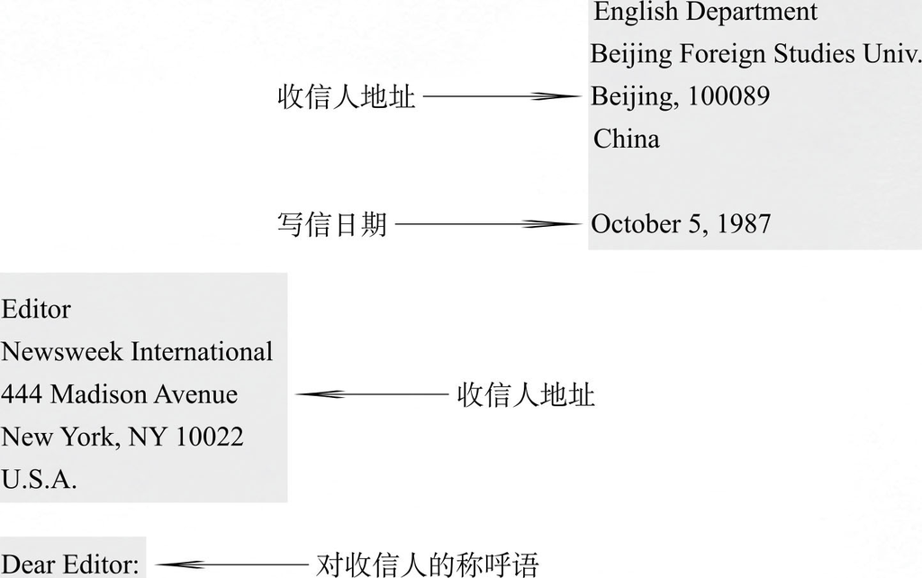

I read in Newsweek (September 14, 1987) that an updated second edition of the unabridged Random House Dictionary of the English Language is being published. **I would be very grateful if you could give me some information on** where and how I can get a copy of the dictionary and if there is a less expensive edition than the one described.

**Thank you for any help you can give me.**

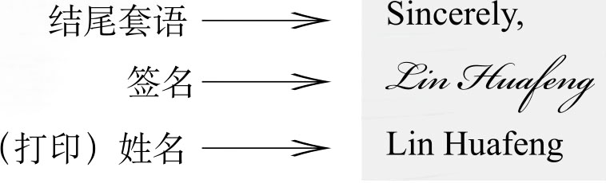

范文52

24 Stone Road,

Manchester.

29 August 2007

Mr. Henry Mason,

Manager,

Mason Mountain Bikes Inc.,

133 Industry Road,

Manchester.

Dear Mr. Mason：

I am writing to request information about mountain bikes, as I have been informed that those produced in your factory are excellent.

Please send me your catalogue and sales literature including your price list by first class mail.

I look forward to your swift reply.

Yours sincerely,

George Newman

George Newman

1．信件的组成部分

英文信件由以下六个部分组成：**发信人的地址和写信日期，收信人的地址，对收信人的称呼语，信函正文，发信人的结尾套语，发信人的签名。**

1）发信人的详细地址和写信日期

通常是写在**第一页的右上角** ，发信人的详细地址和写信日期之间空一行，如范文51、52所示。私人信函中，发信人的地址可以省略。行首可以齐头写，也可以逐行缩进去写；行尾标点符号可有可无。如果信纸本身印有笺头（即发信人的姓名或单位名称、地址），则写信日期常常居中，写在印好的笺头下面相隔大约两三行之处，如范文66；也可以和信的左边线或右边线对齐。

值得注意的是英美人的书信格式略有不同：英国人可能在发信人的姓名、地址后加逗号，最后一行以句号结束；而美国人一般在行尾不用标点符号：

| **英式写法** | **美式写法** |
| --- | --- |
| (Ms. Jennifer Stone,) | (Ms. Jennifer Stone) |
| 20 Fairview Drive, | 20 Fairview Drive |
| Eastbourne, BN18 2BU, | Eastbourne, BN18 2BU |
| England. | England |

此外，英美人信件的**日期写法** 也不同，**英国人** 按照**日、月、年** 的顺序，如1/2/2008，或1 Feb. 2008，或1st February 2008；而**美国人** 采用**月、日、年** 的顺序，如2/1/2008，或Feb. 1, 2008，或February 1st, 2008.

注意信函的地址一定要写清楚（参见第270页便条有关部分）。

2）收信人地址

在公事信函中还要写清**收信人的姓名、详细地址** （见范文51、52）；在私人信函中，这一部分常常省略。收信人的姓名和地址写在（对收信人的）称呼语上面，其格式和发信人的姓名、地址一样；是否在姓名和地址后用标点符号由发信人自定。

3）（对收信人的）称呼语

对收信人的称呼语应与左边线对齐，与收信人姓名、地址相隔两行。**私人书函** 中，称呼语后用**逗号** ，而在**公事信函** 中，称呼语后用**冒号** 。在致亲友的私人书信中可以直呼收信人的名字，但在公事信函里一定要写收信人的姓，如：

Dear Mr./Dr. Stein:

Dear Ms./Miss Santos:

Dear Ms./Mrs Singh:

Dear Professor Smith:

如果收信的女性婚姻状况不详，可用Ms.称呼。Ms.既适用于已婚妇女，也适用于未婚妇女。（Mrs.的复数是Mmes., Mr.的复数是Messrs.）

如果不知道收信人的性别，在Dear后用全名：

Dear Sana Damasi:

Dear T. K. Repin:

如果信是写给某一机构的，或收信人的姓名不详，可以这样称呼：

**Dear Sir:** （或**Dear Madam:** 如果不知收信人的性别，可用**Dear Sir or Madam:** ）

**To whom it may concern:** （仅用于推荐信、证明书、鉴定书一类的信函）

**Dear colleague:** （用来称呼和发信人同一职业的人，通常用于供许多人传阅的书信）

4）信函正文

信函正文中各段的首行可**一律与左边线对齐** （如范文52），也可采用**首行等距缩进** 格式（如范文50、51）。正文中**段落与段落之间应空一行，段落内** 各行间**不必** 如此。

5）发信人结尾套语

公事信函的结尾包括两部分：**发信人的结尾套语** 及**署名** 。如果信不是手写而是用电脑打字，则在签名下还应有**打印的姓名** 。结尾套语写在签名上面一行，第一个字要大写。套语结尾后面要加逗号。在公事信函中，发信人常用的结尾套语有Yours truly，Yours sincerely，Sincerely yours，Cordially yours或Yours cordially，也可以只写Sincerely。

在私人书信中，发信人除了Yours sincerely，Yours truly等等之外，还可依照自己与收信人的关系和亲疏程度分别选用Affectionately，Fondly，Yours with love，With best wishes，Love，Yours，As ever等套语。

这一部分可写在信纸的右边，也可写在左边。有的人喜欢写在中间与信的正文最后一行相隔一两行处（如范文66）。

常用发信人结尾套语

* Sincerely (yours)/Yours sincerely,

* Respectfully (yours),

* Cordially (yours),

* Yours (truly)/Truly yours,

* Best/ Kind/Warm(est) regards (to you [and your family]),

* With (best/warm[est]) regards,

* Best (to you),

* (All the) best from us,

* (With) best wishes,

* With many thanks,

* Affectionately,

* Fondly,

* Love/With love/Lovingly/Much love,

* Yours (with love),

* As ever,

课堂练习18 上列结尾套语中哪些是最常用的？哪些是用于公事信函或正式文体的？哪些是用于私人信函，尤其是给亲朋好友的书信的？

6）签名

在公事信函中，发信人的**亲笔签名** 应写在**结尾套语** 和**打字的姓名之间** 。在打字的姓名后还应注明发信人的职务或职称。在私人书信中，发信人可根据自己和收信人的关系和亲疏程度，或签写全名，或只写名不写姓，甚至还可以写绰号。

如果信中附有履历、支票、收据等等，要加上Enclosure(s)或Encl.等字样，以提醒收信人注意信封里除了信以外，还装有其他材料（详见范文56、58、61、68）。

如果信写好后又想起一些事需要补充，可以写“P.S.”然后再附加几句话。“P.S.”代表postscript，相当于中文的“又及”（详见范文67）。

课堂练习19 比较范文50与下面的中文私人信函，指出二者间五点不同之处。

立平：

你好！9月7日来信收到了。知道你已经收到了我给你寄的几本书，我也就放心了。

下面谈谈我的近况……

……

不多写了。

祝

好！

友林上

2008年9月10日

2．语言

信函的文体和语气是多种多样的。一般说来，私人信件不同于公事信函，前者常用非正式文体，语气比较随便。而后者多用正式文体。不过，两种信件中使用的语言都应清楚明确、直截了当。公事信函的措辞应讲究礼貌，还要注意用词准确、行文简洁。

公事信函的段落通常较短，首段和末段一般只包含一句话。开头的段落用一句话说明事由。必要时，可以再加上一句提及以前的书信联系。回复公事信函时，最好说明何时收到关于何事的书信。切记写公事信函的开头和结尾时，要特别注意礼貌。

3．信封的写法

**收信人的全名和地址** 应写在**信封中间** 。**写信人的全名和地址** 则写在信封的左上角。信封的第一行写收信人的姓名，从第二行起才写地址。地址的写法应按照以下顺序：先写门牌号，然后写街道名，城镇名，县、郡或州名以及邮政编码；如果信是寄往国外的，则把国名写在最后。

Li Mingxin

Dept. of English

Beijing Foreign Studies Univ.

Beijing, 100089

(P.R.) China

Professor Richard Miller

502 North Olive Avenue

West Palm Beach, Florida 33402

U.S.A

课堂练习20 比较以上英文信封与下面的中文信封，指出二者相同和不同之处。

210009

江苏省南京市湖南路47号

钱力胜 先生收

兰州 赵缄

在信封的**上方** ，**邮票** 和**发信人地址之间** ，还可以写以下的字：

1）**Printed Matter** ，表示作为普通信件邮寄的印刷品。

2）**Please Forward** ，意思是“烦交”，用于不知道收信人的新地址时。

3）**Photo(graph)s：(Please) Do NOT bend** 或**Photos Enclosed** ，意思是“内有相片”，“勿折”。

4）如果请Richard Miller教授把信转交给Li Mingxin先生，先写Mr. Li Mingxin，然后写c/o（代表“care of”）Professor Richard Miller，下面再写转信人的地址：

Mr. Li Mingxin

c/o Professor Richard Miller

502 North Olive Ave.

West Palm Beach, Florida 33402

U.S.A.

5）如果你请Li Mingxin先生将信转交给Professor Richard Miller，则不必写地址，只需在信封的中间写Professor Richard Miller，下面写Kindness of Mr. Li Mingxin：

Professor Richard Miller

**Kindness of** Mr. Li Mingxin

课堂练习21 为以下三位发信人写发往国外的英文信封。

| **发信人** | **地址** |  |
| --- | --- | --- |
| 1．钱爱丽 | 河北省保定市青年路12号 | 071003 |
| 2．田志东 | 山东省济南山东大学中文系 | 250200 |
| 3．孙立军 | 北京西什库31号 | 100034 |

| **收信人** | **地址** |
| --- | --- |
| 1．Mr. Arthur Murry | 200 Washington Avenue, Cambridge, MA 02140, U.S.A. |
| 2．Professor Larry Day | 110 Lincoln Hall, Dept. of Theater Arts, Cornell University, Ithaca, NY 14853, U.S.A. |
| 3．Ms. Lillian King | 64 Gordon Gardens, London MW6 1HG, U.K. |

**注意：**

·Street可以写作St., Road可以写作Rd.

·MA表示Massachusetts，NY表示New York州，U.K.表示United Kingdom，联合王国（大不列颠及北爱尔兰联合王国的简称，即英国）

·People's Republic of China可以写作P. R. China

课堂练习22 如果你请Donald Gaud先生带一封信给Marilyn Blake小姐，信封如何写？

课堂练习23

1．解释下面信封上写的词表示什么意思：

Mr. Wang Lixin

c/o Dr. Adrian Smith

308 Tenth Ave, N.

Seattle, WA 98146

U.S.A.

2．如果你请地址为3259 South Street, Halifax, Nova Scotia, Canada B3H 1T5的David Moore先生转交一封信给Adrian Smith医生，信封如何写？

3．写一个给Jerry Larson的信封，信由地址为20 Fairview Drive, Eastbourne, BN18 2BU, England的Jean Stone太太转交。

4．写一个给Nancy Gordon的信封，信由地址为2563 Dole St. #806, Honolulu, HI 96822, U.S.A.的Bill Newton转交。

4．公事信函和私人信函

1）公事信函

（1）询问、请求

范文53

（Lydia Greene）

PO Box 54321

Seattle, WA 98145

Jan. 2, 2006

Professor David Wong

Department of Asian American Studies

City University

164 Hollow Avenue

San Francisco, CA 93154

Dear Professor Wong:

**Please find attached** a copy of a flyer for Asian American Literary Traditions for the International Conference on Asian American Literature in Beijing in May. Could you please have a quick look and confirm whether or not this is satisfactory? If it is, could you let me know how many flyers you will need for the conference, where I should send them, and when you will need to receive them? I could also send a copy of the book for display, if this would be appropriate.

**Thank you for your help!**

Yours sincerely,

Lydia Greene

相关表达法

* I am writing to you in the hope of.../to inquire about...

* I would be very grateful if you could (give me some information on/about [where and how I can get...])

* I look forward very much to hearing from you soon.

* Thank you for any help you can give me.

* I would be very grateful if you could (send me...)

* Thank you for your inquiry about...(I regret to say that...)

（2）邀请

范文54

5 October, 2003

Dear Mr. Harvey:

**We should be very grateful if you could** give a talk on “...” to students of the English Department on Saturday, Oct. 19. If this subject does not suit you, any other similar topic would also be welcome.

We have already had several very interesting talks from distinguished visitors from various countries this semester and look forward eagerly to the opportunity to benefit from your experience and wisdom.

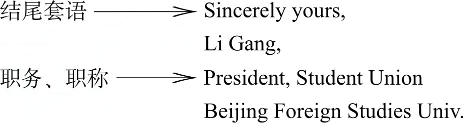

范文55

Oct. 5, 2003

Dear Professor Li:

**On behalf of Acting President Catherine Chapman and Wellesley College, I am extending to you our formal invitation to visit** Wellesley's campus.

We have arranged a meeting between you and Mrs. Chapman for the morning of October 29 at 9:00. We would like to have you as the guest of the College for an overnight stay at the College Club on either October 28 or October 29.

**We are all looking forward to your visit to our campus.**

Sincerely,

（签名）

Helen T. Lynn

Chairman and

Kenan Chair Professor

相关表达法

* You are cordially invited to...

* It is my pleasure to invite you to...

* It is a pleasure for me to invite you on behalf of...to accept an appointment as(visiting professor at...University)

* We would like to ask you to (present a paper in English of 15 minutes in length on your recent findings on...)

* We will be holding/celebrating..., and we would like to extend our invitation to you...

* The event/celebration/ceremony/contest will be held on/has been scheduled for (date).

* I am writing on behalf of...to ask...

* On behalf of..., I am extending to you our formal invitation to visit...

* We are all looking forward to your visit to our...

* I have great pleasure, on behalf of...to invite you to attend the International Symposium (on...sponsored by...) held in (place) on (date)/from...to...

* Thank you (very much) for your (kind) letter of/dated...regarding...

* (I should like to tell you that) I would be very happy to...

（3）申请书和复信

范文56

338 E. 44th St. Apt. 11A

New York, NY 10017

U.S.A.

May 16, 2008

Professor Wang Yiming

Department of English

Beijing Foreign Studies University

Beijing, 100089

People's Republic of China

Dear Professor Wang:

**I am interested in** teaching English in the People's Republic of China. I am qualified to teach reading, writing and literature. An acquaintance of mine, Mr. Liu Yongli of your University **suggested that I should write to you.**

Presently, I work as a teaching assistant in X College in Los Angeles, California, U.S.A. My background is strong in the liberal arts, especially in the English language. I have a Ph.D. degree in linguistics from University of Michigan.

**Enclosed you will find** a copy of my resume. Basically, **I am interested in a position as** a foreign language expert or as a teacher.

**If you have any positions available, please allow me to interview with you.**

**Thank you for your time and consideration.**

Respectfully yours,

（签名）

Christine Stein

Encl.

课堂练习24 如有以下情况，你在英文信中如何写？

1．信封中另附支票

2．信封中另附支票以及你想购买的图书清单

范文57

[figure not shown]

June 14, 2008

Ms. Christine Stein

338 E. 44th St. Apt. 11A

New York, NY 10017

U.S.A.

Dear Ms. Stein:

Thank you for your letter of May 16. I must apologize for taking so long in answering, a situation caused by a number of recent conferences.

**We appreciate your desire to offer your services to** our University. **From the information you supplied about yourself, there would be no question about your qualifications. However** , we have only a small quota for foreign teachers, and **all our positions for this year and the coming academic year have already been filled.**

**We shall keep your offer on file and inform you should there be any openings.** In the meantime, you might try other colleges here in Beijing or other cities.

Thank you once again for your offer. Best wishes for success.

Sincerely,

（签名）

Wang Yiming (,)

Chairman

Department of English

范文58

Date

Chairman

Department of Sociology

University of Massachusetts at Amherst

Amherst, MA 01003

U.S.A.

Dear Sir:

**I am writing to you in the hope of obtaining** a one-year grant to do some research work in your department.

**Enclosed please find** three letters of recommendation and my resume.

Thank you for your time and consideration. **I look forward to your reply.**

Sincerely yours,

（签名）

Luo Liguo

Encl.

范文59

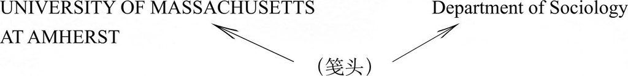

Thompson Hall

Amherst, MA 01003

(413) 5x5-0577

June 30, 2007

Mr. Luo Liguo

Dept. of History

Minzu University of China

Beijing, 100081

P.R.C.

Dear Mr. Luo:

**Thank you for your inquiry about** obtaining a one-year grant to do some research work in our department. **I regret to say that** at the present time there are no grants available, and there is nothing immediately in prospect.

Thank you for your interest in our department. I wish you well in finding a one-year grant for doing research this coming year.

Sincerely yours,

（签名）

Joseph Lasky

Professor and Chair

课堂练习25 指出范文56、57、59格式上的相同与不同之处。

范文60

Date

Dear Mr. Stratton:

**I would like to apply for the summer position of** proofreader which you advertised in the June 16 issue of Beijing Youth . Currently I am a junior at Beijing Foreign Studies University, where I am working toward a BA degree in English.

Last summer I held a similar position with Beijing Review , working as their summer replacement in the editorial department. I enjoyed the seemingly tedious work which I knew would further my professional goal of becoming an editor. The experience also helped me improve my typing skills, which I understand, is required for the job I am applying for. Mr. Liu Kailu, head of the editorial department thought well of my ability, enthusiasm, and devotion. He said that he would welcome a call from you if you wish to know more about me. His office telephone number is 8316x645.

In Beijing Foreign Studies University I have been working hard and doing well in the major courses. I am fluent in both written and spoken English and my reading skills are also satisfactory. Besides, I am learning computer languages such as Basic and Fortune, so I believe I can work for your magazine without much additional training. My English teacher, Professor Shi Danian has kindly agreed to write a reference for me if it is required.

**I am available for an interview every afternoon** except Wednesday. Please contact me at 8421x277, ext. 309 or P. O. Box 235, Beijing Foreign Studies University, 100089.

Thank you for your consideration.

Sincerely yours,

Su Hua

范文61

Date

Dear Professor Cooper:

I have read the annual prospectus issued by your school and found that it has the best graduate program of cross-cultural studies, which you are currently presiding over. **I am greatly interested in the program and hope that I may do my MA work under your instruction.**

I am 28 years old and am now working in the Chinese People's Association for Friendship with Foreign Countries, in charge of affairs in the Pacific areas. I love my work, as it brings me into contact with all kinds of people. At the same time, I feel the urgent need to improve myself and update my knowledge so that I can do my work better.

I graduated from Beijing Foreign Studies University in 1989, majoring in English and minoring in cross-cultural communications. In college I took such courses as World History, American Society and Culture, Introduction to European Culture, and Cultural Exchanges between the East and the West, which were all conducted in English. So I believe I will have no difficulty in my MA studies.

I have broad interests in various fields such as history, literature, music, and photography. I love sports, too. I joined the Literary Society in college and was also on the English Department's volleyball team.

I have discussed my application with three of my former professors, who have urged me to apply and have kindly written **letters of recommendation** for me, **which I enclose with this letter.**

**I would be very grateful if you could send me the necessary application forms and any information about your scholarships or teaching assistantships.**

**I look forward very much to hearing from you soon.**

Sincerely yours,

Zhao Jingsheng

Enclosures

相关表达法

**大学入学申请书**

* I am writing to ask whether you could/This is to ask you to kindly send me some information about your college and for the application forms.

* I am writing to you in the hope that I may obtain an opportunity to do graduate study in your university.

* I am interested in your graduate school...

* I wish to study for an MBA degree in your school...

* Thank you very much for the information you sent me about your college and for the application forms, which I am returning with three letters of recommendation, a certified copy of my transcript and...

* Thank you for your enquiry about the possibility of coming as a visiting Scholar to the Department of... We should be very pleased to welcome you here and to invite you to participate in the activities of the Department.

**奖学金/研究生半工半读助学金/会员资格/谋职申请书**

* I should like to apply for one of the scholarships that your department may be offering to students from other countries. Would you please send me the necessary application forms and any further details about the scholarships...?

* I should be very grateful if you could let me have details of any teaching assistantships in electric engineering that your department may have...

* I am thinking of applying for membership of your library/club, I should be grateful if you would let me know how I should go about it.../would you be kind enough to let me know the facilities you provide?

* Thank you for the information about your scholarships/teaching assistantships/for the scholarship application forms which you were kind enough to send me...

* Thank you for your help in this matter.

* I see from your advertisement in yesterday's China Daily that...

* I am writing in response to your ad...

* I should like to apply for the post of which you advertised in yesterday's China Daily ...

* I should very much like to be considered for the post of... which was advertised in...

* I am looking for a job as ..., and would be grateful if you would consider me for such a post in your firm.

* I am interested in the post... X suggested that I should write to you . Enclosed you will find (a copy of my resume).

* Your name was given to me by...

* I should be glad to have a personal interview and can furnish references if desired.

* I am forwarding/submitting my resume...

* My qualifications include...

* My strength is in...

* I can come for an interview at any time convenient to you.

* If you have any positions available, please allow me to interview with you.

* Thank you for your time and consideration.

* I am available for an interview every afternoon except.../on any day and at any time you may appoint.

* I look forward to hearing from you and I do hope I shall have the opportunity of an interview.

* I look forward to your early reply/the interview.

* Thank you for your letter/I have received your letter of/dated...

* We have studied your application/letter...carefully...

* We will reply to your application/letter shortly...

* You will be hearing from...shortly...

* I received your... and I am happy/pleased to inform you....

* I am/would be delighted to accept...

* We would like to offer you the position of...

* We were very much interested in your letter applying for... Can you come in for an interview on...?

* While we are very much interested in your qualifications, we are afraid that you do not quite meet our current needs.

* Unfortunately, because of financial difficulties, we are unable to recruit any employees this year, much as we would like to do so.

* After carefully considering... I regret/am sorry to say... I do hope/I think that you will understand...

* We appreciate your desire to offer your services to our University. From the information you supplied about yourself, there would be no question about your qualifications. However, we have only a small quota for foreign teachers, and all our positions for this year and the coming academic year have already been filled.

* We shall keep your offer on file /in mind when there is a vacancy/should there be any openings.

**签证申请书**

* I am planning to visit Singapore in June and should be grateful if you would let me know what I have to do to get a visa...

* Will you please kindly let me have a visa for entry to your country? I enclose the forms which you sent me and also two photographs...

（4）介绍信

范文62

532 Overbrook Road

Bloomfield Hills, Michigan

48013

January 4, 2008

Professor Liu Fangyi

Dept. of English

Nanjing University

Nanjing, 210008

People's Republic of China

Dear Professor Liu:

**May I introduce** Professor Robert Kim, Professor of Chinese language and literature at San Francisco State University and Director of the Institute for Sino–American Studies at San Francisco State University.

The Institute for Sino-American Studies has responsibility for facilitating academic exchanges between appropriate institutions in China and San Francisco State University. The Board of the Institute has requested that its Director pursue discussions and preliminary negotiations with likely institutions in China.

**We would greatly appreciate your receiving** Professor Kim **as our representative** in these matters and engaging in discussions with him.

Truly yours,

（签名）

John M. Gould,

Chairman of the Board

Institute for Sino–American Studies

相关表达法

* May I introduce...

* We would greatly appreciate your receiving...as our representative...

（5）贺信

范文63

Mr. Hugh MacDougal

（地址）

June 18, 2007

Dear Mr. MacDougal,

**I was very happy to learn that** you have been elected President of the Scotland China Association **and I would like, on behalf of** the Chinese People's Association for Friendship with Foreign Countries **and in my own name, to express to you my warmest congratulations.**

I hope that during your tenure of office the relations of friendship and cooperation that already exist between our two organizations will be further developed. Let us join our efforts to make greater contributions to the promotion of mutual understanding and friendship between the peoples of China and Scotland.

With best wishes.

Sincerely yours,

（签名）

Chen Haitao

President

CPAFFC

相关表达法

* I congratulate you on...

* Please accept my (warmest/heartfelt/hearty) congratulations...

* I would like to extend/offer my sincere/cordial/deepest congratulations...

* I send you my hearty congratulations on (your recovery from your long illness).

* I was very happy to learn that...and I would like, on behalf of...and in my own name, to express to you my warmest congratulations.

（6）推荐信

范文64

Date

**To whom it may concern:**

Tao Xiaoling was enrolled as a student in my...course at the...University in 2003. Her performance in class was outstanding.

Ms. Tao participated in all of the class discussions with obvious interest, and she made valuable contributions. She has a keen mind, capable of clear logical analysis of complex subjects. She also has worthwhile original ideas, and she expresses them clearly and effectively.

In addition, Ms. Tao has a pleasant personality. She gets along very well with other people because of her warm and friendly attitude toward them.

Ms. Tao has already proved that she can do outstanding work as an undergraduate in our university. I am sure that she would continue to do well in any university in Canada. **I recommend her to you with no reservations.**

Sincerely yours,

（签名）

（打印的姓名）

（职务、职称）

相关表达法

* To whom it may concern:

* I recommend...to you with no reservations.

2）私人信函

范文65

Date

Dear Liping,

Jim and **I want to thank you again for** your part of the delicious dinner at the Wang house the other night. Everything was marvelous—obviously; I'm afraid that I'll go back to Boston even rounder than when I arrived!

We want to thank you for all sorts of other things too—but I imagine we'll see you again—so **I'll end for now** .

As ever,

Elizabeth

范文66

笺头

Date

Dear Liping:

**It has been a few months since I last wrote you** and sent you a box of books, and as I have not heard anything from you, I thought I would write again to make certain that you did, in fact, receive my letter and the books.

I am concerned about the books arriving there and would appreciate your letting me know if you have received them and if they were the kind of books that you could use.

Best regards,

George

范文67

Date

Dear Liping,

Liu Danhong called me about two weeks ago and said he had a message from you, so I asked him and his wife to have dinner and invited Hugh and Evelyn Levin, whom I thought it might be good for him to know. I was delighted to get the lovely cloth shoes and to hear that your father is recovering from the operation and that things seem hopeful.

I continue to read about China and do intend to visit within a few years. There is news from China almost every day in the New York Times now. It must be that Americans are fascinated with the many changes.

Our family are all well, and that is the thing I am most thankful about. Our oldest son is now married in California, and will have his first professional job in Seattle, Washington. Our second is in graduate school in economics in Texas. Our third is majoring in Mechanical Engineering at UMass.

**Please let me know if there is anything I can send you** —books or—what? Hugh Levin is leaving for China tomorrow, leading a tour, so I'm going over this evening to ask him to mail this.

Warm regards to Zhou Zhifang and heartfelt best wishes for your father's recovery.

Love,

Annette

P.S. Ma Shuren and her husband stayed with me for a weekend in August. I hope they manage another one before the end of the month. Please give our greetings to Yang. I still remember him with affection.

范文68

Date

Dear Liping:

**I was delighted to receive your letter of December 10,** but sorry to hear about Professor Fang's illness. I hope the new year will bring him renewed health and strength.

Unfortunately, Helen Flagler was unable to go to China as planned, and I'm sorry to report that she passed away earlier this month. A memorial service in tribute to her was held at the Center last week. A copy of the program is enclosed.

I appreciate your recommendation of Ms. Yan Fangzhi, and I will make certain that a copy of your letter is placed in her application review folder.

I have recently accepted the post as Director of the Institute of Asian Culture at the Center. I find this position a very challenging one which entails a lot of administrative work. The Center will also be looking forward to greeting our new president, Dr. Michael Palana, a China specialist from Oxford. Dr. Palana is planning to start in January. We have an exciting year ahead of us.

**Carolyn joins me in sending all good wishes to you and your family.**

Sincerely,

Philip

Enclosure

范文69

Date

Dear Zhang,

Thank you very much for the postcard you sent us on your arrival home. We were glad to know that you had arrived home safely and were settling down to your way of life again. We also received today a card from Yang Daoming and perhaps you would be kind enough to thank him for me if you should see him. Eddie was thrilled to receive a card from you as well and I know he will be writing to you.

Matthew is getting to be a little chatterbox and is now at the climbing stage. I think he still remembers you as when he wakes up in the mornings he sometimes calls out "Zhang." I'm sure he also misses the sweet-tin from the second drawer of the chest in your room!

We do hope you are reaping the benefit now of your studies in England, and that it is a help to you with your teaching. We often think of you whenever there is news on the TV from China.

**Please remember us to all your friends and should you ever have time to write we would be pleased to hear from you.**

Matthew sends you all a big kiss. Best wishes,

James, Linda, and Matthew

私人信函的开头和结尾表达法

* I am sorry that it has taken me so long to reply..., but...

* You will be very glad to hear that...

* I thought you would be interested to hear of...

* Please remember me to.../Please say hello for me to...

* Please accept our thanks in advance.

* Please say hello for me to Mrs. Johnson.

* Please remember me to your father.

* Please give everyone my warmest regards.

* If there is anything I can do for you, please do not hesitate to let me know.

* In the meantime, please accept my very best wishes for a complete and speedy recovery.

* ...join(s) me in sending you our warmest congratulations/in conveying our sincere sympathy to members of his family.

作业5

第一部分 私人信函

1．给你的外国笔友写一封私人信函，谈谈你的家庭、学校、工作、兴趣爱好或其他你想要他/她了解的有关你的情况。

2．写一封私人信函给一个从国外或其他城镇来看望你的（外国）好友，告诉他到你家的最佳方式、乘车路线，你的家乡/所在城市的天气、气温，他/她需要带什么衣物等有关信息。

第二部分 公事信函

1．写一封公事信函

1）邀请一位知名教授给你系学生做讲座；

2）要求某大学函寄该校简介和入学申请书表格；

3）申请奖学金（scholarship）/研究生半工半读助学金（assistantship）；

4）求职；

5）要求对方提供新产品/新书/新药的有关资料。

在（2）、（3）、（4）中写信人应提供有关年龄、学历、资历、工作经历、兴趣爱好等方面的情况以表明自己的优势和具备担任某职务的条件、资格。

2．下面是一封外国谋职者的来信，写一封回信答复他信中提及的有关问题。

May 20, 2001

Head, English Department

...University

(Address)

Dear Sir/Madam,

I would like to be considered for a teaching position at your university during the coming academic year.

My main interests and greatest strengths lie in two areas: the study of the history of literature in relation to the history of ideas; and the formal analysis of poetry. I am also an experienced teacher of writing.

In addition to the teaching experience indicated in the enclosed resume, I am qualified to teach the literature of the American South.

If you are interested in my working for you, would you please give me the following information:

What is the length of the school year?

What is the length of the semester?

What is the length of the class session?

What is the average class size?

How many years of English education have your students had?

What English textbook is currently being used by your university and who is the publisher?

Can you provide information as to available housing, transportation, and medical care?

I look forward to hearing from you if my background and credentials meet your needs.

Sincerely yours,

Gregory H. Leach

Gregory H. Leach

相关表达法

* Your teaching responsibilities include...

* You will be provided with a two-room apartment on campus.

* Your medical expenses will be covered by the school.

3．下面是一封刊登在 China Daily 上的美国波士顿读者来信，写一封回信解释中国的独生子女政策。你署名的公开信将刊登在该报上。

Editor:

I'm a woman's liberationist. I read in a newspaper that women in China are not allowed to decide how many children they want to have. There is a law forbidding all women to have more than one child, and any woman who gets into a second pregnancy is forced by law to undergo induced abortion followed by surgical sterilization. I don't see how a country calling itself a socialist state could trample on this first and most sacred of women's rights—the right to motherhood—in such a flagrant way.

Ruth Hancock

VII．履历

履历（英文常简化为c.v.），即简单的个人经历，是招聘单位往往要求谋职者提供的信息。

履历通常包括以下几项：**姓名、地址、电子邮件地址、电话、出生日期、学历、工作经历** 等等。此外，还可以加上**婚姻状况、国籍、现任职务、职称、获奖情况、研究成果/发表论文著作、科研课题或方向、参加何社会/学术团体、掌握何种外语、留学/进修/工作国别、兴趣爱好** 及**推荐人/介绍人/证明人姓名** 等等。增加的各项应穿插到有关的项目前后，如果推荐信不随履历附上，则应把推荐人姓名列为最后一项。

写履历时，应设法突出自己的强项。

**履历的组成部分**

1．**姓名** 中国人姓名的写法与大多数西方人不同，不是名在前、姓在后，而是姓在前、名在后。为了避免误会，可以**在姓后加一个逗号** ，如：**Wang** ，Ming；或**大写姓的每一个字母：WANG** Ming。

2．**地址** 可以既写单位地址或临时住址，又写家庭住址；给临时住址时，应注明至何时为止，如：

Temporary address:

17 University Ave.

Providence, R1 02906

(until Dec. 31, 2xxx)

3．**电话** 办公室电话号码后加（O）或（W），住宅电话号码后加（H）。

4．**婚姻状况** （英文用Marital Status） 未婚用Single，已婚用Married。No/Two children表明无子女或有子女二人。

5．**学历** （英文用Education） 可**按照时间顺序** 列出就读的学校（通常从何年入大学开始，或何年获得第一个学位开始），也可以**从最后就读的学校及学习时期写起** 。需要记住的是在填写工作经历、获奖情况以及发表著作各项时，应采用同样的写法，或按时间顺序一律从前（过去）往后（现在）填写，或全部从后（现在）往前（过去）填写。如：

1）

1978-1979

Nankai University

Major: History

1979-1982

Zhongshan University

Major: History

1988-1989

Harvard University

Major: American Civilization

2）

1985

M.A. in Computer Science, Tsinghua University

1980

B.A. in Mathematics, Lanzhou University

6．**工作经历** 除自何年月至何年月以外，还应写单位名称以及担任的职务或职称，如：

1992-

Associate Professor of Economics,

Wuhan University

1986-1992

Lecturer, Henan University

7．**获奖情况** （英文可用Awards/Honors and Scholarships） 包括获得的奖学金、科研基金或资助、荣誉称号或会员资格、发明奖、优秀科研成果奖等等：

1988-1989

Fulbright Award, United States State Department Exchange Program, Washington, USA.

1990

Excellent Student, ...University

8．**发表著作** （英文用Publications） 论文、译文和书的格式见第八章论文中书目卡的写法，略去作者名。

著作：Introduction to English Stylistics . Beijing: Foreign Language Teaching and Research P, 1987.

译作：The Cycle of American Literature . By Robert E. Spiller. Trans. Shanghai: Shanghai Foreign Language Education P, 1990.

9．**参加何社会/学术团体** （英文用Professional Affiliations/Memberships）在此项下面可填写:

1971-

Member, Yunnan Provincial Writers' Association

1980-1984

Secretary-General, Chinese Association for African Studies

1982-

Council Member, Chinese Translators' Association

10．**掌握何种外语** （英文用Languages）在此项下面可填写：

Chinese and English (fluent in both speaking and writing)

French (reading only)

11．**证明人/推荐人/介绍人** （英文用References/Referees） 指能提供有关你的情况或为你写推荐信的人，通常要求两三名。切记应**事先征得证明人的同意** 方可填写他们的姓名。除**姓名** 外，还应填写证明人的**职务、详细地址、电子邮件地址** 以及**电话号码** ：

Professor Tan Yonggang (Chairman)

Department of Foreign Language and Literature

Hubei University

Baoyiyan, Wuchang

Hubei, 430062

P．R.C.

E-mail address: Tanyg@sina.com.cn

Telephone: 6119x384 Ext. 565

范文70

CURRICULUM VITAE

**NAME:**

Edward Lee Hornby

**ADDRESS:**

1/F., Hang Lung Bank Bldg.

46-48 Granville Rd.

Tsimshatsui, Kowloon

**E-MAIL ADDRESS**

elhornby@hotmail.com

**TELEPHONE:**

72141x28

**DATE OF BIRTH:**

Aug. 8, 1958

**MARITAL STATUS:**

Single

**CITIZENSHIP:**

U.S.

**EDUCATION:**

August 1990

Master of Business Administration University of Central Florida, Orlando, Florida 32816

April 1984

Bachelor of Business Administration East Michigan University, Ypsilanti, Michigan 48197

**WORK EXPERIENCE:**

April 1991 to Present

International Education Services,

Hong Kong

Instructor

**Conduct** education classes at different businesses at various locations.

**Classes include** : English Language, International Business, Negotiation Skills, and Financial Statements.

August 1988 to April 1991

Tasco, Maitland, Florida

Vice President of Operations

**Responsible for** complete operation of all home building and home remodeling activity. **Duties included** setting up budgets, hiring subcontractors, materials estimation, purchasing of materials, budget maintenance, and review of financial statements.

October 1985 to July 1988

U.S. Home Corporation, Maitland, Florida

Manager

Responsible for complete management of construction site. Duties included setting up budgets, hiring of subcontractors, supervision of actual construction(scheduling, quality assurance and budget control), material estimation, and review of financials at job completion.

May 1984 to October 1985

Kelly Services, Orlando, Florida

Account Representative/Supervisor

Responsible for evaluation, hiring and placement of personnel in temporary positions. Established new accounts, serviced existing accounts, and maintained accounts receivable.

**LANGUAGES:**

Spanish, spoken and written (fluent)

French, spoken (good)

**INTERESTS:**

Cycling, traveling, fishing, language studies

**REFERENCES:**

**Available/Furnished upon request**

范文71

**Stephanie Porter**

355 20th Ave.

Columbus, OH 43201

sporter@yahoo.com

Telephone (614)4x1-5650

**Work Experience**

Oct. 1988 to present

Ohio Star , Columbus, OH

Write advertising copy and solicited ads.

June-Aug. 1987

The Mirror , Columbus, OH

June-Aug. 1986

Full-time proofreader (substituted for head proofreader, 1987).

June-Aug. 1985

Grim's Variety Store, Somerville, MA

Part-time, 20 hours per week. Sales clerk (with stocking and pricing duties). Also made deliveries and called in supply orders.

**Education**

Sept. 1985-June 1988

Illinois State University

Received B.A. in English, June 1988

Sept. 1984-June 1985

Springfield Community College

Sept. 1980-June 1984

Holyoke High School

Scholastic honors:

Nicholas Evans Scholarship in English

Literature, 1987-1988.

Illinois State Scholarship, 1984-1988.

Technical training

**Attended** a two-week seminar on

"Advertising in Today's Marketplace," sponsored by College of Business and Murray County Association of Commerce and Industry.

**Personal Data**

Age 30

Married, one child

Health Excellent

Willing to relocate

Memberships

Student Association for Women

Journalism Club (President, 1986-1987)

Hobbies

Photography, swimming

**References**

Ms. Helen Grim

Dr. John Lindsay

Mr. David Reed

Grim's Variety Store manager

Professor of English

Advertising Manager

386 Washington St.

Illinois State Univ.

682 Sumner St.

Somerville, MA 02143

Normal, IL 61761

Akron, OH 44311

Phone (617)62x-0977

Phone (309)43x-9903

Phone (212)43x-0520

范文72

**Curriculum Vitae**

**Name**

Luo, Liguo

**Address**

Dept. of History

Minzu University of China

Beijing, 100081

People's Republic of China

**E-mail**

luoliguo@sina.com.cn

**Telephone**

689x0077 Ext. 3931 (O) Ext. 2024 (H)

**Date of Birth**

May 8, 1953

**Nationality**

Chinese

**Education**

1973-1977

Renmin University of China, Beijing

Major: History

1983-1985

University of Hawaii at Manoa

Major: History

1987-1991

Minzu University of China, Beijing

Major: Ethnology

Received Ph. D. in Ethnology, July 1991.

**Languages**

English, fluent in spoken and written Japanese and French, able to read

**Professional Experience**

1977-1987

Assistant, Lecturer of History,

Minzu University of China

1992-Present

Professor of Sociology,

Minzu University of China

Courses offered: Introduction to Sociology, Ethnology, and Policies on Ethnic Groups

**Awards and Scholarships**

1977

"Excellent Student," Renmin University of China

1980

"Outstanding Teacher," Minzu University of China

1987

Recipient of Wu Wenzao Scholarship, Minzu University of China

**Publications**

"China's Regional Autonomy Law." China Daily , 10 Dec. 1989: 4.

"The Influence of Islamism on Chinese History." Chinese Muslims 4 (1990): 14-16, 21.

A Brief History of the Jews in China. Beijing: New World P, 2003.

相关表达法

* References available/furnished upon request.

* Duties include(d)...

* Responsible for...

* Responsibilities include(d)...

* Attended...

* Conduct(ed)...

* Assist(ed)...

* Completed...

* Coordinate(d)...

* Develop(ed)...

* Design(ed)...

* Engineered...

* Expanded...

* Improved...

* Initiated...

* Increased/Reduced/Saved...

* Led...

* Organized (successfully)...

* Pioneered...

* Researched...

* Work(ed) (closely) with...

课堂练习26 重写范文72的Education，Work Experience，以及Awards and Scholarships几项，从最后就读的学校、现在从事的工作写起，从当前往过去推。

作业6 写一份个人履历。

参考答案

课堂练习1

范文1 一般的中文通知大多采用这种形式。

通知

兹订于10月5日（周三）下午3时在405教室召开全系大会，请全体教师准时出席。

系办公室  
9月31日

范文3

篮球赛  
英语系 对 法语系

时间：10月10日（周一）

下午5:00

地点：1号操场

课堂练习2

相同点：

中英文布告都包括三项内容：日期—星期几—几点、地点、活动内容。

不同点：

1．英文布告中星期几放在日期前，而中文布告中星期几一般放在日期后。

2．英文布告中写星期几时，可以将词全拼出来（如范文1中**Wednesday** ）或用缩写形式（如范文3中**Mon** .），月份的写法也如此（如**October** 或**Oct** .）。

3．英文中<sup>#</sup> 1写成中文时为**1号** ，**不能用<sup>#</sup> 1** 代替中文的1号。注意符号<sup>“#”</sup> 总是放在**数字前** ，不是数字后。

课堂练习3

Monday, Tuesday, Wednesday, Thursday, Friday, Saturday, Sunday

Mon., Tues., Wed., Thurs., Fri., Sat., Sun.

课堂练习4

January, February, March, April, May, June, July, August, September, October, November, December

Jan., Feb., Mar., Apr., Aug., Sept., Oct., Nov., Dec.

May不能缩写，June和July可以缩写成Jun.和Jul.，但最好全拼出来。

课堂练习5

有关活动的补充信息，如报告人的职称/职务、著作、所在单位等，或有关参与活动者的细节。

课堂练习6

布告、通知涉及的人（选课学生、买主、失者）和物（讲义，购买、丢失的物品）。

课堂练习7

范文19用语最规范，最客气，范文17用语较不讲究客套。我们可以写得既不讲究客套又不失礼，如范文17中用情态动词could客气地表示请求。

课堂练习8

Robert/Mr. Stein,

I've arranged for Mr. Zhou to take you to the airport. Please wait for him at 11 a.m. at the hotel lobby.

（你的名字）

**Note：** 称呼对方为Robert或Mr. Stein根据你和他的熟悉程度而定。

课堂练习9

Linda,

Please let me know as soon as possible Henry's phone number. Thanks.

（你的名字）

课堂练习10

Dear Professor Gates,

I would be very grateful if you could lend me your History of the AfroAmerican Novel for a few days. Please leave the book in my mailbox, <sup>#</sup> 68.

（你的名字）

课堂练习11

Dear Ms./Professor Evans,

Mr./Professor Zhou asked me to leave the book you wanted with Miss Zhang in the department office. Please leave/drop a note for Mr./Professor Zhou in his mailbox, <sup>#</sup> 18, when you get the book. Thank you.

（你的名字）

课堂练习12

Dear Mr. King,

I'm sorry I have been unable/for not being able to get the book you wanted from the school library. I'll try other libraries to see if I can find it.

课堂练习13

Feng Libo

Wed. Mar. 12

Dear Professor Brown,

I apologize/I would like to express my apologies for not being able to attend the meeting. I have a fever and have to stay in bed.

（With many apologies,）

Zhang Xiaowen

Nov. 14

Annette,

(I'm terribly) sorry that I won't/shan't be able to keep our 10 o'clock appointment for Nov. 17. I happen to have some urgent business out of town (and won't/shan't be back until Nov. 18). I'll give you a call/ring you up as soon as I come back (to arrange for another appointment).

Xiaowen

课堂练习14

Linda,

Many thanks for getting Henry's phone number for me. (I really appreciate it.）

（你的名字）

课堂练习15

Dear Professor Gates,

I am very grateful to you for lending me your History of the Afro-American Novel . I'll return the book as soon as I finish reading it.

（你的名字）

课堂练习16

Nancy,

Would you like to go/How about going to the Saturday concert with me? I have got/bought two tickets for it.

（你的名字）

课堂练习17

(Dear) Professor Jarvis,

Students of the English Department will hold a speech contest in Room 401 at 7 p.m. next Wednesday/Wednesday next week, May 4. We would be very happy if you could be one of the judges.

（Chairperson of the Student Union,）

（你的名字）

**Note: next** 指the first one that comes after the present or previous one，因此如果留条时间是周一，则next Wednesday指本周三，不同于Wednesday next week，下周三。

课堂练习18

最常用的结尾套语是Sincerely yours，Yours sincerely，Sincerely和Yours。上述结尾套语以及Cordially yours，Respectfully yours和Yours truly用于公事信函或正式文体。私人信函，尤其是给亲朋好友的书信，结尾套语可以用Affectionately，Fondly，Love，With love，Much love，Lovingly等。

课堂练习19

1．**日期：** 英文信函的日期写在**右上角** ，中文信函的日期写在信末尾，在写信人名字下面。中文信函中，日期按照年—月—日的顺序；英文信函中，年放在最后。

2．**（对收信人的）称呼语** ：英文信函习惯在收信人前加**Dear** （或My dear），此处Dear只是用来**表示礼貌** ，不等同于中文的“亲爱的”。因此即便是第一次给不熟悉的人写信，也要在称呼语中用Dear。如果写信给亲朋好友、兄弟姐妹，可以把姓省去，只写名或爱称，如写Bill代替William。如果是给长辈或上级写信，则应在姓或姓名前加**Mr., Mrs.，Miss** 或**Ms.，** 如**Dear Dr. Smith, Dear Professor Lusk, Dear Mr. Henry Cole, Dear Mrs. Green, Dear Ms. Isabel Yale** 等。在英文信函中，（对收信人的）称呼语后用**逗号（,）** 或**冒号（:）** ，在中文信函中，习惯用冒号。

3．**结束语：** 英文信函有时——但不一定必要——用With best wishes后面加逗号（,）结尾，中文信函却几乎总是用“祝好”一类词后面加惊叹号（!）结尾，而且往往另起一行。

4．**签名：** 英文信函中，写信人通常在签名上一行写Yours或Sincerely yours后面加逗号“, ”；此处Yours不等同于中文的“你的”，这两个字只用于给很亲密的人的中文信函中。中文信函一般只需签名，签名后面常写“上”字。有的学生给老师写信时在签名上面加“（您的）学生”以示尊敬；给老师/教授写英文信函却不应在签名上加student一词。

5．中文的“（寄来的照片/你6月1日的来信）**收到了** ”，英文一般用**Thank you** **for** the photographs/your letter dated June 1来表达,尽管也可以写I've just received the photographs you sent/your letter dated June 1。

课堂练习20

相同点：

邮票都贴在信封的右上角，收信人的名字都写在信封正中。

不同点：

1．英文信封：发信人姓名、地址写在信封**左上角** ，姓名写在地址上一行

中文信封：发信人姓名、地址写在信封**右下角** ，姓名写在**地址下** 或**地址后** ，通常只需写城市名和发信人的姓，如“兰州赵寄”

2．英文信封：收信人姓名、地址写在信封中间或稍偏右处；**姓名在上行** ，**地址在下行** ，两行齐头排

中文信封：**地址在上行，姓名在下行** ；姓名位居信封中间，两行不齐头排

3．英文信封和中文信封的地址写法不同，**顺序** 正好**相反** ：不很长的中文地址通常写一行，按照国名—省名—城市名—街道名—门牌号从大到小顺序；英文地址分三行齐头写，从门牌号开始按照从小到大顺序，第一行写门牌号—街道名，第二行写城市名—州名，第三行写国名。

4．中文信封的邮政编码写在左上角，英文信封的邮政编码写在州名后。

课堂练习21

1.

Qian Aili

12 Qingnian Street

Baoding, Hebei Province, 071003

China

Mr. Arthur Murry

200 Washington Avenue

Cambridge, MA 02140

U.S.A.

2.

Tian Zhidong

Chinese Department

Shandong University

Ji'nan, Shandong Province, 250200

People's Republic of China

Professor Larry Day

110 Lincoln Hall

Dept. of Theater Arts

Cornell University,

Ithaca, NY 14853

U.S.A.

3.

Sun Lijun

31 Xi Shi Ku

Beijing, 100034

P.R.C.

Ms. Lillian King

64 Gordon Gardens

London MW6 1HG

U.K.

课堂练习22

Miss Marilyn Blake

Kindness of Mr. Donald Gaud

课堂练习23

1．这是一封请Dr. Adrian Smith转交给王先生（Wang Lixin）的信，Dr. Adrian Smith的地址为308 Tenth Ave, N., Seattle, WA 98146, U.S.A.。

2.

Dr. Adrian Smith

c/o Mr. David Moore

3259 South Street

Halifax, Nova Scotia

Canada B3H 1T5

3.

Mr. Jerry Larson

c/o Mrs. Jean Stone

20 Fairview Drive

Eastbourne, BN18 2BU

England

4.

Ms. Nancy Gordon

c/o Mr. Bill Newton

2563 Dole St. #806

Honolulu, HI 96822

U.S.A.

课堂练习24

1．除了在信的左下角写**Enclosure** 外，还应加一小段文字，以Enclosed please find a **check** (of $150)...开头。

2．除了在信的左下角写**Enclosures** 外，还应加一小段文字，以Enclosed please find a check (of $150) and **a list** of the books I wish to buy/I'd like you to send me...开头。

课堂练习25

相同点：

所有范文都包括六部分：发信人的地址和写信日期、收信人的地址、对收信人的称呼语、信函正文、发信人的结尾套语、发信人的签名。信文段落与段落间空一行，段落内不空行。

不同点：

三个范文的地址写法不同——范文56的地址写在右上角，范文57的地址写在信纸左边，收信人的地址上面，范文59的地址写在中间。范文57的信文与范文56和范文59不同，采用各段一律与左边线对齐的格式，范文56和范文59采用各段首行等距缩进格式。

课堂练习26

**Education**

1987-1991

Minzu University of China, Beijing

Major: Ethnology

Received Ph. D. in Ethnology, July 1991.

1983-1985

University of Hawaii at Manoa

Major: History

1973-1977

Renmin University of China, Beijing

Major: History

**Professional Experience**

1992-Present

Professor of Sociology,

Minzu University of China

Courses offered: Introduction to Sociology,

Ethnology, and Policies on Ethnic Groups

1977-1987

Assistant, Lecturer of History, Minzu University of China

**Awards and Scholarships**

1987

Recipient of Wu Wenzao Scholarship, Minzu University of China

1980

"Outstanding Teacher," Minzu University of China

1977

"Excellent Student," Renmin University of China

作业1

Part I

1．

**Class Meeting**

Fri. June 2

5 p.m.

Room 305

2.

**Film**

**The Long March**

in the Auditorium

Friday July 1

2:00—4:00 p.m.

￥ 3

3.

**Notice**

Students who have paid for World History please come to the Dept. Office for the book on Thurs. March 7 between 3:00 and 5:00 p.m.

4.

**Notice**

Those who want/wish to go to/watch/attend the Peking opera The Monkey King please come to register for tickets at the office of your tour guide, Mr. Zhang.

作业2

Part I

1.

Dear Mr. and Mrs. Shaw,

Best wishes for a Merry Christmas!

I also want to thank you for the help you have given me in the past year!

（你的名字）

2.

To John,

Remembering you warmly and wishing you a Happy New Year!

from

（你的名字）

3.

Dear Professor Duncan,

All of us wish you a very speedy recovery!

Students of Class 4

第十章 标点符号

标点符号有助于明确或强调句子的意思，因而有必要学会正确使用各种标点符号。

I．逗号（,）

逗号表示句子内部的一般性停顿。假如你说下面这句话：

When he came, I was busy cleaning my room.

你说完came后稍停了一下，那么，把这个句子写出来时，此处该打一个逗号。但有时由于句子结构的需要，即使在没有停顿的地方，也要用逗号。

1．在并列句中，连词（and, but, or, for, so, nor, yet）的前面用逗号：

He asked the question in a loud voice, but no one answered.

We were tired, and we decided to have a rest.

Come early, or you'll miss the show.

She couldn't go to the airport to meet him, nor could she send anyone in her stead.

It must have rained last night, for the ground is wet.

He is an eccentric boy, yet you can't help liking him.

如果两个或三个并列从句都很简短，意思又紧密相连，它们之间可不用连词而只用逗号：

A memoir is history, it is based on evidence.

—E. M. Forster

逗号的这种用法是特殊情况，有时可在文学作品中见到。

2．状语从句或短语（包括介词短语和分词短语）如放在句子的主语前面，或放在句子中间时，后面应用逗号：

When the bell rang , the teacher dismissed the class.

In the ancient palace , they saw the throne where emperors used to sit.

To see the importance of this railway , one has to look at a map.

Born and brought up in the South , she is not used to eating wheat.

The audience, interested in the topic , asked the speaker many questions.

如主语前的状语成分很短，其后可不加逗号，当然也要考虑避免造成误解：

On hearing the big noise I knew something terrible had happened. In one corner of the room they found the injured cat.

主句在前，状语成分在后时，一般省去逗号：

I was trying to reach her by phone when she walked into my office .

You'll be unable to finish the work in time if you don't start at once .

He found the document in one of the drawers of his desk.

3．在句中起同样作用的一系列词或短语要用逗号分开：

The little girl likes to sing , to dance , and to act.

She buys bread , butter , vegetables , and many other things from this supermarket.

连词前的那个逗号，如省去不会造成误解，则可以省略。

4．非限定性从句或短语和句子的主要部分之间要用逗号隔开：

Wang Ling, who is the best singer of the class , will teach us to sing the song.

He had to leave his home town, where he had lived ever since he was born .

Dr. Li, the new chairman of the department , will speak at the meeting.

An old lady, nodding and smiling , invited us in.

限定性从句和短语则不用逗号分开：

The young man (who is ) talking with the foreign reporters is the inventor of the machine.

This is the house where the famous poet was born.

5．插入语的前后用逗号分开：

Your work, I'm sorry to say , is not satisfactory.

The director, in fact , has done very little work.

To call a spade a spade , the experiment was a failure.

They have many courses: Chinese, English, Mathematics, History, to name just a few .

6．逗号经常用于下列例句斜体部分前后：

Yes , I think so.

No , it's not very good.

She is the new secretary, isn't she ?

The delegation will arrive on October 5 , 2009 .

He said , "The Summer Palace is like a fairyland."

"The Summer Palace is like a fairyland," he said .

"The Summer Palace," he said , "is like a fairyland."

This factory produced 830 ,000 bicycles last year.

写日期时，如次序是月－日－年，在日和年之间加逗号。如次序是日－月－年，则不加逗号：

She was born on May 24, 1979.

She was born on 24 May 1979.

千以上的数字可用逗号按千数把数字分开，也就是从右往左每三个数字前加一个逗号：

319,087 23,654,085

注意：英文没有顿号（、）。中文用顿号处，英语可用逗号。

II．句号（.）

1．句号用在陈述句，语气舒缓的祈使句和间接引语问句之后，如：

Every student should learn to use the punctuation marks. Learn to use the punctuation marks.

They asked how the semicolon should be used .

句号表示句子末尾的停顿。如继续往下写的话，下一个词须大写，标志新一句的开始。

2．省略词一般加句号：

Mr. Mrs. Ms. Dr. Ph.D. U.S.A. a.m.

U.K. N.Y. I.Q. B.C. B.A. Bros. p.m.

但现在的趋势是在省略词后不加句号，尤其是在团体、通讯社和广播电台的名称后面：

UN UNESCO NATO BBC NBC YMCA

如对省略词后是否要加句号没有把握，可查阅权威的词典。

3．稍稍分开的三个句号就成了省略号，表示在引语中省略了一个或更多的词。下面是一段引文：

The descriptions of appropriate usage are based on the dicta of recognized authorities; on my own experience as reader, writer, teacher, linguist, editor, and observer of the linguistic scene; and occasionally, simply on my own preferences and prejudices.

如省略其中的词，就可写成这样：

The descriptions of appropriate usage are based on the dicta of recognized authorities; on my own experience as reader, writer, teacher...; and occasionally simply on my own preferences and prejudices.

三个稍稍分开的句号有时也表示说话停顿或迟疑：

"What do you mean?"

"I mean...well , I mean you needn't be involved in it."

如在一句之末用省略号，后面还得加句号。这样一来，四个句号可叠在一起用。

III．分号（;）

1．两个并列从句之间如不用连词（and, but, or, nor, for, so, yet），则应用分号：

No one is born with knowledge; knowledge must be taught and learned.

If she married that man, her parents would be unhappy; if she left him, she herself would be unhappy.

以上各句都可以分成两个独立句而不改变原意。但连成一句后，两部分的联系比分成两句要紧密一些。分号的主要功能即是将意思相关的句子紧密地联系。

有些起联系作用的副词，如however, therefore, hence, nevertheless, moreover, thus, otherwise, besides等等，不应该用作连词来联系并列从句。在它们之前应用分号而不是逗号。

The trip was not very well planned or prepared; therefore , it was not a pleasant one.

She planned to go with them on the trip; however , her son's sudden illness prevented her from leaving home.

Buses are always crowded; hence he prefers to cycle.

The invention brought him fame; moreover , it brought him money.

在上列各句中，分号均不可用逗号来代替。

有的作家在so和yet前用分号而不用逗号，那是因为他们认为这两个词也是副词。

2．如从句内已有标点，即使句中有连词仍应用分号：

Unfortunately, Wang couldn't come; and his absence made things difficult for us.

Before he came, we had expected him to help us; but when he was with us, he didn't do much.

3．如若干分句项内已有逗号，可用分号将各项分开：

On the committee are quite a few well-known people; for example, Professor Zhao, Dean of the Normal College; Mr. Han, editor-in-chief of the local evening paper; Miss Xu, a popular actress; and Mr. Hu, Director of the Bureau of Culture.

4．如某一从句内带有省略，可用分号把它和别的从句联系起来；省略处有时用逗号标出：

Five students from Class Ⅲ won prizes in the competition; two from Class Ⅰ; none from Class Ⅱ.

There are four Nobel Prize winners in their university; in our university, none.

中国学生往往对逗号和句号的用法比较熟悉，而对分号的用法不甚清楚。因此建议大家仔细阅读这一节，在写作中适当地使用分号。

IV．冒号（:）

1．冒号可引进解释、小结或同位语：

She showed me the books she had just borrowed from the library: two novels by Jane Austen and a book on the history of English literature.

Three causes have been given for the failure: poor planning, insufficient manpower, and the shortage of material.

2．冒号用于引语或陈述句之前：

My grandpa often mentions one saying by Confucius : "To say you know when you know, and to say you do not when you do not, that is knowledge."

At the meeting he made an important announcement : he would resign from the committee in two weeks.

3．冒号在记时间时用来区分小时与分钟；在记赛事比分时用来区分两队比分；在公事信函中放在称呼之后；在演讲稿中放在对主席和听众的称呼之后：

The train leaves at 10:45 a.m.

China beat Japan 3:2 in the women's volleyball tournament.

Dear Mr. Brown: （在个人信件中逗号更常见）

Mr. Chairman, ladies and gentlemen: （演讲的开端）

V．问号（?）

1．问号用在直接问句之后，间接问句后不用问号：

Did you study English literature at your college?

Who cleaned the room?

He asked, “Where did you put my dictionary ?”

“Where are you from ?” she asked.

She asked me where I had put his bike .

2．陈述句和祈使句被用作问句时，句末也加问号：

You cleaned the room this morning?

Five yuan is enough?

Pay ten yuan ?

3．一个问句涉及多项时，各项之后皆可打问号：

Did she buy milk? butter? beef? eggs?

问号的这种用法表示每个名词后都有一停顿，从而加重了对各项进行提问的语气。

4．放在括号中的问号表示不能肯定它前面的那个词、数字或日期是否准确：

The author of this strange book was born in 1078 (?) and died in 1135.

VI．感叹号（!）

1．感叹号用于感叹句末或者抒发某种强烈感情的感叹词或短语之后：

Act now or never!

What a beautiful day!

How can you believe that dishonest man's words!

Help! Help! A boy has fallen into the river!

"Get out!" he yelled.

Wow! What a strange hat!

感叹号宜少用。语气舒缓的感叹词和感叹句之后，不妨用逗号或句号：

"What a nice day," she said.

Oh, don't bother about it.

2．有时在表示愿望的口号之后用感叹号：

Long live the People's Republic of China!

VII．引号（""或''）

1．直接引语，不论是对话还是书中引文里的直接引语，两端都用双引号（间接引语不用引号）。引语中的引语则用单引号：

"Shall I turn off the radio?" he asked his mother.

"Yes, please," she answered.

"One may ask why parents permitted their children to work in mines and factories," the author writes. "The answer is tragic, but simple. There was usually nothing else to do, except to starve."

Why did parents permit their children to work in mines and factories? In answering this question, the author says that there was usually nothing else to do, "except to starve."（直接引用句子的部分成分）

"What do you mean by 'evolutionary mechanism'?" one of the students asked.（引语中的引语）

下面是一个带有间接引语的例子，间接引语不用引号：

The author writes that the reason why parents permitted their children to work in mines and factories was that there was usually nothing else to do, except to starve.

2．在打印的文稿中，一段较长的引语各行之间不留空行；两侧都缩进，或只在左侧缩进。引号可用可不用。如引文又分几段，每段的开头和最后一段的末端可加引号，其他段末端都不加。

3．记录两人或更多人的谈话时，每个人说的话，表示说的动词以及有关的描写，不管长短，都应成一段。

"Did you go to the zoo yesterday?" she asked her son, smiling.

"Yes, I did," he said. "I had a good time there."

"I'm sure you saw the pandas."

"Of course. But there was such a crowd around them that I couldn't get close enough to see them clearly," he said with a sigh.

4．文章、短篇故事、短诗及歌曲等的题目和书中各章节的题目，应用引号标出。但书刊名称应用斜体字或下划线标明。

The People's Daily carries an important article today: "The Present Situation in the Balkans."

"Life in the Cave," one of the chapters of My Adventures , is very interesting.

5．有特殊意义的词有时用引号括起来：

Pointing to a small desk in a corner of the room, he said, "My 'headquarters' is here."

6．引号和其他标点符号配合使用时，美国的通行办法如下：句号和逗号放在引号之内：

"John," she said, "I've lost my gloves."

You should read his article on "New Criticism," which is very interesting.

冒号和分号放在引号之外：

First he talked about "New Criticism"; then he discussed "postmodernism."

The dictionary gives a brief explanation of "postmodernism": a style of building, decoration, art, etc., which uses an unusual mixing of old and new forms.

破折号、问号和感叹号，如只是与引语有关，放在引号之内；如与整个句子有关，则放在引语之外：

She asked, "What does modernism mean?"

What is the meaning of "New Criticism"?

"Help! Help!" she cried.

Stop crying "I want it"!

VIII．圆括号（()）

1．圆括号用来标明插入性的、补充性的或注释性的词语：

A PLO (Palestinian Liberation Organization) delegation is to visit China next month.

Bai Juyi (772-846) was a great poet of the Tang Dynasty.

He is teaching two courses (Linguistics and Theoretical Grammar) this semester.

2．表示细目的数字或字母一般放在圆括号中：

The word revolution means (1) a great, sudden social and political change by force; and (2) circular movement round a fixed point.

Coordinate clauses are linked by (a) a comma and a conjunction, (b) a semicolon or a colon, and (c) a dash.

IX．方括号（[]）

1．方括号里是引用者对引语加以修改或说明的部分：

He wrote: "One great poet of the Song Dynasty [Su Shi ] said that in Wang Wei's poetry there was painting and in his paintings there was poetry."

2．如圆括号中还需用括号，则用方括号代替圆括号：

William Strunk Jr. and E. B. White wrote a very useful little book for students learning to write(The Elements of Style [New York: Macmillan, 1972] ).

X．破折号（—）

1．破折号表示思想的中断或语气的改变：

I went through a lot of terrible ordeals in those chaotic years—but who didn't?

He might do many good things for the people of the city—if he was elected.

2．破折号表示话没说完或被打断的话：

"My idea is—"

"You want to quit, don't you?"

"This is really—really—disappointing."

3．破折号也可用来标出插入语：

Three countries—Spain, Italy and Hungary—abstained.

His old problems—such as asthma and high blood pressure—are still worrying him.

4．破折号有时在一系列名词之后引出一个总结性的从句：

Poor management, insufficient supply of raw material, and shortage of skilled workers—these were the main causes of the failure of the factory.

Father, Mother, John and Susan—all were surprised by my announcement.

5．有些作家在叙述对话时用破折号代替引号：

—Have you seen my hat?

—It is on the chair over there.

6．破折号有时可用来标明副标题或引文的作者：

The Growth of the Green Parties

—A General Survey

We learn from history that men never learn anything from history.

—Hegel

XI．斜线（/）

1．斜线表示两项皆可采用，如：

This university provides scholarships and /or loans.

这句话的意思是这个大学提供奖学金或者贷款，或两项都提供。

When students meet after the winter vacation, they often ask each other, "How was your Spring Festival (vacation/life at home)?"

2．在连续地抄写诗句时，可用斜线分开原来的诗行：

In this well-known poem Shelley wrote: "Be through my lips to unawakened earth / The trumpet of a prophecy! Oh, wind, / If Winter comes, can Spring be far behind?"

3．句中的分数中分子和分母用斜线分开：

A kilometer is 31/50 of a mile.

4．斜线有时表示“每”的意思：

Rent: 50 yuan /sq .m .

意思是房租按每平方米50元计算。

XII．斜体字和下划线

在手写稿和打印稿中，下划线和印刷品中的斜体字功用相同。

1．书籍、杂志、报纸、剧本、长诗、影片及歌剧的名称要用下划线或斜体字标明：

He reads the People's Daily every day.

Wuthering Heights is one of his favorite novels.

2．英语中外来词应用下划线或斜体字标明：

There was a big kang in the room.

Did he say “le cheval ”? That is French meaning "the horse."

3．船只、飞机和艺术作品的名称一般用下划线或斜体字标明：

I sailed on the Changjiang River on board the Dongfanghong II.

Did you see Rodin's Thinker at the exhibition?

4．提及某一词或字母时，应用下划线或斜体字：

The letter u in words like neighbour and favour is dropped in American English.

In the phrase 'look forward to' to is a preposition and should be followed by a noun or a gerund.

5．下划线或斜体字有时表示强调：

What a man does is more important than what he says.

When a writer or speaker exaggerates emotions, he may be said to be sentimental .

课堂练习 给下列对话加上标点。

(Lady Margaret comes to Myra's room and knocks.)

**Myra:** Come in

**Margaret:** Do I disturb you

**Myra:** Oh no Please come in Lady Margaret

**Margaret:** I knocked very gently so that in case you were asleep I shouldn't wake you

**Myra:** Won't you sit down

**Margaret:** I thought you'd be awake I said she's far too happy and excited to be asleep Two things keep one up great happiness or great misery Don't you think so

**Myra:** Yes

**Margaret:** I couldn't go to sleep either without getting something "off my chest" as the Americans say Are you sure you're not too tired

**Myra:** No no of course not

**Margaret:** It's about our last meeting in London That has preyed upon my mind ever since Do you bear a grudge against me...for that Myra

**Myra:** Oh no Lady Margaret

**Margaret:** I came with a prejudice...and when I saw you you seemed strange to me. I thought you couldn't be...well, what I wanted Roy's wife to be I've no excuse except a mother's excuse for wanting an impossible ideal for her son Can you forgive me

**Myra:** But there's nothing to forgive

**Margaret:** When I got home the next day I found the telegram telling me the dreadful news about Roy And when I could think again it suddenly struck me that you had known all the time That you'd just seen his name in the paper...and that you hardly knew what you were saying Is that true

**Myra:** Yes

**Margaret:** Oh you poor child If I'd only known... I did my very best to find you but you'd disappeared And now I want to make it up to you in the future I'm very happy about this marriage Myra and I know that we're going to be wonderful friends Forgive me for being sentimental Goodnight my daughter

**Myra:** Lady Margaret Lady Margaret

**Margaret:** Yes Myra

**Myra:** I must speak to you

**Margaret:** Why of course Myra

**Myra:** I can't marry Roy

**Margaret:** Sit down quietly dear and tell me

**Myra:** I must go away I never should have come here I knew it was impossible but I kept deceiving myself I've got to go away I...I must never see him again

**Margaret:** My Dear why don't you tell me what it is I'm sure I can help you

**Myra:** No one can help me

**Margaret:** But, my dear what can it be that is so terrible Has there been someone else

**Myra:** Oh Lady Margaret you are naive

**Margaret:** Myra

**Myra:** Yes Yes Yes

**Margaret:** Myra

**Myra:** Yes That thought is now in your mind which you are telling yourself can't be true is true

**Margaret:** Myra

**Myra:** Yes

**Margaret:** Why didn't you tell him

**Myra:** I didn't have the courage Oh I can give you plenty of reasons I... I was hungry I was poor I...I thought Roy was dead...but...I could make you understand but it wouldn't help me

**Margaret:** Oh I don't know what to say But it's my fault as much as yours for not having understood...for not having taken care of you

**Myra:** Oh, don't be nice to me If I...if I leave...early in the morning... If I...if I never see Roy again, would you promise me he'll never know I couldn't bear to hurt him like that

**Margaret:** Myra oh let us wait until the morning Let us think this over

**Myra:** Will you promise

**Margaret:** I promise

**Myra:** Thank you You've been so good I wish I could have been all that you hoped but...

—Excerpt from Waterloo Bridge

参考答案

(Lady Margaret comes to Myra's room and knocks.)

**Myra:** Come in.

**Margaret:** Do I disturb you?

**Myra:** Oh, no. Please come in, Lady Margaret.

**Margaret:** I knocked very gently, so that in case you were asleep, I shouldn't wake you.

**Myra:** Won't you sit down?

**Margaret:** I thought you'd be awake. I said: she's far too happy and excited to be asleep. Two things keep one up: great happiness, or great misery. Don't you think so?

**Myra:** Yes.

**Margaret:** I couldn't go to sleep either without getting something "off my chest," as the Americans say. Are you sure you're not too tired?

**Myra:** No, no, of course not.

**Margaret:** It's about our last meeting in London. That has preyed upon my mind ever since. Do you bear a grudge against me...for that, Myra?

**Myra:** Oh, no, Lady Margaret.

**Margaret:** I came with a prejudice...and when I saw you, you seemed strange to me. I thought you couldn't be...well, what I wanted Roy's wife to be. I've no excuse except a mother's excuse for wanting an impossible ideal for her son. Can you forgive me?

**Myra:** But there's nothing to forgive.

**Margaret:** When I got home the next day, I found the telegram telling me the dreadful news about Roy. And when I could think again, it suddenly struck me that you had known all the time. That you'd just seen his name in the paper...and that you hardly knew what you were saying. Is that true?

**Myra:** Yes.

**Margaret:** Oh, you poor child. If I'd only known...I did my very best to find you, but you'd disappeared. And now, I want to make it up to you in the future. I'm very happy about this marriage, Myra, and I know that we're going to be wonderful friends. Forgive me for being sentimental. Goodnight, my daughter.

**Myra:** Lady Margaret! Lady Margaret!

**Margaret:** Yes, Myra?

**Myra:** I must speak to you.

**Margaret:** Why, of course, Myra.

**Myra:** I can't marry Roy.

**Margaret:** Sit down quietly, dear, and tell me.

**Myra:** I must go away! I never should have come here. I knew it was impossible but I kept deceiving myself. I've got to go away. I...I must never see him again.

**Margaret:** My Dear, why don't you tell me what it is? I'm sure I can help you.

**Myra:** No one can help me!

**Margaret:** But, my dear, what can it be that is so terrible? Has there been someone else?

**Myra:** Oh, Lady Margaret, you are naive.

**Margaret:** Myra!

**Myra:** Yes! Yes! Yes!

**Margaret:** Myra!

**Myra:** Yes! That thought is now in your mind which you are telling yourself can't be true is true.

**Margaret:** Myra!

**Myra:** Yes!

**Margaret:** Why didn't you tell him?

**Myra:** I didn't have the courage. Oh, I can give you plenty of reasons. I...I was hungry. I was poor. I...I thought Roy was dead...but...I could make you understand but it wouldn't help me.

**Margaret:** Oh. I don't know what to say. But it's my fault as much as yours for not having understood...for not having taken care of you.

**Myra:** Oh, don't be nice to me! If I...if I leave...early in the morning... If I...if I never see Roy again, would you promise me he'll never know? I couldn't bear to hurt him like that

**Margaret:** Myra, oh, let us wait until the morning. Let us think this over.

**Myra:** Will you promise?

**Margaret:** I promise.

**Myra:** Thank you. You've been so good. I wish I could have been all that you hoped but...

—Excerpt from Waterloo Bridge

批改／校对符号

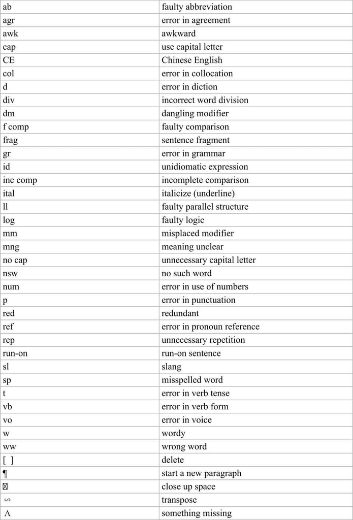

写作错误统计表

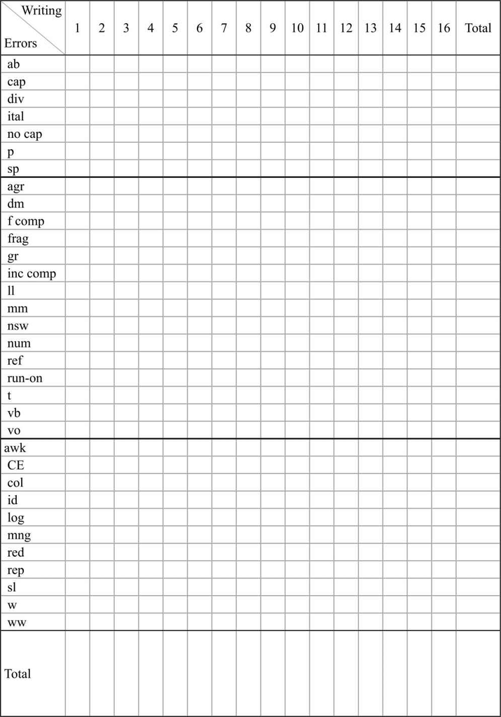